# Kurva Aljabar - Unit 1-24

### Soal 5.10

Misalkan $C$ dan $D$ masing-masing merupakan kurva aljabar afin bidang yang terdiri atas gabungan empat garis berbeda, dan keempat garis pada masing-masing kurva berpotongan di satu titik. Buktikan bahwa pada umumnya tidak terdapat perubahan koordinat afin-linear yang memetakan $C$ ke $D$.

Dua soal berikut dimaksudkan untuk memahami Teorema 5.4 dan Korolari 5.5.

### Soal 5.11

Terapkan bukti Teorema 5.4 pada polinom $Y$.

### Soal 5.12

Terapkan bukti Teorema 5.4 pada hiperbola $XY-1$.

### Soal 5.13

Terapkan bukti Teorema 5.4 pada polinom

$$X^2Y^3+5X^3Y^2-X^2Y^2+3Y+7\in\mathbb C[X,Y].$$

### Soal 5.14

Misalkan $F\in\mathbb C[X,Y]$ suatu polinom takkonstan. Buktikan bahwa kurva aljabar $C=V(F)$ yang bersesuaian mempunyai takterhitung banyak elemen.

### Soal 5.15 ★

Misalkan

$$M=\{P_1,\ldots,P_n\}\subseteq K^2$$

suatu himpunan titik berhingga di bidang di atas lapangan takhingga $K$.

1. Buktikan bahwa $M$ dapat diperoleh sebagai irisan dua kurva aljabar.
2. Buktikan bahwa $M$ dapat diperoleh sebagai irisan dua kurva aljabar yang tak tereduksi.

### Soal 5.16

Hitung citra $\widetilde F$ dari polinom

$$F=X^2Y+3XY-Y^3$$

di bawah homomorfisme substitusi

$$K[X,Y]\longrightarrow K[S,T]$$

yang ditentukan oleh

$$X\longmapsto T^2+S-3,
\qquad
Y\longmapsto 3TS+S^2-T.$$

### Soal 5.17

Misalkan $K$ suatu lapangan takhingga dan $F\in K[X_1,\ldots,X_n]$ suatu polinom dengan pemetaan yang bersesuaian

$$F:\mathbb A_K^n\longrightarrow\mathbb A_K^1.$$

Buktikan, dengan dan tanpa menggunakan Teorema 5.10, bahwa citra $F$ terdiri atas satu titik atau takhingga banyak titik.

### Soal 5.18

Misalkan $K$ suatu lapangan berhingga dengan $q$ elemen, dan

$$P_1,\ldots,P_n\in\mathbb A_K^2$$

merupakan $n$ titik di bidang afin. Buktikan bahwa terdapat pemetaan polinomial

$$\varphi:\mathbb A_K^1\longrightarrow\mathbb A_K^2$$

dengan

$$\operatorname{im}\varphi=\{P_1,\ldots,P_n\}$$

tepat ketika $1\le n\le q$.

### Soal 5.19 ★

Berikan sebuah contoh pemetaan polinomial

$$\mathbb A_K^2\longrightarrow\mathbb A_K^1$$

sedemikian sehingga praimaj satu titik tereduksi, sedangkan praimaj setiap titik lainnya tak tereduksi.

### Soal 5.20 ★

Misalkan $K$ suatu lapangan. Untuk setiap $n\in\mathbb N_+$, pertimbangkan pemetaan

$$\begin{aligned}
\varphi:K^n&\longrightarrow K^n,\\
(\lambda_1,\lambda_2,\ldots,\lambda_n)
&\longmapsto(c_0,c_1,\ldots,c_{n-1}),
\end{aligned}$$

yang memetakan tupel akar $(\lambda_1,\ldots,\lambda_n)$ ke tupel koefisien $(c_0,\ldots,c_{n-1})$ (tanpa koefisien $1$) dari polinom monik

$$(X-\lambda_1)(X-\lambda_2)\cdots(X-\lambda_n)
=P=c_0+c_1X+\cdots+c_{n-1}X^{n-1}+X^n.$$

1. Deskripsikan $\varphi$ secara eksplisit untuk $n=2$.
2. Deskripsikan $\varphi$ secara eksplisit untuk $n=3$.
3. Jelaskan mengapa pemetaan-pemetaan $\varphi$ tersebut polinomial.
4. Buktikan bahwa serat-serat $\varphi$ berhingga.
5. Kapan serat di atas suatu tupel $(c_0,c_1,\ldots,c_{n-1})$ kosong?
6. Berapakah banyak elemen maksimum dalam suatu serat? Berikan contoh yang menunjukkan bahwa maksimum tersebut dicapai untuk $K=\mathbb R$.
7. Sekarang misalkan $K$ tertutup secara aljabar. Buktikan bahwa $\varphi$ surjektif.

### Soal 5.21

Misalkan

$$\varphi:\mathbb A_K^r\longrightarrow\mathbb A_K^n$$

suatu pemetaan polinomial dan $T\subseteq\mathbb A_K^r$ suatu subhimpunan. Buktikan bahwa

$$\overline{\varphi(T)}=\overline{\varphi(\overline T)}.$$

### Soal 5.22

Buktikan bahwa pernyataan Soal 5.21 tidak berlaku tanpa asumsi bahwa pemetaan tersebut polinomial.

## Soal untuk dikumpulkan

### Soal 5.23 - 3 poin

Berapa banyak monomial berderajat $d$ yang terdapat dalam gelanggang polinomial dalam satu, dua, dan tiga variabel?

### Soal 5.24 - 3 poin

Terapkan bukti Teorema 5.4 pada kurva aljabar yang bersesuaian dengan fungsi rasional

$$Y=\frac{X^2-2X}{X^2-1}.$$

### Soal 5.25 - 3 poin

Pertimbangkan pemetaan

$$\mathbb A_K^2\longrightarrow\mathbb A_K^2,
\qquad
(x,y)\longmapsto(x,xy).$$

Tentukan citra dan serat-serat pemetaan ini.

### Soal 5.26 - 3 poin

Pertimbangkan elipsoid

$$E=V(2x^2+3y^2+4z^2-5)
=\{(x,y,z):2x^2+3y^2+4z^2=5\}.$$

Temukan suatu transformasi variabel afin-linear di atas $\mathbb R$ sedemikian sehingga citra $E$ di bawah pemetaan tersebut adalah bola satuan standar

$$V(x^2+y^2+z^2-1).$$

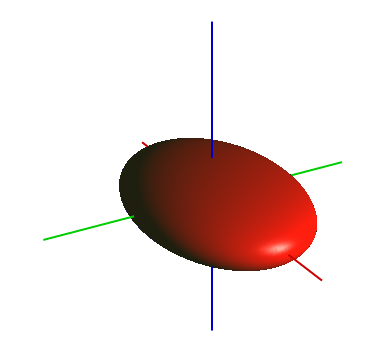

Sebuah elipsoid; dalam geometri aljabar yang dimaksud adalah permukaannya

### Soal 5.27 - 4 poin

Misalkan $V$ dan $\widetilde V$ himpunan-himpunan aljabar afin dalam $\mathbb A_K^2$ untuk $K=\mathbb Z/(2)$. Buktikan bahwa kedua himpunan itu ekuivalen afin-linear tepat ketika keduanya mempunyai kardinalitas yang sama.

Buktikan pula bahwa pernyataan ini tidak berlaku untuk $K=\mathbb Z/(p)$ dengan $p\ge3$, dan juga tidak berlaku di $\mathbb A_{\mathbb Z/(2)}^n$ untuk $n\ge3$.

**Navigasi sumber:** Kuliah 5 - solusi publik Unit 5 - Lembar Kerja 4 - Lembar Kerja 6 (sumber)

# Solusi Publik Lembar Kerja 5

Sumber hanya menyediakan solusi publik bagi Soal 5.3, 5.15, 5.19, dan 5.20 pada batas revisi yang dibekukan. Tidak ada solusi tambahan yang dibuat untuk edisi ini.

## Solusi Soal 5.3

Misalkan

$$F=\sum_{i=0}^n a_iX^iY^{n-i}.$$

Dehomogenisasinya adalah polinom satu variabel

$$\widetilde F=\sum_{i=0}^n a_iX^i.$$

Karena lapangan tersebut tertutup secara aljabar, polinom ini mempunyai faktorisasi

$$\widetilde F=a_n\prod_{i=1}^n(X-c_i).$$

Dengan menghomogenkan kembali, diperoleh faktorisasi

$$F=a_n\prod_{i=1}^n(X-c_iY).$$

**Catatan edisi:** rumus sumber menempatkan $a_n$ di dalam tanda hasil kali, yang akan menghasilkan faktor $a_n^n$. Di sini $a_n$ ditempatkan satu kali di luar hasil kali, sesuai faktorisasi polinom berkoefisien utama $a_n$.

Kembali ke Soal 5.3.

## Solusi Soal 5.15

1. Pilih suatu bentuk linear yang cukup umum sehingga nilainya berbeda pada titik-titik yang diberikan. Dengan demikian, kita dapat mengandaikan bahwa koordinat telah dipilih sedemikian sehingga bagi

   $$P_i=(a_i,b_i),$$

   semua koordinat pertama $a_i$ saling berbeda. Misalkan

   $$F=(X-a_1)\cdots(X-a_n).$$

   Menurut teorema interpolasi, pilih suatu polinom satu variabel $H$ dengan

   $$H(a_i)=b_i$$

   untuk $i=1,\ldots,n$. Dengan $G=Y-H$, kita memperoleh

   $$M=V(F)\cap V(G),$$

   sehingga $M$ merupakan irisan dua kurva.
2. Ganti $F$ dengan

   $$F'=Y-H+F.$$

   Maka

   $$V(G)\cap V(F')=V(G)\cap V(F)=M.$$

   Kedua kurva tersebut merupakan grafik, sehingga tak tereduksi.

Kembali ke Soal 5.15.

## Solusi Soal 5.19

Misalkan $K$ suatu lapangan tertutup secara aljabar. Pertimbangkan pemetaan

$$\mathbb A_K^2\longrightarrow\mathbb A_K^1,
\qquad
(x,y)\longmapsto xy.$$

Serat di atas titik nol adalah pasangan sumbu

$$V(xy)=V(x)\cup V(y),$$

yang tereduksi. Serat di atas suatu titik $\lambda\in K$ dengan $\lambda\ne0$ adalah $V(xy-\lambda)$. Cukup dibuktikan bahwa $xy-\lambda$ merupakan polinom prima. Hal ini mengikuti dari isomorfisme

$$K[x,y]/(xy-\lambda)\longrightarrow K[u]_u,
\qquad
x\longmapsto u,
\qquad
y\longmapsto\lambda u^{-1},$$

dengan pemetaan balik $u\mapsto x$. Sifat universal gelanggang faktor dan lokalisasi memastikan bahwa pemetaan-pemetaan tersebut memang saling berbalikan.

Kembali ke Soal 5.19.

## Solusi Soal 5.20

1. Untuk $n=2$, karena

   $$(X-\lambda_1)(X-\lambda_2)
   =X^2-(\lambda_1+\lambda_2)X+\lambda_1\lambda_2,$$

   pemetaannya adalah

   $$\begin{aligned}
   \varphi:K^2&\longrightarrow K^2,\\
   (\lambda_1,\lambda_2)
   &\longmapsto(\lambda_1\lambda_2,-(\lambda_1+\lambda_2)).
   \end{aligned}$$
2. Untuk $n=3$, karena

   $$\begin{aligned}
   &(X-\lambda_1)(X-\lambda_2)(X-\lambda_3)\\
   &\quad=X^3-(\lambda_1+\lambda_2+\lambda_3)X^2
   +(\lambda_1\lambda_2+\lambda_1\lambda_3
   +\lambda_2\lambda_3)X-\lambda_1\lambda_2\lambda_3,
   \end{aligned}$$

   pemetaannya adalah

   $$\begin{aligned}
   \varphi:K^3&\longrightarrow K^3,\\
   (\lambda_1,\lambda_2,\lambda_3)
   &\longmapsto\bigl(-\lambda_1\lambda_2\lambda_3,
   \lambda_1\lambda_2+\lambda_1\lambda_3+\lambda_2\lambda_3,
   -(\lambda_1+\lambda_2+\lambda_3)\bigr).
   \end{aligned}$$
3. Tetapkan $n\in\mathbb N_+$ dan $k$ di antara $0$ dan $n-1$. Berdasarkan hukum distributif, koefisien $c_k$ dari $\prod_{i=1}^n(X-\lambda_i)$ adalah

   $$\mathord{\pm}
   \sum_{1\le i_1<i_2<\cdots<i_{n-k}\le n}
   \lambda_{i_1}\lambda_{i_2}\cdots\lambda_{i_{n-k}},$$

   dengan tanda yang ditentukan oleh paritas $n-k$. Jadi setiap fungsi komponen merupakan polinom.
4. Tupel $(\lambda_1,\ldots,\lambda_n)$ termasuk dalam serat di atas tupel koefisien $(c_0,\ldots,c_{n-1})$ tepat ketika

   $$\prod_{i=1}^n(X-\lambda_i)
   =\sum_{j=0}^{n-1}c_jX^j+X^n=P.$$

   Secara khusus, semua $\lambda_i$ harus merupakan akar $P$. Karena suatu polinom hanya mempunyai berhingga banyak akar, hanya ada berhingga banyak permutasi yang mungkin.
5. Serat di atas tupel $(c_0,\ldots,c_{n-1})$ kosong tepat ketika polinom

   $$\sum_{j=0}^{n-1}c_jX^j+X^n$$

   tidak terurai sepenuhnya menjadi faktor-faktor linear.
6. Banyak elemen maksimum dalam suatu serat adalah $n!$. Jika polinom yang diberikan oleh tupel koefisien terurai sepenuhnya, seratnya terdiri atas tupel-tupel akar terurut; jika tidak, seratnya kosong. Karena terdapat paling banyak $n$ akar, paling banyak $n!$ tupel terurut dapat dibentuk. Jika terdapat $n$ akar berbeda, seluruh permutasinya menghasilkan tepat $n!$ tupel. Sebagai contoh, tupel akar

   $$(1,2,3,\ldots,n)$$

   dipetakan ke suatu tupel koefisien yang seratnya terdiri atas semua permutasi tupel tersebut.
7. Jika $K$ tertutup secara aljabar, setiap polinom monik terurai menjadi faktor-faktor linear monik. Menurut bagian 5, setiap serat yang bersesuaian tidak kosong. Jadi, $\varphi$ surjektif.

Kembali ke Soal 5.20.

# Kuliah 6: Parametrisasi Polinomial dan Rasional

## Parametrisasi polinomial bidang

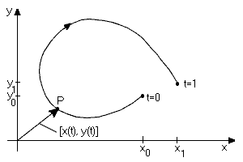

Kurva berparameter dapat dibayangkan sebagai suatu lintasan gerak

Sekarang kita meninjau pemetaan

$$\varphi:\mathbb A_K^1\longrightarrow\mathbb A_K^2$$

yang diberikan oleh dua polinom satu variabel

$$P,Q\in K[T].$$

Citra pemetaan semacam ini terletak pada suatu kurva aljabar afin, seperti ditunjukkan oleh teorema berikut. Kita juga berbicara tentang *kurva berparameter*, atau lebih tepatnya *kurva yang diparameterkan secara polinomial*.

Di sini ada dua sudut pandang yang bersaing tentang cara mendeskripsikan kurva aljabar. Titik-titik pada kurva yang diberikan oleh persamaan kurva hanya ditentukan secara implisit. Untuk setiap titik bidang, mudah diperiksa apakah titik itu terletak pada kurva, tetapi secara umum sulit menemukan atau menuliskan titik-titik kurva secara eksplisit. Sebaliknya, kurva berparameter diberikan secara eksplisit: bagi setiap titik garis afin, titik citranya dapat dihitung dengan mudah, sehingga titik-titik kurva diperoleh secara eksplisit. Namun, tidak setiap kurva aljabar dapat diparameterkan oleh polinom.

### Teorema: persamaan bagi kurva yang diparameterkan secara polinomial

Misalkan $K$ suatu lapangan dan $P,Q\in K[T]$ polinom. Maka terdapat polinom

$$F\in K[X,Y],\qquad F\ne0,$$

dengan

$$F(P,Q)=0.$$

Dengan kata lain, citra suatu kurva yang diparameterkan secara polinomial terletak pada kurva aljabar bidang

$$C=V(F).$$

Jika $K$ takhingga dan $P,Q$ tidak keduanya konstan, penutupan Zariski citra tersebut merupakan kurva tak tereduksi $C$.

#### Bukti

Misalkan $d$ dan $e$ masing-masing derajat $P$ dan $Q$. Kita meninjau monomial-monomial

$$P^iQ^j.$$

Ini merupakan polinom dalam $T$ berderajat $di+ej$. Untuk $i\le n$ dan $j\le m$, terdapat $(n+1)(m+1)$ monomial semacam itu. Semuanya terletak dalam ruang vektor-$K$ berdimensi $dn+em+1$ yang dibangkitkan oleh

$$1=T^0,T^1,T^2,\ldots,T^{dn+em}.$$

Jika

$$(n+1)(m+1)>dn+em+1,$$

harus ada ketergantungan linear taktrivial di antara $P^iQ^j$. Ketergantungan ini memberikan polinom $F(X,Y)\ne0$ dengan $F(P,Q)=0$. Syarat numerik di atas dapat dipenuhi dengan memilih $n,m$ cukup besar.

Mulai sekarang, misalkan $K$ takhingga. Menurut Lema 3.10, penutupan Zariski dari citra

$$B=\varphi(\mathbb A_K^1)$$

adalah $V(\operatorname{Id}(B))$, dan menurut Teorema 5.10 himpunan ini tak tereduksi. Karena $K$ takhingga dan pemetaan tersebut tidak konstan, ketaktereduksian juga memaksa $V(\operatorname{Id}(B))$ mempunyai takhingga banyak titik. Menurut Lema 4.3, $\operatorname{Id}(B)$ merupakan ideal prima; menurut bagian pertama, ideal ini memuat suatu

$$F\in\operatorname{Id}(B),\qquad F\ne0.$$

Karena $K[X,Y]$ merupakan domain faktorisasi unik, suatu faktor prima dari $F$ juga termasuk dalam ideal tersebut. Jadi, kita dapat mengandaikan bahwa $F$ merupakan polinom prima. Kita mempunyai inklusi

$$B\subseteq\overline B
=V(\operatorname{Id}(B))
\subseteq V(F).$$

Untuk $H\in\operatorname{Id}(B)$, himpunan

$$V(\operatorname{Id}(B))\subseteq V(H)\cap V(F)$$

takhingga. Menurut Teorema 4.8, $H$ dan $F$ harus mempunyai faktor takkonstan yang sama. Karena $F$ prima, $H$ harus merupakan kelipatan $F$. Dengan demikian,

$$\operatorname{Id}(B)=(F).$$

$\square$

### Contoh: mengeliminasi parameter

Pertimbangkan kurva yang diberikan oleh parametrisasi

$$x=t^2+t+1,
\qquad
y=2t^2+3t-1.$$

Kita mempunyai

$$x-1=t^2+t,
\qquad
y+1=2t^2+3t.$$

Pengurangan sederhana menghasilkan

$$(y+1)-2(x-1)=3t-2t=t.$$

Jadi,

$$x-1=t^2+t=(y-2x+3)^2+(y-2x+3).$$

Setelah dikembangkan, persamaan kurvanya adalah

$$y^2+4x^2-4xy-15x+7y+13=0.$$

### Contoh: kurva dengan satu perpotongan-diri

[figure not shown]

Kurva kubik dengan titik ganda

Pertimbangkan pemetaan $\mathbb A_K^1\to\mathbb A_K^2$ yang diberikan oleh

$$P=t^2-1,
\qquad
Q=t^3-t=t(t^2-1).$$

Kedua nilai parameter $t=\pm1$ menghasilkan titik $(0,0)$. Untuk setiap nilai lain $t\ne\pm1$, kita dapat menulis

$$t=\frac{t^3-t}{t^2-1}=\frac{Q(t)}{P(t)}.$$

Jadi, parameter $t$ dapat direkonstruksi dari nilai citranya, yang berarti pemetaan tersebut injektif di luar kedua nilai itu. Dengan demikian, kurva citranya berpotongan dengan dirinya sendiri tepat di satu tempat.

Untuk menentukan persamaan kurva, tuliskan $x=t^2-1$ dan $y=t^3-t$. Maka

$$t^2=x+1$$

dan

$$\begin{aligned}
y^2
&=t^2(t^2-1)^2\\
&=t^2x^2\\
&=(x+1)x^2\\
&=x^3+x^2.
\end{aligned}$$

Jadi, polinom yang mendeskripsikan kurva tersebut adalah

$$Y^2-X^3-X^2.$$

## Parametrisasi rasional

Pertimbangkan fungsi rasional

$$Y=\frac{P}{Q},
\qquad
P,Q\in K[T].$$

Fungsi ini segera memberikan bentuk parametrisasi baru melalui pemetaan

$$\begin{aligned}
\mathbb A_K^1\supseteq D(Q)&\longrightarrow\mathbb A_K^2,\\
t&\longmapsto\left(t,\frac{P(t)}{Q(t)}\right).
\end{aligned}$$

Di sini $D(Q)$ adalah domain definisi pemetaan, yakni

$$D(Q)=\mathbb A_K^1\setminus V(Q),$$

yang terdiri atas semua titik tempat polinom penyebut $Q$ tidak bernilai nol. Pemetaan ini jelas mencakup semua titik grafik fungsi rasional, sehingga, seperti parametrisasi polinomial, ia memberikan deskripsi eksplisit bagi kurva. Oleh karena itu, untuk mendeskripsikan kurva, wajar pula mengizinkan parametrisasi yang fungsi-fungsi komponennya rasional.

### Definisi: parametrisasi rasional

Dua fungsi rasional

$$\varphi_1=\frac{P_1}{Q_1},
\qquad
\varphi_2=\frac{P_2}{Q_2},$$

dengan

$$P_1,P_2,Q_1,Q_2\in K[T],
\qquad
Q_1,Q_2\ne0,$$

disebut suatu *parametrisasi rasional* bagi kurva aljabar

$$C=V(F),
\qquad
F\in K[X,Y]\text{ takkonstan},$$

apabila

$$F(\varphi_1(T),\varphi_2(T))=0$$

dan pasangan $(\varphi_1,\varphi_2)$ tidak konstan.

Kesamaan dalam definisi ini dipahami dalam lapangan fungsi rasional $K(T)$. Jika $K$ takhingga, hal ini ekuivalen dengan kesamaan tersebut berlaku untuk semua $t\in K$ tempat polinom-polinom penyebut terdefinisi.

### Definisi: kurva rasional

Kurva aljabar bidang

$$C=V(F)$$

disebut *rasional* apabila kurva itu tak tereduksi dan mempunyai suatu parametrisasi rasional.

Contoh sederhana berikut menunjukkan bahwa fungsi rasional dapat memarameterkan lebih banyak kurva daripada polinom. Namun, perlu disebutkan sejak sekarang bahwa perbedaan ini menghilang lagi dalam konteks geometri projektif.

### Contoh: hiperbola

Pertimbangkan hiperbola

$$H=V(XY-1).$$

Kita menyatakan bahwa hiperbola ini tidak mempunyai parametrisasi polinomial. Bagi dua polinom $P(t)$ dan $Q(t)$, syarat agar citranya selalu berada pada $H$ adalah

$$P(t)Q(t)=1
\quad\text{untuk setiap }t\in\mathbb A_K^1,$$

atau bahwa $P(t)Q(t)=1$ dalam gelanggang polinomial $K[t]$. Kedua syarat ini ekuivalen jika lapangan tersebut takhingga; untuk lapangan berhingga, identitas kedualah syarat yang tepat. Identitas itu berarti $P$ dan $Q$ saling invers, sehingga keduanya satuan. Satuan-satuan dalam gelanggang polinomial hanyalah konstanta taknol. Jadi, kedua polinom itu konstan, pemetaan yang didefinisikan olehnya konstan, dan tidak ada parametrisasi polinomial.

Sebaliknya,

$$\begin{aligned}
\mathbb A_K^1\setminus\{0\}&\longrightarrow\mathbb A_K^2,\\
t&\longmapsto\left(t,\frac1t\right)
\end{aligned}$$

merupakan parametrisasi rasional bagi hiperbola tersebut.

Kita ingin menunjukkan bahwa citra pemetaan rasional takkonstan selalu memenuhi suatu persamaan aljabar, sehingga selalu memberikan parametrisasi rasional bagi suatu kurva aljabar. Dalam kasus polinomial, persamaan aljabar diperoleh melalui argumen pencacahan: jumlah monomial dalam dua variabel bertumbuh lebih cepat bersama derajat daripada jumlah monomial dalam satu variabel. Kita akan memakai argumen serupa bersama sebuah trik tambahan, yaitu *homogenisasi*. Trik ini membuat suatu situasi takhomogen menjadi homogen dengan menambahkan satu variabel lagi. Di sini proses tersebut kita gunakan secara aljabar murni, tetapi di baliknya terdapat hubungan antara geometri afin dan geometri projektif.

### Definisi: homogenisasi

Misalkan

$$F\in K[X_1,\ldots,X_n],
\qquad
F\ne0,$$

suatu polinom dengan dekomposisi homogen

$$F=\sum_{i=0}^dF_i,$$

dan misalkan $Z$ suatu variabel tambahan. Polinom homogen berderajat $d$

$$\widehat F
=\sum_{i=0}^dF_iZ^{d-i}
\in K[X_1,\ldots,X_n,Z]$$

disebut *homogenisasi* dari $F$.

Polinom asal dapat diperoleh kembali dari homogenisasinya dengan menetapkan variabel tambahan $Z=1$. Proses ini disebut *dehomogenisasi*.

### Lema: relasi homogen bagi tiga polinom homogen

Misalkan

$$P_1,P_2,P_3\in K[S,T]$$

tiga polinom homogen dengan derajat yang sama. Maka terdapat polinom homogen

$$F\in K[X,Y,Z],
\qquad
F\ne0,$$

dengan

$$F(P_1,P_2,P_3)=0.$$

#### Bukti

Pernyataan ini mengikuti dari argumen pencacahan yang serupa dengan bukti Teorema 6.1; lihat Soal 6.7. $\square$

### Contoh: suatu relasi monomial

Pertimbangkan pemetaan

$$(S,T)\longmapsto(S^2,T^2,ST)=(X,Y,Z),$$

yang diberikan oleh polinom-polinom homogen, bahkan oleh monomial. Relasi aljabar bagi citranya mudah ditemukan:

$$Z^2=(ST)^2=S^2T^2=XY.$$

Jadi, citra pemetaan tersebut terletak pada $V(Z^2-XY)$. Lihat juga Soal 6.29.

### Teorema: citra pemetaan rasional memenuhi persamaan aljabar

Misalkan diberikan dua fungsi rasional

$$\varphi_1=\frac{P_1}{Q_1},
\qquad
\varphi_2=\frac{P_2}{Q_2},$$

dengan $P_1,P_2,Q_1,Q_2\in K[T]$, $Q_1,Q_2\ne0$, yang tidak keduanya konstan. Maka terdapat polinom takkonstan $F\in K[X,Y]$ dengan

$$F(\varphi_1(T),\varphi_2(T))=0.$$

Dengan demikian, $\varphi_1$ dan $\varphi_2$ mendefinisikan suatu parametrisasi rasional.

#### Bukti

Dengan memakai penyebut bersama, kita dapat mengandaikan bahwa pemetaan rasional tersebut diberikan oleh

$$\varphi_1=\frac{P_1}{Q},
\qquad
\varphi_2=\frac{P_2}{Q},$$

dengan $P_1,P_2,Q\in K[T]$ dan $Q\ne0$. Misalkan

$$H'_1,H'_2,H'_3\in K[T,S]$$

homogenisasi ketiga polinom itu dengan variabel baru $S$, dan misalkan $e$ derajat terbesar di antara ketiganya. Tetapkan

$$H_i=S^{e-\deg(H'_i)}H'_i.$$

Polinom $H_1,H_2,H_3$ semuanya berderajat $e$, sedangkan dehomogenisasinya pada $S=1$ tetap $P_1,P_2,Q$. Menurut Lema 6.8, terdapat polinom homogen

$$F\in K[U,V,W],
\qquad
F\ne0,$$

berderajat $d$ dalam $U,V,W$, dengan

$$F(H_1,H_2,H_3)=0.$$

Sekarang tinjau

$$\frac1{W^d}F(U,V,W)
=F\left(\frac UW,\frac VW,\frac WW\right),$$

yang merupakan polinom dalam kedua fungsi rasional $U/W$ dan $V/W$. Homogenitas $F$ sangat penting bagi langkah ini. Substitusi ketiga polinom homogen menghasilkan

$$0=F\left(\frac{H_1}{H_3},\frac{H_2}{H_3},1\right).$$

Ini merupakan kesamaan dalam lapangan hasil bagi $K[S,T]$. Dengan menetapkan $S=1$, yaitu melakukan dehomogenisasi, dan menuliskan

$$G(X,Y)=F(X,Y,1),$$

kita memperoleh polinom taknol $G\in K[X,Y]$ dengan

$$0=G\left(\frac{P_1}{Q},\frac{P_2}{Q}\right),$$

yang merupakan suatu persamaan bagi kedua fungsi rasional asal. $\square$

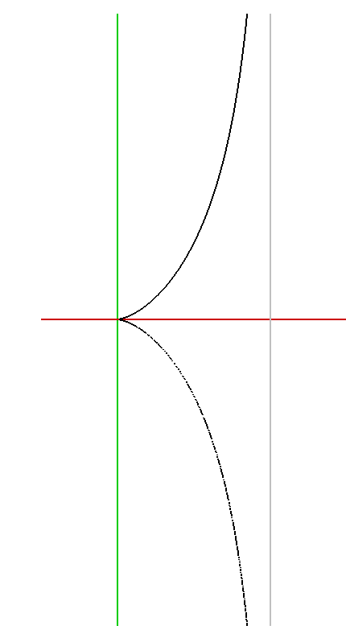

Sissoid Diokles (hitam pada gambar) dapat diparameterkan secara rasional

### Catatan: parametrisasi terdiferensial lokal

Kita dapat melangkah lebih jauh dan bertanya apakah ada cara lain untuk mendeskripsikan kurva aljabar

$$C=V(F)$$

melalui suatu pemetaan $\varphi:K\to K^2$ jika $\varphi$ boleh berasal dari kelas fungsi yang lebih luas. Salah satu hasil penting adalah teorema fungsi implisit. Untuk $K=\mathbb R$ atau $K=\mathbb C$, teorema ini menyatakan bahwa jika kedua turunan parsial $F$ tidak sekaligus nol di suatu titik kurva, maka terdapat suatu pemetaan terdiferensial takhingga kali, bahkan analitik, yang mendeskripsikan kurva dalam suatu lingkungan terbuka kecil di sekitar titik tersebut. Versi aljabar dari teorema fungsi implisit muncul kembali dalam pendekatan deret pangkat yang akan kita bahas kemudian.

# Lembar Kerja 6

## Soal latihan

### Soal 6.1

Misalkan $F(x)\in K[x]$ suatu polinom satu variabel di atas lapangan $K$. Parametrisasikan grafik $F$ dengan polinom.

### Soal 6.2

Tentukan suatu persamaan kurva bagi kurva berparameter

$$x=-3t^2+4t-2,
\qquad
y=2t^2+5t-3.$$

### Soal 6.3 ★

Misalkan $K$ suatu lapangan. Pertimbangkan parametrisasi

$$\begin{aligned}
\mathbb A_K^1&\longrightarrow\mathbb A_K^2,\\
t&\longmapsto(t+t^2,t^3)=(x,y).
\end{aligned}$$

Tentukan suatu persamaan aljabar taktrivial yang dipenuhi oleh semua titik citra pemetaan ini. Berikan pula suatu titik di bidang afin yang tidak terletak pada kurva citra tersebut.

### Soal 6.4 ★

Misalkan $K$ suatu lapangan. Pertimbangkan pemetaan polinomial

$$\begin{aligned}
\mathbb A_K^1&\longrightarrow\mathbb A_K^2,\\
t&\longmapsto(t^2+1,t^3-t).
\end{aligned}$$

Tentukan suatu persamaan aljabar taktrivial yang dipenuhi oleh semua titik citra pemetaan ini.

Fenomena yang dideskripsikan dalam soal berikut tidak dapat terjadi di atas lapangan tertutup secara aljabar.

### Soal 6.5

Berikan contoh suatu parametrisasi polinomial

$$\varphi:\mathbb A_{\mathbb R}^1\longrightarrow
C\subset\mathbb A_{\mathbb R}^2,$$

dengan $C$ merupakan penutupan Zariski dari citra, sedemikian sehingga takterhingga banyak titik $C$ tidak termasuk dalam citra.

### Soal 6.6

Buktikan bahwa, dalam situasi Contoh 6.3, parametrisasi kurva yang diberikan bersifat surjektif untuk $K=\mathbb R$.

### Soal 6.7

Misalkan

$$P_1,P_2,P_3\in K[S,T]$$

tiga polinom homogen dengan derajat yang sama. Buktikan bahwa terdapat polinom homogen

$$F\in K[X,Y,Z],
\qquad
F\ne0,$$

dengan

$$F(P_1,P_2,P_3)=0.$$

### Soal 6.8 ★

Apakah terdapat polinom homogen $F\in K[X,Y,Z]$, $F\ne0$, dengan

$$F(S,T,ST)=0?$$

### Soal 6.9 ★

Tentukan suatu persamaan aljabar bagi kurva citra pemetaan

$$\begin{aligned}
\mathbb A_K^1\setminus\{0\}&\longrightarrow\mathbb A_K^2,\\
t&\longmapsto\left(\frac{t^2+1}{t},\frac{t+1}{t}\right).
\end{aligned}$$

Lakukan pemeriksaan langsung atas persamaan yang diperoleh.

### Soal 6.10

Tentukan suatu persamaan aljabar taktrivial bagi citra pemetaan

$$\begin{aligned}
\mathbb A_K^1\setminus\{-1,0,1\}&\longrightarrow\mathbb A_K^2,\\
t&\longmapsto\left(\frac{t}{t^2-1},\frac1t\right).
\end{aligned}$$

Dalam soal-soal berikut, digunakan konsep kurva terdiferensial sebagaimana dibahas dalam Analisis 2.

### Soal 6.11

Berikan contoh suatu kurva terdiferensial takaljabar (takpolinomial) di $\mathbb R^2$ yang citranya berimpit dengan suatu kurva aljabar.

### Soal 6.12

Buktikan bahwa lintasan spiral Archimedes

$$\begin{aligned}
f:\mathbb R_{\ge0}&\longrightarrow\mathbb R^2,\\
t&\longmapsto(t\cos t,t\sin t)
\end{aligned}$$

tidak aljabar.

### Soal 6.13

Misalkan

$$C=V(F)\subseteq\mathbb A_{\mathbb R}^2$$

suatu kurva yang dapat diparameterkan secara rasional. Buktikan bahwa kurva tersebut juga mempunyai parametrisasi terdiferensial yang takaljabar.

### Soal 6.14

Berikan suatu kurva terdiferensial $f:\mathbb R\to\mathbb R^2$ yang citranya tepat merupakan gabungan kedua sumbu koordinat.

### Soal 6.15

Misalkan $\varphi:\mathbb A_K^2\to\mathbb A_K^2$ suatu pemetaan polinomial dan $C$ suatu kurva rasional bidang. Andaikan $C$ tidak dipetakan oleh $\varphi$ ke satu titik saja. Buktikan bahwa

$$\overline{\varphi(C)}$$

juga merupakan kurva rasional.

### Soal 6.16

Misalkan $K$ suatu lapangan tertutup secara aljabar dengan karakteristik nol dan misalkan diberikan pemetaan polinomial

$$\begin{aligned}
\varphi:\mathbb A_K^1&\longrightarrow\mathbb A_K^2,\\
t&\longmapsto(t^2,\psi(t)),
\end{aligned}$$

dengan $\psi(t)\in K[t]$. Buktikan bahwa $\varphi$ injektif tepat ketika $\psi$ berbentuk

$$\psi(t)=at^n+\theta(t),$$

dengan $a\ne0$, $n$ ganjil, dan $\theta(t)$ suatu polinom yang hanya memuat pangkat-pangkat genap.

### Soal 6.17 ★

Misalkan $p\in[0,1]$ probabilitas terjadinya suatu peristiwa tertentu $A$ dalam suatu eksperimen, sehingga $1-p$ adalah probabilitas bahwa peristiwa itu tidak terjadi ($\neg A$). Eksperimen dilakukan dua kali secara saling bebas. Peristiwa-peristiwa gabungan

$$(A,A),\ (A,\neg A),\ (\neg A,A),\ (\neg A,\neg A)$$

mempunyai probabilitas yang bergantung pada $p$. Nyatakan ketergantungan ini sebagai pemetaan polinomial

$$\begin{aligned}
\varphi:\mathbb A_K^1&\longrightarrow\mathbb A_K^4,\\
p&\longmapsto
\bigl(p^2,p(1-p),(1-p)p,(1-p)^2\bigr)=(x,y,z,w).
\end{aligned}$$

1. Buktikan bahwa pemetaan tersebut injektif.
2. Deskripsikan citranya secara lengkap dengan persamaan-persamaan polinomial.

### Soal 6.18 ★

Misalkan $p\in[0,1]$ probabilitas terjadinya peristiwa $A$ dalam eksperimen pertama, dan $q\in[0,1]$ probabilitas terjadinya peristiwa $B$ dalam eksperimen kedua. Kedua eksperimen dilakukan secara saling bebas. Peristiwa-peristiwa gabungan

$$(A,B),\ (A,\neg B),\ (\neg A,B),\ (\neg A,\neg B)$$

mempunyai probabilitas yang bergantung pada $p$ dan $q$. Nyatakan ketergantungan ini sebagai pemetaan polinomial

$$\begin{aligned}
\varphi:\mathbb A_K^2&\longrightarrow\mathbb A_K^4,\\
(p,q)&\longmapsto
\bigl(pq,p(1-q),(1-p)q,(1-p)(1-q)\bigr)=(x,y,z,w).
\end{aligned}$$

1. Buktikan bahwa pemetaan tersebut injektif.
2. Deskripsikan citranya secara lengkap dengan persamaan-persamaan polinomial.

### Soal 6.19

Pertimbangkan pemetaan

$$\begin{aligned}
\mathbb A_K^2\supseteq D(s)&\longrightarrow\mathbb A_K^3,\\
(s,t)&\longmapsto\left(s,\frac{t^2}{s},t\right)=(x,y,z).
\end{aligned}$$

Tentukan suatu persamaan aljabar $F$ bagi citranya. Selidiki keinjektifan dan kesurjektifan pemetaan ini sebagai pemetaan ke $V(F)$. Bandingkan pemetaan ini dengan pemetaan-pemetaan yang dibahas dalam Soal 6.29.

### Soal 6.20

Misalkan $K$ suatu lapangan, $K[X_1,\ldots,X_n]$ gelanggang polinomial di atas $K$ dalam $n$ variabel, dan $K[X_1,\ldots,X_n,Z]$ gelanggang polinomial dalam $n+1$ variabel. Bagi $F\in K[X_1,\ldots,X_n]$, misalkan $\widehat F\in K[X_1,\ldots,X_n,Z]$ homogenisasinya terhadap $Z$. Bagi $G\in K[X_1,\ldots,X_n,Z]$, misalkan $\widetilde G$ dehomogenisasinya yang diberikan oleh $Z\mapsto1$. Buktikan bahwa

$$\widetilde{\widehat F}=F,$$

tetapi tidak selalu berlaku

$$\widehat{\widetilde G}=G.$$

### Soal 6.21 ★

Misalkan $K$ suatu lapangan dan $K[X_1,\ldots,X_n,Z]$ gelanggang polinomial di atas $K$ dalam $n+1$ variabel. Misalkan

$$G,H\in K[X_1,\ldots,X_n,Z]$$

polinom-polinom homogen dengan derajat yang sama. Jika dehomogenisasinya terhadap $Z$ memenuhi

$$\widetilde G=\widetilde H,$$

buktikan bahwa $G=H$.

### Soal 6.22 ★

Misalkan $K$ suatu lapangan, $K[X_1,\ldots,X_n]$ gelanggang polinomial di atas $K$ dalam $n$ variabel, dan $K[X_1,\ldots,X_n,Z]$ gelanggang polinomial dalam $n+1$ variabel. Buktikan bahwa homogenisasi terhadap $Z$ kompatibel dengan perkalian.

### Soal 6.23

Misalkan $K$ suatu lapangan, $K[X_1,\ldots,X_n]$ gelanggang polinomial di atas $K$ dalam $n$ variabel, dan $K[X_1,\ldots,X_n,Z]$ gelanggang polinomial dalam $n+1$ variabel. Deskripsikan dehomogenisasi terhadap $Z$ sebagai suatu homomorfisme substitusi.

### Soal 6.24

Rumuskan dan buktikan suatu pernyataan pembagian dengan sisa bagi polinom homogen dalam dua variabel di atas suatu lapangan.

### Soal 6.25 ★

Misalkan

$$F=X^4+9X^3Y+7X^2Y^2+XY^3+8Y^4$$

dan

$$G=X^3+5X^2Y.$$

Temukan polinom-polinom homogen $Q,R\in\mathbb Q[X,Y]$, dengan $Q\ne0$, sedemikian sehingga

$$F=GQ+R.$$

## Soal untuk dikumpulkan

### Soal 6.26 - 3 poin

Tentukan luas daerah yang dilingkupi oleh gelung kurva real

$$V(y^2-x^3-x^2)\subseteq\mathbb A_{\mathbb R}^2.$$

Soal-soal berikut mungkin memerlukan penggunaan komputer.

### Soal 6.27 - 6 poin

Tentukan suatu persamaan aljabar bagi kurva citra pemetaan

$$\begin{aligned}
\mathbb A_K^1&\longrightarrow\mathbb A_K^2,\\
t&\longmapsto(t^2+t^3,2t^2-t^4).
\end{aligned}$$

### Soal 6.28 - 5 poin

Tentukan suatu persamaan aljabar bagi kurva citra pemetaan

$$\begin{aligned}
\mathbb A_K^1\setminus\{0\}&\longrightarrow\mathbb A_K^2,\\
t&\longmapsto\left(\frac{t^2-1}{t},\frac{t+3}{t}\right).
\end{aligned}$$

Lakukan pemeriksaan langsung atas persamaan yang diperoleh.

### Soal 6.29 - 5 poin

Pertimbangkan kedua pemetaan

$$(s,t)\longmapsto(s^2,t^2,st)=(x,y,z)$$

dan

$$(s,t)\longmapsto(s,st^2,st)=(x,y,z).$$

Buktikan bahwa citra kedua pemetaan memenuhi persamaan aljabar $F$ yang sama. Selidiki keinjektifan dan kesurjektifan kedua pemetaan sebagai pemetaan ke $V(F)$. Pemetaan manakah yang memberikan deskripsi “lebih baik” bagi $V(F)$?

### Soal 6.30 - 4 poin

Misalkan $K$ suatu lapangan dan $F\in K[X,Y]$ suatu polinom tak tereduksi. Jika lokus nol $V(F)$ takhingga, buktikan bahwa $V(F)$ merupakan himpunan aljabar afin yang tak tereduksi.

Berikan pula suatu contoh yang menunjukkan bahwa pernyataan ini salah dalam tiga variabel.

**Navigasi sumber:** Kuliah 6 - solusi publik Unit 6 - Lembar Kerja 5 - Lembar Kerja 7 (sumber)

# Solusi Publik Lembar Kerja 6

Sumber hanya menyediakan solusi publik bagi Soal 6.3, 6.4, 6.8, 6.9, 6.17, 6.18, 6.21, 6.22, dan 6.25 pada batas revisi yang dibekukan. Tidak ada solusi tambahan yang dibuat untuk edisi ini.

## Solusi Soal 6.3

Kita menghitung beberapa monomial pertama dalam $X$ dan $Y$:

$$X^0Y^0=1,$$

$$X=t^2+t,$$

$$Y=t^3,$$

$$XY=t^5+t^4,$$

$$X^2=t^4+2t^3+t^2,$$

$$Y^2=t^6,$$

dan

$$X^3=t^6+3t^5+3t^4+t^3.$$

Kita mencari relasi taktrivial di antara polinom-polinom ini dalam $K[t]$. Karena

$$X^3-Y^2-Y=3t^5+3t^4=3XY,$$

suatu relasi aljabar bagi kurva citra adalah

$$X^3-Y^2-Y-3XY=0.$$

Sebagai contoh, titik $(1,0)$ di bidang afin tidak terletak pada kurva citra, sebab

$$1^3-0^2-0-3\cdot1\cdot0=1\ne0.$$

Kembali ke Soal 6.3.

## Solusi Soal 6.4

Kita menghitung beberapa monomial dalam $X$ dan $Y$:

$$X^0Y^0=1,$$

$$X=t^2+1,$$

$$X^2=t^4+2t^2+1,$$

$$X^3=t^6+3t^4+3t^2+1,$$

dan

$$Y^2=t^6-2t^4+t^2.$$

Ini adalah lima polinom yang hanya memuat pangkat $t^0,t^2,t^4,t^6$, sehingga polinom-polinom tersebut harus bergantung linear. Salah satu relasi linearnya adalah

$$-Y^2+X^3-5X^2+8X-4=0.$$

Kembali ke Soal 6.4.

## Solusi Soal 6.8

Polinom semacam itu tidak ada. Andaikan

$$F=\sum_{\alpha+\beta+\gamma=d}
a_{(\alpha,\beta,\gamma)}X^\alpha Y^\beta Z^\gamma$$

suatu polinom homogen berderajat $d$. Persamaan yang diminta akan menjadi

$$F(S,T,ST)
=\sum_{\alpha+\beta+\gamma=d}
a_{(\alpha,\beta,\gamma)}
S^{\alpha+\gamma}T^{\beta+\gamma}
=0.$$

Andaikan dua monomial dalam jumlah itu sama:

$$S^{\alpha_1+\gamma_1}T^{\beta_1+\gamma_1}
=S^{\alpha_2+\gamma_2}T^{\beta_2+\gamma_2}.$$

Maka

$$\alpha_1+\gamma_1=\alpha_2+\gamma_2$$

dan

$$\beta_1+\gamma_1=\beta_2+\gamma_2.$$

Dengan menjumlahkan kedua persamaan, diperoleh

$$\alpha_1+\beta_1+2\gamma_1
=\alpha_2+\beta_2+2\gamma_2.$$

Karena

$$\alpha_1+\beta_1+\gamma_1
=\alpha_2+\beta_2+\gamma_2=d,$$

berlaku $\gamma_1=\gamma_2$, lalu $\alpha_1=\alpha_2$ dan $\beta_1=\beta_2$. Jadi, semua monomial $S^{\alpha+\gamma}T^{\beta+\gamma}$ dalam jumlah di atas berbeda berpasangan. Agar $F(S,T,ST)=0$, setiap koefisien $a_{(\alpha,\beta,\gamma)}$ harus nol. Dengan demikian, $F=0$, bertentangan dengan syarat soal.

Kembali ke Soal 6.8.

## Solusi Soal 6.9

Kita memakai homogenisasi berderajat sama

$$H_1=T^2+S^2,
\qquad
H_2=S(T+S)=ST+S^2,
\qquad
H_3=ST.$$

Dari ketiganya diperoleh enam monomial berderajat $4$ terhadap $S,T$. Karena hanya terdapat lima monomial berderajat $4$ dalam dua variabel, harus ada ketergantungan linear. Secara eksplisit,

$$F_1=H_1^2=T^4+2S^2T^2+S^4,$$

$$F_2=H_2^2=S^2T^2+2S^3T+S^4,$$

$$F_3=H_3^2=S^2T^2,$$

$$F_4=H_1H_2=ST^3+S^2T^2+S^3T+S^4,$$

$$F_5=H_1H_3=ST^3+S^3T,$$

dan

$$F_6=H_2H_3=S^2T^2+S^3T.$$

Karena $T^4$ hanya muncul dalam $F_1$, relasi linear harus dapat dicari di antara $F_2,F_3,F_4,F_5,F_6$. Kita mempunyai

$$F_2-F_4+F_5-2F_6=-2S^2T^2.$$

Jadi,

$$F_2+2F_3-F_4+F_5-2F_6=0.$$

Dengan demikian,

$$F(U,V,W)=V^2+2W^2-UV+UW-2VW$$

merupakan polinom homogen berderajat $2$ yang bernilai nol setelah $U,V,W$ masing-masing diganti dengan $H_1,H_2,H_3$. Pembagian oleh $W^2$ memberikan

$$\left(\frac VW\right)^2+2
-\frac UW\frac VW+\frac UW-2\frac VW=0.$$

Setelah $H_1,H_2,H_3$ disubstitusikan dan kemudian $S=1$ ditetapkan, rasio $U/W$ dan $V/W$ menjadi kedua fungsi rasional semula. Jadi, suatu polinom pelenyap adalah

$$Y^2-XY+X-2Y+2.$$

Sebagai pemeriksaan langsung,

$$\begin{aligned}
&\left(\frac{t+1}{t}\right)^2
-\frac{t^2+1}{t}\frac{t+1}{t}
+\frac{t^2+1}{t}
-2\frac{t+1}{t}+2\\
&=\frac{t^2+2t+1-(t^3+t^2+t+1)
+t^3+t-2t^2-2t+2t^2}{t^2}\\
&=0.
\end{aligned}$$

Kembali ke Soal 6.9.

## Solusi Soal 6.17

1. Dari

   $$(x,y,z,w)
   =\bigl(p^2,p(1-p),(1-p)p,(1-p)^2\bigr)
   =\bigl(p^2,p-p^2,p-p^2,p^2-2p+1\bigr),$$

   langsung diperoleh

   $$p=p^2+(p-p^2)=x+y.$$

   Jadi, variabel masukan dapat direkonstruksi dari polinom-polinom komponen, yang membuktikan keinjektifan.
2. Jelas bahwa $y=z$, yang memberikan persamaan pertama dan memungkinkan eliminasi $z$. Dengan memakai

   $$u=p=x+y,$$

   kita memperoleh

   $$y=u-u^2$$

   dan

   $$w=u^2-2u+1.$$

   Jadi, citra dideskripsikan secara lengkap oleh ketiga persamaan

   $$y-z=0,$$

   $$y-(x+y)+(x+y)^2=0,$$

   dan

   $$w-(x+y)^2+2(x+y)-1=0.$$

Kembali ke Soal 6.17.

## Solusi Soal 6.18

1. Dari

   $$(x,y,z,w)
   =\bigl(pq,p(1-q),(1-p)q,(1-p)(1-q)\bigr)
   =\bigl(pq,p-pq,q-pq,pq-p-q+1\bigr),$$

   langsung diperoleh

   $$p=pq+(p-pq)=x+y$$

   dan

   $$q=pq+(q-pq)=x+z.$$

   Jadi, kedua variabel masukan dapat direkonstruksi, yang membuktikan keinjektifan.
2. Dengan memakai

   $$u=p=x+y,
   \qquad
   v=q=x+z,$$

   kita memperoleh

   $$x=uv$$

   dan

   $$w=uv-u-v+1.$$

   Jadi, citra dideskripsikan secara lengkap oleh kedua persamaan

   $$x-(x+y)(x+z)=0$$

   dan

   $$w-(x+y)(x+z)+(x+y)+(x+z)-1=0.$$

Kembali ke Soal 6.18.

## Solusi Soal 6.21

Misalkan $d$ derajat bersama $G$ dan $H$, dan tuliskan

$$G=\sum_{\nu\in\mathbb N^n}
a_\nu X^\nu Z^{d-|\nu|}$$

serta

$$H=\sum_{\nu\in\mathbb N^n}
b_\nu X^\nu Z^{d-|\nu|}.$$

Dehomogenisasinya adalah

$$\sum_{\nu\in\mathbb N^n}a_\nu X^\nu
\qquad\text{dan}\qquad
\sum_{\nu\in\mathbb N^n}b_\nu X^\nu,$$

yang sama menurut asumsi. Jadi, $a_\nu=b_\nu$ bagi setiap $\nu$, dan karena itu kedua polinom asal juga sama.

Kembali ke Soal 6.21.

## Solusi Soal 6.22

Misalkan

$$F=F_d+F_{d-1}+\cdots+F_1+F_0$$

dan

$$G=G_e+G_{e-1}+\cdots+G_1+G_0$$

polinom berderajat $d$ dan $e$, ditulis menurut dekomposisi homogennya. Homogenisasinya adalah

$$\widehat F
=F_d+F_{d-1}Z+\cdots+F_1Z^{d-1}+F_0Z^d$$

dan

$$\widehat G
=G_e+G_{e-1}Z+\cdots+G_1Z^{e-1}+G_0Z^e.$$

Hasil kalinya berbentuk

$$\widehat F\,\widehat G
=\sum_{k=0}^{d+e}P_kZ^{d+e-k},$$

dengan

$$P_k=\sum_{i=0}^dF_iG_{k-i},$$

di mana komponen dengan indeks di luar rentang dipahami bernilai nol. Di sisi lain,

$$FG=\sum_{k=0}^{d+e}H_k$$

mempunyai komponen homogen

$$H_k=\sum_{i=0}^dF_iG_{k-i}.$$

Karena itu,

$$\begin{aligned}
\widehat{FG}
&=\sum_{k=0}^{d+e}H_kZ^{d+e-k}\\
&=\sum_{k=0}^{d+e}
\left(\sum_{i=0}^dF_iG_{k-i}\right)Z^{d+e-k}\\
&=\sum_{k=0}^{d+e}P_kZ^{d+e-k}\\
&=\widehat F\,\widehat G.
\end{aligned}$$

Kembali ke Soal 6.22.

## Solusi Soal 6.25

Pembagian dengan sisa dalam kasus homogen memberikan

$$\begin{aligned}
&X^4+9X^3Y+7X^2Y^2+XY^3+8Y^4\\
&\quad=(X^3+5X^2Y)(X+4Y)
-13X^2Y^2+XY^3+8Y^4.
\end{aligned}$$

Jadi,

$$Q=X+4Y$$

dan

$$R=-13X^2Y^2+XY^3+8Y^4.$$

Kembali ke Soal 6.25.

# Kuliah 7: Irisan Kerucut dan Kuadrik

## Irisan kerucut dan kuadrik

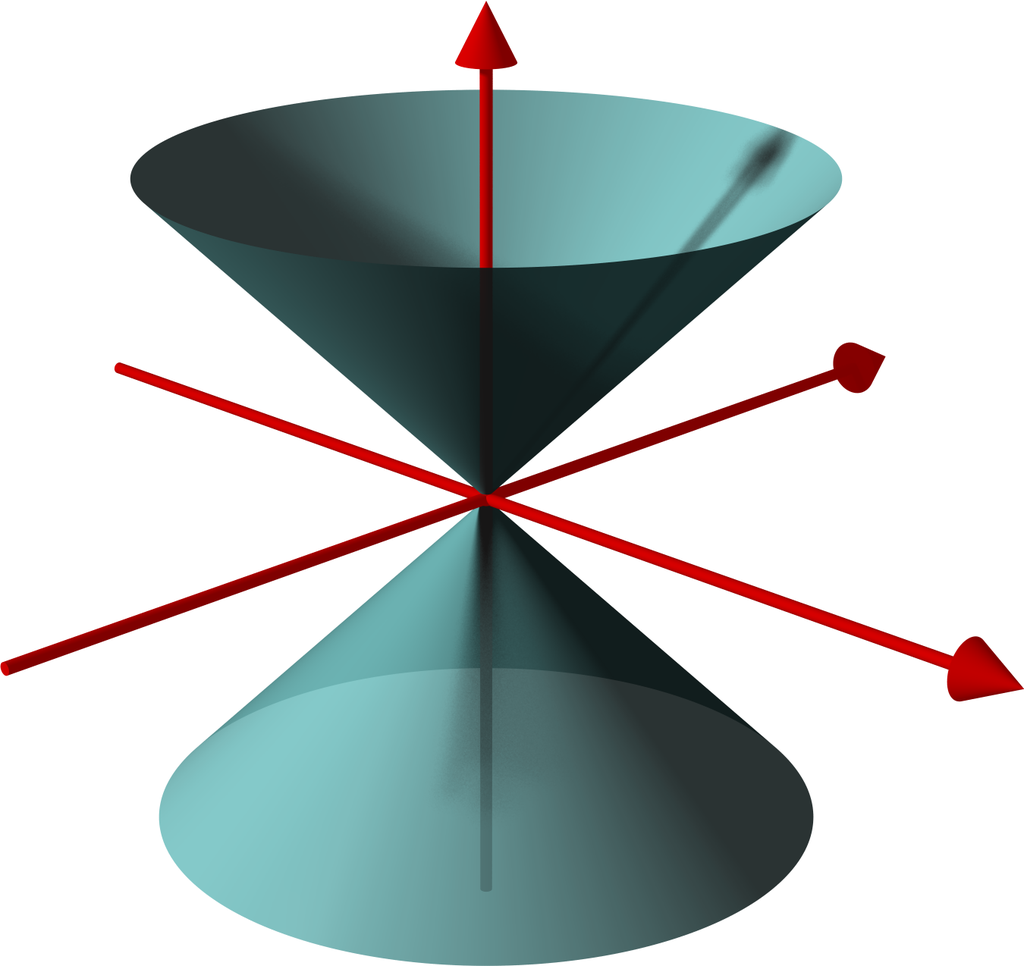

Kerucut standar

*Kerucut standar* dalam ruang afin berdimensi tiga diberikan oleh persamaan homogen

$$Z^2=X^2+Y^2.$$

Hal ini dapat dibayangkan dengan menganggap bahwa $z$ menentukan jari-jari suatu lingkaran yang terletak pada bidang sejajar bidang $x$-$y$ dan melalui titik $(0,0,z)$. Setiap irisan kerucut ini dengan suatu bidang afin $E$ disebut *irisan kerucut*.

[figure not shown]

Irisan-irisan kerucut standar dengan bidang-bidang afin

### [Definisi: irisan kerucut](https://de.wikiversity.org/wiki/Algebraische_Kurven/Kegelschnitt_mit_Standardkegel/Definition)

Suatu *irisan kerucut* $C$ adalah irisan kerucut standar $V(Z^2-X^2-Y^2)$ dengan suatu bidang afin $V(aX+bY+cZ+d)$, dengan $a,b,c$ tidak semuanya nol; jadi,

$$C=V(Z^2-X^2-Y^2)\cap V(aX+bY+cZ+d).$$

Teori irisan kerucut merupakan topik klasik yang telah dibahas dalam sebuah karya oleh [Apollonios dari Perga](https://de.wikipedia.org/wiki/Apollonios_von_Perge). Karena bidang itu diberikan oleh persamaan

$$aX+bY+cZ+d=0,$$

kita dapat menyelesaikannya secara linear terhadap salah satu variabel dan memperoleh persamaan baru dalam dua variabel bagi irisan kerucut tersebut. Ini merupakan substitusi variabel afin-linear, sehingga persamaan baru itu juga berderajat dua.

Oleh karena itu, kita meninjau *kuadrik afin* dalam dua variabel secara umum.

### [Definisi: kuadrik dalam dua variabel](https://de.wikiversity.org/wiki/Ebene_algebraische_Kurven/Quadrik_in_zwei_Variablen/Polynom_und_Nullstelle/Definition)

Suatu polinom berbentuk

$$F=\alpha X^2+\beta XY+\gamma Y^2+\delta X+\epsilon Y+\eta,
\qquad
\alpha,\beta,\gamma,\delta,\epsilon,\eta\in K,$$

dengan sekurang-kurangnya satu di antara koefisien $\alpha,\beta,\gamma$ tidak nol, disebut *bentuk kuadratik dalam dua variabel* (di atas $K$), atau *kuadrik dalam dua variabel*. Lokus nol yang bersesuaian

$$V(F)\subseteq\mathbb A_K^2$$

juga disebut *kuadrik*.

Kita ingin mengetahui berapa banyak tipe kuadrik yang berbeda. Jawabannya bergantung pada lapangan dasar. Selain itu, kita harus menentukan konsep ekuivalensi mana yang hendak digunakan. Untuk dua kuadrik

$$F,G\in K[X,Y],$$

konsep-konsep ekuivalensi berikut layak dipelajari.

1. $F$ dan $G$, sebagai polinom, *ekuivalen secara afin*: terdapat suatu transformasi variabel afin-linear (bijektif)

   $$\begin{aligned}
   \varphi:K[X,Y]&\longrightarrow K[X,Y],\\
   X&\longmapsto rX+sY+t,\\
   Y&\longmapsto \widetilde rX+\widetilde sY+\widetilde t,
   \end{aligned}$$

   sedemikian sehingga $G=\varphi(F)$.
2. Ideal-ideal utama $(F)$ dan $(G)$ *ekuivalen secara afin*: terdapat suatu transformasi variabel afin-linear (bijektif) $\varphi$ sedemikian sehingga

   $$(G)=(\varphi(F)).$$
3. Gelanggang-gelanggang faktor

   $$K[X,Y]/(F)\qquad\text{dan}\qquad K[X,Y]/(G)$$

   isomorfik sebagai [$K$-aljabar](https://de.wikiversity.org/wiki/Kommutative_Ringtheorie/Algebra/Ringhomomorphismus/Definition).
4. Lokus-lokus nol $V(F)$ dan $V(G)$ [ekuivalen secara afin-linear](https://de.wikiversity.org/wiki/Affin-algebraische_Mengen/Affin-linear_%C3%A4quivalent/Definition).

Konsep ekuivalensi pertama lebih kuat daripada yang kedua, dan yang kedua lebih kuat daripada kedua konsep terakhir. Perbedaan penting antara (1) dan (2) ialah bahwa pada (2) kita selalu boleh mengalikan dengan suatu satuan (hal ini juga tidak mengubah lokus nol). Di atas lapangan yang tidak tertutup secara aljabar, ekuivalensi dalam (4) dapat menjadi sangat kasar, sebab semua $F$ dengan lokus nol kosong ekuivalen dalam pengertian (4).

Untuk $K=\mathbb R$ dan $K=\mathbb C$, kita juga tertarik pada kesesuaian sifat-sifat topologis dari lokus-lokus nol yang bersesuaian. Di sini kita akan meninjau berbagai konsep ekuivalensi bagi dua kuadrik $F$ dan $G$ secara paralel, tetapi perhatian utama kita tertuju pada (2).

### [Lema: reduksi pertama kuadrik afin](https://de.wikiversity.org/wiki/Affine_Quadriken_in_zwei_Variablen/Erste_Reduktion/Fakt)

Misalkan $K$ suatu [lapangan](https://de.wikiversity.org/wiki/K%C3%B6rpertheorie_%28Algebra%29/K%C3%B6rper/Direkt/Definition) dengan [karakteristik](https://de.wikiversity.org/wiki/K%C3%B6rpertheorie_%28Algebra%29/Charakteristik/1/Definition) $\ne2$, dan misalkan

$$F=\alpha X^2+\beta XY+\gamma Y^2+\delta X+\epsilon Y+\eta$$

suatu kuadrik. Maka terdapat suatu [transformasi variabel](https://de.wikiversity.org/wiki/Affiner_Raum/Lineare_Variablentransformation/Definition) pada bidang afin sedemikian sehingga polinom yang ditransformasikan, dalam variabel-variabel baru, berbentuk

$$G=\gamma Y^2+H(X),
\qquad
H(X)=aX^2+bX+c,$$

dengan $\gamma\ne0$. Jika $a\ne0$, kita dapat mencapai $b=0$.

Di atas suatu [lapangan tertutup secara aljabar](https://de.wikiversity.org/wiki/K%C3%B6rpertheorie_%28Algebra%29/Algebraisch_abgeschlossen/Definition), kita dapat mencapai $\gamma=1$ melalui suatu transformasi variabel.

Jika yang diperhatikan adalah ideal yang dibangkitkan atau lokus nolnya, kita juga dapat mencapai $\gamma=1$ melalui pembagian.

#### [Bukti](https://de.wikiversity.org/wiki/Affine_Quadriken_in_zwei_Variablen/Erste_Reduktion/Fakt/Beweis)

Pertama-tama kita mereduksi ke kasus $\gamma\ne0$. Jika $\gamma=0$ dan $\alpha\ne0$, kita dapat mempertukarkan $X$ dan $Y$. Jika $\alpha=\gamma=0$, haruslah $\beta\ne0$. Dalam hal ini, melalui

$$X\longmapsto X+Y,
\qquad
Y\longmapsto Y,$$

kita dapat membuat koefisien $Y^2$ menjadi tidak nol. Jadi, selanjutnya kita mengandaikan bahwa $\gamma\ne0$.

Kita menulis polinom itu sebagai

$$\gamma Y^2+(\beta X+\epsilon)Y+\widetilde H(X),$$

dengan $\widetilde H$ suatu polinom dalam $X$ berderajat $\le2$. Dengan melengkapkan kuadrat, ungkapan ini dapat ditulis sebagai

$$\gamma\left(Y+\frac{\beta X+\epsilon}{2\gamma}\right)^2
+\widetilde H(X)-\frac{(\beta X+\epsilon)^2}{4\gamma}.$$

Dalam variabel-variabel baru

$$Y+\frac{\beta X+\epsilon}{2\gamma}
\qquad\text{dan}\qquad
X,$$

persamaan tersebut berbentuk

$$G=\gamma Y^2+H(X),
\qquad
H(X)=aX^2+bX+c.$$

Jika $K$ tertutup secara aljabar, $\gamma$ mempunyai akar kuadrat, sehingga melalui $Y\mapsto Y/\sqrt\gamma$ koefisien itu dapat dibuat menjadi $1$. Pernyataan tambahan yang lain jelas. $\square$

## Klasifikasi kuadrik real dan kompleks

### [Contoh: klasifikasi kuadrik real](https://de.wikiversity.org/wiki/Affine_Quadriken_in_zwei_Variablen/Reell/Klassifizierung/Beispiel)

Misalkan $K=\mathbb R$. Kita ingin mengklasifikasikan kuadrik-kuadrik real, terutama berkenaan dengan ekuivalensi afin-linear dari ideal-ideal utama yang dibangkitkannya. Dengan kata lain, kita boleh melakukan transformasi variabel afin dan membagi dengan $-1$. Berdasarkan Lema 7.3, kita dapat mengandaikan bahwa persamaan yang mendeskripsikannya berbentuk

$$Y^2=aX^2+bX+c.$$

Jika $a=b=0$, melalui transformasi $Y\mapsto\sqrt cY$ untuk $c>0$, atau $Y\mapsto\sqrt{-c}Y$ untuk $c<0$, lalu membagi dengan $\pm c$, kita dapat membuat ruas kanan menjadi $1$, $-1$, atau $0$.

Jika $a=0$ dan $b\ne0$, kita dapat mengambil $bX+c$ sebagai variabel baru dan memperoleh persamaan

$$Y^2=X.$$

Sekarang misalkan $a\ne0$. Melalui transformasi $X\mapsto X/\sqrt a$ atau $X\mapsto X/\sqrt{-a}$, kita dapat mencapai $a=\pm1$. Dengan melengkapkan kuadrat, kita dapat membuat $b=0$. Jika $c=0$, kita dapat mentransformasikan persamaan itu menjadi

$$Y^2=\pm X^2.$$

Jadi, misalkan $c\ne0$. Melalui transformasi serentak

$$X\longmapsto uX,
\qquad
Y\longmapsto uY,
\qquad
u=\sqrt{\pm c},$$

dan pembagian setelahnya, kita dapat mencapai $c=\pm1$. Dengan demikian, kemungkinan yang masih harus ditinjau adalah

$$Y^2=\pm X^2\pm1,$$

dengan kedua persamaan

$$Y^2-X^2=\pm1$$

saling ekuivalen.

Jadi, kita mengetahui bahwa setiap kuadrik real dapat dibawa ke salah satu dari sembilan bentuk berikut.

I. $Y^2=0$. Ini adalah suatu *garis rangkap*.

2. $Y^2=1$. Ini berarti $Y=\pm1$, jadi merupakan *dua garis sejajar*.
3. $Y^2=-1$. Lokus ini *kosong*.
4. $Y^2=X$. Ini adalah suatu *parabola*.

V. $Y^2=X^2$. Ini berarti $(Y-X)(Y+X)=0$, jadi merupakan *dua garis yang berpotongan*.

6. $Y^2=-X^2$. Satu-satunya solusi adalah *titik* $(0,0)$.
7. $Y^2=X^2+1$. Ini berarti $(Y-X)(Y+X)=1$, jadi merupakan suatu *hiperbola*.
8. $Y^2=-X^2+1$. Ini adalah suatu *lingkaran satuan*.
9. $Y^2=-X^2-1$. Lokus ini kembali *kosong*.

Apakah kesembilan tipe ini semuanya saling berbeda? Jawabannya bergantung pada konsep ekuivalensi yang digunakan. Tipe III dan IX keduanya kosong, sehingga mempunyai lokus nol yang identik. Di sisi lain, gelanggang-gelanggang hasil bagi yang bersesuaian

$$\mathbb R[X,Y]/(Y^2+1)
\qquad\text{dan}\qquad
\mathbb R[X,Y]/(X^2+Y^2+1)$$

tidak isomorfik, dan di atas bilangan kompleks lokus-lokus nolnya tidak sama. Karena itu, di sini keduanya juga dipandang berbeda. Selain itu, lokus-lokus nol tersebut pada umumnya sudah berbeda karena alasan topologis. Sebagai contoh, lingkaran satuan [kompak](https://de.wikiversity.org/wiki/Topologie/Grundbegriffe/Kompaktheit/%C3%9Cberdeckungskompakt/Definition), hiperbola tidak kompak dan mempunyai dua komponen terhubung, sedangkan parabola tidak kompak dan mempunyai satu komponen terhubung, dan seterusnya.

Namun, garis rangkap dan parabola sama secara topologis-real, demikian pula hiperbola dan kedua garis sejajar. Dalam tiap pasangan ini, gelanggang hasil baginya berbeda; pada pasangan kedua, versi kompleksnya juga berbeda. Sebagai contoh, $K[X,Y]/(Y^2)$ bukan gelanggang tereduksi, sedangkan

$$K[X,Y]/(Y^2-X)\cong K[Y]$$

merupakan domain integral. Hiperbola kompleks terhubung karena isomorfik dengan

$$\mathbb C^\times=\mathbb C\setminus\{0\},$$

yakni dengan garis kompleks tertusuk $\mathbb A_{\mathbb C}^1\setminus\{0\}$.

Gambar-gambar berikut menunjukkan rotasi dan translasi suatu kuadrik.

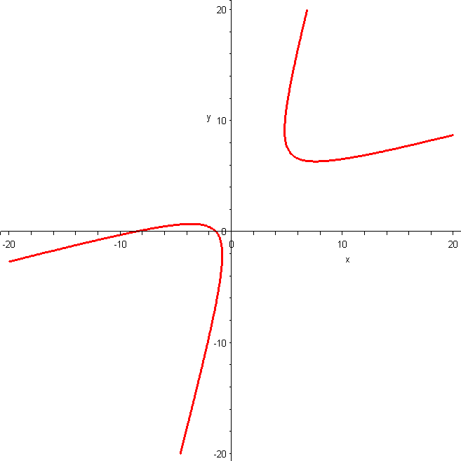

Tahap pertama transformasi sumbu utama suatu kuadrik

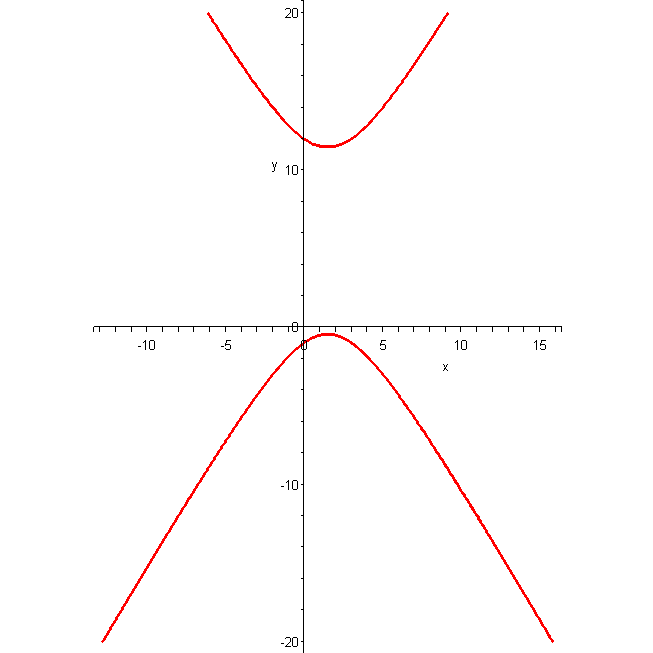

Tahap kedua transformasi sumbu utama suatu kuadrik

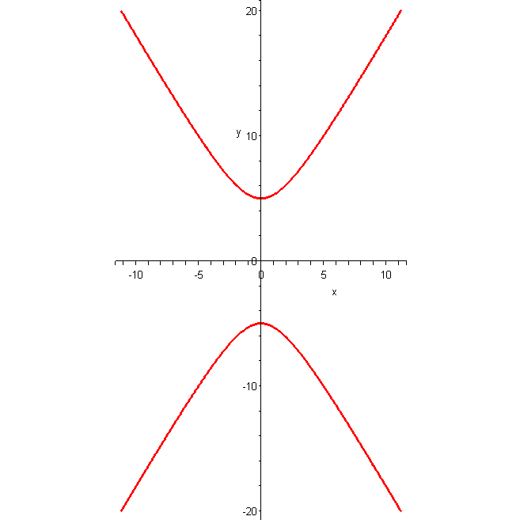

Tahap ketiga transformasi sumbu utama suatu kuadrik

### [Contoh: klasifikasi kuadrik kompleks](https://de.wikiversity.org/wiki/Affine_Quadriken_in_zwei_Variablen/Komplex/Klassifizierung/Beispiel)

Misalkan $K=\mathbb C$. Kita ingin mengklasifikasikan kuadrik-kuadrik kompleks. Berdasarkan Lema 7.3, kita dapat mengandaikan bahwa persamaan yang mendeskripsikannya berbentuk

$$Y^2=aX^2+bX+c.$$

Jika $a=b=0$ dan $c=0$, kita mempertahankan persamaan $Y^2=0$. Jika $a=b=0$ dan $c\ne0$, melalui penskalaan variabel $Y$ dan pembagian dengan konstanta tak nol, kita dapat membuat persamaannya menjadi $Y^2=1$.

Jika $a=0$ dan $b\ne0$, kita dapat mengambil $bX+c$ sebagai variabel baru dan memperoleh persamaan

$$Y^2=X.$$

Sekarang misalkan $a\ne0$. Melalui transformasi $X\mapsto X/\sqrt a$, kita dapat mencapai $a=1$. Dengan melengkapkan kuadrat, kita dapat membuat $b=0$. Akhirnya, melalui transformasi serentak $X\mapsto uX$, $Y\mapsto uY$, lalu melakukan pembagian, kita dapat mencapai $c=1$ apabila $c\ne0$; apabila $c=0$, bentuk $Y^2=X^2$ dipertahankan.

> **Catatan edisi:** Pada kedua langkah normalisasi di atas, sumber memakai penskalaan atau pembagian yang memerlukan $c\ne0$ tanpa memisahkan kasus $c=0$. Edisi ini memisahkannya secara eksplisit: $c=0$ menghasilkan bentuk I ketika $a=b=0$, dan bentuk IV, $Y^2=X^2$, ketika $a\ne0$.

Jadi, kita mengetahui bahwa setiap kuadrik kompleks dapat dibawa ke salah satu dari lima bentuk berikut.

I. $Y^2=0$. Ini adalah suatu *garis rangkap*.

2. $Y^2=1$. Ini berarti $Y=\pm1$, jadi merupakan *dua garis kompleks sejajar*.
3. $Y^2=X$. Ini adalah suatu *parabola kompleks*.
4. $Y^2=X^2$. Ini berarti $(Y-X)(Y+X)=0$, jadi merupakan *dua garis kompleks* yang berpotongan di satu titik.

V. $Y^2=X^2+1$. Ini berarti $(Y-X)(Y+X)=1$, jadi merupakan suatu *hiperbola kompleks*.

Ditinjau secara topologis-kompleks, Tipe I dan Tipe III merupakan suatu garis afin kompleks, jadi suatu bidang real, dan dengan demikian keduanya sama secara topologis. Menyebutnya “bidang kompleks” berbahaya dalam konteks geometri aljabar, sebab istilah itu dapat berarti $\mathbb C$ atau $\mathbb C^2$. Akan tetapi, gelanggang-gelanggang faktornya berbeda, sehingga keduanya dicantumkan sebagai tipe yang berbeda. Selain itu, semua tipe saling berbeda secara topologis-kompleks. Di samping bidang real, kita mempunyai garis afin kompleks tertusuk (hiperbola, yang secara topologis merupakan bidang real tertusuk), dua garis yang saling lepas, dan dua garis yang berpotongan di satu titik.

Klasifikasi kuadrik kompleks yang disajikan dalam contoh terakhir berlaku di atas setiap lapangan tertutup secara aljabar yang berkarakteristik $\ne2$.

## Parametrisasi kuadrik

Dalam teori bilangan elementer, kita mempelajari cara mendapatkan semua tripel Pythagoras secara sistematis. Alasannya adalah bahwa lingkaran satuan mempunyai parametrisasi oleh fungsi-fungsi rasional. Sekarang, sebagai generalisasi dari [Soal 1.28](https://de.wikiversity.org/wiki/Einheitskreis/Rationale_Parametrisierung/Funktionaler_Ausdruck/Aufgabe), kita menunjukkan bahwa setiap kuadrik tak tereduksi dapat diparameterkan secara rasional.

### [Teorema: parametrisasi rasional kuadrik](https://de.wikiversity.org/wiki/Quadrik_in_zwei_Variablen/Rationale_Parametrisierung/Fakt)

Misalkan

$$C=V(F)$$

suatu kuadrik dalam dua variabel, yakni

$$F=\alpha X^2+\beta XY+\gamma Y^2+\delta X+\epsilon Y+\eta,$$

dengan $\alpha,\beta,\gamma$ tidak semuanya nol. Andaikan sekurang-kurangnya terdapat satu titik pada kuadrik tersebut. Maka terdapat polinom-polinom

$$P_1,P_2,Q\in K[T],
\qquad
Q\ne0,$$

sedemikian sehingga citra pemetaan rasional

$$\begin{aligned}
\mathbb A_K^1\supseteq D(Q)&\longrightarrow\mathbb A_K^2,\\
t&\longmapsto
\left(\frac{P_1(t)}{Q(t)},\frac{P_2(t)}{Q(t)}\right)
\end{aligned}$$

terletak dalam $C$.

Jika $C$ mempunyai sekurang-kurangnya dua titik, pemetaan tersebut tidak konstan dan injektif kecuali untuk berhingga banyak pengecualian.

Jika, selain itu, $C$ [tak tereduksi](https://de.wikiversity.org/wiki/Affine_Variet%C3%A4ten/Affin-algebraische_Mengen/Irreduzibel/Definition), pemetaan tersebut surjektif kecuali untuk berhingga banyak pengecualian. Khususnya, suatu kuadrik tak tereduksi dengan sekurang-kurangnya dua titik merupakan suatu [kurva rasional](https://de.wikiversity.org/wiki/Ebene_algebraische_Kurven/Rationale_Kurve/Definition).

#### [Bukti](https://de.wikiversity.org/wiki/Quadrik_in_zwei_Variablen/Rationale_Parametrisierung/Fakt/Beweis)

Melalui suatu transformasi variabel, kita dapat mencapai $\alpha\ne0$. Lalu kita dapat membagi dengan $\alpha$ dan mengandaikan bahwa $\alpha=1$. Melalui translasi, kita dapat mengandaikan bahwa titik asal $0=(0,0)$ terletak pada kurva. Maka $\eta=0$. Jika kuadrik itu terdiri atas dua garis yang berpotongan, kita dapat melakukan translasi agar titik asal bukan titik perpotongannya (tetapi tetap terletak pada salah satu garis).

Gagasannya adalah, untuk suatu titik

$$H=(t,1),$$

kita meninjau garis yang melalui $0$ dan $H$, lalu meninjau irisan garis ini dengan $C$. Irisan tersebut terdiri atas paling banyak dua titik (kecuali jika irisannya adalah seluruh garis). Karena $0$ merupakan salah satu titik itu, titik lain yang harus ada ditentukan secara tunggal.

Jadi, misalkan $H=(t,1)$ diberikan. Garis melalui $H$ dan $0$ terdiri atas semua titik

$$(at,a),
\qquad
a\in K.$$

Titik-titik irisannya dengan $C$ diperoleh dengan menyubstitusikan $(x,y)=(at,a)$ ke dalam $F$ dan mencari solusi-solusinya terhadap $a$. Substitusi memberikan syarat

$$F(at,a)=(at)^2+\beta(at\,a)+\gamma a^2+\delta at+\epsilon a.$$

Solusi $a=0$ bersesuaian dengan titik asal yang sudah kita ketahui. Solusi kedua adalah

$$a_2=\frac{-\delta t-\epsilon}{t^2+\beta t+\gamma}.$$

Ungkapan ini terdefinisi jika

$$Q(t)=t^2+\beta t+\gamma\ne0,$$

yang mengecualikan paling banyak dua nilai $t$. Titik pada $C$ yang bersesuaian dengan $a_2$ adalah

$$\begin{aligned}
a_2(t,1)
&=(a_2t,a_2)\\
&=\left(
t\frac{-\delta t-\epsilon}{t^2+\beta t+\gamma},
\frac{-\delta t-\epsilon}{t^2+\beta t+\gamma}
\right).
\end{aligned}$$

Karena itu, kita harus menetapkan

$$P_1=-t(\delta t+\epsilon),
\qquad
P_2=-\delta t-\epsilon.$$

Pemetaan ini terdefinisi dengan baik pada himpunan terbuka Zariski $D(Q)$ (dan himpunan ini tidak kosong segera setelah lapangan tersebut mempunyai sekurang-kurangnya tiga elemen).

Mulai sekarang, andaikan $C$ mempunyai sekurang-kurangnya dua titik. Jika $\delta=\epsilon=0$, maka $F$ berbentuk

$$F=X^2+\beta XY+\gamma Y^2.$$

Karena kita mengandaikan bahwa terdapat sekurang-kurangnya dua titik pada $C$, maka $F$ merupakan hasil kali dua bentuk linear homogen (yang ternormalkan terhadap $X$). Jika $F$ merupakan kuadrat suatu bentuk linear, secara geometris kita hanya mempunyai suatu “garis rangkap”, yang dapat langsung diparameterkan secara bijektif. Jika tidak, $F$ merupakan hasil kali dua bentuk linear homogen yang berbeda dan kedua garis yang bersesuaian melalui titik asal, sesuatu yang telah kita kecualikan. Jadi, dalam kasus ini $\delta$ dan $\epsilon$ tidak mungkin keduanya sama dengan $0$.

Dengan demikian, kita hanya perlu meninjau situasi ketika $\delta t+\epsilon$ bukan polinom nol. Dari sini, pemetaan pada domain definisinya injektif kecuali untuk berhingga banyak pengecualian, sebab jika $\delta t+\epsilon\ne0$, prapeta $t$ dapat direkonstruksi dari citranya melalui

$$t=\frac{P_1}{Q}\cdot\frac{Q}{P_2}.$$

Untuk menunjukkan bahwa pemetaan tersebut surjektif kecuali untuk berhingga banyak pengecualian, kita memerlukan asumsi bahwa $C$ tak tereduksi. Secara khusus, ini berarti bahwa $C$ bukan gabungan dua garis. Misalkan $P\in C$ dan koordinat-$y$ dari $P$ tidak nol (paling banyak terdapat dua titik dengan koordinat-$y$ nol). Maka garis melalui $P$ dan $0$ mempunyai titik potong

$$H=(t,1)$$

dengan garis parametrisasi $V(Y-1)$. Kecuali untuk berhingga banyak nilai $t$, pemetaan tersebut terdefinisi di titik $H$ ini dan $P$ kemudian merupakan titik citra pemetaan. Karena ketaktereduksian, hanya berhingga banyak titik $C$ yang terletak pada garis-garis pengecualian; karena itu, hampir semua titik tercapai. $\square$

[figure not shown]

Potret seorang pria tak dikenal, dahulu disalahidentifikasi sebagai Johannes Kepler

> **Catatan penerjemah:** Sumber beku menampilkan berkas `Johannes Kepler 1610.jpg` dengan keterangan bahwa sosoknya adalah Kepler. Berkas Commons yang tersedia kini berjudul `Portrait Confused With Johannes Kepler 1610.jpg` dan mengidentifikasi sosok tersebut sebagai seorang pria tak dikenal yang dahulu disalahidentifikasi sebagai Kepler. Nama dan keterangan aset lokal telah disesuaikan secara transparan.

Irisan-irisan kerucut (yang bebas singularitas) juga merupakan lintasan gerak benda-benda langit. Kemungkinan lintasan benda langit pertama kali dideskripsikan oleh [Johannes Kepler](https://de.wikipedia.org/wiki/Johannes_Kepler). Hukum yang mendasarinya menyatakan bahwa pada setiap saat, percepatan sebanding dengan gaya gravitasi antara titik massa pusat (bintang, Matahari) dan titik massa yang bergerak (planet, komet). Gaya tarik itu sendiri bergantung pada kedua massa dan kuadrat jarak di antara keduanya. Terdapat lintasan “terikat” (elips) dan lintasan “tak terikat” (parabola, hiperbola).

Lingkaran dan elips dapat saling diubah melalui suatu transformasi variabel linear. Perhatikan bahwa parametrisasi rasional bukanlah “parametrisasi fisika”. Parametrisasi fisika benar-benar mendeskripsikan proses gerak: di sana parameternya adalah waktu dan turunan pada suatu saat merupakan kecepatan sesaat. Parametrisasi rasional “hanya” mendeskripsikan lintasan. Seperti diketahui, lingkaran dilintasi secara seragam (dengan besar kecepatan konstan) oleh

$$(x,y)=(\cos t,\sin t).$$

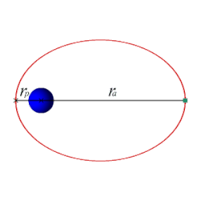

Orbit eliptik

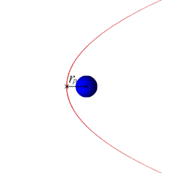

Orbit parabola

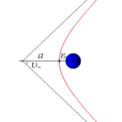

Orbit hiperbola

### [Catatan: domain parametrisasi kuadrik](https://de.wikiversity.org/wiki/Quadrik_in_zwei_Variablen/Rationale_Parametrisierung/Bemerkung)

Parametrisasi suatu kuadrik tidak bergantung pada lapangan dasar, sebab suku-suku yang mendefinisikan pemetaan selalu sama. Akan tetapi, di atas lapangan berhingga, domain definisi suatu pemetaan rasional dapat kosong. Namun, jika kita beralih ke suatu lapangan berhingga yang lebih besar $\mathbb F_q$, pemetaan tersebut selalu mempunyai domain definisi yang tidak kosong.

Secara geometris, lubang-lubang definisi dalam parametrisasi timbul karena garis-garis penghubung yang dikonstruksi dalam bukti Teorema 7.6, selain titik asal, tidak mempunyai titik potong lain dengan kuadrik; atau sebaliknya, seluruh garis itu terletak pada kuadrik (hal ini hanya mungkin dalam kasus tereduksi atau pada suatu garis rangkap). Himpunan pengecualian berupa titik-titik kuadrik yang tidak berada dalam citra pemetaan adalah titik-titik pada sumbu $x$ (khususnya titik asal), dan, dalam kasus tereduksi, titik-titik pada garis yang seluruhnya terletak pada kuadrik dan melalui titik asal.

# Lembar Kerja 7

## Soal latihan

### Soal 7.1

Tentukan irisan-irisan bola. Manakah di antaranya yang merupakan irisan kerucut?

### Soal 7.2

Tentukan irisan-irisan silinder. Manakah di antaranya yang merupakan irisan kerucut?

### Soal 7.3

Tentukan irisan-irisan kerucut yang diperoleh sebagai perpotongan dengan sebuah bidang yang melalui titik asal.

### Soal 7.4

Buktikan bahwa bidang-bidang sejajar yang keduanya tidak melalui titik asal mendefinisikan jenis irisan kerucut yang sama.

### Soal 7.5

Kita tinjau kerucut standar

$$V\left(Z^2-X^2-Y^2\right)\subset\mathbb A_{\mathbb R}^3$$

dan bidang-bidang yang melalui sumbu rotasi $V(X,Z)$. Tentukan, sebagai fungsi dari sudut rotasi $\alpha$ (diukur berlawanan arah jarum jam pada bidang $x$-$z$), jenis irisan kerucut yang diberikan oleh bidang $E_\alpha$.

### Soal 7.6

Kita tinjau kerucut standar

$$V\left(Z^2-X^2-Y^2\right)\subset\mathbb A_{\mathbb R}^3$$

dan bidang-bidang yang melalui sumbu rotasi $V(X-1,Z)$. Tentukan, sebagai fungsi dari sudut rotasi $\alpha$ (diukur berlawanan arah jarum jam pada bidang $x$-$z$), jenis irisan kerucut yang diberikan oleh bidang $E_\alpha$.

### Soal 7.7

Kita tinjau kerucut standar

$$V\left(Z^2-X^2-Y^2\right)\subset\mathbb A_{\mathbb R}^3$$

dan bidang-bidang yang melalui sumbu rotasi $V(X-1,Z-1)$. Tentukan, sebagai fungsi dari sudut rotasi $\alpha$ (diukur berlawanan arah jarum jam pada bidang $x$-$z$), jenis irisan kerucut yang diberikan oleh bidang $E_\alpha$.

### Soal 7.8

Tentukan kuadrik-kuadrik yang berkaitan dengan polinom kuadratik homogen dalam dua variabel.

### Soal 7.9

Transformasikan kuadrik

$$2x^2+xy-3y^2+5x-y+3$$

ke suatu bentuk standar real.

### Soal 7.10 ★

Tinjau kedua kuadrik

$$X^2+Y^2=1
\qquad\text{dan}\qquad
4X^2+3Y^2=9.$$

Buktikan bahwa kedua kuadrik tersebut ekuivalen secara afin-linear di atas $\mathbb R$, tetapi tidak di atas $\mathbb Q$.

**Petunjuk.** Salah satu cara pembuktian diperoleh dari [Teorema 7.2 (Teori Ukuran dan Integrasi, Osnabrück 2022-2023)](https://de.wikiversity.org/wiki/Linearer_Endomorphismus/Lineare_Transformationsformel/Fakt).

> **Catatan edisi:** Sumber menyebut kedua lokus ini “lingkaran”, tetapi $4X^2+3Y^2=9$ adalah elips, bukan lingkaran. Pernyataan ekuivalensi yang diminta tidak diubah; istilah pada kalimat tugas dikoreksi menjadi “kuadrik”.

### Soal 7.11 ★

Misalkan

$$F=(0,0)$$

adalah titik asal pada bidang real dan

$$G=V(X-1).$$

Misalkan $e>0$ suatu bilangan real. Tentukan suatu persamaan aljabar bagi himpunan titik $P=(x,y)$ yang mempunyai sifat bahwa jarak $d(P,F)$ sebanding, dengan faktor kesebandingan $\sqrt e$, dengan jarak tegak lurus $d(P,G)$.

Buktikan, dengan mentransformasikan persamaan tersebut secara tepat, bahwa untuk $e<1$ diperoleh elips, untuk $e=1$ diperoleh parabola, dan untuk $e>1$ diperoleh hiperbola.

### Soal 7.12

Parametrisasikan kuadrik yang didefinisikan oleh

$$F=2x^2-xy+3y^2+x-5y$$

dengan menggunakan titik asal dan garis $V(y-1)$.

### Soal 7.13

Tinjau kurva aljabar

$$C=V\left(X^{d+1}-Y^d\right),
\qquad d\geq1.$$

Buktikan bahwa titik asal dan garis $V(X-1)$ menghasilkan suatu parametrisasi bagi $C$ dengan metode yang dideskripsikan dalam pembuktian Teorema 7.6.

Dalam soal-soal berikut, kita membahas suatu konsep automorfisme yang melampaui perubahan koordinat afin-linear.

Misalkan $K$ suatu lapangan. Suatu pemetaan polinomial

$$\varphi:\mathbb A_K^n\longrightarrow\mathbb A_K^n$$

disebut suatu **automorfisme (polinomial) ruang afin** jika pemetaan tersebut mempunyai invers polinomial.

Suatu automorfisme ruang afin sama dengan suatu automorfisme aljabar-$K$ dari gelanggang polinomial $K[X_1,\ldots,X_n]$ ke dirinya sendiri. Automorfisme ini diberikan oleh $n$ polinom dalam $n$ variabel.

### Soal 7.14

Buktikan bahwa suatu automorfisme aljabar-$K$

$$\varphi:K[X]\longrightarrow K[X]$$

diberikan oleh

$$X\longmapsto aX+b,
\qquad a\ne0,$$

yaitu oleh suatu transformasi variabel afin-linear.

### Soal 7.15

Berikan contoh suatu pemetaan polinomial bijektif

$$\mathbb A_K^1\longrightarrow\mathbb A_K^1$$

yang pemetaan inversnya tidak polinomial.

> **Catatan edisi:** Keberadaan contoh bergantung pada lapangan $K$. Misalnya, untuk $K=\mathbb R$, pemetaan $x\mapsto x^3$ bersifat bijektif, sedangkan inversnya $x\mapsto\sqrt[3]{x}$ bukan polinomial. Di atas $\mathbb C$, setiap pemetaan polinomial bijektif pada garis afin berderajat satu.

### Soal 7.16

Misalkan $F\in K[X]$ suatu polinom. Buktikan bahwa pemetaan

$$\begin{aligned}
\mathbb A_K^2&\longrightarrow\mathbb A_K^2,\\
(x,y)&\longmapsto(x,y+F(x))
\end{aligned}$$

merupakan automorfisme ruang afin. Tentukan suatu pemetaan invers secara eksplisit.

### Soal 7.17

Tentukan pemetaan invers dari pemetaan

$$\begin{aligned}
\mathbb R^2&\longrightarrow\mathbb R^2,\\
(x,y)&\longmapsto
\left(x+y^2,-y^4-2xy^2-x^2+y^2+x+y\right).
\end{aligned}$$

### Soal 7.18

Misalkan

$$\varphi:\mathbb A_{\mathbb C}^n\longrightarrow\mathbb A_{\mathbb C}^n$$

suatu automorfisme ruang afin. Buktikan bahwa determinan Jacobi dari $\varphi$ konstan dan sama dengan suatu $c\ne0$.

**Masalah Jacobi** menanyakan apakah suatu pemetaan polinomial

$$\varphi:\mathbb A_{\mathbb C}^n\longrightarrow\mathbb A_{\mathbb C}^n,$$

yang determinan Jacobinya konstan sama dengan $1$, mempunyai pemetaan invers polinomial, yaitu merupakan automorfisme ruang afin. Masalah ini masih terbuka bahkan untuk $n=2$. Berdasarkan teorema pemetaan invers, di bawah asumsi yang diberikan terdapat pemetaan invers terdiferensial secara lokal di setiap titik.

Dua himpunan aljabar afin

$$V,\widetilde V\subseteq\mathbb A_K^n$$

disebut **ekuivalen secara afin-aljabar** jika terdapat suatu automorfisme ruang afin

$$\varphi:\mathbb A_K^n\longrightarrow\mathbb A_K^n$$

sedemikian sehingga

$$\varphi^{-1}(V)=\widetilde V.$$

### Soal 7.19

Misalkan $F\in K[X]$ suatu polinom dan

$$C=V(Y-F(X))\subset\mathbb A_K^2$$

grafik yang bersesuaian. Buktikan bahwa $C$ ekuivalen secara afin-aljabar dengan sumbu $x$

$$V(Y)\subset\mathbb A_K^2,$$

tetapi secara umum tidak ekuivalen secara afin-linear dengannya.

### Soal 7.20

Misalkan

$$V,\widetilde V\subset\mathbb A_K^n$$

dua himpunan aljabar afin yang ekuivalen secara afin-aljabar, dengan ideal lenyap $\operatorname{Id}(V)$ dan $\operatorname{Id}(\widetilde V)$. Buktikan bahwa gelanggang-gelanggang faktor

$$K[X_1,\ldots,X_n]/\operatorname{Id}(V)$$

dan

$$K[X_1,\ldots,X_n]/\operatorname{Id}(\widetilde V)$$

saling isomorfik.

### Soal 7.21

Kuadrik-kuadrik manakah di $\mathbb R^2$ (di $\mathbb C^2$) yang saling ekuivalen secara afin-aljabar?

### Soal 7.22 ★

Untuk kuadrik rasional

$$C=V\left(X^2+Y^2-5\right)\subset\mathbb A_{\mathbb Q}^2,$$

lakukan suatu parametrisasi rasional dalam pengertian Teorema 7.6, dengan titik bantu $(1,2)$ dan sebuah garis yang sesuai yang melaluinya.

### Soal 7.23

Misalkan $p$ suatu bilangan prima dengan

$$p\bmod4=3.$$

Dengan merujuk pada [Teorema 9.10 (Teori Bilangan, Osnabrück 2025)](https://de.wikiversity.org/wiki/Zahlentheorie/Summe_von_Quadraten/Charakterisierung/Fakt), jelaskan mengapa kuadrik rasional

$$C=V\left(X^2+Y^2-p\right)\subset\mathbb A_{\mathbb Q}^2$$

kosong.

### Soal 7.24

Misalkan $R$ suatu domain integral dan $r\in R$ suatu elemen yang tidak mempunyai akar kuadrat di $R$. Buktikan bahwa polinom

$$X^2-r\in R[X]$$

tak tereduksi.

### Soal 7.25

Misalkan $R$ suatu domain integral dengan $2\ne0$, dan misalkan $r\in R$ suatu elemen yang tidak mempunyai akar kuadrat di $R$. Kita tinjau perluasan gelanggang kuadratik

$$R\subset R[X]/\left(X^2-r\right)=:S.$$

Buktikan bahwa elemen-elemen $f\in R$ yang mempunyai akar kuadrat di $S$ berbentuk

$$f=y^2$$

dengan $y\in R$, atau berbentuk

$$f=rz^2$$

dengan $z\in R$.

### Soal 7.26

Misalkan $p$ dan $q$ bilangan prima yang berbeda. Buktikan bahwa kuadrik-kuadrik yang didefinisikan di atas $\mathbb Q$,

$$C=V\left(X^2+Y^2-p\right),
\qquad
D=V\left(X^2+Y^2-q\right)
\subset\mathbb A_{\mathbb Q}^2,$$

tidak ekuivalen secara afin-linear.

> **Catatan edisi:** Klaim universal pada sumber tidak benar sebagaimana tertulis. Untuk $p=2$ dan $q=5$, transformasi rasional invertibel
> $$(x,y)\longmapsto\left(\frac{3x-y}{2},\frac{x+3y}{2}\right)$$
> mengalikan $x^2+y^2$ dengan $5/2$ dan karena itu memetakan $C$ ke $D$. Maka tugas pembuktian ini memerlukan hipotesis tambahan.

**Petunjuk sumber, dengan notasi gelanggang dikoreksi.** Terapkan Soal 7.25 pada

$$R=\mathbb Q[Y]$$

dan

$$S=(\mathbb Q[Y])[X]/\left(X^2+Y^2-p\right).$$

> **Catatan edisi:** Petunjuk beku mengganti $\mathbb Q$ dengan $K$ tanpa penjelasan dan menuliskan $X^2-Y^2+p$, yang bukan persamaan koordinat $C$. Perbaikan notasi di atas menyamakan $S$ dengan gelanggang koordinat $C$; perbaikan itu tidak menghilangkan kontra-contoh terhadap klaim universal.

## Soal untuk dikumpulkan

### Soal 7.27 - 6 poin

Untuk [berbagai kuadrik real](https://de.wikiversity.org/wiki/Affine_Quadriken_in_zwei_Variablen/Reell/Klassifizierung/Beispiel), temukan suatu realisasi sebagai irisan kerucut, yaitu sebagai perpotongan sebuah bidang dengan kerucut

$$V(x^2+y^2-z^2),$$

atau buktikan bahwa realisasi semacam itu tidak ada.

### Soal 7.28 - 9 poin

Tinjau pemetaan

$$\begin{aligned}
\mathbb A_K^2&\longrightarrow\mathbb A_K^2,\\
(u,v)&\longmapsto(u^2+uv,v-u^2)=(x,y).
\end{aligned}$$

Untuk ketiga keluarga garis sejajar berikut, tentukan kurva citra setiap garis di bawah pemetaan ini; berikan baik suatu parametrisasi maupun suatu persamaan kurva.

1. Garis-garis yang sejajar dengan sumbu $u$.
2. Garis-garis yang sejajar dengan sumbu $v$.
3. Garis-garis yang sejajar dengan antidiagonal.

Sketsakan pula kurva-kurva citra yang tipikal untuk $K=\mathbb R$. Untuk setiap keluarga, tentukan apakah kurva-kurva citranya saling berpotongan.

### Soal 7.29 - 4 poin

Misalkan

$$F,G\in K[X_1,\ldots,X_n]$$

polinom-polinom dan $K\subseteq L$ suatu perluasan lapangan. Bahas bagaimana berbagai pengertian ekuivalensi dari kuliah ketujuh untuk $F$ dan $G$ (serta untuk $V(F)$ dan $V(G)$) berperilaku terhadap perluasan lapangan tersebut.

### Soal 7.30 - 6 poin

Kita tinjau kedua gelanggang faktor

$$R=\mathbb R[X,Y]/(X^2+Y^2-1)
\qquad\text{dan}\qquad
S=\mathbb R[X,Y]/(XY-1).$$

Buktikan bahwa $S$ merupakan daerah ideal utama, sedangkan $R$ bukan.

(Ini adalah gelanggang-gelanggang yang berkaitan dengan lingkaran real dan hiperbola real.)

**Petunjuk.** Untuk $R$, tinjaulah ideal $(X-1,Y)$.

### Soal 7.31 - 4 poin

Parametrisasikan kuadrik

$$C=V(F),
\qquad
F=x^2+2xy-y^2+x-3y+4,$$

dengan menggunakan titik $(1,2)\in C$ dan sumbu $y$. Jangan lakukan transformasi variabel.

### Soal 7.32 - 6 poin

Tinjau kedua himpunan nol di $\mathbb A_{\mathbb R}^2$

$$K=V\left(X^2+Y^2-1\right)
\qquad\text{dan}\qquad
C=V\left(X^4+Y^4-1\right).$$

Buktikan bahwa terdapat suatu pemetaan polinomial dalam dua variabel yang memetakan salah satu himpunan nol tersebut secara surjektif ke yang lain. Buktikan bahwa pemetaan ini sudah terdefinisi di atas $\mathbb Q$, tetapi tidak surjektif di sana. Buktikan lebih lanjut bahwa di atas $\mathbb Q$ sama sekali tidak terdapat pemetaan polinomial surjektif dari $C$ ke $K$, dan bahwa hanya terdapat pemetaan polinomial konstan dari $K$ ke $C$.

### Soal 7.33 - 6 poin

Misalkan $K$ suatu lapangan tertutup secara aljabar dan $F\in K[X,Y]$ suatu polinom tak tereduksi. Buktikan bahwa kurva $V(F)$ rasional tepat ketika terdapat suatu homomorfisme aljabar-$K$ injektif

$$Q(K[X,Y]/(F))\longrightarrow K(T).$$

Di sini ruas kiri adalah lapangan hasil bagi dan ruas kanan adalah lapangan fungsi rasional.

**Navigasi sumber:** Kuliah 7 - solusi publik Unit 7 - Lembar Kerja 6 - Lembar Kerja 8 (sumber)

# Solusi Publik Lembar Kerja 7

Sumber hanya menyediakan solusi publik bagi Soal 7.10, 7.11, dan 7.22 pada batas revisi yang dibekukan. Tidak ada solusi tambahan yang dibuat untuk edisi ini.

## Solusi Soal 7.10

Persamaan

$$4X^2+3Y^2=9$$

ekuivalen dengan

$$\left(\frac{2}{3}X\right)^2
+\left(\frac{1}{\sqrt{3}}Y\right)^2
=1
=\widetilde X^2+\widetilde Y^2.$$

Jadi, atas $\mathbb R$,

$$\widetilde X=\frac{2}{3}X,
\qquad
\widetilde Y=\frac{1}{\sqrt{3}}Y$$

merupakan transformasi afin-linear.

Untuk kasus $\mathbb Q$, kita mengambil

$$\widetilde X=aX+bY+c$$

dan

$$\widetilde Y=dX+eY+f$$

dengan koefisien $a,b,c,d,e,f\in\mathbb Q$. Diperoleh

$$\begin{aligned}
\widetilde X^2+\widetilde Y^2
&=(aX+bY+c)^2+(dX+eY+f)^2\\
&=(a^2+d^2)X^2+(b^2+e^2)Y^2
+2(ab+de)XY+H(X,Y),
\end{aligned}$$

dengan $H\in\mathbb Q[X,Y]$ dan $\deg H\le 1$.

> **Catatan edisi:** Sumber langsung membandingkan koefisien pada langkah ini. Justifikasinya adalah bahwa ekuivalensi afin memetakan pusat unik kedua kuadrik ke pusat unik, sehingga $c=f=0$. Setelah persamaan penarikbalikan dinormalkan agar suku konstannya $-1$, kedua polinom kuadratik yang mendefinisikan lokus yang sama berimpit; perbandingan koefisien $Y^2$ kemudian memberikan persamaan berikut.

Dengan justifikasi tersebut, harus berlaku

$$b^2+e^2=\frac{1}{3}
\quad\Longleftrightarrow\quad
3(b^2+e^2)=1.$$

Dengan mengalikan kedua ruas dengan penyebut bersama, persamaan tersebut dapat dibawa ke bentuk

$$3(r^2+s^2)=t^2,$$

dengan $r,s,t\in\mathbb Z$. Kita akan menunjukkan bahwa persamaan ini tidak mempunyai solusi bilangan bulat taktrivial. Karena ruas kiri persamaan merupakan kelipatan $3$, diperoleh $3\mid t$, sehingga $9\mid t^2$. Akibatnya, $3\mid(r^2+s^2)$. Dalam $\mathbb Z/(3)$, persamaan $r^2+s^2=0$ berlaku tepat ketika $r=0$ dan $s=0$. Oleh karena itu, $9\mid(r^2+s^2)$ dan kedua ruas persamaan dapat dibagi dengan $9$. Sekarang kita menetapkan

$$r'=\frac r3,
\qquad
s'=\frac s3,
\qquad
t'=\frac t3.$$

Argumen penurunan tak hingga menyelesaikan pembuktian.

Kembali ke Soal 7.10.

## Solusi Soal 7.11

Jarak dari $P=(x,y)$ ke titik asal adalah $\sqrt{x^2+y^2}$, sedangkan jarak tegak lurus ke garis $x=1$ adalah $\lvert x-1\rvert$. Proporsionalitas tersebut dinyatakan oleh

$$\frac{d(P,F)}{d(P,G)}=\sqrt e.$$

Jadi,

$$\sqrt{x^2+y^2}
=\sqrt e\,\lvert x-1\rvert
\quad\text{atau, secara ekuivalen,}\quad
x^2+y^2=e(x-1)^2.$$

Dengan demikian,

$$(1-e)x^2+y^2+2ex-e=0$$

merupakan persamaan aljabar bagi suatu kurva yang memuat semua titik yang memenuhi syarat tersebut. Jika $e=1$, persamaan itu menjadi

$$y^2+2ex-e=0
\quad\text{atau}\quad
x=-\frac{1}{2e}y^2+\frac{1}{2},$$

sehingga dalam kasus ini kurvanya merupakan sebuah parabola. Selanjutnya, misalkan $e\ne1$. Persamaan umum dapat diubah menjadi

$$x^2+\frac{1}{1-e}y^2+\frac{2e}{1-e}x-\frac{e}{1-e}=0$$

dan, dengan melengkapkan kuadrat, dibawa ke bentuk

$$\left(x+\frac{e}{1-e}\right)^2
+\frac{1}{1-e}y^2
-\frac{e^2}{(1-e)^2}
-\frac{e}{1-e}
=0.$$

Kita menuliskannya sebagai

$$\begin{aligned}
\left(x+\frac{e}{1-e}\right)^2+\frac{1}{1-e}y^2
&=\frac{e^2}{(1-e)^2}+\frac{e}{1-e}\\
&=\frac{e^2-e^2+e}{(1-e)^2}\\
&=:c>0.
\end{aligned}$$

Faktor $\frac{1}{1-e}$ bernilai positif untuk $e<1$ dan negatif untuk $e>1$. Dalam kasus pertama, setelah perubahan koordinat diperoleh persamaan berbentuk

$$\widetilde x^2+\widetilde y^2=c,$$

yaitu sebuah elips. Dalam kasus kedua, diperoleh

$$\widetilde x^2-\widetilde y^2=c,$$

yaitu sebuah hiperbola.

Kembali ke Soal 7.11.

## Solusi Soal 7.22

Kita menggeser titik $(1,2)$ ke titik asal dengan memperkenalkan variabel baru

$$U=X-1$$

dan

$$V=Y-2.$$

Persamaan tersebut kemudian menjadi

$$\begin{aligned}
X^2+Y^2-5
&=(U+1)^2+(V+2)^2-5\\
&=U^2+V^2+2U+4V.
\end{aligned}$$

Tuliskan kurva hasil pergeseran itu sebagai

$$\widetilde C=V\left(U^2+V^2+2U+4V\right).$$

Rumus-rumus parametrisasi dengan garis $V=1$ menghasilkan

$$P_1=-t(2t+4),$$

$$P_2=-(2t+4),$$

dan

$$Q=t^2+1.$$

Jadi, parametrisasi diberikan oleh

$$\mathbb Q\longrightarrow \widetilde C\subset\mathbb A^2_{\mathbb Q},
\qquad
t\longmapsto
\left(
\frac{-t(2t+4)}{t^2+1},
\frac{-(2t+4)}{t^2+1}
\right).$$

> **Catatan edisi:** Sumber menamai kurva antara pada koordinat $(U,V)$ dengan simbol $C$ yang sama seperti kurva semula. Simbol $\widetilde C$ dipakai di sini agar langkah pergeseran dan rumus setelah digeser kembali tidak tertukar.

Dari sini diperoleh parametrisasi bagi persamaan semula:

$$X
=-t\frac{2t+4}{t^2+1}+1
=\frac{-t^2-4t+1}{t^2+1}$$

dan

$$Y
=\frac{-(2t+4)}{t^2+1}+2
=\frac{2t^2-2t-2}{t^2+1}.$$

Kembali ke Soal 7.22.

# Kuliah 8: Kurva Aljabar yang Didefinisikan Secara Mekanis

## Kurva aljabar yang didefinisikan secara mekanis

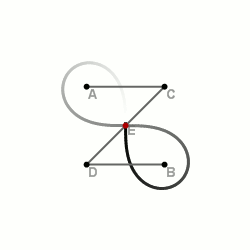

Misalkan $S$ sebuah batang kaku (bayangkan sebuah komponen mesin mekanis) dengan dua titik tetap

$$P_1,P_2\in S$$

(bayangkan sendi-sendi). Batang ini dapat bergerak dalam bidang (yakni $\mathbb R^2$), dengan syarat bahwa kedua titik tersebut masing-masing harus berada pada dua lintasan tertentu $B_1$ dan $B_2$ (bayangkan rel). Lintasan-lintasan itu dapat diberikan dengan cukup sederhana, misalnya oleh garis atau lingkaran. Pada mesin uap, sebuah roda yang dapat berputar dan sebuah rel lurus dihubungkan oleh suatu batang. Bagaimana proses gerak yang bersesuaian dideskripsikan? Apa saja *konfigurasi sistem yang diizinkan*? Karena konfigurasi semacam itu ditentukan oleh posisi kedua titik, dan masing-masing posisi diberikan oleh dua koordinat bidang, secara keseluruhan kita menghadapi situasi berdimensi empat.

Jika kita menetapkan sebuah titik $P$ pada batang (misalnya dengan memberinya warna), seperti apakah *lintasan gerak* (atau *trajektori*) titik ini dalam bidang?

Untuk kasus-kasus ekstrem

$$P=P_1
\qquad\text{dan}\qquad
P=P_2,$$

lintasan-lintasan geraknya merupakan (biasanya) subhimpunan sejati dari $B_1$ dan $B_2$. Untuk titik-titik di antaranya, kita mengharapkan suatu *deformasi kontinu* dari lintasan yang satu ke lintasan yang lain.

### [Situasi: sistem mekanis batang penghubung](https://de.wikiversity.org/wiki/Mechanische_ebene_Kurven/Stangenkoppelung/Bemerkung)

Misalkan $B_1$ dan $B_2$ dua kurva aljabar bidang yang dideskripsikan oleh persamaan $F_1=0$ dan $F_2=0$, dengan

$$F_1,F_2\in K[X,Y].$$

Misalkan $S$ suatu “garis bergerak” (sebuah batang) dengan dua titik

$$P_1,P_2\in S,
\qquad
P_1\ne P_2,$$

yang berjarak $d$ satu sama lain. *Sistem mekanis* yang diberikan oleh semua posisi $S$ dalam bidang yang sekaligus memenuhi

$$P_1\in B_1
\qquad\text{dan}\qquad
P_2\in B_2$$

dideskripsikan sebagai berikut.

Posisi batang dalam bidang ditentukan secara tunggal apabila posisi kedua titiknya telah ditentukan (ini belum memperhitungkan syarat jarak), jadi oleh empat variabel

$$(P_1,P_2)=(x_1,y_1,x_2,y_2).$$

Suatu *konfigurasi yang diizinkan* harus memenuhi tiga syarat aljabar berikut.

1. $F_1(x_1,y_1)=0$.
2. $F_2(x_2,y_2)=0$.
3. $(x_2-x_1)^2+(y_2-y_1)^2=d^2$ (syarat jarak).

Jadi, terdapat tiga persamaan aljabar dalam empat variabel; karena itu, sebagai himpunan solusi kita mengharapkan sebuah kurva dalam $\mathbb A_K^4$. Sebuah titik

$$P\in S$$

dideskripsikan melalui jaraknya dari $P_1$ atau $P_2$. Karena titik-titik ini bergerak dalam sistem mekanis, kita menetapkan koordinat *titik yang ikut bergerak* $P$ sebagai

$$P=P_1+u(P_2-P_1)$$

(jadi, jarak $P$ dari $P_1$ adalah $\lVert u(P_2-P_1)\rVert=\lvert ud\rvert$), dan menuliskan koordinatnya sebagai

$$\begin{aligned}
(x,y)
&=(x_1,y_1)+u(x_2-x_1,y_2-y_1)\\
&=(ux_2+(1-u)x_1,uy_2+(1-u)y_1).
\end{aligned}$$

Seluruh sistem mekanis kemudian dapat dinyatakan (melalui suatu transformasi linear) dalam empat variabel $x_1,y_1,x,y$. Untuk $u\ne0$, kita menyubstitusikan

$$x_2=\frac{x-(1-u)x_1}{u}
\qquad\text{dan}\qquad
y_2=\frac{y-(1-u)y_1}{u}$$

ke dalam persamaan-persamaannya. Dalam variabel-variabel baru diperoleh tiga persamaan

$$\begin{aligned}
F_1(x_1,y_1)&=0,\\
F_2\left(
\frac{x-(1-u)x_1}{u},
\frac{y-(1-u)y_1}{u}
\right)&=0,\\
(x-x_1)^2+(y-y_1)^2&=u^2d^2.
\end{aligned}$$

Pada prinsipnya, trajektori yang bersesuaian dengan $P$ dapat diperoleh dengan “mengeliminasi” variabel $x_1$ dan $y_1$ dari sistem persamaan ini, sehingga diperoleh suatu persamaan aljabar bagi $x$ dan $y$. Akan tetapi, hal ini lebih mudah dikatakan daripada dilakukan; sering kali lebih berguna untuk menyederhanakan sistem persamaan melalui manipulasi yang cerdik.

### [Catatan: bidang yang ikut bergerak](https://de.wikiversity.org/wiki/Mechanische_ebene_Kurven/Stangenkoppelung/Mitbewegte_Ebene/Bemerkung)

Kadang-kadang kita juga tertarik pada situasi ketika seluruh bidang ikut bergerak bersama batang, serta pada trajektori titik-titik dalam bidang itu. Hal ini terjadi, misalnya, apabila komponen-komponen mesin lain dipasang pada batang. Dalam kasus ini, setiap titik bidang dapat dinyatakan relatif terhadap $P_1$ dan $P_2$ sebagai

$$(x,y)
=(x_1,y_1)
+u(x_2-x_1,y_2-y_1)
+v(y_2-y_1,-x_2+x_1).$$

Jadi, titik $P_1$ diambil sebagai titik asal bidang bergerak, garis penghubung ke $P_2$ sebagai sumbu koordinat pertama, dan sumbu yang tegak lurus terhadapnya sebagai sumbu koordinat kedua.

Dengan demikian, seluruh sistem mekanis (batang) dideskripsikan oleh empat variabel dengan tiga persamaan. Namun, cara kerjanya yang terlihat, yaitu proses gerak suatu titik tetap $P$ pada $S$, menghasilkan sebuah trajektori dalam bidang afin.

Kita meninjau beberapa contoh.

## Dua garis sebagai lintasan

### [Contoh: dua garis sebagai lintasan](https://de.wikiversity.org/wiki/Mechanische_ebene_Kurven/Stangenkoppelung/Zwei_Geraden/Beispiel)

Misalkan $L_1$ dan $L_2$ dua garis dalam bidang real $\mathbb R^2$, dan misalkan $S$ sebuah garis bergerak (sebuah batang) dengan dua titik $P_1,P_2$ yang berjarak $d$ satu sama lain. Konfigurasi sistem yang diizinkan adalah posisi-posisi $S$ yang sekaligus memenuhi

$$P_1\in L_1
\qquad\text{dan}\qquad
P_2\in L_2.$$

Garis-garis tersebut ditetapkan oleh

$$L_1=\{(x,y)\mid a_1x+b_1y=c_1\}$$

dan

$$L_2=\{(x,y)\mid a_2x+b_2y=c_2\}.$$

Menurut Situasi 8.1, konfigurasi yang diizinkan ditetapkan oleh tiga syarat

$$\begin{aligned}
a_1x_1+b_1y_1&=c_1,\\
a_2x_2+b_2y_2&=c_2,\\
(x_2-x_1)^2+(y_2-y_1)^2&=d^2.
\end{aligned}$$

Himpunan solusi dari masing-masing persamaan linear merupakan subruang berdimensi tiga. Himpunan solusi persamaan ketiga dapat dipandang sebagai hasil kali sebuah lingkaran (dalam variabel $x_2-x_1$ dan $y_2-y_1$) dengan suatu bidang afin. Ini merupakan sejenis silinder, meskipun serat-seratnya berdimensi dua. Bagaimana lokus nol bersamanya dapat dideskripsikan, dan seperti apakah trajektori sistem mekanis yang dihasilkan oleh suatu titik

$$P\in S?$$

Melalui suatu transformasi variabel, kita dapat mengandaikan bahwa garis pertama adalah sumbu $x$, jadi didefinisikan oleh persamaan

$$y=0,$$

sedangkan garis yang lain didefinisikan oleh

$$ax+by=c.$$

Untuk sistem tersebut, ini memberikan syarat $y_1=0$, sehingga variabel $y_1$ dapat dieliminasi. Kita lalu memperoleh suatu sistem dengan tiga variabel $x_1,x_2,y_2$ dan dua syarat

$$\begin{aligned}
(x_2-x_1)^2+y_2^2&=d^2,\\
ax_2+by_2&=c.
\end{aligned}$$

**Garis-garis sejajar.**

Jika garis kedua sejajar dengan garis pertama, maka $a=0$, dan persamaan kedua dapat diselesaikan terhadap $y_2$, sehingga diperoleh

$$y_2=\frac cb=e$$

(dengan $b\ne0$; jika tidak, persamaan itu tidak mendefinisikan sebuah garis). Bilangan $e$ adalah jarak antara kedua garis sejajar. Sekarang $y_2$ juga dapat dieliminasi, dan yang tersisa hanyalah persamaan

$$(x_2-x_1)^2+e^2=d^2,$$

atau

$$(x_2-x_1)^2=d^2-e^2=(d-e)(d+e).$$

Jika $e>d$, persamaan ini tidak mempunyai solusi (jarak konstan antara garis-garis sejajar lebih besar daripada jarak kopling pada batang).

Jika $e=d$, diperoleh syarat

$$x_1=x_2.$$

Ini bersesuaian dengan situasi ketika jarak antara garis-garis sejajar sama dengan jarak kopling. Konfigurasi yang diizinkan hanyalah konfigurasi ketika batang tegak lurus terhadap kedua garis. Jadi, himpunan solusinya adalah sebuah garis. Bagi setiap titik pada batang, trajektorinya hanyalah sebuah garis sejajar lain.

Sekarang, misalkan $e<d$. Maka

$$x_2-x_1=\pm\sqrt{(d-e)(d+e)}.$$

Himpunan solusinya terdiri atas dua garis yang saling lepas. Ini bersesuaian dengan dua pemasangan berbeda yang tidak dapat diubah menjadi satu sama lain. Jadi, sistem mekanis tersebut terdiri atas dua komponen terhubung. Akan tetapi, untuk suatu titik pada batang, kedua pemasangan menghasilkan trajektori yang sama, yaitu sebuah garis sejajar yang, dalam pengertian tertentu, dilintasi dua kali. Dengan demikian, himpunan solusi sistem mekanis lengkap terdiri atas dua garis afin (sejajar) dalam ruang afin berdimensi empat, sedangkan trajektori-trajektorinya bagi suatu titik tetap hanya membentuk satu garis.

**Garis-garis tidak sejajar.**

Sekarang kita meninjau kasus ketika kedua garis tidak sejajar. Maka keduanya berpotongan dan himpunan solusi tidak mungkin kosong. Melalui suatu transformasi linear lebih lanjut, kita dapat mengandaikan bahwa titik perpotongannya adalah titik nol $(0,0)$. Persamaan kedua kemudian dideskripsikan oleh

$$x_2=ey_2.$$

Dengan demikian, $x_2$ dapat dieliminasi dan, dalam dua variabel $x_1,y_2$, kita memperoleh satu-satunya persamaan

$$(ey_2-x_1)^2+y_2^2=d^2.$$

Jadi, ruang konfigurasi sistem mekanis berlangsung dalam suatu bidang (yang didefinisikan oleh $y_1=0$ dan $x_2=ey_2$) dan dideskripsikan oleh sebuah kuadrik. Jika $ey_2-x_1$ dipandang sebagai variabel baru, terlihat bahwa kuadrik itu adalah sebuah elips (dalam koordinat $x_1,y_2$; dalam koordinat $ey_2-x_1,y_2$, kuadrik itu merupakan sebuah lingkaran).

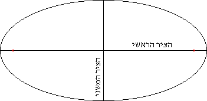

Elips

Seperti apakah trajektorinya? Misalkan $P$ titik pada batang yang diberikan oleh

$$P_1+t(P_2-P_1).$$

Menurut deskripsi Situasi 8.1, titik $P$ mempunyai koordinat

$$((1-t)x_1+tey_2,ty_2),$$

dengan syarat

$$(ey_2-x_1)^2+y_2^2=d^2.$$

Dalam kasus-kasus ekstrem $t=0$ dan $t=1$, himpunan solusi yang diperoleh masing-masing adalah $(x_1,0)$ (dengan $x_1$ sembarang) dan $(ey_2,y_2)$ (dengan $y_2$ sembarang). Di sini, syarat

$$(ey_2-x_1)^2+y_2^2=d^2$$

tetap harus dipenuhi; artinya, untuk $x_1$ (atau $y_2$) yang diberikan, harus ada solusi persamaan dalam variabel yang lain. Solusi seperti itu ada apabila $x_1$ (atau $y_2$) cukup kecil. Secara keseluruhan, kita memperoleh ruas-ruas tertentu pada garis-garis semula. Titik-titik $P_1$ dan $P_2$ harus tetap berada pada lintasannya dan tidak dapat menjauh tanpa batas dari garis yang lain.

> **Catatan edisi:** Ungkapan “cukup kecil” pada sumber berarti kecil dalam nilai mutlak. Untuk $t=0$, peminimuman ruas kiri terhadap $y_2$ memberi syarat tepat $|x_1|\le d\sqrt{1+e^2}$; untuk $t=1$, peminimuman terhadap $x_1$ memberi syarat tepat $|y_2|\le d$.

Jadi, misalkan

$$t\ne0,1.$$

Dari ansatz

$$(x,y)=((1-t)x_1+tey_2,ty_2)$$

diperoleh

$$y_2=\frac yt$$

dan

$$x_1=\frac{x-tey_2}{1-t}=\frac{x-ey}{1-t}$$

(jadi, prapetanya ditentukan secara tunggal). Persamaannya lalu menjadi

$$\left(\frac{ey}{t}-\frac{x-ey}{1-t}\right)^2+\frac{y^2}{t^2}=d^2,$$

yang kembali merupakan persamaan sebuah elips.

## Garis dan lingkaran sebagai lintasan

Sekarang kita meninjau kasus suatu kurva mekanis ketika lintasan yang satu adalah sebuah garis dan lintasan kedua sebuah lingkaran. Inilah situasi pada mesin uap (khususnya apabila garis melalui pusat lingkaran).

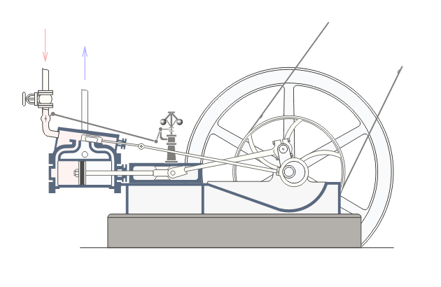

Mesin uap sedang bekerja

Tanpa mengurangi keumuman, kita dapat mengandaikan bahwa garis diberikan oleh

$$y=0.$$

Koordinat titik pada garis kemudian adalah

$$P_1=(x_1,y_1)=(x_1,0).$$

Untuk lingkarannya, kita dapat mengandaikan bahwa pusatnya $(0,b)$ dan jari-jarinya $r$. Titik lintasan lingkaran

$$P_2=(x_2,y_2)$$

memenuhi syarat

$$x_2^2+(y_2-b)^2=r^2.$$

Jadi, seluruh sistem mekanis dideskripsikan oleh dua syarat

$$\begin{aligned}
x_2^2+(y_2-b)^2&=r^2,\\
(x_2-x_1)^2+y_2^2&=d^2,
\end{aligned}$$

dengan $d$ kembali menyatakan jarak kopling. Jika kedua persamaan ini ditinjau dalam koordinat $x_2,y_2$ dan $x_2-x_1$, terlihat bahwa keduanya mendeskripsikan irisan dua silinder, serupa dengan [Contoh 4.6](https://de.wikiversity.org/wiki/Affine_Variet%C3%A4ten/Irreduzible_Teilmengen/Schnitt_von_zwei_gleichgro%C3%9Fen_Zylindern/Zwei_Kreise/Beispiel). Jadi, konfigurasi batang yang diizinkan dalam sistem mekanis dapat ditafsirkan, dalam tiga koordinat yang sesuai, sebagai irisan dua silinder. Namun, jari-jarinya tidak harus sama dan sumbu-sumbu dalam silindernya juga tidak harus berpotongan. Irisan semacam itu beserta trajektori-trajektori yang bersesuaian dapat menjadi cukup rumit.

Dalam contoh-contoh berikut, kita memerlukan sebuah lema yang mendeskripsikan suatu *situasi eliminasi* sederhana.

### [Lema: eliminasi dua persamaan kuadratik](https://de.wikiversity.org/wiki/Elimination/Zwei_quadratische_Gleichungen/Direkt/Fakt)

Misalkan $R$ suatu [domain integral](https://de.wikiversity.org/wiki/Kommutative_Ringtheorie/Integrit%C3%A4tsbereich/Definition), dan misalkan

$$F_1=a_1X^2+b_1X+c_1
\qquad\text{dan}\qquad
F_2=a_2X^2+b_2X+c_2$$

dua polinom kuadratik dalam satu variabel di atas $R$, dengan

$$a_1\ne0,$$

serta $(a_1,b_1)$ dan $(a_2,b_2)$ bebas linear. Maka ideal

$$(F_1,F_2)\cap R$$

memuat unsur

$$\begin{aligned}
&(a_2c_1-a_1c_2)^2\\
&\quad-b_1(-a_2c_1b_2-c_2a_2b_1+a_1b_2c_2)\\
&\quad+c_1(a_1b_2^2-2a_2b_1b_2).
\end{aligned}$$

#### [Bukti](https://de.wikiversity.org/wiki/Elimination/Zwei_quadratische_Gleichungen/Direkt/Fakt/Beweis2)

Pertama-tama, kita mempunyai

$$a_2F_1-a_1F_2
=(a_2b_1-a_1b_2)X+a_2c_1-a_1c_2.$$

Dari sini diperoleh ungkapan (argumen ini tidak sepenuhnya benar, tetapi juga dapat dilaksanakan secara lebih ketat)

$$X=-\frac{a_2c_1-a_1c_2}{a_2b_1-a_1b_2}.$$

Kita menyubstitusikannya ke dalam $F_1$, lalu mengalikan dengan kuadrat penyebut, dan memperoleh

$$\begin{aligned}
&a_1(a_2c_1-a_1c_2)^2\\
&\quad-b_1(a_2c_1-a_1c_2)(a_2b_1-a_1b_2)\\
&\quad+c_1(a_2b_1-a_1b_2)^2.
\end{aligned}$$

Dalam suku kedua muncul $-b_1a_2c_1a_2b_1$, dan dalam suku ketiga muncul $c_1a_2^2b_1^2$; kedua suku ini saling meniadakan. Setiap monom yang tersisa memuat $a_1$. Jadi, kita dapat mencoret $a_1$, dan yang tersisa adalah

$$\begin{aligned}
&(a_2c_1-a_1c_2)^2\\
&\quad-b_1(-a_2c_1b_2-c_2a_2b_1+a_1b_2c_2)\\
&\quad+c_1(a_1b_2^2-2a_2b_1b_2).
\end{aligned}$$

$\square$

### [Contoh: lingkaran satuan dan garis singgung](https://de.wikiversity.org/wiki/Mechanisch_definierte_Kurven/Stangenkonfiguration/Kreis_und_tangentiale_Gerade/Beispiel)

Kita meninjau sistem kopling mekanis yang didefinisikan oleh lingkaran satuan dan garis yang menyinggungnya di $(0,1)$, dengan jarak kopling

$$d=2.$$

Jadi, titik lintasan garis dan titik lintasan lingkaran adalah

$$P_1=(x_1,1)
\qquad\text{dan}\qquad
P_2=(x_2,y_2),$$

dengan dua syarat

$$\begin{aligned}
x_2^2+y_2^2&=1,\\
(x_2-x_1)^2+(y_2-1)^2&=4.
\end{aligned}$$

Jadi, sistem ini merupakan irisan dua silinder, tetapi dengan jari-jari yang berbeda dan sumbu-sumbu dalam yang tidak berpotongan. Selisih kedua persamaannya adalah

$$x_1^2-2x_1x_2-2y_2-2=0,$$

dan salah satu persamaan dapat diganti dengannya. Dari sini juga terlihat bahwa variabel $y_2$ dapat dieliminasi, sehingga diperoleh suatu sistem dengan satu persamaan dalam dua variabel; lihat [Soal 8.9](https://de.wikiversity.org/wiki/Mechanisch_definierte_Kurven/Stangenkonfiguration/Kreis_und_tangentiale_Gerade/Zweidimensionale_Interpretation/Aufgabe). Sistem ini tak tereduksi; lihat [Soal 8.10](https://de.wikiversity.org/wiki/Mechanisch_definierte_Kurven/Stangenkonfiguration/Kreis_und_tangentiale_Gerade/Irreduzibel/Aufgabe).

Dua garis berikut menarik:

$$G_1=V(x_2,y_2+1)$$

dan

$$G_2=V(x_2-x_1,y_2+1).$$

Keduanya berpotongan di titik

$$P=(0,0,-1).$$

Garis $G_1$ terletak pada salah satu silinder dan menyinggung silinder yang lain, demikian pula sebaliknya. Gambaran geometrisnya adalah bahwa silinder yang lebih kecil melubangi silinder yang lebih besar dan menghasilkan suatu “angka delapan melengkung”, dengan $P$ sebagai titik persilangan angka delapan itu.

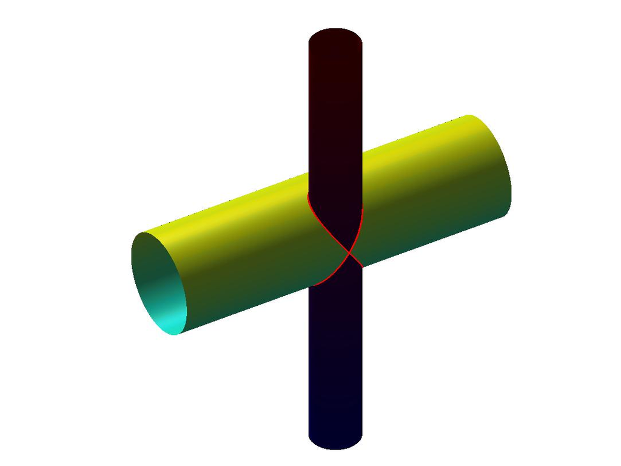

Irisan dua silinder

Konfigurasi batang yang diizinkan dapat diperoleh sebagai berikut. Untuk setiap titik lingkaran, terdapat dua kemungkinan posisi batang, kecuali untuk titik lintasan lingkaran $(0,-1)$, ketika titik lintasan garis haruslah $(0,1)$.

Kita mulai dengan situasi ketika $(0,1)$ adalah titik lintasan lingkaran dan $(-2,1)$ adalah titik lintasan garis (jadi, batang terletak ke kiri pada garis), lalu membiarkan titik lintasan lingkaran bergerak mengelilingi lingkaran searah jarum jam. Titik lintasan lingkaran kemudian menarik titik lintasan garis di belakangnya sampai tiba di bawah, pada $(0,-1)$. Batang kemudian menjadi diameter vertikal lingkaran (titik lintasan garis berada di $(0,1)$ dan titik lintasan lingkaran tepat di bawah). Sesudah itu, titik lintasan lingkaran bergerak naik pada busur kiri lingkaran sambil mendorong batang lebih jauh ke kanan, sampai titik lintasan garis tiba di $(2,1)$.

Kemungkinan lain ketika $(0,1)$ adalah titik lintasan lingkaran ialah batang terletak ke kanan pada garis (dengan $(2,1)$ sebagai titik lintasan garis). Titik lintasan lingkaran kembali bergerak searah jarum jam. Mula-mula, titik itu mendorong titik lintasan garis ke kanan sampai suatu posisi ekstrem, ketika batang tegak lurus terhadap lingkaran di titik lintasan lingkaran. Sesudah itu, titik lintasan lingkaran menarik titik lintasan garis kembali ke kiri, sementara batang menegak, sampai batang menempati diameter vertikal lingkaran. Selanjutnya, titik lintasan lingkaran kembali bergerak naik pada busur kiri lingkaran, sambil mendorong titik lintasan garis ke kiri sampai posisi ekstrem, lalu pada bagian terakhir kembali menariknya ke $(-2,1)$.

Khususnya, diameter vertikal lingkaran ditempati dua kali oleh batang; jadi, konfigurasi batang ini bersesuaian dengan titik persilangan angka delapan.

Sekarang kita hendak menghitung trajektori titik tengah batang, yaitu

$$\begin{aligned}
P
&=P_1+\frac12(P_2-P_1)\\
&=(x_1,1)+\frac12(x_2-x_1,y_2-1)\\
&=\left(\frac12x_1+\frac12x_2,\frac12y_2+\frac12\right)\\
&\mathrel{:=}(x,y).
\end{aligned}$$

Kita mencari suatu persamaan bagi $x$ dan $y$, dan memperkenalkan variabel

$$z=\frac12x_1-\frac12x_2.$$

Maka

$$x_1=x+z,\qquad x_2=x-z,\qquad y_2=2y-1,$$

dan sistem persamaan dalam variabel-variabel baru menjadi

$$(x-z)^2+(2y-1)^2=1
\qquad\text{dan}\qquad
(-2z)^2+(2y-2)^2=4.$$

Persamaan kedua dapat ditulis sebagai

$$z^2+(y-1)^2=1,$$

atau sebagai

$$z^2+y^2-2y=0.$$

Setelah dikembangkan, persamaan pertama menjadi

$$z^2-2zx+x^2+4y^2-4y=0.$$

Menurut Lema 8.4, dengan

$$R=\mathbb R[x,y]$$

dan variabel tambahan $z$ (jadi, $a_1=a_2=1$ dan $b_1=0$), diperoleh persamaan

$$\begin{aligned}
(c_1-c_2)^2+c_1b_2^2
&=(y^2-2y-x^2-4y^2+4y)^2+(y^2-2y)(2x)^2\\
&=(-3y^2+2y-x^2)^2+(y^2-2y)(2x)^2\\
&=9y^4+x^4+4y^2-12y^3+6x^2y^2-4x^2y\\
&\qquad+4x^2y^2-8x^2y\\
&=9y^4+10x^2y^2+x^4-12y^3-12x^2y+4y^2.
\end{aligned}$$

Ini adalah suatu kuartik (kurva berderajat empat) dengan dua singularitas.

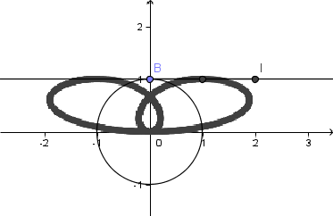

Gambar untuk latihan

### [Contoh: jari-jari sama dengan jarak kopling](https://de.wikiversity.org/wiki/Mechanische_ebene_Kurven/Stangenkoppelung/Gerade_und_Kreis/Radius_ist_Koppelungsabstand/Beispiel)

Kita meninjau sistem mekanis yang terdiri atas lingkaran satuan dan sumbu $x$, dengan jarak kopling

$$d=1.$$

Sistem mekanis itu dideskripsikan oleh dua persamaan

$$\begin{aligned}
x_2^2+y_2^2&=1,\\
(x_2-x_1)^2+y_2^2&=1.
\end{aligned}$$

Ini merupakan irisan dua silinder dengan jari-jari yang sama dan sumbu-sumbu dalam yang berpotongan; jadi, kita dapat menggunakan hasil [Contoh 4.6](https://de.wikiversity.org/wiki/Affine_Variet%C3%A4ten/Irreduzible_Teilmengen/Schnitt_von_zwei_gleichgro%C3%9Fen_Zylindern/Zwei_Kreise/Beispiel). Di sana telah ditunjukkan bahwa irisan tersebut diberikan oleh dua elips yang berpotongan di dua titik. Deskripsi ini juga harus muncul kembali dalam konteks sistem mekanis. Konfigurasi batang manakah yang bersesuaian dengan elips pertama, konfigurasi manakah yang bersesuaian dengan elips kedua, dan konfigurasi manakah yang terletak pada keduanya?

Mari kita tinjau seluruh konfigurasi yang diizinkan. Jika titik garis (yakni titik pada lintasan garis) adalah pusat lingkaran, setiap titik lingkaran diizinkan sebagai titik lintasan lingkaran. Jadi, sinar-sinar radial lingkaran membentuk suatu keluarga konfigurasi batang yang diizinkan, dan bersama-sama mereka membentuk salah satu elips. Elips yang lain bersesuaian dengan himpunan konfigurasi batang ketika titik lintasan garis bergerak dari $-2$ ke $+2$, sambil mendorong titik lintasan lingkaran di depannya atau menariknya di belakangnya pada busur atas atau busur bawah lingkaran. Ada dua konfigurasi batang yang termasuk dalam kedua keluarga, yaitu konfigurasi dengan pusat lingkaran sebagai titik lintasan garis dan $(0,1)$ atau $(0,-1)$ sebagai titik lintasan lingkaran. Dalam konfigurasi batang seperti itu, sistem mekanis tidak hanya dapat bergerak maju dan mundur, tetapi juga dapat mengubah arah secara esensial.

Seperti apakah trajektori suatu titik pada batang bergerak? Trajektori totalnya adalah gabungan kedua trajektori yang bersesuaian dengan kedua komponen tak tereduksi sistem. Berapa banyak titik penembusan diri yang ada?

Untuk suatu titik

$$P=P_1+u(P_2-P_1)$$

pada batang kopling, koordinatnya adalah

$$(z_1,z_2)=(x_1+u(x_2-x_1),uy_2).$$

Untuk $u=0$, trajektorinya adalah interval real $[-2,2]$, dan untuk $u=1$, trajektorinya adalah lingkaran satuan. Jadi, sekarang misalkan

$$u\ne0,1.$$

Proyeksi komponen-komponen radial sistem hanyalah lingkaran berjari-jari $u$. Proyeksi elips yang lain kembali merupakan sebuah elips yang dapat memotong lingkaran tersebut dengan berbagai cara. Lihat juga [Soal 8.23](https://de.wikiversity.org/wiki/Schnitt_von_zwei_Zylindern/Projektion_auf_Fl%C3%A4chen/Charakterisierung_der_Bilder/Aufgabe).

# Lembar Kerja 8

## Soal latihan

### Soal 8.1

Tentukan berbagai kemungkinan perpotongan dua silinder yang saling tegak lurus.

### Soal 8.2

Buatlah suatu persamaan yang sesederhana mungkin bagi sistem mekanis yang ditentukan oleh sumbu $X$, parabola tergeser

$$Y=X^2+1,$$

dan jarak $2$.

### Soal 8.3

Misalkan

$$H_1,H_2\in K[X]$$

merupakan polinom-polinom dalam satu variabel, dan misalkan

$$C_1=V(Y-H_1),
\qquad
C_2=V(Y-H_2)$$

merupakan grafik-grafik yang bersesuaian di $\mathbb A_K^2$. Buktikan bahwa sistem mekanis yang bersesuaian, untuk suatu jarak tertentu $d$, dapat dideskripsikan dengan dua variabel.

### Soal 8.4

Tentukan persamaan-persamaan bagi sistem mekanis yang diberikan oleh lingkaran satuan, sumbu $x$, dan jarak $1$. Apa saja komponen tak tereduksi sistem tersebut?

### Soal 8.5

Misalkan

$$M\subseteq\mathbb A_{\mathbb R}^4$$

merupakan sistem mekanis yang diberikan oleh dua lintasan $B_1$ dan $B_2$ serta jarak $d$. Buktikan bahwa terdapat pemetaan injektif alami

$$M\longrightarrow B_1\times B_2.$$

### Soal 8.6

Misalkan

$$B=V(G)\subseteq\mathbb A_{\mathbb R}^2$$

suatu lintasan. Kita memandang lintasan ini sebagai sistem mekanis $M$ dalam arti bahwa kedua titik yang berjarak $d$ harus terletak pada satu lintasan tersebut. Buktikan bahwa terdapat pemetaan bijektif alami tanpa titik tetap

$$M\longrightarrow M.$$

### Soal 8.7

Tentukan persamaan-persamaan bagi sistem mekanis yang diberikan oleh sumbu $x$, sebagai lintasan bersama, dan jarak $1$.

### Soal 8.8

Tentukan persamaan-persamaan bagi sistem mekanis yang diberikan oleh lingkaran satuan, sebagai lintasan bersama, dan jarak $2$.

### Soal 8.9 ★

Kita meninjau sistem mekanis yang didefinisikan oleh lingkaran satuan dan garis singgungnya yang melalui $(0,1)$, dengan jarak kopling

$$d=2.$$

Buktikan bahwa sistem ini dapat dideskripsikan dengan dua variabel.

### Soal 8.10

Kita meninjau sistem mekanis yang didefinisikan oleh lingkaran satuan dan garis singgungnya yang melalui $(0,1)$, dengan jarak kopling $d=2$; lihat Contoh 8.5. Buktikan bahwa sistem ini tak tereduksi. Untuk itu, terapkan Soal 7.24 pada perluasan gelanggang

$$R=\mathbb R[X_2,Y_2]/(X_2^2+Y_2^2-1)
\subseteq
R[X_1]/(X_1^2-2X_1X_2-2Y_2-2).$$

### Soal 8.11

Tentukan persamaan-persamaan bagi sistem mekanis yang diberikan oleh sumbu $x$, sumbu $y$, dan jarak $1$.

### Soal 8.12

Tentukan persamaan-persamaan bagi sistem mekanis yang diberikan oleh gabungan kedua sumbu koordinat, sebagai lintasan bersama, dan jarak $1$.

### Soal 8.13

Misalkan

$$B_1=V(F_1),\quad B_2=V(F_2)
\subseteq\mathbb A_{\mathbb R}^2$$

dua lintasan, dan tetapkan suatu jarak $d$. Bandingkan sistem mekanis $M$ bagi kedua lintasan ini dengan sistem $N$ yang bersesuaian dengan lintasan tunggal $B_1\cup B_2$. Buktikan bahwa terdapat dua pemetaan injektif alami

$$M\longrightarrow N.$$

Misalkan $L_i$ adalah sistem mekanis yang bersesuaian dengan $B_i$ sebagai satu-satunya lintasan. Buktikan bahwa terdapat pemetaan surjektif alami

$$L_1\uplus L_2\uplus M\uplus M\longrightarrow N.$$

### Soal 8.14

Misalkan

$$M\subseteq\mathbb A_{\mathbb R}^4$$

suatu sistem mekanis. Buktikan bahwa aturan

$$\begin{aligned}
M&\longrightarrow S^1(d),\\
(P_1,P_2)&\longmapsto P_1-P_2
\end{aligned}$$

mendefinisikan pemetaan sistem tersebut ke lingkaran yang berpusat di $(0,0)$ dan berjari-jari $d$. Apa arti kesurjektifan pemetaan ini? Dapatkah citra pemetaan ini hanya terdiri atas berhingga banyak titik?

### Soal 8.15

Kita meninjau sistem mekanis

$$M\subseteq\mathbb A_{\mathbb R}^4$$

untuk dua garis yang berpotongan. Buktikan bahwa pemetaan pada Soal 8.14 bersifat bijektif.

### Soal 8.16

Kita meninjau sistem mekanis

$$M\subseteq\mathbb A_{\mathbb R}^4$$

untuk lingkaran satuan, lingkaran yang berpusat di $(0,2)$ dan berjari-jari $4$, serta jarak kopling $5$. Buktikan bahwa pemetaan pada Soal 8.14 tidak surjektif. Apakah citranya?

## Persiapan untuk regularitas

Dalam soal-soal berikut, kita meninjau himpunan nol

$$V=V(f_1,\ldots,f_k)\subseteq\mathbb A_{\mathbb R}^n$$

dari sudut pandang geometri diferensial. Kita mengingat definisi titik reguler bagi pemetaan terdiferensialkan dari kuliah Analisis 2. Dalam konteks sekarang, pengertian ini diterapkan pada pemetaan

$$\varphi=(f_1,\ldots,f_k):
\mathbb A_{\mathbb R}^n\longrightarrow\mathbb A_{\mathbb R}^k$$

di suatu titik $P\in V$.

Misalkan $V_0$ dan $W$ ruang vektor real berdimensi hingga, $G\subseteq V_0$ terbuka, $P\in G$, dan

$$\varphi:G\longrightarrow W$$

terdiferensialkan di $P$. Titik $P$ disebut *titik reguler* dari $\varphi$ jika

$$\operatorname{rank}(D\varphi)_P
=\min\bigl(\dim V_0,\dim W\bigr).$$

Jika tidak, $P$ disebut *titik kritis* atau *titik singular*.

### Soal 8.17 ★

Kita meninjau sistem mekanis yang diberikan oleh sumbu $x$ dan lingkaran yang berpusat di $(0,2)$ serta berjari-jari $1$. Misalkan jarak koplingnya $d>0$.

1. Susun persamaan-persamaan yang mendeskripsikan sistem ini.
2. Tentukan untuk nilai $d$ mana sistem tersebut reguler di setiap titik.
3. Tentukan titik-titik kritis sebagai fungsi dari $d$. Bagaimana titik-titik tersebut dapat dijelaskan sebagai sifat sistem mekanis?

### Soal 8.18

Kita meninjau sistem mekanis yang diberikan oleh sumbu $x$ dan lingkaran yang berpusat di $(0,2)$ serta berjari-jari $1$. Misalkan jarak koplingnya $d>0$.

1. Berikan alasan geometris, lalu buktikan, bahwa untuk $d>3$ sistem mekanis ini tidak terhubung-lintasan dalam topologi real.
2. Berikan alasan geometris, lalu buktikan, bahwa untuk $1\le d\le 3$ sistem mekanis ini terhubung-lintasan.

## Soal untuk dikumpulkan

### Soal 8.19 - 6 poin (2+2+2)

Kita meninjau sistem mekanis yang diberikan oleh sumbu $x$, parabola $V(Y-X^2)$, dan jarak kopling $1$.

1. Tentukan persamaan-persamaan bagi sistem mekanis ini dengan sesedikit mungkin variabel.
2. Apakah sistem ini mempunyai titik kritis?
3. Tentukan persamaan lintasan gerak titik tengah batang penghubung.

### Soal 8.20 - 2 poin

Tentukan persamaan-persamaan bagi sistem mekanis yang diberikan oleh lingkaran satuan, sebagai lintasan bersama, dan jarak $1$.

### Soal 8.21 - 6 poin (2+2+2)

Kita meninjau sistem mekanis yang diberikan oleh parabola $V(Y-X^2)$, lingkaran yang berpusat di $(0,2)$ dan berjari-jari $1$, serta jarak kopling $1$.

1. Tentukan persamaan-persamaan bagi sistem mekanis ini dengan sesedikit mungkin variabel.
2. Tentukan komponen-komponen terhubung sistem dalam topologi metrik.
3. Tentukan komponen-komponen terhubung sistem dalam topologi Zariski.

### Soal 8.22 - 6 poin (2+4)

Kita meninjau sistem mekanis yang diberikan oleh sumbu $x$ dan lingkaran yang berpusat di $(0,2)$ serta berjari-jari $1$. Misalkan jarak koplingnya $d>0$. Kita melanjutkan Soal 8.17.

1. Eliminasikan variabel $y_1$ dari persamaan-persamaan sistem.
2. Dengan menggunakan satu persamaan dalam variabel $x_1$ dan $x_2$ yang mendeskripsikan sistem, tentukan untuk nilai $d$ mana sistem tersebut reguler di setiap titik.

### Soal 8.23 - 6 poin

Misalkan

$$C\subseteq\mathbb A_{\mathbb R}^3$$

adalah perpotongan dua silinder berjari-jari $1$, masing-masing mengelilingi sumbu $x$ dan sumbu $y$; jadi, $C$ merupakan gabungan dua elips. Kita meninjau proyeksi tegak lurus

$$p_v:\mathbb A_{\mathbb R}^3\longrightarrow\mathbb A_{\mathbb R}^2$$

yang ditentukan oleh suatu vektor

$$v=(a,b,c)\ne 0.$$

Karakterisasikan berbagai kemungkinan citra di bawah proyeksi-proyeksi ini sebagai fungsi dari $a,b,c$.

### Soal 8.24 - 3 poin

Tinjau pemetaan

$$\begin{aligned}
\mathbb A_K^2&\longrightarrow\mathbb A_K^2,\\
(x,y)&\longmapsto(x^2,y^2)=(u,v).
\end{aligned}$$

Bagaimanakah citra bidang dan citra lingkaran satuan di bawah pemetaan ini untuk $K=\mathbb R$, dan bagaimanakah untuk $K=\mathbb C$? Dalam kasus real, jika lingkaran dilintasi satu kali, berapa kali citranya dilintasi?

**Navigasi sumber:** Kuliah 8 - solusi publik Unit 8 - Lembar Kerja 7 - Lembar Kerja 9 (sumber)

# Solusi Publik Lembar Kerja 8

Sumber hanya menyediakan solusi publik bagi Soal 8.9 dan 8.17 pada batas revisi yang dibekukan. Tidak ada solusi tambahan yang dibuat untuk edisi ini.

## Solusi Soal 8.9

Dengan

$$P_1=(x_1,1)
\qquad\text{dan}\qquad
P_2=(x_2,y_2),$$

kita memperoleh kedua syarat

$$x_2^2+y_2^2=1$$

dan

$$(x_2-x_1)^2+(y_2-1)^2=4.$$

Kita kurangkan persamaan pertama dari persamaan kedua dan memperoleh

$$\begin{aligned}
0
&=(x_2-x_1)^2+(y_2-1)^2-4-(x_2^2+y_2^2-1)\\
&=x_2^2+x_1^2-2x_1x_2+y_2^2-2y_2+1-4-x_2^2-y_2^2+1\\
&=x_1^2-2x_1x_2-2y_2-2.
\end{aligned}$$

Persamaan ini, bersama dengan persamaan lingkaran satuan, ekuivalen dengan sistem semula. Dari persamaan kedua yang baru tersebut, $y_2$ dapat dieliminasikan melalui

$$y_2=\frac12x_1^2-x_1x_2-1.$$

Jadi, sistem dapat dideskripsikan hanya dengan variabel $x_1$ dan $x_2$, yaitu sebagai himpunan nol polinom

$$\begin{aligned}
x_2^2+y_2^2-1
&=x_2^2+\left(\frac12x_1^2-x_1x_2-1\right)^2-1\\
&=x_2^2+\frac14x_1^4+x_1^2x_2^2+1-x_1^3x_2-x_1^2+2x_1x_2-1\\
&=\frac14x_1^4-x_1^3x_2+x_1^2x_2^2-x_1^2+2x_1x_2+x_2^2.
\end{aligned}$$

Kembali ke Soal 8.9.

## Solusi Soal 8.17

1. Misalkan

   $$P_1=(x_1,y_1)$$

   adalah titik pada lingkaran dan

   $$P_2=(x_2,0)$$

   adalah titik pada sumbu $x$. Persamaan-persamaannya ialah

   $$x_1^2+(y_1-2)^2=1$$

   dan

   $$(x_1-x_2)^2+y_1^2=d^2.$$
2. Tuliskan

   $$f_1=x_1^2+(y_1-2)^2-1
   =x_1^2+y_1^2-4y_1+3$$

   dan

   $$f_2=(x_1-x_2)^2+y_1^2-d^2
   =x_1^2+x_2^2-2x_1x_2+y_1^2-d^2.$$

   Matriks Jacobi terhadap variabel $(x_1,x_2,y_1)$ adalah

   $$\begin{pmatrix}
   2x_1 & 0 & 2y_1-4\\
   2x_1-2x_2 & 2x_2-2x_1 & 2y_1
   \end{pmatrix}.$$

   Kita harus memeriksa, bergantung pada $d$, pada titik mana pemetaan linear $\mathbb R^3\to\mathbb R^2$ yang diberikan oleh matriks ini surjektif, yakni mempunyai rank $2$. Rank-nya bukan $2$ tepat ketika semua kolom bergantung linear, atau secara ekuivalen ketika semua minor $2\times2$ sama dengan nol. Setelah faktor bersama $4$ dikeluarkan, ketiga polinomnya adalah

   $$x_1(x_2-x_1),
   \qquad
   (y_1-2)(x_2-x_1),
   \qquad
   x_1y_1-(x_1-x_2)(y_1-2).$$

   Jika $x_1\ne0$, maka harus berlaku $x_1=x_2$ dan $y_1=0$. Namun, ini bukan titik sistem. Jadi, harus berlaku $x_1=0$. Jika $x_2\ne0$, maka harus berlaku $y_1=2$, tetapi ini tidak memenuhi persamaan pertama sistem. Maka $x_2=0$. Selanjutnya, persamaan-persamaan sistem memberikan

   $$(y_1-2)^2=1
   \qquad\text{dan}\qquad
   y_1^2=d^2.$$

   Persamaan pertama memaksa $y_1=1$ atau $y_1=3$, sehingga $d=1$ atau $d=3$. Dengan demikian, tepat untuk $d\ne1,3$ sistem ini reguler di setiap titik.
3. Untuk $d=1$, berdasarkan perhitungan di atas, $(0,0,1)$ adalah satu-satunya titik kritis; bahkan titik ini merupakan satu-satunya titik sistem, yang menjelaskan singularitas tersebut.

   Untuk $d=3$, titik $(0,0,3)$ adalah satu-satunya titik kritis sistem. Di sana terdapat titik perpotongan karena batang dapat bergerak dalam empat arah: kedua koordinat $(x_1,x_2)$ ke arah positif, keduanya ke arah negatif, atau dalam dua arah campuran.

Kembali ke Soal 8.17.

**Navigasi sumber:** Lembar Kerja 8 - Kuliah 8

# Kuliah 9: Gelanggang Noether, Teorema Basis Hilbert, dan Modul

## Gelanggang Noether

Pada kuliah-kuliah berikutnya kita akan mengembangkan lebih lanjut sisi aljabar dari geometri aljabar. Tujuan pertama kita adalah menunjukkan bahwa, jika $R$ merupakan gelanggang Noether, maka gelanggang polinomial $R[X]$ juga merupakan gelanggang Noether (Teorema Basis Hilbert). Hal ini juga berlaku untuk penambahan beberapa (hingga banyaknya) variabel, khususnya untuk gelanggang polinomial dalam hingga banyak variabel di atas suatu lapangan. Kita mengingat kembali pengertian gelanggang Noether.

### Definisi: gelanggang Noether

Suatu gelanggang komutatif $R$ disebut *Noether* jika setiap ideal di dalamnya dibangkitkan secara hingga.

### Proposisi: karakterisasi gelanggang Noether

Untuk gelanggang komutatif $R$, pernyataan-pernyataan berikut ekuivalen.

1. $R$ merupakan gelanggang Noether.
2. Setiap rantai ideal naik

   $$\mathfrak a_1\subseteq\mathfrak a_2\subseteq\mathfrak a_3\subseteq\cdots$$

   menjadi *stasioner*; artinya, terdapat $n$ sedemikian sehingga

   $$\mathfrak a_n=\mathfrak a_{n+1}=\cdots.$$

#### Bukti

**(1) $\Rightarrow$ (2).** Misalkan

$$\mathfrak a_1\subseteq\mathfrak a_2\subseteq\mathfrak a_3\subseteq\cdots$$

merupakan rantai ideal naik di $R$. Kita pertimbangkan gabungannya

$$\mathfrak a=\bigcup_{n\in\mathbb N}\mathfrak a_n,$$

yang kembali merupakan ideal di $R$. Karena $R$ Noether, $\mathfrak a$ dibangkitkan secara hingga, yaitu

$$\mathfrak a=(f_1,\ldots,f_k).$$

Semua $f_i$ berada dalam gabungan ideal-ideal $\mathfrak a_n$. Karena ideal-ideal itu naik, terdapat $n$ sedemikian sehingga

$$f_1,\ldots,f_k\in\mathfrak a_n.$$

Maka, untuk setiap $m\geq0$,

$$(f_1,\ldots,f_k)\subseteq\mathfrak a_n
\subseteq\mathfrak a_{n+m}
\subseteq\bigcup_{n\in\mathbb N}\mathfrak a_n
\subseteq(f_1,\ldots,f_k).$$

Semua inklusi tersebut harus merupakan kesamaan; jadi rantai ideal stasioner mulai dari $n$.

**(2) $\Rightarrow$ (1).** Misalkan $\mathfrak a$ suatu ideal di $R$. Andaikan $\mathfrak a$ tidak dibangkitkan secara hingga. Kita dapat membangun secara bertahap rantai ideal naik sejati tak berhingga

$$\mathfrak a_1\subset\mathfrak a_2\subset\cdots\subseteq\mathfrak a,$$

dengan setiap $\mathfrak a_n$ dibangkitkan secara hingga. Misalkan sudah dibangun

$$\mathfrak a_1\subset\mathfrak a_2\subset\cdots\subset\mathfrak a_n
\subseteq\mathfrak a.$$

Karena $\mathfrak a_n$ dibangkitkan secara hingga sedangkan $\mathfrak a$ tidak, inklusi $\mathfrak a_n\subseteq\mathfrak a$ bersifat sejati. Jadi ada unsur

$$f_{n+1}\in\mathfrak a,\qquad f_{n+1}\notin\mathfrak a_n.$$

Ideal

$$\mathfrak a_{n+1}:=\mathfrak a_n+(f_{n+1})$$

melanjutkan rantai itu secara sejati. Ini bertentangan dengan (2).

### Lema: gelanggang faktor dari gelanggang Noether

Jika $R$ merupakan gelanggang Noether, maka setiap gelanggang faktor $R/\mathfrak b$ juga Noether.

#### Bukti

Misalkan $\mathfrak a\subseteq R/\mathfrak b$ suatu ideal dan misalkan $\widetilde{\mathfrak a}\subseteq R$ adalah ideal prapeta yang bersesuaian. Menurut asumsi, ideal ini dibangkitkan secara hingga, sehingga

$$\widetilde{\mathfrak a}=(f_1,\ldots,f_n).$$

Kelas-kelas residu dari pembangkit-pembangkit tersebut, $\bar f_1,\ldots,\bar f_n$, membentuk sistem pembangkit ideal untuk $\mathfrak a$. Memang, untuk $\bar g\in\mathfrak a$ berlaku di $R$

$$g=\sum_{i=1}^n r_i f_i,$$

dan karena itu di $R/\mathfrak b$

$$\bar g=\sum_{i=1}^n\bar r_i\,\bar f_i.$$

## Teorema Basis Hilbert

Seperti banyak pernyataan dasar dalam aljabar komutatif, Teorema Basis Hilbert yang akan kita bahas berawal dari David Hilbert, lebih tepatnya dari karyanya tahun 1890, *Ueber die Theorie der algebraischen Formen*.

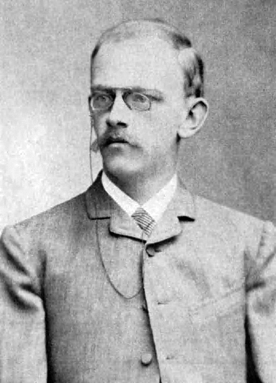

David Hilbert (1862–1943)

*David Hilbert (1862–1943); pencipta tidak diketahui (1886), Commons, domain publik.*

### Teorema Basis Hilbert

Jika $R$ merupakan gelanggang Noether, maka gelanggang polinomial $R[X]$ juga Noether.

#### Bukti

Misalkan $\mathfrak b$ suatu ideal dalam gelanggang polinomial $R[X]$. Untuk $n\in\mathbb N$, definisikan ideal $\mathfrak a_n$ di $R$ dengan

$$\mathfrak a_n=\left\{c\in R\mid\text{ada }F\in\mathfrak b\text{ dengan }
F=cX^n+c_{n-1}X^{n-1}+\cdots+c_1X+c_0\right\}.$$

Jadi, $\mathfrak a_n$ terdiri atas semua koefisien utama polinom berderajat $n$ di $\mathfrak b$. Jelas bahwa $\mathfrak a_n$ adalah ideal di $R$ (di sini kita mengizinkan $0$ sebagai koefisien utama). Selain itu,

$$\mathfrak a_n\subseteq\mathfrak a_{n+1},$$

karena polinom $F$ berderajat $n$ dengan koefisien utama $c$ dapat dikalikan dengan $X$ untuk memperoleh polinom berderajat $n+1$ yang masih berkoefisien utama $c$. Karena $R$ Noether, rantai ideal naik ini stasioner; pilih $n$ sedemikian sehingga

$$\mathfrak a_n=\mathfrak a_{n+1}=\cdots.$$

Untuk setiap $i\leq n$, pilih suatu sistem pembangkit berhingga

$$\mathfrak a_i=(c_{i1},\ldots,c_{ik_i}),$$

dan pilih polinom yang bersesuaian

$$F_{ij}=c_{ij}X^i+\text{ suku-suku berderajat lebih rendah}$$

di $\mathfrak b$ (polinom-polinom itu ada menurut definisi $\mathfrak a_i$).

Kita klaim bahwa $\mathfrak b$ dibangkitkan oleh semua

$$\left\{F_{ij}\mid 0\leq i\leq n,\ 1\leq j\leq k_i\right\}.$$

Untuk setiap $G\in\mathfrak b$, kita buktikan dengan induksi pada derajat $G$ bahwa $G$ dapat ditulis sebagai kombinasi linear atas $R$ dari polinom- polinom $F_{ij}$ tersebut. Jika $G$ konstan, yaitu $G\in R$, hal ini jelas. Misalkan derajat $G$ sama dengan $d$ dan pernyataan sudah terbukti untuk derajat yang lebih kecil. Tulis

$$G=cX^d+c_{d-1}X^{d-1}+\cdots+c_1X+c_0.$$

Kita memiliki $c\in\mathfrak a_d$. Jika $d\leq n$, maka $c$ dapat ditulis sebagai kombinasi linear atas $R$ dari $c_{dj}$, katakanlah

$$c=\sum_{j=1}^{k_d}r_jc_{dj}.$$

Dengan demikian

$$G-\sum_{j=1}^{k_d}r_jF_{dj}\in\mathfrak b$$

dan derajatnya lebih kecil, sehingga hipotesis induksi dapat diterapkan. Jika $d>n$, maka

$$c=\sum_{i=0,\ldots,n,\,j=1,\ldots,k_i}r_{ij}c_{ij}.$$

Karena itu

$$G-\sum_{i=0,\ldots,n,\,j=1,\ldots,k_i}r_{ij}X^{d-i}F_{ij}$$

juga berada di $\mathfrak b$ dan mempunyai derajat lebih kecil. Induksi selesai, sehingga $\mathfrak b$ dibangkitkan secara hingga.

### Korolari: hingga banyak variabel

Jika $R$ gelanggang Noether, maka

$$R[X_1,\ldots,X_n]$$

juga Noether.

#### Bukti

Terapkan Teorema Basis Hilbert secara induktif pada rantai

$$R\subset R[X_1]\subset (R[X_1])[X_2]=R[X_1,X_2]
\subset (R[X_1,X_2])[X_3]=R[X_1,X_2,X_3]
\subset\cdots\subset R[X_1,\ldots,X_n].$$

### Korolari: gelanggang polinomial di atas lapangan

Jika $K$ merupakan lapangan, maka $K[X_1,\ldots,X_n]$ Noether. Ini adalah kasus khusus dari Korolari 9.5.

#### Bukti

Ini merupakan kasus khusus dari Korolari 9.5.

Teorema Basis Hilbert khususnya berarti bahwa setiap subvarietas tertutup

$$V\subseteq\mathbb A_K^n$$

dalam ruang afin dapat dideskripsikan oleh hingga banyak polinom. Jadi setiap lokus nol aljabar sudah merupakan lokus nol dari hingga banyak polinom.

### Korolari: sebagai serat atas titik nol

Misalkan $V\subseteq\mathbb A_K^n$ suatu himpunan aljabar afin. Maka ada suatu pemetaan

$$\varphi:\mathbb A_K^n\longrightarrow\mathbb A_K^m$$

yang komponen-komponennya diberikan oleh polinom

$$F_i\in K[X_1,\ldots,X_n],\qquad
\varphi=(F_1,\ldots,F_m),$$

sedemikian sehingga $V$ merupakan prapeta titik nol

$$0\in\mathbb A_K^m.$$

#### Bukti

Misalkan $\mathfrak a$ merupakan ideal yang mendeskripsikan $V$, sehingga

$$V=V(\mathfrak a).$$

Menurut Teorema Basis Hilbert, terdapat

$$F_1,\ldots,F_m\in K[X_1,\ldots,X_n]$$

dengan $\mathfrak a=(F_1,\ldots,F_m)$. Maka

$$V=V(\mathfrak a)=V(F_1)\cap\cdots\cap V(F_m).$$

Gabungkan polinom-polinom ini menjadi pemetaan

$$\varphi=(F_1,\ldots,F_m):\mathbb A_K^n\longrightarrow\mathbb A_K^m.$$

Kita mempunyai $\varphi(P)=0$ tepat ketika semua fungsi komponennya nol, yang terjadi tepat ketika $P\in V(F_i)$ untuk setiap $i$; jadi $V=\varphi^{-1}(0)$.

### Definisi: aljabar tipe hingga

Misalkan $R$ gelanggang komutatif. Suatu $R$-aljabar $A$ disebut *bertipe hingga* (atau *dibangkitkan secara hingga*) jika berbentuk

$$A=R[X_1,\ldots,X_n]/\mathfrak a.$$

Dengan demikian, suatu $R$-aljabar yang dibangkitkan secara hingga memiliki representasi sebagai gelanggang faktor dari aljabar polinomial atas $R$ dalam hingga banyak variabel. Representasi seperti ini sama sekali tidak harus unik.

### Korolari: aljabar tipe hingga dari gelanggang Noether

Jika $R$ merupakan gelanggang Noether, maka setiap $R$-aljabar tipe hingga juga Noether. Khususnya, jika $K$ suatu lapangan, setiap $K$-aljabar tipe hingga adalah Noether.

#### Bukti

Hal ini mengikuti dari Korolari 9.5 dan Lema 9.3.

## Dekomposisi menjadi komponen tak tereduksi

Dari Teorema Basis Hilbert kita memperoleh bahwa setiap rantai ideal naik

$$\mathfrak a_1\subseteq\mathfrak a_2\subseteq\mathfrak a_3\subseteq\cdots$$

dalam $K[X_1,\ldots,X_n]$ menjadi stasioner. Konsekuensinya untuk rantai himpunan aljabar afin yang menurun di ruang afin adalah sebagai berikut.

### Teorema: topologi Zariski bersifat Noether

Dalam ruang afin $\mathbb A_K^n$, setiap barisan himpunan tertutup yang menurun

$$V_1\supseteq V_2\supseteq\cdots$$

menjadi stasioner.

#### Bukti

Misalkan

$$V_1\supseteq V_2\supseteq\cdots$$

rantai menurun himpunan aljabar afin dalam $\mathbb A_K^n$. Dari Lema 3.7, untuk ideal pelenyapan yang bersesuaian berlaku

$$\operatorname{Id}(V_i)\subseteq\operatorname{Id}(V_{i+1}).$$

Menurut Korolari 9.6, rantai ideal ini stasioner, misalnya untuk $i\geq i_0$. Menurut bagian (3) Lema 3.8,

$$V_i=V(\operatorname{Id}(V_i)).$$

Maka, untuk $i\geq i_0$,

$$V_i=V(\operatorname{Id}(V_i))
=V(\operatorname{Id}(V_{i+1}))=V_{i+1},$$

sehingga rantai menurun tersebut stasioner.

Akibatnya, dengan beralih ke komplemen, setiap rantai naik himpunan terbuka Zariski dalam ruang afin juga stasioner. Topologi seperti ini disebut *Noether* (secara umum, suatu orde parsial yang setiap rantai naiknya stasioner disebut Noether). Pada ruang Noether, setiap himpunan tak kosong dari himpunan terbuka (atau himpunan tertutup) memiliki unsur maksimal (atau minimal). Ini berguna sebagai prinsip pembuktian *induksi Noether*: untuk membuktikan bahwa sifat $E$ berlaku bagi semua himpunan tertutup, tinjau himpunan himpunan tertutup yang tidak memenuhi $E$. Kita ingin menunjukkan bahwa himpunan ini kosong; andaikan tidak, ia memiliki unsur minimal, dan kita dapat membawa unsur minimal itu ke kontradiksi. Keabsahan prinsip ini bersandar pada fakta bahwa dari himpunan tak kosong tanpa unsur minimal dapat dibangun rantai menurun tak berhingga. Contoh khas prinsip ini adalah teorema berikut.

### Teorema: dekomposisi komponen tak tereduksi

Untuk setiap himpunan aljabar afin $V\subseteq\mathbb A_K^n$, terdapat dekomposisi unik

$$V=V_1\cup\cdots\cup V_k$$

dengan himpunan-himpunan $V_i$ tak tereduksi dan

$$V_i\not\subseteq V_j\qquad\text{untuk }i\ne j.$$

#### Bukti keberadaan (induksi Noether)

Andaikan tidak setiap himpunan aljabar afin mempunyai dekomposisi demikian. Maka ada himpunan minimal, sebut $V$, yang tidak mempunyai dekomposisi. $V$ tidak mungkin tak tereduksi; jadi ada dekomposisi taktrivial

$$V=V_1\cup V_2.$$

Karena $V_1$ dan $V_2$ merupakan subhimpunan sejati dari $V$, masing-masing memiliki representasi hingga sebagai gabungan himpunan-himpunan tak tereduksi. Menggabungkan kedua representasi itu menghasilkan representasi hingga untuk $V$, kontradiksi.

#### Bukti keunikan

Misalkan

$$V=V_1\cup\cdots\cup V_k=W_1\cup\cdots\cup W_m$$

dua dekomposisi menjadi himpunan tak tereduksi (masing-masing tanpa hubungan inklusi). Kita mempunyai

$$V_1=V_1\cap V
=V_1\cap(W_1\cup\cdots\cup W_m)
=(V_1\cap W_1)\cup\cdots\cup(V_1\cap W_m).$$

Karena $V_1$ tak tereduksi, haruslah $V_1\subseteq W_j$ untuk suatu $j$. Dengan argumen yang sama, $W_j\subseteq V_i$ untuk suatu $i$; akibatnya $i=1$ dan $V_1=W_j$. Dengan cara yang sama, $V_2$ dan seterusnya muncul kembali dalam dekomposisi di sebelah kanan, sehingga dekomposisi itu unik.

Komponen-komponen $V_1,\ldots,V_k$ pada teorema di atas disebut *komponen tak tereduksi* dari $V$.

## Modul

### Definisi: modul

Misalkan $R$ gelanggang komutatif dan

$$M=(M,+,0)$$

suatu grup komutatif yang ditulis secara aditif. Kita menyebut $M$ sebagai *modul-$R$* jika ditetapkan suatu operasi

$$R\times M\longrightarrow M,\qquad(r,v)\longmapsto rv=r\cdot v,$$

yang disebut *perkalian skalar* dan memenuhi aksioma-aksioma berikut (untuk sembarang $r,s\in R$ dan $u,v\in M$):

$$\begin{aligned}
r(su)&=(rs)u,\\
r(u+v)&=(ru)+(rv),\\
(r+s)u&=(ru)+(su),\\
1u&=u.
\end{aligned}$$

### Definisi: submodul

Misalkan $R$ gelanggang komutatif dan $M$ modul-$R$. Subhimpunan

$$U\subseteq M$$

disebut *submodul-$R$* jika $U$ merupakan subgrup dari $(M,0,+)$ dan untuk setiap $u\in U$ serta $r\in R$ berlaku $ru\in U$.

### Definisi: sistem pembangkit modul

Misalkan $R$ gelanggang komutatif dan $M$ modul-$R$. Suatu keluarga

$$v_i\in M\qquad(i\in I)$$

disebut *sistem pembangkit* untuk $M$ jika untuk setiap $v\in M$ terdapat representasi

$$v=\sum_{i\in J}r_iv_i,$$

dengan $J\subseteq I$ berhingga dan $r_i\in R$.

### Definisi: modul dibangkitkan secara hingga

Modul-$M$ disebut *dibangkitkan secara hingga* (atau *hingga*) jika memiliki sistem pembangkit berhingga $v_i$ ($i\in I$), yakni jika himpunan indeksnya berhingga.

Sebuah gelanggang komutatif $R$ sendiri secara alami merupakan modul-$R$ jika perkalian gelanggang ditafsirkan sebagai perkalian skalar. Ideal-ideal tepat merupakan submodul-$R$ dari $R$. Untuk ideal, istilah *sistem pembangkit ideal* dan *sistem pembangkit modul* bertepatan. Ruang vektor hanyalah modul atas suatu lapangan.

# Lembar Kerja 9

## Soal latihan

### Soal 9.1

Jelaskan mengapa gelanggang

$$\mathbb Z[X,Y,Z,W]/\left(XY-ZW,\,5X^8-YZ^3+2WXY\right)$$

merupakan gelanggang Noether.

### Soal 9.2

Misalkan $R$ gelanggang komutatif dan

$$\mathfrak a_1\subseteq\mathfrak a_2\subseteq\mathfrak a_3\subseteq\cdots$$

rantai naik ideal. Tunjukkan bahwa gabungan

$$\bigcup_{n\in\mathbb N}\mathfrak a_n$$

juga merupakan ideal. Berikan contoh sederhana yang menunjukkan bahwa gabungan ideal-ideal pada umumnya bukan ideal.

### Soal 9.3

Tunjukkan bahwa hasil kali $R\times S$ dari gelanggang Noether $R$ dan $S$ kembali merupakan gelanggang Noether.

### Soal 9.4

Misalkan $K$ suatu lapangan. Tunjukkan bahwa di $K[X,Y]$ tidak ada batas atas untuk banyaknya pembangkit dalam suatu sistem pembangkit minimal dari ideal- ideal.

**Petunjuk:** Pertimbangkan pangkat-pangkat $(X,Y)^m$.

### Soal 9.5

Misalkan $K$ suatu lapangan dan

$$K[X_n,\,n\in\mathbb N]$$

gelanggang polinomial atas $K$ dalam takhingga banyak variabel. Deskripsikan suatu ideal yang tidak dibangkitkan secara hingga dan suatu rantai ideal naik sejati tak berhingga di dalamnya.

### Soal 9.6

Tunjukkan bahwa suatu subgelanggang

$$R\subseteq S$$

dari gelanggang Noether tidak harus merupakan gelanggang Noether.

### Soal 9.7

Berikan contoh gelanggang yang bukan Noether tetapi reduksinya merupakan lapangan.

### Soal 9.8

Misalkan $R$ gelanggang komutatif dan $\mathfrak a\subset R$ suatu ideal sejati dengan gelanggang faktor $R/\mathfrak a$. Berikan contoh yang menunjukkan bahwa $\mathfrak a$ dapat dibangkitkan secara hingga dan $R/\mathfrak a$ dapat Noether, meskipun $R$ sendiri tidak Noether.

### Soal 9.9

Misalkan $R$ gelanggang komutatif dan $\mathfrak b\subseteq R[X]$ suatu ideal yang memuat setidaknya satu polinom monik. Apa konsekuensinya bagi rantai ideal di $R$ yang dikonstruksi dalam bukti Teorema Basis Hilbert?

### Soal 9.10

Misalkan $R$ gelanggang komutatif. Karakterisasikan ideal-ideal

$$\mathfrak b\subseteq R[X]$$

yang mempunyai sifat bahwa rantai ideal di $R$ yang dikonstruksi dalam bukti Teorema Basis Hilbert bersifat konstan.

### Soal 9.11

Misalkan $K$ suatu lapangan dan $R=K[X]$ gelanggang polinomial atas $K$. Untuk ideal-ideal

$$\mathfrak b_m=(X,Y)^m\subseteq R[Y]=K[X,Y],$$

tentukan rantai ideal di $R$ yang dikonstruksi dalam bukti Teorema Basis Hilbert. Kapan rantai tersebut menjadi stasioner?

### Soal 9.12

Untuk ideal

$$I=\left(6,\,6x^2+2x+3,\,3x^3+5,\,2x^5+x-4,\,4x^7-3x\right)$$

dalam $\mathbb Z[x]$, tentukan rantai ideal yang dikonstruksi dalam bukti Teorema Basis Hilbert dan sistem pembangkit $I$ yang bersesuaian. Tuliskan pembangkit-pembangkit di atas sebagai kombinasi linear dari sistem pembangkit yang dikonstruksi.

### Soal 9.13

Misalkan $R$ gelanggang komutatif dan $A$ suatu $R$-aljabar komutatif. Misalkan $A$ dibangkitkan atas $R$ oleh keluarga $a_i\in A$ ($i\in I$). Buktikan bahwa jika $A$ dibangkitkan secara hingga, maka $A$ juga dibangkitkan oleh suatu subkeluarga berhingga dari keluarga $a_i$.

### Soal 9.14

Kita meninjau rantai naik dan turun himpunan aljabar afin di $\mathbb A_K^n$ serta ideal-ideal di $K[X_1,\ldots,X_n]$. Tunjukkan pernyataan berikut.

1. Untuk lapangan berhingga, setiap rantai naik

   $$V_0\subseteq V_1\subseteq V_2\subseteq\cdots$$

   himpunan aljabar afin menjadi stasioner.
2. Untuk lapangan tak berhingga dan $n\geq1$, tidak setiap rantai naik himpunan aljabar afin

   $$V_0\subseteq V_1\subseteq V_2\subseteq\cdots$$

   menjadi stasioner.
3. Untuk lapangan sembarang dan $n\geq1$, tidak setiap rantai turun ideal

   $$\mathfrak a_0\supseteq\mathfrak a_1\supseteq\mathfrak a_2\supseteq\cdots$$

   menjadi stasioner.
4. Untuk lapangan tak berhingga dan $n\geq1$, terdapat rantai turun sejati himpunan aljabar afin dengan panjang sembarang.

### Soal 9.15

Tunjukkan bahwa himpunan $\mathbb R$ bilangan real dengan topologi metriknya bukan ruang topologis Noether.

### Soal 9.16

Misalkan $G$ suatu grup komutatif. Tunjukkan bahwa tepat ada satu cara untuk memberikan struktur modul-$\mathbb Z$ pada $G$. Jadi grup komutatif dan modul-$\mathbb Z$ merupakan objek yang ekuivalen.

### Soal 9.17

Misalkan $R$ dan $A$ gelanggang komutatif. Tunjukkan bahwa $A$ merupakan $R$-aljabar tepat ketika $A$ merupakan modul-$R$ yang selain itu memenuhi

$$r(ab)=(ra)b\qquad\text{untuk semua }r\in R,\ a,b\in A.$$

### Soal 9.18

Misalkan $V$ suatu modul atas gelanggang komutatif $R$. Misalkan

$$s_1,\ldots,s_k\in R\qquad\text{dan}\qquad v_1,\ldots,v_n\in V.$$

Buktikan bahwa

$$\left(\sum_{i=1}^k s_i\right)\!\cdot
\left(\sum_{j=1}^n v_j\right)
=\sum_{1\leq i\leq k,\,1\leq j\leq n}s_i\cdot v_j.$$

### Soal 9.19

Misalkan $R$ gelanggang komutatif, $M$ dan $N$ dua modul-$R$, serta $\varphi:M\to N$ suatu homomorfisme modul. Buktikan pernyataan-pernyataan berikut.

1. Jika $S\subseteq M$ suatu submodul-$R$, maka citra $\varphi(S)$ merupakan submodul dari $N$.
2. Khususnya, citra pemetaan

   $$\operatorname{im}\varphi=\varphi(M)$$

   merupakan submodul dari $N$.
3. Jika $T\subseteq N$ suatu submodul, maka prapeta

   $$\varphi^{-1}(T)$$

   merupakan submodul dari $M$.
4. Khususnya, kernel

   $$\varphi^{-1}(0)$$

   merupakan submodul dari $M$.

## Soal untuk dikumpulkan

### Soal 9.20 (3 poin)

Misalkan $R$ gelanggang komutatif dan $\mathfrak a$ suatu ideal dengan gelanggang faktor

$$S=R/\mathfrak a.$$

Tunjukkan bahwa ideal-ideal di $S$ berkorespondensi secara unik dengan ideal-ideal di $R$ yang memuat $\mathfrak a$. Tunjukkan bahwa pernyataan yang sama berlaku untuk ideal prima, ideal radikal, dan ideal maksimal.

### Soal 9.21 (4 poin)

Misalkan $R$ suatu domain integral Noether. Tunjukkan bahwa setiap unsur dari $R$ dapat ditulis sebagai hasil kali unsur-unsur tak tereduksi.

### Soal 9.22 (4 poin)

Tunjukkan bahwa $\mathbb Q$ bukan aljabar tipe hingga atas $\mathbb Z$.

### Soal 9.23 (4 poin)

Misalkan $K$ lapangan dan $A=K[X,Y]$. Temukan subaljabar-$K$ dari $A$ yang tidak dibangkitkan secara hingga.

### Soal 9.24 (4 poin)

Untuk ideal

$$I=\left(10,\,6x^2+8,\,4x^3-12\right)$$

dalam $\mathbb Z[x]$, tentukan rantai ideal yang dikonstruksi dalam bukti Teorema Basis Hilbert dan sistem pembangkit $I$ yang bersesuaian. Tuliskan pembangkit-pembangkit semula sebagai kombinasi linear dari sistem pembangkit yang dikonstruksi.

# Solusi Publik Lembar Kerja 9

Sumber hanya menyediakan solusi publik untuk Soal 9.6, 9.13, dan 9.18 pada batas revisi yang dibekukan. Tidak ada solusi tambahan yang dibuat untuk edisi ini.

## Solusi Soal 9.6

Pandang

$$S=K[X,Y]$$

$$R=\{Xg(X,Y)+c\mid g\in K[X,Y],\ c\in K\}$$

dan di dalamnya rantai ideal

$$\mathfrak a_n=(X,XY,\ldots,XY^n).$$

Untuk setiap $n\in\mathbb N$ berlaku

$$XY^{n+1}\in\mathfrak a_{n+1}\setminus\mathfrak a_n,$$

sehingga rantai tersebut tidak stasioner. Jadi, menurut Proposisi 9.2, $R$ bukan gelanggang Noether.

Kembali ke Soal 9.6.

## Solusi Soal 9.13

Kita mempunyai

$$A=R[f_1,\ldots,f_n]\subseteq R[a_i,\ i\in I].$$

Setiap $f_j$ dapat ditulis sebagai ekspresi polinomial dalam unsur-unsur keluarga $a_i$, dengan koefisien dari $R$. Untuk setiap $j$, hanya hingga banyak unsur $a_i$ yang muncul. Karena itu semua pembangkit $f_j$ berada di

$$R[a_i,\ i\in I']$$

untuk suatu subkeluarga berhingga $I'\subseteq I$. Maka

$$A=R[f_1,\ldots,f_n]\subseteq R[a_i,\ i\in I']
\subseteq A,$$

dan jadi $A=R[a_i,\ i\in I']$.

Kembali ke Soal 9.13.

## Solusi Soal 9.18

Kita membuktikan pernyataan dengan induksi ganda pada $k,n\geq1$. Kasus

$$(k,n)=(1,1),\qquad(1,2),\qquad(2,1)$$

langsung jelas atau mengikuti langsung dari aksioma-aksioma modul.

Pernyataan untuk $k=1$ dan sembarang $n$ dibuktikan dengan induksi pada $n$, dengan kasus awal dijamin oleh pengamatan sebelumnya. Andaikan pernyataan sudah terbukti untuk suatu $n$, dan diberikan $n+1$ vektor $v_1,\ldots,v_n,v_{n+1}\in V$. Dengan menggunakan kasus $(1,2)$ dan hipotesis induksi, diperoleh

$$\begin{aligned}
s\cdot\left(\sum_{j=1}^{n+1}v_j\right)
&=s\cdot\left(\sum_{j=1}^{n}v_j+v_{n+1}\right)\\
&=s\cdot\left(\sum_{j=1}^{n}v_j\right)+sv_{n+1}\\
&=\sum_{1\leq j\leq n}s\cdot v_j+sv_{n+1}\\
&=\sum_{1\leq j\leq n+1}s\cdot v_j.
\end{aligned}$$

Sekarang kita tinjau pernyataan untuk $k$ tetap dan $n$ sembarang. Untuk $k=1$, pernyataan itu sudah dibuktikan. Andaikan pernyataan sudah terbukti untuk suatu $k$ tetap. Diberikan skalar

$$s_1,\ldots,s_k,s_{k+1}\in R$$

dan vektor

$$v_1,\ldots,v_n\in V.$$

Dengan menggunakan kasus $(2,1)$, kasus $(1,n)$, dan hipotesis induksi, diperoleh

$$\begin{aligned}
\left(\sum_{i=1}^{k+1}s_i\right)\!\cdot
\left(\sum_{j=1}^{n}v_j\right)
&=\left(\sum_{i=1}^{k}s_i+s_{k+1}\right)\!\cdot
\left(\sum_{j=1}^{n}v_j\right)\\
&=\left(\sum_{i=1}^{k}s_i\right)\!\cdot
\left(\sum_{j=1}^{n}v_j\right)
+s_{k+1}\cdot\left(\sum_{j=1}^{n}v_j\right)\\
&=\sum_{1\leq i\leq k,\,1\leq j\leq n}s_i\cdot v_j
+\sum_{j=1}^{n}s_{k+1}\cdot v_j\\
&=\sum_{1\leq i\leq k+1,\,1\leq j\leq n}s_i\cdot v_j.
\end{aligned}$$

Kembali ke Soal 9.18.

# Kuliah 10: Modul Noether dan Nullstellensatz Hilbert

## Modul Noether

Kita hendak menunjukkan bahwa, untuk gelanggang Noether $R$ dan modul-$R$ yang dibangkitkan secara hingga, setiap submodul-$R$ kembali dibangkitkan secara hingga. Modul dengan sifat ini disebut Noether.

### Definisi: modul Noether

Misalkan $R$ suatu gelanggang komutatif dan $M$ suatu modul-$R$. Modul $M$ disebut *Noether* jika setiap submodul-$R$ dari $M$ dibangkitkan secara hingga.

Untuk $M=R$, definisi ini sama dengan definisi gelanggang Noether, sebab submodul-$R$ dari $R$ tepat merupakan ideal-idealnya.

Dalam pernyataan-pernyataan berikut, kita menggunakan istilah dan notasi berikut.

### Definisi: barisan eksak pendek

Misalkan $R$ suatu gelanggang komutatif dan $M_1,M_2,M_3$ modul-$R$. Diagram berbentuk

$$0\longrightarrow M_1\longrightarrow M_2\longrightarrow M_3\longrightarrow0$$

disebut *barisan eksak pendek* modul-$R$ jika $M_1$ merupakan submodul-$R$ dari $M_2$ dan $M_3$ merupakan modul faktor dari $M_2$ yang isomorfik dengan $M_2/M_1$.

Keeksakan berarti bahwa pada setiap posisi berlaku

$$\operatorname{ker}\varphi_{i+1}=\operatorname{im}\varphi_i,$$

dengan $\varphi_i$ menyatakan homomorfisme-homomorfisme modul-$R$ dalam barisan tersebut.

### Lema: sifat Noether dalam barisan eksak pendek

Misalkan $R$ suatu gelanggang komutatif dan

$$0\longrightarrow M_1\longrightarrow M\longrightarrow M_3\longrightarrow0$$

suatu barisan eksak pendek modul-$R$. Maka $M$ Noether tepat ketika $M_1$ dan $M_3$ keduanya Noether.

#### Bukti

Pertama, misalkan $M$ Noether dan $U\subseteq M_1$ suatu submodul. Karena $U$ juga langsung merupakan submodul dari $M$, menurut asumsi ia dibangkitkan secara hingga. Sekarang misalkan $V\subseteq M_3$ suatu submodul dari modul faktor tersebut. Misalkan $\widetilde V$ adalah prapeta $V$ di $M$ terhadap pemetaan faktor. Menurut asumsi, $\widetilde V$ dibangkitkan secara hingga, dan citra dari suatu sistem pembangkitnya juga membangkitkan modul citra $V$.

Sebaliknya, misalkan kedua modul luar $M_1$ dan $M_3$ Noether, serta $U\subseteq M$ suatu submodul. Misalkan $U_3\subseteq M_3$ adalah submodul citra dari $U$. Modul $U_3$ dibangkitkan oleh hingga banyak unsur $s_1,\ldots,s_n$, dan kita dapat menganggap bahwa

$$s_i=\overline r_i$$

merupakan citra unsur-unsur $r_i\in U$. Tinjau $U\cap M_1$. Ini merupakan submodul dari $M_1$, sehingga dibangkitkan secara hingga, katakanlah oleh $t_1,\ldots,t_k$, yang kita pandang sebagai unsur-unsur $U$. Kita klaim bahwa

$$r_1,\ldots,r_n,t_1,\ldots,t_k$$

membentuk sistem pembangkit untuk $U$. Ambil sembarang $m\in U$. Maka

$$\overline m=\sum_{i=1}^n a_i s_i.$$

Karena itu unsur $m-\sum_{i=1}^n a_i r_i$ dipetakan ke $0$ di sebelah kanan. Unsur tersebut berada dalam kernel pemetaan faktor, jadi berada dalam $M_1$. Di sisi lain, unsur ini juga berada dalam $U$, sehingga berada dalam irisan $M_1\cap U$, yang dibangkitkan oleh $t_1,\ldots,t_k$. Jadi kita dapat menulis

$$m-\sum_{i=1}^n a_i r_i=\sum_{j=1}^k b_jt_j,$$

atau, secara ekuivalen,

$$m=\sum_{i=1}^n a_i r_i+\sum_{j=1}^k b_jt_j.$$

### Teorema: modul hingga atas gelanggang Noether

Misalkan $R$ suatu gelanggang komutatif Noether dan $M$ suatu modul-$R$ yang dibangkitkan secara hingga. Maka $M$ merupakan modul Noether.

#### Bukti

Kita membuktikan pernyataan ini dengan induksi pada banyaknya $n$ pembangkit modul $M$. Untuk $n=0$, kita memperoleh modul nol. Misalkan $n=1$. Maka ada pemetaan surjektif

$$R\longrightarrow M\cong R/\mathfrak a.$$

Menurut Lema 10.3, modul faktor dari modul Noether kembali Noether. Karena gelanggang $R$ sendiri Noether menurut asumsi, $M$ juga Noether.

Sekarang misalkan $n\geq2$ dan pernyataan telah terbukti untuk nilai yang lebih kecil. Misalkan $m_1,\ldots,m_n$ suatu sistem pembangkit $M$. Nyatakan dengan $M_1$ submodul-$R$ yang dibangkitkan oleh $m_1,\ldots,m_{n-1}$. Submodul ini memberikan barisan eksak pendek

$$0\longrightarrow M_1\longrightarrow M
\longrightarrow M/M_1=:M_3\longrightarrow0.$$

Modul di sebelah kiri dibangkitkan oleh $n-1$ unsur dan Noether menurut hipotesis induksi. Modul di sebelah kanan dibangkitkan oleh kelas residu $m_n$, jadi oleh satu unsur, dan karena itu juga Noether. Menurut Lema 10.3, $M$ pun Noether.

## Nullstellensatz Hilbert — versi aljabar

Untuk suatu aljabar-$R$ $A$, istilah *hingga* dan *dibangkitkan secara hingga* akan sama-sama penting. Istilah pertama berarti bahwa $A$, jika dipandang sebagai modul-$R$, dibangkitkan secara hingga; istilah kedua berarti bahwa $A$ dibangkitkan secara hingga sebagai aljabar. Gelanggang polinomial $R[X_1,\ldots,X_n]$ dibangkitkan secara hingga dalam arti kedua: variabel- variabelnya membentuk sistem pembangkit aljabar berhingga. Namun, gelanggang polinomial itu tidak dibangkitkan secara hingga sebagai modul; sistem pembangkit modul yang paling sederhana terdiri atas semua monomial.

Kita hendak membuktikan versi aljabar dari Nullstellensatz Hilbert. Untuk itu kita memerlukan dua lema berikut.

### Lema: subaljabar di bawah perluasan hingga

Misalkan $R$ suatu gelanggang komutatif Noether dan $A$ suatu aljabar-$R$ yang dibangkitkan secara hingga. Misalkan $B\subseteq A$ suatu subaljabar-$R$ sedemikian sehingga $A$ hingga di atas $B$ (sebagai modul-$B$). Maka $B$ juga merupakan aljabar-$R$ yang dibangkitkan secara hingga.

#### Bukti

Kita tulis

$$A=R[x_1,\ldots,x_n]$$

dan

$$A=Ba_1+\cdots+Ba_m,$$

dengan $a_i\in A$. Tetapkan

$$x_i=\sum_{j=1}^m b_{ij}a_j
\qquad\text{dan}\qquad
a_i a_j=\sum_{k=1}^m b_{ijk}a_k,$$

dengan koefisien $b_{ij},b_{ijk}\in B$. Tinjau subaljabar-$R$ $S$ dari $B$ yang dibangkitkan oleh koefisien-koefisien tersebut dan submodul-$S$

$$\widetilde A=Sa_1+\cdots+Sa_m\subseteq A.$$

Hasil kali $a_i a_j$ kembali berada dalam modul ini, sehingga $\widetilde A$ bahkan merupakan aljabar-$S$. Karena semua $x_i$ juga berada dalam $\widetilde A$, kita memperoleh $A=\widetilde A$. Ini berarti bahwa $A$ adalah modul-$S$ hingga. Menurut Korolari 9.9, $S$ merupakan gelanggang Noether; menurut Teorema 10.4, submodul-$S$

$$B\subseteq A$$

juga merupakan modul-$S$ hingga. Rantai

$$R\subseteq S\subseteq B$$

akhirnya menunjukkan bahwa $B$ adalah aljabar-$R$ yang dibangkitkan secara hingga.

### Lema: lapangan fungsi rasional tidak dibangkitkan secara hingga

Misalkan $K$ suatu lapangan dan $R=K(X)$ lapangan fungsi rasional yang bersesuaian. Maka $R$ bukan aljabar-$K$ yang dibangkitkan secara hingga.

#### Bukti

Andaikan fungsi-fungsi rasional

$$F_i=\frac{P_i}{Q_i},\qquad i=1,\ldots,n,$$

dengan $P_i,Q_i\in K[X]$ dan $Q_i\ne0$, membentuk suatu sistem pembangkit berhingga bagi $K(X)$. Dengan beralih ke penyebut bersama, kita dapat menganggap semua penyebutnya sama, yakni $Q_i=Q$. Jadi asumsi tersebut khususnya mengatakan bahwa lapangan fungsi rasional dapat diperoleh dengan melokalkan pada satu unsur saja. Karena $Q$ bukan konstanta (jika tidak, $K[X]=K(X)$, yang tidak benar), kita mempunyai $Q-1\ne0$, sehingga

$$\frac1{Q-1}\in K(X).$$

Maka terdapat representasi

$$\frac1{Q-1}=\frac{P}{Q^s}$$

untuk suatu $s$ yang sesuai. Akibatnya,

$$Q^s=(Q-1)P.$$

Karena $Q^s$ dan $Q-1$ membangkitkan ideal satuan dalam $K[X]$, kesamaan ini menyiratkan bahwa $Q-1$ sendiri sudah membangkitkan ideal satuan, jadi $Q-1$ merupakan satuan. Namun, itu berarti $Q$ adalah konstanta, suatu kontradiksi.

Pernyataan berikut merupakan versi aljabar dari Nullstellensatz Hilbert.

### Teorema: Nullstellensatz Hilbert, versi aljabar

Misalkan $K$ suatu lapangan dan $K\subseteq L$ suatu perluasan lapangan yang dibangkitkan secara hingga sebagai aljabar-$K$. Maka $L$ hingga di atas $K$.

#### Bukti

Tetapkan

$$L=K[x_1,\ldots,x_n].$$

Misalkan $K_i$ adalah lapangan pecahan dari $K[x_1,\ldots,x_i]$ di dalam $L$. Dengan demikian kita mempunyai rantai lapangan

$$K=K_0\subseteq K_1\subseteq\cdots\subseteq K_n=L.$$

Kita hendak menunjukkan bahwa $L$ hingga di atas $K$. Menurut Teorema 2.8 dari kuliah Teori Lapangan dan Galois (Osnabrück 2018–2019), cukup ditunjukkan bahwa setiap tahap dalam rantai lapangan tersebut hingga. Andaikan $K_i\subseteq K_{i+1}$ tidak hingga, tetapi semua tahap sesudahnya hingga. Terapkan Lema 10.5 pada

$$K\subseteq K_{i+1}\subset L.$$

Kita memperoleh bahwa $K_{i+1}$ dibangkitkan secara hingga di atas $K$. Secara khusus, $K_{i+1}$ juga dibangkitkan secara hingga di atas $K_i$. Di sisi lain, $K_{i+1}$ merupakan lapangan pecahan dari $K_i[x_{i+1}]$. Jadi kita mempunyai rantai

$$K_i\subseteq K_i[x_{i+1}]
\subseteq Q\bigl(K_i[x_{i+1}]\bigr)=K_{i+1},$$

di mana $K_{i+1}$ dibangkitkan secara hingga di atas $K_i$, tetapi tidak hingga. Seandainya $x_{i+1}$ aljabar atas $K_i$, maka ia juga hingga, dan menurut Soal 10.1, $K_i[x_{i+1}]$ sudah merupakan lapangan. Seluruh rantai terakhir itu lantas hingga, bertentangan dengan pemilihan $i$. Jadi $x_{i+1}$ transenden atas $K_i$. Namun, $K_i[x_{i+1}]$ kemudian isomorfik dengan gelanggang polinomial dalam satu variabel, dan $Q(K_i[x_{i+1}])$ isomorfik dengan lapangan fungsi rasional di atas $K_i$. Menurut Lema 10.6, lapangan ini tidak dibangkitkan secara hingga, sekali lagi suatu kontradiksi.

### Teorema: prapeta ideal maksimal

Misalkan $K$ suatu lapangan dan $A,B$ dua aljabar-$K$ bertipe hingga. Misalkan

$$\varphi:A\longrightarrow B$$

suatu homomorfisme aljabar-$K$. Maka, untuk setiap ideal maksimal $\mathfrak m$ di $B$, prapetanya $\varphi^{-1}(\mathfrak m)$ juga merupakan ideal maksimal.

#### Bukti

Misalkan $\mathfrak m$ suatu ideal maksimal di $B$. Dari Soal 4.19 kita tahu bahwa prapeta ideal prima di bawah setiap homomorfisme gelanggang kembali prima. Jadi $\varphi^{-1}(\mathfrak m)$ mula-mula merupakan ideal prima; sebut ideal ini $\mathfrak p$. Kita memperoleh homomorfisme gelanggang terinduksi

$$K\longrightarrow A/\mathfrak p\longrightarrow B/\mathfrak m=L,$$

di mana $L$ merupakan lapangan dan kedua homomorfisme bersifat injektif serta bertipe hingga. Karena pemetaan komposit bertipe hingga dan $K,L$ keduanya lapangan, Teorema 10.7 menyatakan bahwa pemetaan tersebut hingga. Kita hendak menunjukkan bahwa gelanggang antara $A/\mathfrak p$ merupakan lapangan. Hal ini mengikuti dari Soal 10.2.

### Teorema: radikal sebagai irisan ideal maksimal

Misalkan $K$ suatu lapangan dan $A$ suatu aljabar-$K$ bertipe hingga. Maka setiap ideal radikal dalam $A$ merupakan irisan ideal-ideal maksimal.

#### Bukti

Menurut Soal 10.17, setiap ideal radikal merupakan irisan ideal-ideal prima. Karena itu cukup ditunjukkan bahwa setiap ideal prima dalam aljabar yang dibangkitkan secara hingga merupakan irisan ideal-ideal maksimal. Misalkan $\mathfrak p$ suatu ideal prima dan $f\notin\mathfrak p$. Ideal $\mathfrak p$ tetap merupakan ideal prima di dalam pelokalan

$$B:=A_f.$$

Di $A_f$ terdapat ideal maksimal $\mathfrak m\subset A_f$ yang memuat $\mathfrak pA_f$. Pandang $A_f$ sebagai aljabar-$K$ yang dibangkitkan secara hingga dan tinjau

$$\varphi:A\longrightarrow A_f.$$

Kita mempunyai

$$\mathfrak p\subseteq\varphi^{-1}(\mathfrak m)
\qquad\text{dan}\qquad
f\notin\varphi^{-1}(\mathfrak m).$$

Menurut Teorema 10.8, $\varphi^{-1}(\mathfrak m)$ maksimal.

### Teorema: ideal maksimal adalah ideal titik

Misalkan $K$ suatu lapangan yang tertutup secara aljabar dan $A$ suatu aljabar-$K$ yang dibangkitkan secara hingga. Maka setiap lapangan residu dari $A$ isomorfik dengan $K$. Dengan kata lain, setiap ideal maksimal di $A$ merupakan ideal titik.

#### Bukti

Misalkan $\mathfrak m$ suatu ideal maksimal dari aljabar-$K$ yang dibangkitkan secara hingga $A$, dan tinjau

$$K\longrightarrow A\longrightarrow A/\mathfrak m=:L.$$

Di sini $L$ merupakan lapangan dan sekaligus aljabar-$K$ yang dibangkitkan secara hingga. Menurut Teorema 10.7, $L$ harus merupakan aljabar-$K$ hingga. Karena $K$ tertutup secara aljabar, harus berlaku $K=L$.

# Lembar Kerja 10

## Soal latihan

### Soal 10.1 ★

Misalkan $K$ suatu lapangan dan $A$ suatu aljabar-$K$ komutatif yang hingga sebagai modul-$K$. Tunjukkan bahwa suatu unsur $f\in A$ merupakan satuan tepat ketika ia bukan pembagi nol.

### Soal 10.2

Misalkan $K$ dan $L$ lapangan, $K\subseteq L$ suatu perluasan lapangan hingga, dan $A$ suatu gelanggang antara,

$$K\subseteq A\subseteq L.$$

Tunjukkan bahwa $A$ juga merupakan lapangan.

### Soal 10.3

Misalkan $R\subseteq S$ suatu perluasan gelanggang hingga dan $f\in R$. Tunjukkan: jika $f$, ketika dipandang sebagai unsur $S$, merupakan satuan, maka $f$ merupakan satuan di $R$.

### Soal 10.4

Misalkan $R$ suatu gelanggang komutatif dan $M$ suatu modul-$R$. Tunjukkan bahwa $M$ Noether tepat ketika setiap rantai naik submodul-$R$

$$M_0\subseteq M_1\subseteq M_2\subseteq\cdots$$

menjadi stasioner.

### Soal 10.5

Misalkan $f\in R$ bukan pembagi nol dalam suatu gelanggang komutatif $R$. Tunjukkan bahwa ini menghasilkan barisan eksak pendek modul-$R$

$$0\longrightarrow R\xrightarrow{\cdot f}R
\longrightarrow R/(f)\longrightarrow0.$$

### Soal 10.6 ★

Misalkan $R$ suatu gelanggang komutatif dan $I,J\subseteq R$ ideal. Tunjukkan bahwa barisan

$$0\longrightarrow R/(I\cap J)\longrightarrow R/I\times R/J
\longrightarrow R/(I+J)\longrightarrow0$$

dengan pemetaan $r\mapsto(r,r)$ dan $(s,t)\mapsto s-t$ adalah eksak.

### Soal 10.7

Misalkan $R$ suatu gelanggang komutatif dan $N$ suatu modul-$R$ dengan submodul-submodul-$R$

$$L\subseteq M\subseteq N.$$

Tunjukkan bahwa modul-modul faktor tersebut dihubungkan oleh barisan eksak pendek

$$0\longrightarrow M/L\longrightarrow N/L
\longrightarrow N/M\longrightarrow0.$$

### Soal 10.8

Misalkan $R$ suatu gelanggang komutatif dan

$$\varphi:M\longrightarrow N$$

suatu homomorfisme modul-$R$ antara modul-$R$ $M$ dan $N$. Tunjukkan bahwa ini menghasilkan barisan eksak pendek

$$0\longrightarrow\operatorname{ker}\varphi\longrightarrow M
\longrightarrow\operatorname{im}\varphi\longrightarrow0.$$

Misalkan $R$ suatu gelanggang komutatif dan $M$ suatu modul-$R$. Modul-$R$

$$M^*=\operatorname{Hom}_R(M,R)$$

disebut *modul dual* dari $M$.

### Soal 10.9 ★

Misalkan $R$ suatu gelanggang komutatif dan

$$0\longrightarrow L\longrightarrow M\longrightarrow N\longrightarrow0$$

suatu barisan eksak pendek modul-$R$ $L,M,N$. Tunjukkan bahwa ini menghasilkan barisan eksak modul dual

$$0\longrightarrow N^*\longrightarrow M^*\longrightarrow L^*.$$

### Soal 10.10

Misalkan $K$ suatu lapangan dan

$$0\longrightarrow L\longrightarrow M\longrightarrow N\longrightarrow0$$

suatu barisan eksak pendek ruang vektor-$K$ $L,M,N$. Tunjukkan bahwa ini menghasilkan barisan eksak pendek ruang dual

$$0\longrightarrow N^*\longrightarrow M^*\longrightarrow L^*
\longrightarrow0.$$

### Soal 10.11

Misalkan $a\ne0$ suatu bilangan bulat. Kita meninjau barisan eksak pendek modul-$\mathbb Z$

$$0\longrightarrow\mathbb Z\xrightarrow{\cdot a}\mathbb Z
\longrightarrow\mathbb Z/(a)\longrightarrow0.$$

Tunjukkan bahwa, untuk $a\geq2$, barisan yang eksak menurut Soal 10.9,

$$0\longrightarrow(\mathbb Z/(a))^*\longrightarrow\mathbb Z^*
\longrightarrow\mathbb Z^*,$$

tidak dapat diperpanjang secara eksak ke kanan dengan $\longrightarrow0$.

### Soal 10.12

Misalkan $R$ suatu gelanggang komutatif dan

$$0\longrightarrow L\longrightarrow M\longrightarrow N\longrightarrow0$$

suatu barisan eksak pendek modul-$R$. Misalkan $L$ memiliki sistem pembangkit modul-$R$ dengan $k$ unsur dan $N$ memiliki sistem pembangkit modul-$R$ dengan $n$ unsur. Tunjukkan bahwa $M$ memiliki sistem pembangkit modul-$R$ dengan $k+n$ unsur.

### Soal 10.13

Misalkan $R$ suatu gelanggang komutatif, $A$ suatu aljabar-$R$ komutatif yang hingga, dan $M$ suatu modul-$A$ hingga. Tunjukkan bahwa $M$ juga merupakan modul-$R$ hingga.

Soal-soal berikut menggunakan pengertian modul Artin, yang “dual” terhadap pengertian modul Noether.

Misalkan $R$ suatu gelanggang komutatif. Modul-$R$ $M$ disebut *Artin* jika setiap rantai turun submodul-$R$

$$M_1\supseteq M_2\supseteq M_3\supseteq\cdots$$

menjadi stasioner. Gelanggang komutatif $R$ disebut *Artin* jika ia Artin sebagai modul-$R$.

### Soal 10.14

Misalkan $A$ suatu domain integral Artin. Tunjukkan bahwa $A$ merupakan lapangan. Berikan contoh gelanggang komutatif Artin yang bukan lapangan.

### Soal 10.15

Misalkan $R$ suatu gelanggang komutatif dan $M$ suatu modul-$R$. Tunjukkan: jika $M$ Artin dan

$$\phi:M\longrightarrow M$$

bersifat linear-$R$ dan injektif, maka $\phi$ merupakan isomorfisme. Rumuskan dan buktikan pula pernyataan analog untuk kasus ketika $M$ Noether.

### Soal 10.16 ★

Misalkan $R$ suatu gelanggang komutatif dan $f\in R$ tidak nilpoten. Tunjukkan bahwa terdapat ideal prima $\mathfrak p$ dengan $f\notin\mathfrak p$.

### Soal 10.17 ★

Misalkan $\mathfrak a$ suatu ideal radikal dalam sebuah gelanggang komutatif. Tunjukkan bahwa $\mathfrak a$ merupakan irisan ideal-ideal prima.

Salah satu cara diperoleh dari soal sebelumnya; cara lain diperoleh dari Soal 13.5 di bagian berikutnya.

### Soal 10.18

Misalkan $K$ suatu lapangan dan $P\in K[X]$ suatu polinom takkonstan. Tunjukkan bahwa $P$ tidak aljabar atas $K$.

### Soal 10.19

Misalkan $K$ suatu lapangan dan $L=K(X)$ lapangan pecahan dari gelanggang polinomial $K[X]$. Misalkan $M$ suatu lapangan antara dengan

$$K\subseteq M\subseteq L,
\qquad M\ne K.$$

Tunjukkan bahwa $M\subseteq L$ merupakan perluasan lapangan hingga.

### Soal 10.20 ★

Misalkan $A$ suatu aljabar-$\mathbb Z$ yang dibangkitkan secara hingga dan $\mathfrak m\subseteq A$ suatu ideal maksimal. Tunjukkan bahwa gelanggang faktor $A/\mathfrak m$ merupakan lapangan berhingga.

Misalkan $K$ suatu lapangan dan $A$ suatu aljabar-$K$ komutatif. Unsur-unsur $f_1,\ldots,f_n\in A$ disebut *bergantung secara aljabar* jika terdapat polinom taknol $P\in K[X_1,\ldots,X_n]$ sedemikian sehingga

$$P(f_1,\ldots,f_n)=0.$$

### Soal 10.21

Misalkan $K[X_1,\ldots,X_n]$ gelanggang polinomial atas suatu lapangan $K$. Tunjukkan bahwa variabel-variabel $X_1,\ldots,X_n$ bebas secara aljabar.

### Soal 10.22

Misalkan $K[X_1,\ldots,X_n]$ gelanggang polinomial atas suatu lapangan $K$ dan diberikan $n+1$ polinom

$$f_1,\ldots,f_{n+1}\in K[X_1,\ldots,X_n].$$

Tunjukkan bahwa polinom-polinom ini bergantung secara aljabar.

### Soal 10.23

Misalkan

$$\varphi:\mathbb A_K^m\longrightarrow\mathbb A_K^n$$

suatu pemetaan polinomial antara ruang-ruang afin dengan $m<n$. Tunjukkan bahwa $\varphi$ tidak surjektif.

### Soal 10.24

Misalkan $A$ suatu aljabar-$K$ komutatif atas lapangan $K$ dan diberikan $n$ unsur $f_1,\ldots,f_n\in A$. Tunjukkan bahwa unsur-unsur ini bebas secara aljabar tepat ketika aljabar-$K$ yang dibangkitkannya, $K[f_1,\ldots,f_n]$, isomorfik dengan gelanggang polinomial $K[X_1,\ldots,X_n]$.

## Soal untuk dikumpulkan

### Soal 10.25 - 3 poin

Misalkan $K$ suatu lapangan yang tertutup secara aljabar dan $F\in K[X,Y]$ suatu polinom takkonstan. Tunjukkan bahwa gelanggang faktor

$$K[X,Y]/(F)$$

dapat dipandang sebagai aljabar-$K[T]$ hingga.

### Soal 10.26 - 3 poin

Misalkan $R,S,T$ gelanggang komutatif, serta $\varphi:R\to S$ dan $\psi:S\to T$ homomorfisme gelanggang sedemikian sehingga $S$ hingga di atas $R$ dan $T$ hingga di atas $S$. Tunjukkan bahwa $T$ juga hingga di atas $R$.

### Soal 10.27 - 5 poin

Misalkan $A$ suatu gelanggang komutatif dan

$$0\longrightarrow M\longrightarrow N\longrightarrow P\longrightarrow0$$

suatu barisan eksak pendek modul-$A$. Tunjukkan bahwa $N$ Artin tepat ketika $M$ dan $P$ keduanya Artin.

### Soal 10.28 - 4 poin (1+3)

Misalkan $R$ suatu gelanggang komutatif dan $M_i$, $i\in\mathbb N$, adalah modul-$R$ dengan homomorfisme modul-$R$ tetap

$$\varphi_i:M_i\longrightarrow M_{i+1}.$$

Barisan

$$\cdots\longrightarrow M_i\longrightarrow M_{i+1}
\longrightarrow M_{i+2}\longrightarrow M_{i+3}\longrightarrow\cdots$$

disebut *eksak* jika, untuk setiap $i$,

$$\operatorname{ker}(\varphi_i)=\operatorname{im}(\varphi_{i-1}).$$

1. Tunjukkan bahwa, dalam kasus barisan eksak pendek, definisi ini sama dengan Definisi 10.2 dalam kuliah.
2. Sekarang misalkan $R=K$ suatu lapangan, semua $M_i$ dibangkitkan secara hingga, $M_0=0$, dan $M_i=0$ untuk semua $i\geq n$ bagi suatu $n$. Tunjukkan bahwa

   $$\sum_{i=0}^{n}(-1)^i\operatorname{dim}_K M_i=0.$$

### Soal 10.29 - 3 poin

Misalkan $K$ suatu lapangan dan $A$ suatu aljabar-$K$ hingga. Tunjukkan bahwa $A$ Artin.

# Solusi Publik Lembar Kerja 10

Sumber hanya menyediakan solusi publik untuk Soal 10.1, 10.6, 10.9, 10.16, 10.17, dan 10.20 pada batas revisi yang dibekukan. Tidak ada solusi tambahan yang dibuat untuk edisi ini.

## Solusi Soal 10.1

Jika $f$ suatu satuan, maka ada $g\in A$ dengan $gf=1$. Dari $fh=0$ langsung diperoleh

$$h=gfh=g0=0.$$

Jadi $f$ bukan pembagi nol.

Sebaliknya, jika $f$ bukan pembagi nol, tinjau pemetaan perkalian linear-$K$

$$\mu_f:A\longrightarrow A,
\qquad h\longmapsto fh.$$

Pemetaan ini injektif. Karena $A$ hingga sebagai modul atas lapangan $K$, $A$ merupakan ruang vektor-$K$ berdimensi hingga. Suatu endomorfisme injektif pada ruang vektor berdimensi hingga juga surjektif. Secara khusus, terdapat $g\in A$ dengan $fg=1$. Ini berarti bahwa $f$ suatu satuan.

Kembali ke Soal 10.1.

## Solusi Soal 10.6

Misalkan diberikan $r\in R/(I\cap J)$ yang dipetakan ke $(r,r)=0$ dalam $R/I\times R/J$. Kedua komponennya sama dengan $0$, sehingga $r\in I$ dan $r\in J$. Jadi $r\in I\cap J$, sehingga kelas $r$ di sebelah kiri adalah $0$. Dengan demikian, pemetaan di sebelah kiri injektif.

Pemetaan komposit diberikan oleh

$$r\longmapsto(r,r)\longmapsto r-r,$$

jadi merupakan pemetaan nol. Sebaliknya, jika $(s,t)$ dipetakan ke $0$ di sebelah kanan, maka $s-t\in I+J$. Katakanlah

$$s-t=a+b,
\qquad a\in I,\quad b\in J.$$

Maka

$$s-a=t+b$$

di $R$. Unsur ini juga merepresentasikan $(s,t)$, jadi $(s,t)$ berasal dari sebelah kiri. Kesurjektifan pemetaan terakhir diperoleh langsung dengan memilih $t=0$.

Kembali ke Soal 10.6.

## Solusi Soal 10.9

Dari kesurjektifan pemetaan $M\to N$ langsung diperoleh bahwa pemetaan

$$N^*\longrightarrow M^*$$

injektif: pemetaan linear-$R$ $N\to R$ yang kompositnya dengan $M\to N$ adalah pemetaan nol haruslah merupakan pemetaan nol.

Karena komposit $L\to M\to N$ adalah pemetaan nol, hal yang sama berlaku untuk pemetaan dual yang bersesuaian.

Tinggal ditunjukkan bahwa suatu bentuk linear $f\in M^*$ yang dipetakan ke $0$ dalam $L^*$ berasal dari suatu bentuk dual dalam $N^*$. Syarat tersebut berarti bahwa pembatasan $f$ pada submodul $L\subseteq M$ adalah pemetaan nol. Dengan kata lain, $L$ termuat dalam kernel $f$. Menurut teorema homomorfisme, terdapat homomorfisme terinduksi

$$\widetilde f:M/L\longrightarrow R$$

yang kompositnya dengan $M\to M/L$ sama dengan $f$. Karena $M/L\cong N$, inilah pernyataan yang dikehendaki.

Kembali ke Soal 10.9.

## Solusi Soal 10.16

Tinjau himpunan ideal

$$\mathcal M=
\left\{\mathfrak a\text{ ideal}\mid
f^r\notin\mathfrak a\text{ untuk setiap }r\right\}.$$

Himpunan ini tidak kosong karena memuat ideal nol. Selain itu, $\mathcal M$ terurut secara induktif terhadap inklusi. Memang, jika $\mathfrak a_i$, $i\in I$, merupakan subhimpunan terurut total dari $\mathcal M$, maka gabungannya juga suatu ideal yang tidak memuat pangkat mana pun dari $f$. Menurut Lema Zorn, $\mathcal M$ mempunyai unsur maksimal.

Kita klaim bahwa setiap unsur maksimal seperti itu, katakanlah $\mathfrak p$, merupakan ideal prima. Ambil $g,h\in R$ dengan $gh\in\mathfrak p$, dan andaikan $g,h\notin\mathfrak p$. Maka terdapat inklusi sejati

$$\mathfrak p\subsetneq\mathfrak p+(g),
\qquad
\mathfrak p\subsetneq\mathfrak p+(h).$$

Karena $\mathfrak p$ maksimal dalam $\mathcal M$, kedua ideal di sebelah kanan tidak berada dalam $\mathcal M$. Jadi terdapat $r,s\in\mathbb N$ sedemikian sehingga

$$f^r\in\mathfrak p+(g)
\qquad\text{dan}\qquad
f^s\in\mathfrak p+(h).$$

Namun, dengan mengalikan kedua hubungan itu kita memperoleh kontradiksi

$$f^{r+s}\in\mathfrak p+(gh)\subseteq\mathfrak p.$$

Jadi $\mathfrak p$ prima dan, menurut definisi $\mathcal M$, $f\notin\mathfrak p$.

Kembali ke Soal 10.16.

## Solusi Soal 10.17

Misalkan $\mathfrak a\subseteq R$ suatu ideal radikal. Maka $\mathfrak a=\sqrt{\mathfrak a}$. Ideal nilradikal dari $R/\mathfrak a$ adalah irisan semua ideal prima dalam gelanggang faktor itu. Di bawah korespondensi antara ideal-ideal $R/\mathfrak a$ dan ideal-ideal $R$ yang memuat $\mathfrak a$, hal ini memberikan

$$\sqrt{\mathfrak a}
=\bigcap_{\substack{\mathfrak p\supseteq\mathfrak a\\
\mathfrak p\text{ prima}}}\mathfrak p.$$

Karena $\mathfrak a=\sqrt{\mathfrak a}$, diperoleh

$$\mathfrak a
=\bigcap_{\substack{\mathfrak p\supseteq\mathfrak a\\
\mathfrak p\text{ prima}}}\mathfrak p.$$

Kembali ke Soal 10.17.

## Solusi Soal 10.20

Tinjau pemetaan komposit

$$\mathbb Z\xrightarrow{\varphi}A\longrightarrow A/\mathfrak m=L,$$

yang juga bertipe hingga. Prapeta $\varphi^{-1}(\mathfrak m)$ merupakan ideal prima dalam $\mathbb Z$, jadi sama dengan $(0)$ atau $(p)$ untuk suatu bilangan prima $p$.

Dalam kasus pertama terdapat faktorisasi

$$\mathbb Z\longrightarrow\mathbb Q\longrightarrow L.$$

Menurut Nullstellensatz Hilbert, $L$ hingga di atas $\mathbb Q$, dan menurut Lema 10.5, $\mathbb Q$ kemudian harus dibangkitkan secara hingga di atas $\mathbb Z$, padahal hal ini tidak benar. Jadi kasus pertama mustahil.

Karena itu berlaku kasus kedua dan terdapat faktorisasi

$$\mathbb Z\longrightarrow\mathbb Z/(p)\longrightarrow L.$$

Menurut Nullstellensatz Hilbert, $L$ hingga di atas lapangan berhingga $\mathbb Z/(p)$, sehingga $L$ sendiri berhingga.

Kembali ke Soal 10.20.

# Kuliah 11: Nullstellensatz Hilbert dan Gelanggang Koordinat

## Nullstellensatz Hilbert - versi geometris

Sekarang kita akan membuktikan versi geometris Nullstellensatz Hilbert. Untuk lapangan yang tertutup secara aljabar, teorema ini memberikan hubungan tunggal antara himpunan aljabar afin dalam ruang afin $\mathbb A_K^n$ dan ideal-ideal radikal dalam gelanggang polinomial.

### Teorema: Nullstellensatz Hilbert geometris

Misalkan $K$ lapangan yang tertutup secara aljabar dan

$$V=V(\mathfrak a)\subseteq\mathbb A_K^n$$

suatu himpunan aljabar afin yang dideskripsikan oleh ideal $\mathfrak a$. Misalkan

$$F\in K[X_1,\ldots,X_n]$$

suatu polinom yang lenyap pada $V$. Maka $F$ termasuk dalam radikal $\mathfrak a$; artinya, terdapat $r\in\mathbb N$ dengan

$$F^r\in\mathfrak a.$$

#### Bukti

Andaikan $F$ tidak termasuk dalam radikal $\mathfrak a$. Menurut Teorema 10.9, terdapat ideal maksimal

$$\mathfrak m\subset K[X_1,\ldots,X_n]$$

dengan $\mathfrak a\subseteq\mathfrak m$ dan $F\notin\mathfrak m$. Menurut Teorema 10.10,

$$K[X_1,\ldots,X_n]/\mathfrak m=K,$$

sehingga

$$\mathfrak m=(X_1-a_1,\ldots,X_n-a_n)$$

untuk beberapa $a_1,\ldots,a_n\in K$. Sifat $F\notin\mathfrak m$ berarti bahwa $F$ tidak sama dengan nol dalam lapangan residu yang bersesuaian, yakni

$$F(a_1,\ldots,a_n)\ne0.$$

Namun, karena $\mathfrak a\subseteq\mathfrak m$, titik $(a_1,\ldots,a_n)$ berada dalam $V$. Menurut asumsi, $F$ harus lenyap di titik itu. Ini suatu kontradiksi.

### Teorema: korespondensi himpunan aljabar dan ideal radikal

Misalkan $K$ lapangan yang tertutup secara aljabar, dengan gelanggang polinomial $K[X_1,\ldots,X_n]$ dan ruang afin $\mathbb A_K^n$. Terdapat korespondensi alami antara himpunan-himpunan aljabar afin dalam $\mathbb A_K^n$ dan ideal-ideal radikal dalam $K[X_1,\ldots,X_n]$.

Dalam korespondensi ini, ideal radikal dipetakan ke lokus nolnya, sedangkan himpunan aljabar afin dipetakan ke ideal pelenyapannya.

#### Bukti

Misalkan $V\subseteq\mathbb A_K^n$ aljabar afin. Menurut bagian (3) Lema 3.8,

$$V=V(\operatorname{Id}(V)).$$

Untuk suatu ideal radikal $I\subseteq K[X_1,\ldots,X_n]$, bagian (2) lema yang sama memberikan inklusi

$$I\subseteq\operatorname{Id}(V(I)).$$

Inklusi sebaliknya,

$$\operatorname{Id}(V(I))\subseteq I,$$

merupakan isi Nullstellensatz Hilbert.

### Korolari: penutup oleh himpunan terbuka utama

Misalkan $K$ lapangan yang tertutup secara aljabar dan

$$F_i\in K[X_1,\ldots,X_n],\qquad i\in I,$$

polinom-polinom sedemikian sehingga

$$\mathbb A_K^n=\bigcup_{i\in I}D(F_i).$$

Maka semua $F_i$ membangkitkan ideal satuan dalam $K[X_1,\ldots,X_n]$.

#### Bukti

Misalkan $\mathfrak b$ ideal yang dibangkitkan oleh semua $F_i$. Asumsi menyatakan bahwa

$$\bigcap_{i\in I}V(F_i)=V(\mathfrak b)$$

kosong. Dengan demikian, $V(\mathfrak b)\subseteq V(1)$. Menurut Nullstellensatz Hilbert, suatu pangkat dari $1$, jadi $1$ sendiri, termasuk dalam $\mathfrak b$. Maka $\mathfrak b$ adalah ideal satuan.

### Korolari: ideal pelenyapan suatu irisan

Misalkan $K$ lapangan yang tertutup secara aljabar dan $V_1,V_2$ dua himpunan aljabar afin dalam $\mathbb A_K^n$. Maka

$$\operatorname{Id}(V_1\cap V_2)
=\operatorname{rad}\!\left(\operatorname{Id}(V_1)+
\operatorname{Id}(V_2)\right).$$

#### Bukti

Misalkan

$$\mathfrak a_1=\operatorname{Id}(V_1),\qquad
\mathfrak a_2=\operatorname{Id}(V_2).$$

Pernyataan itu mengikuti dari

$$\begin{aligned}
\operatorname{rad}(\mathfrak a_1+\mathfrak a_2)
&=\operatorname{Id}\!\left(V(\operatorname{rad}(\mathfrak a_1+
\mathfrak a_2))\right)\\
&=\operatorname{Id}(V(\mathfrak a_1+\mathfrak a_2))\\
&=\operatorname{Id}(V(\mathfrak a_1)\cap V(\mathfrak a_2)),
\end{aligned}$$

dengan kesamaan pertama berasal dari Teorema 11.1.

Sifat-sifat ini juga tidak berlaku tanpa asumsi bahwa lapangan tertutup secara aljabar, sebagaimana ditunjukkan oleh contoh berikut.

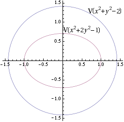

Dua elips yang tidak berpotongan

*Dua elips yang tidak berpotongan; Pmidden, dibuat dengan Mathematica; domain publik.*

### Contoh: dua kuadrik real yang tidak berpotongan

Kita tinjau dua kurva aljabar

$$V_1=V(X^2+Y^2-2),\qquad
V_2=V(X^2+2Y^2-1)\subseteq\mathbb A_K^2.$$

Untuk $K=\mathbb R$, keduanya merupakan kuadrik tak tereduksi. Irisannya dideskripsikan oleh ideal

$$(X^2+Y^2-2,X^2+2Y^2-1)=(Y^2+1,X^2-3).$$

Karena polinom $Y^2+1$ tidak memiliki akar real,

$$V_1\cap V_2=\varnothing.$$

Ideal pelenyapan irisan yang kosong tentu merupakan ideal satuan, sedangkan jumlah kedua ideal pelenyapan tersebut bukan ideal satuan.

## Gelanggang koordinat suatu himpunan aljabar afin

Misalkan $V\subseteq\mathbb A_K^n$ suatu himpunan aljabar afin dengan ideal pelenyapan $\operatorname{Id}(V)$. Setiap polinom

$$F\in K[X_1,\ldots,X_n]$$

mendefinisikan fungsi pada ruang afin, dan dengan demikian menginduksi fungsi pada subhimpunan $V$:

$$\begin{matrix}
\mathbb A_K^n&\xrightarrow{F}&K\\
\uparrow&\nearrow&\\
V&&
\end{matrix}$$

Menurut Definisi 3.4, unsur ideal pelenyapan menginduksi fungsi nol pada $V$. Dua polinom $G,H\in K[X_1,\ldots,X_n]$ yang selisihnya termasuk dalam ideal pelenyapan menginduksi fungsi yang sama pada $V$. Oleh karena itu, wajar untuk memandang gelanggang faktor

$$K[X_1,\ldots,X_n]/\operatorname{Id}(V)$$

sebagai gelanggang fungsi polinomial (atau fungsi aljabar) pada $V$.

### Definisi: gelanggang koordinat

Untuk suatu himpunan aljabar afin

$$V\subseteq\mathbb A_K^n$$

dengan ideal pelenyapan $\operatorname{Id}(V)$, gelanggang

$$R(V)=K[X_1,\ldots,X_n]/\operatorname{Id}(V)$$

disebut *gelanggang koordinat* dari $V$.

Pengertian ini tidak sepenuhnya tanpa masalah, terutama apabila $K$ tidak tertutup secara aljabar; lihat contoh-contoh di bawah. Mula-mula kita catat beberapa sifat elementer.

### Proposisi: sifat-sifat dasar gelanggang koordinat

Misalkan $V\subseteq\mathbb A_K^n$ suatu himpunan aljabar afin dan

$$R=K[X_1,\ldots,X_n]/\operatorname{Id}(V)$$

gelanggang koordinatnya. Maka berlaku pernyataan-pernyataan berikut.

1. $R$ tereduksi.
2. $V=\varnothing$ tepat ketika $R$ merupakan gelanggang nol.
3. $V$ tak tereduksi tepat ketika $R$ merupakan domain integral.
4. $V$ terdiri atas tepat satu titik ketika $R=K$.
5. Jika $K$ tertutup secara aljabar dan $V=V(\mathfrak a)$, maka

   $$R=K[X_1,\ldots,X_n]/\operatorname{rad}(\mathfrak a).$$

#### Bukti

Misalkan $I=\operatorname{Id}(V)$ ideal pelenyapan $V$.

1. Pernyataan ini mengikuti dari Lema 3.14 dan Soal 3.13.
2. Kesamaan $V=\varnothing$ ekuivalen dengan $1\in I$, dan ini ekuivalen dengan $R=0$.
3. Pernyataan ini mengikuti dari Lema 4.3 dan Soal 4.17.
4. Misalkan $V=\{P\}$ dengan $P=(a_1,\ldots,a_n)$. Maka

   $$I=(X_1-a_1,\ldots,X_n-a_n)$$

   dan gelanggang koordinatnya ialah

   $$K[X_1,\ldots,X_n]/(X_1-a_1,\ldots,X_n-a_n)\cong K.$$

   Sebaliknya, jika gelanggang koordinatnya adalah $K$, homomorfisme faktor yang bersesuaian harus merupakan homomorfisme evaluasi $X_i\mapsto a_i$. Ideal pelenyapan $V$ harus merupakan ideal titik, dan $P=(a_1,\ldots,a_n)\in V$. Jika ada titik lain $Q\in V$, $Q\ne P$, kita memperoleh kontradiksi karena tidak semua $X_i-a_i$ lenyap di $Q$.
5. Jika $K$ tertutup secara aljabar, Nullstellensatz Hilbert memberikan

   $$\operatorname{Id}(V)=\operatorname{rad}(\mathfrak a).$$

### Teorema: gelanggang koordinat ruang afin di atas lapangan tak berhingga

Misalkan $K$ lapangan tak berhingga. Ideal pelenyapan ruang afin $\mathbb A_K^n$ adalah ideal nol, dan gelanggang koordinatnya merupakan gelanggang polinomial $K[X_1,\ldots,X_n]$.

#### Bukti

Kita membuktikan pernyataan dengan induksi pada banyaknya variabel. Untuk $n=1$, pernyataan mengikuti dari fakta bahwa polinom berderajat $d$ mempunyai paling banyak $d$ akar.

Untuk langkah induksi, misalkan

$$F\in K[X_1,\ldots,X_n]$$

suatu polinom yang lenyap pada setiap titik $\mathbb A_K^n=K^n$. Tulis $F$ sebagai

$$F=P_dX_n^d+P_{d-1}X_n^{d-1}+\cdots+P_1X_n+P_0,$$

dengan

$$P_d,\ldots,P_0\in K[X_1,\ldots,X_{n-1}].$$

Kita harus menunjukkan bahwa $F=0$, yang ekuivalen dengan $P_i=0$ untuk setiap $i=0,\ldots,d$. Andaikan, tanpa mengurangi keumuman, $P_d$ bukan polinom nol. Menurut hipotesis induksi, $P_d$ juga bukan fungsi nol. Jadi, terdapat titik $(a_1,\ldots,a_{n-1})$ dengan

$$P_d(a_1,\ldots,a_{n-1})\ne0.$$

Dengan demikian, $F(a_1,\ldots,a_{n-1})$ merupakan polinom tak nol berderajat $d$ dalam satu variabel $X_n$. Menurut kasus satu variabel, polinom itu tidak dapat menjadi fungsi nol, suatu kontradiksi.

> **Catatan edisi:** Saksi TeX sumber menuliskan suku linear sebagai $P_1X_0$. Konteks ekspansi menurut variabel $X_n$ mengharuskan $P_1X_n$; edisi ini menggunakan indeks yang konsisten dan mempertahankan salah cetak sumber dalam catatan ini.

### Contoh: lapangan berhingga

Teorema 11.8 tidak benar untuk lapangan berhingga. Di atas lapangan berhingga, ruang afin hanya terdiri atas hingga banyak titik dan terdapat banyak polinom yang lenyap pada semua titik itu. Contoh khas diberikan oleh polinom

$$X_i^q-X_i,$$

dengan $q$ banyaknya unsur lapangan.

### Contoh: gelanggang faktor dan gelanggang koordinat dapat berbeda

Misalkan

$$R=\mathbb R[X,Y]/(X^2+Y^2).$$

Karena kuadrat bilangan real tidak pernah negatif, lokus nol $X^2+Y^2$ hanya terdiri atas titik asal:

$$V(X^2+Y^2)=\{(0,0)\}.$$

Ideal pelenyapannya adalah ideal maksimal $(X,Y)$, sehingga gelanggang koordinat yang bersesuaian ialah

$$\mathbb R[X,Y]/(X,Y)\cong\mathbb R.$$

Jadi, gelanggang koordinat dapat sangat berbeda dari gelanggang faktor awal yang idealnya digunakan untuk mendefinisikan lokus nol.

## Nullstellensatz Hilbert untuk himpunan aljabar afin

Nullstellensatz Hilbert yang telah dirumuskan untuk ruang afin dan gelanggang polinomial berlaku secara bersesuaian bagi setiap $V(\mathfrak a)$ dan gelanggang faktor $K[X_1,\ldots,X_n]/\mathfrak a$.

### Korolari: Nullstellensatz pada suatu himpunan aljabar afin

Misalkan $K$ lapangan yang tertutup secara aljabar dan

$$R=K[X_1,\ldots,X_n]/\mathfrak a$$

suatu $K$-aljabar tipe hingga dengan lokus nol

$$V=V(\mathfrak a)\subseteq\mathbb A_K^n.$$

Misalkan $\mathfrak b$ suatu ideal dalam $R$, dan $F\in R$ suatu unsur yang lenyap pada $V(\mathfrak b)\subseteq V$. Maka terdapat $r\in\mathbb N$ dengan

$$F^r\in\mathfrak b$$

dalam $R$.

#### Bukti

Syarat pelenyapan $V(\mathfrak b)\subseteq V(F)$ di dalam $V=V(\mathfrak a)$, jika diterjemahkan kembali ke ruang afin, menyatakan

$$V(\mathfrak a+\mathfrak b)
=V(\mathfrak a)\cap V(\mathfrak b)
\subseteq V(F),$$

dengan $F$ sekarang suatu polinom wakil dalam $K[X_1,\ldots,X_n]$ dan $\mathfrak b$ ideal prapeta di gelanggang itu. Menurut Nullstellensatz Hilbert untuk ruang afin, terdapat $r\in\mathbb N$ dengan

$$F^r\in\mathfrak a+\mathfrak b.$$

Modulo $\mathfrak a$, ini tepat berarti $F^r\in\mathfrak b$ dalam $R$.

### Korolari: penutup utama pada suatu himpunan aljabar afin

Misalkan $K$ lapangan yang tertutup secara aljabar dan $V=V(\mathfrak a)\subseteq\mathbb A_K^n$ suatu himpunan aljabar afin yang dideskripsikan oleh ideal $\mathfrak a$. Misalkan

$$F_i\in K[X_1,\ldots,X_n],\qquad i\in I,$$

sedemikian sehingga

$$V=\bigcup_{i\in I}D(F_i).$$

Maka kelas semua $F_i$ membangkitkan ideal satuan dalam $K[X_1,\ldots,X_n]/\mathfrak a$.

#### Bukti

Misalkan $\mathfrak b$ ideal dalam $K[X_1,\ldots,X_n]/\mathfrak a$ yang dibangkitkan oleh semua $F_i$, $i\in I$. Asumsi menyatakan bahwa

$$V(\mathfrak b)=\bigcap_{i\in I}V(F_i)$$

### Korolari: polinom tanpa akar merupakan unit

Misalkan $K$ lapangan yang tertutup secara aljabar dan $V=V(\mathfrak a)\subseteq\mathbb A_K^n$ suatu himpunan aljabar afin yang dideskripsikan oleh ideal $\mathfrak a$. Jika $F\in K[X_1,\ldots,X_n]$ tidak mempunyai akar pada $V$, maka kelas $F$ merupakan unit dalam gelanggang faktor

$$K[X_1,\ldots,X_n]/\mathfrak a.$$

#### Bukti

Ini merupakan kasus khusus Korolari 11.12.

Dalam Contoh 11.5, fungsi $X^2+2Y^2-1$ tidak mempunyai akar pada lokus nol real $V(X^2+Y^2-2)$, sehingga fungsi itu bernilai unit di setiap titik lokus tersebut. Namun, fungsi itu bukan unit dalam gelanggang koordinat

$$\mathbb R[X,Y]/(X^2+Y^2-2).$$

# Lembar Kerja 11

## Soal latihan

### Soal 11.1

Misalkan $K$ suatu lapangan yang tertutup secara aljabar. Buktikan Nullstellensatz Hilbert secara langsung untuk gelanggang polinomial dalam satu variabel.

### Soal 11.2

Misalkan $K$ suatu lapangan yang tertutup secara aljabar dan

$$f,g\in K[X_1,\ldots,X_n].$$

Tunjukkan bahwa

$$V(f)\subseteq V(g)$$

tepat ketika terdapat bilangan asli $r$ dan $h\in K[X_1,\ldots,X_n]$ dengan

$$fh=g^r.$$

Tinjau juga kasus-kasus khusus ketika $f$, atau ketika $g$, merupakan polinom konstan.

### Soal 11.3

Tunjukkan bahwa dalam korespondensi yang diberikan oleh Nullstellensatz Hilbert, titik-titik berkorespondensi dengan ideal-ideal maksimal.

### Soal 11.4

Tunjukkan bahwa dalam korespondensi yang diberikan oleh Nullstellensatz Hilbert, varietas-varietas tak tereduksi berkorespondensi dengan ideal-ideal prima.

### Soal 11.5

Misalkan $K$ suatu lapangan yang tertutup secara aljabar. Buktikan secara langsung kasus khusus Nullstellensatz Hilbert berikut: jika

$$f\in K[X_1,\ldots,X_n]$$

tidak mempunyai akar dalam $K^n$, maka $f$ merupakan polinom konstan yang tidak nol.

### Soal 11.6 ★

Tinjau kedua polinom $X^2+Y^2$ dan $X^2-Y^3$, beserta kurva aljabar yang bersesuaian di atas lapangan $\mathbb R$ dan $\mathbb C$.

1. Apakah

   $$V(X^2+Y^2)\subseteq V(X^2-Y^3)$$

   berlaku dalam $\mathbb A_{\mathbb R}^2$?
2. Apakah inklusi yang sama berlaku dalam $\mathbb A_{\mathbb C}^2$?
3. Apakah $X^2-Y^3$ termasuk dalam radikal $(X^2+Y^2)$ di $\mathbb R[X,Y]$?
4. Apakah $X^2-Y^3$ termasuk dalam radikal $(X^2+Y^2)$ di $\mathbb C[X,Y]$?

### Soal 11.7 ★

Misalkan diberikan polinom-polinom

$$f_1,\ldots,f_k\in\mathbb C[X_1,\ldots,X_n],$$

yang dipandang sebagai fungsi

$$f_i:\mathbb C^n\longrightarrow\mathbb C.$$

Misalkan $f\in\mathbb C[X_1,\ldots,X_n]$ suatu polinom lain, dan misalkan

$$g_1,\ldots,g_k:\mathbb C^n\longrightarrow\mathbb C$$

fungsi-fungsi yang tidak harus polinomial. Andaikan berlaku kesamaan fungsi

$$f=g_1f_1+\cdots+g_kf_k.$$

Tunjukkan bahwa $f$ termasuk dalam radikal $(f_1,\ldots,f_k)$.

### Soal 11.8

Misalkan $K$ suatu lapangan dan $n\in\mathbb N_+$. Tunjukkan bahwa semua fungsi $\varphi:K^n\to K$ yang berbentuk

$$\varphi=\frac{P}{Q},$$

dengan $P,Q\in K[X_1,\ldots,X_n]$ dan $Q$ tidak mempunyai akar pada $K^n$, membentuk suatu gelanggang komutatif. Tunjukkan bahwa jika $K$ tertutup secara aljabar, gelanggang ini sama dengan gelanggang polinomial.

### Soal 11.9

Misalkan $K$ suatu lapangan berhingga. Tunjukkan bahwa hanya terdapat hingga banyak lokus nol dalam $\mathbb A_K^n$, tetapi terdapat takhingga banyak ideal radikal dalam $K[X_1,\ldots,X_n]$.

### Soal 11.10

Misalkan $R$ suatu gelanggang komutatif dan $f_j$, $j\in J$, suatu keluarga unsur dalam $R$. Andaikan semua $f_j$ bersama-sama membangkitkan ideal satuan. Tunjukkan bahwa terdapat subkeluarga berhingga

$$f_j,\qquad j\in J_0\subseteq J,$$

yang juga membangkitkan ideal satuan.

### Soal 11.11

Misalkan $K$ suatu lapangan yang tertutup secara aljabar dan

$$\mathfrak a,\mathfrak b\subseteq K[X_1,\ldots,X_n]$$

ideal-ideal radikal. Tunjukkan bahwa lokus-lokus nol $V(\mathfrak a)$ dan $V(\mathfrak b)$ ekuivalen secara afin-linear tepat ketika terdapat transformasi variabel afin-linear yang membawa kedua ideal itu satu ke yang lain.

### Sisipan: ideal perluasan

Misalkan

$$\varphi:A\longrightarrow B$$

suatu homomorfisme gelanggang antara gelanggang komutatif $A$ dan $B$. Untuk suatu ideal $\mathfrak a\subseteq A$, ideal dalam $B$ yang dibangkitkan oleh $\varphi(\mathfrak a)$ disebut *ideal perluasan* dari $\mathfrak a$ di bawah $\varphi$. Ideal itu ditulis $\mathfrak aB$. Jika $\varphi$ surjektif, ideal ini hanyalah ideal citra.

### Soal 11.12

Misalkan

$$\mathfrak a\subseteq\mathbb R[X_1,\ldots,X_n]$$

suatu ideal dan $f\in\mathbb R[X_1,\ldots,X_n]$. Tunjukkan bahwa $f\in\mathfrak a$ tepat ketika

$$f\in\mathfrak a\mathbb C[X_1,\ldots,X_n]$$

untuk ideal perluasan tersebut.

### Soal 11.13

Buat sketsa grafik fungsi $x$ dan $y$ pada $V(xy)$. Yakinkan diri Anda bahwa hasil kali $xy$ merupakan fungsi nol.

### Soal 11.14

Tentukan gelanggang koordinat suatu himpunan aljabar afin $V\subseteq\mathbb A_K^n$ yang terdiri atas $d$ titik.

### Soal 11.15

Tentukan gelanggang koordinat himpunan aljabar afin

$$V=V(5X-8Y+3)\subseteq\mathbb A_K^2.$$

### Soal 11.16

Tinjau hiperbola $V(xy-1)$ di atas lapangan $K=\mathbb Z/(11)$. Tentukan invers dari $4x^3$ dalam gelanggang koordinat yang bersesuaian.

### Soal 11.17

Misalkan $K$ suatu lapangan dan

$$V,W\subseteq\mathbb A_K^n$$

himpunan-himpunan aljabar afin dengan $V\subseteq W$. Definisikan suatu homomorfisme $K$-aljabar antara kedua gelanggang koordinat $R(V)$ dan $R(W)$, lalu deskripsikan sifat-sifat terpentingnya. Berikan contoh dua himpunan aljabar afin yang tidak saling termuat, tetapi gelanggang koordinatnya isomorfik.

### Soal 11.18

Misalkan $K$ suatu lapangan dan

$$\mathfrak a,\mathfrak b\subseteq K[X_1,\ldots,X_n]$$

ideal-ideal dengan radikal yang sama. Tunjukkan bahwa terdapat bijeksi alami antara ideal-ideal radikal dalam gelanggang-gelanggang faktor

$$K[X_1,\ldots,X_n]/\mathfrak a
\qquad\text{dan}\qquad
K[X_1,\ldots,X_n]/\mathfrak b.$$

### Soal 11.19

Misalkan $K$ suatu lapangan dengan $q$ unsur dan $V=V(\mathfrak a)\subseteq\mathbb A_K^n$ suatu himpunan aljabar afin. Tunjukkan bahwa gelanggang koordinat $V$ tidak harus sama dengan

$$K[x_1,\ldots,x_n]\big/
\big((x_1^q-x_1,\ldots,x_n^q-x_n)+\mathfrak a\big).$$

> **Catatan edisi:** Sumber menempatkan $+\mathfrak a$ secara tipografis di luar penyebut gelanggang faktor. Tanda kurung di atas membuat pembacaan matematis yang dimaksud menjadi eksplisit.

### Soal 11.20

Misalkan $K$ suatu lapangan berkarakteristik $0$. Tinjau irisan sebuah silinder dan sebuah bola,

$$C=V(X^2+Y^2-1)\cap
V((X-3)^2+Y^2+Z^2-7)\subseteq\mathbb A_K^3.$$

Tunjukkan bahwa gelanggang koordinat $C$ dapat ditulis sebagai gelanggang faktor dari suatu gelanggang polinomial dalam dua variabel.

## Soal untuk dikumpulkan

### Soal 11.21 (4 poin)

Misalkan $F\in\mathbb C[X_1,\ldots,X_n]$ dan $U\subseteq\mathbb A_{\mathbb C}^n$ suatu subhimpunan yang terbuka dan tak kosong dalam topologi metrik. Jika $F|_U=0$ sebagai fungsi nol, tunjukkan bahwa $F$ merupakan polinom nol.

### Soal 11.22 (3 poin)

Buktikan Korolari 11.3 secara langsung dari Teorema 10.10.

### Soal 11.23 (7 poin)

Misalkan $K$ suatu lapangan yang tertutup secara aljabar dan $R$ gelanggang polinomial dalam $n$ variabel di atas $K$. Kita akan melihat bukti alternatif, berdasarkan Korolari 11.3, bahwa

$$\operatorname{Id}(V(J))=\operatorname{rad}(J)$$

untuk setiap ideal $J$ dalam $R$. Misalkan $f\in\operatorname{Id}(V(J))$. Tinjau gelanggang $R[T]$ dan tunjukkan bahwa ideal

$$J'=(J,1-f\cdot T)$$

adalah ideal satuan. Simpulkan bahwa $f$ termasuk dalam radikal $J$.

### Soal 11.24 (3 poin)

Misalkan $F\in K[X_1,\ldots,X_n]$ dan tinjau pemetaan polinomial

$$\begin{aligned}
\varphi:\mathbb A_K^n&\longrightarrow\mathbb A_K^{n+1},\\
(x_1,\ldots,x_n)&\longmapsto
(x_1,\ldots,x_n,F(x_1,\ldots,x_n)),
\end{aligned}$$

yang mendefinisikan bijeksi antara ruang afin dan grafik $F$. Untuk suatu himpunan aljabar afin $V(\mathfrak a)\subseteq\mathbb A_K^n$, tinjau citra $V'=\varphi(V)$. Tunjukkan bahwa $V'$ juga aljabar afin dan berikan ideal yang mendeskripsikannya. Tunjukkan bahwa $V$ tak tereduksi tepat ketika $V'$ tak tereduksi.

### Soal 11.25 (5 poin)

Tinjau dua kurva aljabar

$$V(x^2+y^2-2)
\qquad\text{dan}\qquad
V(x^2+2y^2-1)$$

di atas lapangan $\mathbb Z/(7)$. Tunjukkan bahwa irisannya kosong, lalu temukan suatu lapangan perluasan $K\supseteq\mathbb Z/(7)$ yang membuat irisannya tak kosong. Hitung semua titik irisan di atas $K$ dan di atas setiap lapangan perluasan lainnya. Deskripsikan juga gelanggang koordinat irisan itu.

### Soal 11.26 (4 poin)

Misalkan $K$ suatu lapangan, dan $P_1,\ldots,P_n$ hingga banyak titik dalam bidang afin $\mathbb A_K^2$. Misalkan $a_1,\ldots,a_n\in K$ nilai-nilai sebarang yang telah ditentukan. Tunjukkan bahwa terdapat polinom $F\in K[X,Y]$ dengan

$$F(P_i)=a_i\qquad\text{untuk setiap }i=1,\ldots,n.$$

# Solusi Publik Lembar Kerja 11

Sumber hanya menyediakan solusi publik untuk Soal 11.6 dan 11.7 pada batas revisi yang dibekukan. Tidak ada solusi tambahan yang dibuat untuk edisi ini.

## Solusi Soal 11.6

1. Satu-satunya titik real pada $V(X^2+Y^2)$ adalah titik asal $(0,0)$, dan titik ini berada pada $V(X^2-Y^3)$. Jadi,

   $$V(X^2+Y^2)\subseteq V(X^2-Y^3)
   \subseteq\mathbb A_{\mathbb R}^2.$$
2. Inklusi yang bersesuaian tidak berlaku di atas bilangan kompleks. Sebagai contoh,

   $$(1,\mathrm i)\in V(X^2+Y^2),$$

   tetapi karena $1\ne\mathrm i^3$, titik itu tidak berada pada $V(X^2-Y^3)$.
3. Andaikan $X^2-Y^3$ termasuk dalam radikal $(X^2+Y^2)$ di $\mathbb R[X,Y]$. Setelah perluasan skalar, hal yang sama akan langsung berlaku di $\mathbb C[X,Y]$. Namun, menurut butir berikut, hal itu tidak berlaku.
4. Dari butir (2) dan arah mudah Nullstellensatz Hilbert, diperoleh bahwa $X^2-Y^3$ tidak termasuk dalam radikal $(X^2+Y^2)$ di $\mathbb C[X,Y]$.

Kembali ke Soal 11.6.

## Solusi Soal 11.7

Kita klaim bahwa

$$V(f_1,\ldots,f_k)\subseteq V(f).$$

Setelah klaim ini terbukti, Nullstellensatz Hilbert menyatakan bahwa $f$ termasuk dalam radikal $(f_1,\ldots,f_k)$.

Misalkan

$$P=(x_1,\ldots,x_n)\in\mathbb C^n$$

dan $P\in V(f_1,\ldots,f_k)$. Ini berarti $f_i(P)=0$ untuk setiap $i$. Maka

$$\begin{aligned}
f(P)
&=(g_1f_1+\cdots+g_kf_k)(P)\\
&=g_1(P)f_1(P)+\cdots+g_k(P)f_k(P)\\
&=0.
\end{aligned}$$

Jadi $P\in V(f)$, yang membuktikan klaim.

Kembali ke Soal 11.7.

# Kuliah 12: Spektrum-$K$ dan Funktorialitasnya

> “Terlahir untuk melihat, ditugaskan untuk memandang.”

> — Johann Wolfgang von Goethe

## Spektrum-$K$

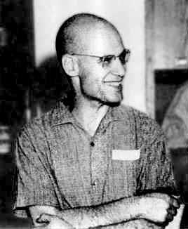

*Alexander Grothendieck (1928–2014); foto: Konrad Jacobs, Oberwolfach Photo Collection/MFO; [CC BY-SA 2.0 de](https://creativecommons.org/licenses/by-sa/2.0/de/deed.en).*

Bagaimana himpunan aljabar afin dan gelanggang koordinatnya saling berhubungan? Jawaban yang bermakna hanya dapat diharapkan untuk lapangan dasar yang tak hingga, karena dalam kasus berhingga jumlah titiknya terlalu sedikit. Teori yang memuaskan bahkan mengharuskan kita membatasi diri pada lapangan yang tertutup secara aljabar, atau—dan inilah sudut pandang teori skema yang dikembangkan Alexander Grothendieck—tidak hanya meninjau titik-$K$, tetapi juga memasukkan ideal maksimal dan ideal prima sebagai titik.

Pertanyaan penting pertama ialah sebagai berikut. Suatu aljabar-$K$ $R$ bertipe hingga mempunyai beberapa representasi, yang pada umumnya berkedudukan sama, sebagai gelanggang faktor dari suatu aljabar polinomial; misalnya,

$$K[X_1,\ldots,X_n]/\mathfrak a
\cong R
\cong K[X_1,\ldots,X_m]/\mathfrak b.$$

Kedua representasi ini menghasilkan lokus nol

$$V(\mathfrak a)\subseteq\mathbb A_K^n
\qquad\text{dan}\qquad
V(\mathfrak b)\subseteq\mathbb A_K^m.$$

Bagaimana kedua lokus nol tersebut saling berhubungan?

### Contoh: tiga representasi garis afin

Tinjau gelanggang polinomial satu variabel

$$R=K[T].$$

Objek yang pertama-tama bersesuaian dengannya ialah garis afin $\mathbb A_K^1$. Akan tetapi, $R$ juga dapat diperoleh dengan berbagai cara sebagai gelanggang faktor dari aljabar polinomial dalam lebih dari satu variabel. Misalkan, sebagai contoh,

$$a\in K,\qquad a\ne0,$$

dan tinjau gelanggang faktor $K[X,Y]/(aY+bX)$. Gelanggang ini, sebagai aljabar-$K$, isomorfik dengan $R$, seperti ditunjukkan oleh pemetaan

$$\begin{aligned}
K[X,Y]/(aY+bX)&\longrightarrow K[T],\\
X&\longmapsto T,\\
Y&\longmapsto-\frac baT.
\end{aligned}$$

Lokus nol yang bersesuaian,

$$V(aY+bX)\subset\mathbb A_K^2,$$

hanyalah garis di bidang afin yang dideskripsikan oleh persamaan

$$Y=-\frac baX.$$

Cara lain untuk merepresentasikan gelanggang polinomial satu variabel sebagai gelanggang faktor ialah

$$K[X,Y]/(Y-P(X)),$$

dengan $P(X)$ suatu polinom sembarang dalam satu variabel $X$. Homomorfisme gelanggang

$$\begin{aligned}
K[X,Y]/(Y-P(X))&\longrightarrow K[T],\\
X&\longmapsto T,\\
Y&\longmapsto P(T)
\end{aligned}$$

kembali menunjukkan adanya isomorfisme dengan gelanggang polinomial satu variabel. Lokus nol yang bersesuaian hanyalah grafik polinom $P(X)$.

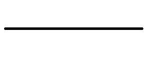

Garis horizontal hitam

*Garis horizontal; Astur1, domain publik.*

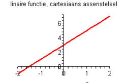

Grafik garis lurus merah pada sistem koordinat Kartesius

*Grafik fungsi linear pada koordinat Kartesius; MADe, [CC BY-SA 3.0](http://creativecommons.org/licenses/by-sa/3.0/).*

Inti contoh ini ialah bahwa ketiga objek geometris tersebut merupakan himpunan nol bagi representasi gelanggang faktor yang berbeda dari $K[T]$. Dari sudut pandang geometri aljabar, ketiganya adalah representasi yang berkedudukan sama dari garis afin, walaupun “penampilan” mereka berbeda. Dalam geometri aljabar kita harus memandangnya dengan cara yang membuat mereka tampak sama. Yang terlihat hanyalah pembenaman berbeda dari objek geometris “sejati” yang secara intrinsik bersesuaian dengan suatu aljabar-$K$, yaitu spektrum-$K$.

### Definisi: spektrum-$K$

Untuk suatu aljabar-$K$ komutatif $R$ bertipe hingga, himpunan semua homomorfisme aljabar-$K$

$$\operatorname{Hom}_K(R,K)$$

disebut *spektrum-$K$* dari $R$ dan dinotasikan dengan

$$K\!-\!\operatorname{Spek}(R).$$

Unsur-unsur dalam spektrum-$K$ $K\!-\!\operatorname{Spek}(R)$ kita pandang sebagai titik dan biasanya kita lambangkan dengan $P$, walaupun menurut definisi unsur-unsur itu adalah pemetaan, yakni homomorfisme aljabar-$K$ dari $R$ ke $K$. Untuk suatu unsur gelanggang $f\in R$, kita kemudian menulis $f(P)$, bukan $P(f)$, untuk nilai $f$ di bawah homomorfisme gelanggang yang dilambangkan dengan $P$. Memang, lazim pula untuk memandang sebuah titik sebagai evaluasi fungsi-fungsi yang terdefinisi di suatu lingkungan titik tersebut.

Spektrum-$K$ kembali dilengkapi dengan topologi Zariski. Untuk suatu ideal $\mathfrak a\subseteq R$—atau bahkan untuk sembarang subhimpunan dari $R$—kita menetapkan subhimpunan

$$V(\mathfrak a)
=\left\{P\in K\!-\!\operatorname{Spek}(R)
\mid f(P)=0\ \text{untuk semua }f\in\mathfrak a\right\}$$

sebagai himpunan tertutup. Penetapan ini benar-benar mendefinisikan suatu topologi; lihat Soal 12.8. Komplemen terbukanya dilambangkan dengan $D(\mathfrak a)$.

### Lema: titik ruang afin sebagai homomorfisme

Misalkan $K$ suatu lapangan dan $K[X_1,\ldots,X_n]$ gelanggang polinomial dalam $n$ variabel. Homomorfisme aljabar-$K$ dari $K[X_1,\ldots,X_n]$ ke $K$ berkorespondensi secara bijektif dan alami dengan titik-titik ruang afin

$$\mathbb A_K^n=K^n.$$

Titik $(a_1,\ldots,a_n)$ bersesuaian dengan homomorfisme substitusi $X_i\mapsto a_i$. Dengan kata lain,

$$K\!-\!\operatorname{Spek}\bigl(K[X_1,\ldots,X_n]\bigr)
=\mathbb A_K^n.$$

#### Bukti

Suatu homomorfisme aljabar-$K$ selalu ditentukan oleh sebuah sistem pembangkit aljabar-$K$. Jadi nilai-nilai pada variabel $X_i$ menentukan homomorfisme aljabar-$K$ dari $K[X_1,\ldots,X_n]$ ke $K$. Homomorfisme substitusi demikian ditentukan oleh $X_i\mapsto a_i$, dan di sini setiap pilihan nilai $(a_1,\ldots,a_n)$ diperbolehkan.

### Contoh: spektrum-$K$ dari $K$

Spektrum-$K$ dari aljabar-$K$ $K$ hanya terdiri atas satu titik: identitas

$$\operatorname{id}:K\longrightarrow K$$

adalah satu-satunya homomorfisme aljabar-$K$ dari $K$ ke $K$. Secara umum mungkin ada automorfisme lapangan lain pada $K$, tetapi automorfisme itu bukan homomorfisme aljabar-$K$.

Teorema berikut sangat penting karena memberikan hubungan bijektif antara spektrum-$K$ dari $R$ dan lokus nol yang berasal dari suatu representasi gelanggang faktor dari $R$.

### Teorema: spektrum-$K$ dan lokus nol

Misalkan $K$ suatu lapangan dan $R$ aljabar-$K$ komutatif yang dibangkitkan secara hingga, dengan spektrum-$K$ $K\!-\!\operatorname{Spek}(R)$. Misalkan

$$R=K[X_1,\ldots,X_n]/\mathfrak a$$

suatu representasi gelanggang faktor dari $R$, dengan homomorfisme faktor

$$\varphi:K[X_1,\ldots,X_n]\longrightarrow R$$

dan lokus nol yang bersesuaian $V(\mathfrak a)\subseteq\mathbb A_K^n$. Pemetaan

$$\begin{aligned}
K\!-\!\operatorname{Spek}(R)&\longrightarrow\mathbb A_K^n,\\
P&\longmapsto P\circ\varphi
\end{aligned}$$

memberikan bijeksi antara $K\!-\!\operatorname{Spek}(R)$ dan $V(\mathfrak a)$, dan bijeksi tersebut merupakan homeomorfisme terhadap topologi Zariski.

#### Bukti

Mula-mula, pemetaan di atas terdefinisi dengan baik karena komposisi

$$P\circ\varphi:
K[X_1,\ldots,X_n]
\xrightarrow{\varphi}K[X_1,\ldots,X_n]/\mathfrak a
\cong R\xrightarrow{P}K$$

mendefinisikan homomorfisme aljabar-$K$ dari gelanggang polinomial ke $K$. Menurut Lema 12.3, homomorfisme ini adalah homomorfisme substitusi pada suatu $(a_1,\ldots,a_n)$ dan dapat diidentifikasi dengan titik yang bersesuaian di ruang afin; secara tepat,

$$a_i=P\bigl(\varphi(X_i)\bigr).$$

Karena $P\circ\varphi$ memfaktor melalui $R$, ideal $\mathfrak a$ dipetakan ke $0$. Jadi titik citra

$$P\circ\varphi=(a_1,\ldots,a_n)$$

terletak di $V(\mathfrak a)$. Dengan demikian kita memperoleh pemetaan

$$\begin{aligned}
K\!-\!\operatorname{Spek}(R)&\longrightarrow
V(\mathfrak a)\subseteq\mathbb A_K^n,\\
P&\longmapsto P\circ\varphi,
\end{aligned}$$

yang tinggal dibuktikan bijektif.

Misalkan $P_1,P_2\in K\!-\!\operatorname{Spek}(R)$ dua titik berbeda. Keduanya adalah homomorfisme aljabar-$K$ yang berbeda. Karena homomorfisme aljabar-$K$ ditentukan oleh nilainya pada suatu sistem pembangkit aljabar-$K$, keduanya harus berbeda pada setidaknya satu citra variabel. Maka koordinat yang bersesuaian juga berbeda, sehingga $P_1\circ\varphi\ne P_2\circ\varphi$. Jadi pemetaan tersebut injektif.

Untuk surjektivitas, misalkan $(a_1,\ldots,a_n)\in V(\mathfrak a)$. Homomorfisme aljabar-$K$ yang bersesuaian,

$$\begin{aligned}
K[X_1,\ldots,X_n]&\longrightarrow K,\\
X_i&\longmapsto a_i,
\end{aligned}$$

melenyapkan setiap $F\in\mathfrak a$. Oleh sebab itu homomorfisme gelanggang ini memfaktor melalui $K[X_1,\ldots,X_n]/\mathfrak a$. Homomorfisme hasil faktorisasi itulah prapeta yang dicari di $K\!-\!\operatorname{Spek}(R)$.

Untuk bagian topologi, ambil $G\in R$, suatu prapeta $\widetilde G\in K[X_1,\ldots,X_n]$, dan titik $P\in K\!-\!\operatorname{Spek}(R)$ dengan titik citra $\widetilde P=P\circ\varphi\in V(\mathfrak a)$. Maka

$$G(P)=P(G)=P\bigl(\varphi(\widetilde G)\bigr)
=(P\circ\varphi)(\widetilde G)
=\widetilde G(\widetilde P),$$

sehingga lokus nol pada kedua sisi juga berkorespondensi. Dengan demikian bijeksi tersebut merupakan homeomorfisme.

Teorema ini mengatakan bahwa setiap spektrum-$K$ dari suatu aljabar-$K$ bertipe hingga $R$ dapat diidentifikasi dengan himpunan tertutup Zariski dalam suatu $\mathbb A_K^n$. Identifikasi demikian disebut *pembenaman tertutup*.

### Korolari: independensi topologis dari representasi

Misalkan $K$ suatu lapangan dan $R$ aljabar-$K$ komutatif yang dibangkitkan secara hingga dengan dua representasi gelanggang faktor

$$R\cong K[X_1,\ldots,X_n]/\mathfrak a
\qquad\text{dan}\qquad
R\cong K[X_1,\ldots,X_m]/\mathfrak b,$$

beserta lokus nol yang bersesuaian

$$V(\mathfrak a)\subseteq\mathbb A_K^n
\qquad\text{dan}\qquad
V(\mathfrak b)\subseteq\mathbb A_K^m.$$

Dengan topologi Zariski terinduksinya, kedua lokus nol tersebut homeomorfik.

#### Bukti

Menurut Teorema 12.5, kedua lokus nol homeomorfik dengan $K\!-\!\operatorname{Spek}(R)$, sehingga keduanya juga homeomorfik satu sama lain.

Jika $R$ adalah gelanggang nol, spektrum-$K$-nya kosong. Jika $K$ tidak tertutup secara aljabar, spektrum gelanggang lain pun dapat kosong. Akan tetapi, jika $K$ tertutup secara aljabar dan $R\ne0$, spektrumnya tidak kosong. Dalam keadaan ini berlaku lagi suatu Nullstellensatz Hilbert; lihat Soal 12.10.

## Spektrum-$K$ sebagai funktor

### Teorema: pemetaan spektrum

Misalkan $K$ suatu lapangan, $R$ dan $S$ aljabar-$K$ komutatif bertipe hingga, serta

$$\varphi:R\longrightarrow S$$

suatu homomorfisme aljabar-$K$. Homomorfisme ini menginduksi pemetaan

$$\begin{aligned}
\varphi^*:K\!-\!\operatorname{Spek}(S)&\longrightarrow
K\!-\!\operatorname{Spek}(R),\\
P&\longmapsto P\circ\varphi.
\end{aligned}$$

Pemetaan ini kontinu terhadap topologi Zariski.

#### Bukti

Keberadaan pemetaan tersebut jelas: kepada homomorfisme aljabar-$K$ $P:S\to K$ kita pasangkan komposisi

$$R\xrightarrow{\varphi}S\xrightarrow{P}K.$$

Prapeta himpunan terbuka $D(f)\subseteq K\!-\!\operatorname{Spek}(R)$ ialah

$$\begin{aligned}
(\varphi^*)^{-1}(D(f))
&=\{P\in K\!-\!\operatorname{Spek}(S)
\mid\varphi^*(P)\in D(f)\}\\
&=\{P\in K\!-\!\operatorname{Spek}(S)
\mid P\circ\varphi\in D(f)\}\\
&=\{P\in K\!-\!\operatorname{Spek}(S)
\mid(P\circ\varphi)(f)\ne0\}\\
&=\{P\in K\!-\!\operatorname{Spek}(S)
\mid P(\varphi(f))\ne0\}\\
&=D(\varphi(f)).
\end{aligned}$$

Jadi prapeta himpunan terbuka kembali terbuka, dan pemetaan tersebut kontinu.

Pemetaan $\varphi^*$ yang diperkenalkan dalam Teorema 12.7 disebut *pemetaan spektrum* yang bersesuaian dengan $\varphi$.

### Proposisi: beberapa bentuk pemetaan spektrum

Misalkan $K$ suatu lapangan dan $\varphi:R\to S$ homomorfisme aljabar-$K$ antara aljabar-$K$ bertipe hingga, dengan $\varphi^*$ pemetaan spektrum yang bersesuaian. Pernyataan-pernyataan berikut berlaku.

1. Untuk suatu homomorfisme aljabar-$K$ $P:R\to K$, pemetaan spektrum terinduksi $P^*$ adalah pemetaan yang membawa satu-satunya titik

   $$\{\operatorname{id}\}=K\!-\!\operatorname{Spek}(K)$$

   ke titik $P\in K\!-\!\operatorname{Spek}(R)$.
2. Homomorfisme substitusi yang ditentukan oleh $F\in R$,

   $$\begin{aligned}
   \varphi:K[T]&\longrightarrow R,\\
   T&\longmapsto F,
   \end{aligned}$$

   menginduksi pemetaan spektrum

   $$\begin{aligned}
   \varphi^*:K\!-\!\operatorname{Spek}(R)&\longrightarrow
   K\!-\!\operatorname{Spek}(K[T])=\mathbb A_K^1,\\
   P&\longmapsto F(P).
   \end{aligned}$$
3. Jika $\varphi:R\to S$ surjektif, maka pemetaan spektrum

   $$\varphi^*:K\!-\!\operatorname{Spek}(S)\longrightarrow
   K\!-\!\operatorname{Spek}(R)$$

   merupakan pembenaman tertutup dengan citra $V(\ker\varphi)$.
4. Pemetaan spektrum yang bersesuaian dengan pemetaan surjektif

   $$K[X_1,\ldots,X_n]\longrightarrow S$$

   sama dengan pemetaan

   $$\varphi^*:K\!-\!\operatorname{Spek}(S)\longrightarrow
   K\!-\!\operatorname{Spek}(K[X_1,\ldots,X_n])
   \cong\mathbb A_K^n$$

   yang didefinisikan dalam Teorema 12.5.
5. Misalkan $F_i\in K[X_1,\ldots,X_n]$ untuk $i=1,\ldots,m$, dan

   $$\begin{aligned}
   \varphi:K[Y_1,\ldots,Y_m]&\longrightarrow K[X_1,\ldots,X_n],\\
   Y_i&\longmapsto F_i
   \end{aligned}$$

   homomorfisme substitusi yang bersesuaian. Dengan identifikasi pada Lema 12.3, pemetaan spektrum

   $$\varphi^*:\mathbb A_K^n
   =K\!-\!\operatorname{Spek}(K[X_1,\ldots,X_n])
   \longrightarrow
   \mathbb A_K^m
   =K\!-\!\operatorname{Spek}(K[Y_1,\ldots,Y_m])$$

   sama dengan pemetaan polinomial langsung

   $$(x_1,\ldots,x_n)\longmapsto
   \bigl(F_1(x_1,\ldots,x_n),\ldots,F_m(x_1,\ldots,x_n)\bigr).$$

#### Bukti

1. mengikuti dari $\operatorname{id}\circ P=P$.

Untuk (2), pada komposisi

$$K[T]\xrightarrow{\varphi}R\xrightarrow{P}K,$$

$T$ dipetakan ke $P(F)=F(P)$.

3. didasarkan pada pertimbangan serupa dengan yang digunakan dalam bukti Teorema 12.5; pertimbangan itu juga membuktikan (4). Untuk (5), lihat Soal 12.18.

Pernyataan (2) khususnya mengatakan bahwa unsur-unsur gelanggang $R$ dapat dipandang sebagai fungsi dari spektrum-$K$ $K\!-\!\operatorname{Spek}(R)$ ke $\mathbb A_K^1$. Jadi kita telah memperkenalkan suatu objek geometris yang merealisasikan unsur gelanggang sebagai fungsi.

## Sifat lain spektrum-$K$

### Lema: menambahkan satu variabel

Misalkan $K$ suatu lapangan dan $R$ aljabar-$K$ komutatif yang dibangkitkan secara hingga. Maka terdapat bijeksi alami

$$K\!-\!\operatorname{Spek}(R[X])
\cong K\!-\!\operatorname{Spek}(R)\times\mathbb A_K^1.$$

#### Bukti

Suatu homomorfisme aljabar-$K$ $R[T]\to K$ menginduksi homomorfisme aljabar-$K$ $R\to K$, sementara $T$ dipetakan ke suatu unsur tertentu $a\in K$. Sebaliknya, kedua data tersebut menentukan sebuah homomorfisme aljabar-$K$ $R[T]\to K$ secara unik.

Peringatan: pernyataan di atas hanya memberikan bijeksi alami pada tingkat titik. Jika himpunan produk di sebelah kanan diberi topologi produk, bijeksi ini bukan homeomorfisme dengan topologi Zariski di sebelah kiri. Secara khusus,

$$\mathbb A_K^2=\mathbb A_K^1\times\mathbb A_K^1,$$

tetapi topologi Zariski pada bidang afin bukan topologi produk dari topologi Zariski pada garis afin dengan dirinya sendiri.

### Catatan: produk melalui hasil kali tensor

Jika

$$X=K\!-\!\operatorname{Spek}(R)
\qquad\text{dan}\qquad
Y=K\!-\!\operatorname{Spek}(S),$$

maka himpunan produk $X\times Y$ juga dapat direpresentasikan sebagai spektrum-$K$ suatu aljabar-$K$, yaitu

$$X\times Y\cong
K\!-\!\operatorname{Spek}(R\otimes_K S),$$

dengan $\otimes$ menyatakan hasil kali tensor. Kita tidak akan membahasnya secara terperinci. Untuk memperoleh gambaran, ambil

$$R=K[X_1,\ldots,X_n]/\mathfrak a
\qquad\text{dan}\qquad
S=K[Y_1,\ldots,Y_m]/\mathfrak b.$$

Maka

$$R\otimes_K S
\cong
K[X_1,\ldots,X_n,Y_1,\ldots,Y_m]/(\mathfrak a+\mathfrak b).$$

Untuk definisi *ad hoc* ini, belum jelas bahwa hasilnya tidak bergantung pada pilihan representasi gelanggang faktor.

# Lembar Kerja 12

## Soal latihan

### Soal 12.1

Jelaskan konsep titik dalam geometri Euklides (tanpa koordinat) dan dalam geometri Kartesius. Dalam situasi apa peralihan ke koordinat berguna?

### Soal 12.2

Apa yang dimaksud dengan titik dalam geometri aljabar? Konsep-konsep titik apa yang telah Anda jumpai dalam kuliah tentang kurva aljabar, dan bagaimana konsep-konsep tersebut saling berhubungan?

### Soal 12.3

Tentukan spektrum-$K$ dari $K^d$.

### Soal 12.4

Tentukan spektrum-$\mathbb R$ dari aljabar-$\mathbb R$ $\mathbb C$.

### Soal 12.5

Tentukan spektrum-$\mathbb R$ dari

$$\mathbb R[X,Y]/(X^2+Y^2-1).$$

### Soal 12.6 ★

Misalkan $K$ lapangan yang tertutup secara aljabar dan $R$ aljabar-$K$ komutatif bertipe hingga. Tunjukkan bahwa titik-titik

$$K\!-\!\operatorname{Spek}(R)$$

berkorespondensi dengan ideal-ideal maksimal di $R$.

### Soal 12.7

Misalkan $R$ aljabar-$K$ komutatif bertipe hingga. Tunjukkan bahwa, untuk setiap ideal $\mathfrak a\subseteq R$, berlaku

$$V(\mathfrak a)=V\bigl(\operatorname{rad}(\mathfrak a)\bigr)$$

di dalam $K\!-\!\operatorname{Spek}(R)$.

### Soal 12.8

Tunjukkan bahwa topologi Zariski pada spektrum-$K$ dari aljabar-$K$ komutatif bertipe hingga $R$ benar-benar merupakan suatu topologi.

### Soal 12.9

Misalkan $K$ suatu lapangan dan

$$V\subseteq\mathbb A_K^n$$

suatu himpunan aljabar afin dengan ideal pelenyapan $\operatorname{Id}(V)$ dan gelanggang koordinat

$$R:=K[X_1,\ldots,X_n]/\operatorname{Id}(V).$$

Tunjukkan bahwa spektrum-$K$ dari $R$ homeomorfik dengan $V$.

Semua versi Nullstellensatz Hilbert, seperti Korolari 11.11, berlaku pula bagi spektrum-$K$ dari suatu aljabar-$K$ bertipe hingga di atas lapangan tertutup secara aljabar $K$.

### Soal 12.10

Misalkan $K$ lapangan yang tertutup secara aljabar dan $R$ suatu aljabar-$K$ bertipe hingga. Buktikan bahwa terdapat korespondensi bijektif antara subhimpunan-subhimpunan tertutup dari spektrum-$K$

$$K\!-\!\operatorname{Spek}(R)$$

dan ideal-ideal radikal di $R$.

### Soal 12.11

Misalkan $K$ lapangan yang tertutup secara aljabar dan $R$ suatu aljabar-$K$ bertipe hingga yang tereduksi. Buktikan *teorema identitas* dalam bentuk berikut: jika $f,g\in R$ memenuhi

$$f(P)=g(P)$$

untuk semua $P\in K\!-\!\operatorname{Spek}(R)$, maka $f=g$.

### Soal 12.12 ★

Misalkan $K$ suatu lapangan, $R$ suatu aljabar-$K$ yang dibangkitkan secara hingga, $\mathfrak a\subseteq R$ suatu ideal, dan

$$X=K\!-\!\operatorname{Spek}(R).$$

Bagaimanakah hubungan antara dua pernyataan

$$V(\mathfrak a)=\varnothing
\qquad\text{dan}\qquad
\mathfrak a\text{ adalah ideal satuan},$$

serta antara dua pernyataan

$$V(\mathfrak a)=X
\qquad\text{dan}\qquad
\mathfrak a\text{ nilpoten}?$$

Tunjukkan bahwa jawabannya bergantung pada apakah $K$ tertutup secara aljabar.

### Soal 12.13

Untuk suatu aljabar-$K$ komutatif bertipe hingga $R$, deskripsikan pemetaan spektrum yang bersesuaian dengan homomorfisme struktur aljabar

$$K\longrightarrow R.$$

### Soal 12.14

Misalkan $R,S,T$ aljabar-$K$ komutatif bertipe hingga serta

$$\varphi:R\longrightarrow S
\qquad\text{dan}\qquad
\psi:S\longrightarrow T$$

homomorfisme aljabar-$K$. Tunjukkan bahwa pemetaan spektrum yang bersesuaian memenuhi

$$(\psi\circ\varphi)^*=\varphi^*\circ\psi^*.$$

Tunjukkan pula bahwa pemetaan $\operatorname{Id}^*$ yang bersesuaian dengan identitas $\operatorname{Id}:R\to R$ juga merupakan identitas.

### Soal 12.15

Berikan contoh dua aljabar-$K$ komutatif bertipe hingga $R,S$ dan suatu pemetaan kontinu antara spektrum-$K$ yang bersesuaian, yang tidak mungkin berasal dari homomorfisme aljabar-$K$.

### Soal 12.16

Misalkan $K$ suatu lapangan, $R$ aljabar-$K$ komutatif bertipe hingga, dan $F\in R$. Misalkan

$$\varphi^*:K\!-\!\operatorname{Spek}(R)\longrightarrow\mathbb A_K^1$$

pemetaan spektrum yang bersesuaian dengan homomorfisme substitusi. Tunjukkan bahwa

$$(\varphi^*)^{-1}(0)=V(F).$$

### Soal 12.17

Misalkan $K$ suatu lapangan dan $R$ aljabar-$K$ komutatif bertipe hingga, dengan reduksi

$$S=R_{\mathrm{red}}.$$

Tunjukkan bahwa terdapat homeomorfisme alami

$$K\!-\!\operatorname{Spek}(R)
\cong K\!-\!\operatorname{Spek}(S).$$

### Soal 12.18

Misalkan $K$ suatu lapangan dan

$$F_i\in K[X_1,\ldots,X_n],
\qquad i=1,\ldots,m,$$

polinom-polinom. Misalkan

$$\begin{aligned}
\varphi:K[Y_1,\ldots,Y_m]&\longrightarrow K[X_1,\ldots,X_n],\\
Y_i&\longmapsto F_i
\end{aligned}$$

homomorfisme substitusi yang bersesuaian. Tunjukkan bahwa, melalui identifikasi dalam Lema 12.3, pemetaan spektrum

$$\varphi^*:\mathbb A_K^n
=K\!-\!\operatorname{Spek}(K[X_1,\ldots,X_n])
\longrightarrow
\mathbb A_K^m
=K\!-\!\operatorname{Spek}(K[Y_1,\ldots,Y_m])$$

sama dengan pemetaan polinomial langsung

$$(x_1,\ldots,x_n)\longmapsto
\bigl(F_1(x_1,\ldots,x_n),\ldots,F_m(x_1,\ldots,x_n)\bigr).$$

### Soal 12.19

“Funktor” apa saja dalam matematika yang Anda kenal?

Untuk soal-soal berikut, bagi sembarang ruang topologis—misalnya manifold, subhimpunan $\mathbb R^n$, atau interval real—kita meninjau gelanggang fungsi kontinu bernilai real di atasnya. Ruang tersebut hendaknya dipandang secara analogi dengan spektrum-$K$, sedangkan gelanggang fungsinya dipandang secara analogi dengan gelanggang koordinat.

### Soal 12.20

Misalkan $X$ suatu ruang topologis dan

$$R=C(X,\mathbb R)
=\{f:X\longrightarrow\mathbb R\mid f\text{ kontinu}\}.$$

Tunjukkan bahwa $R$ merupakan gelanggang komutatif.

### Soal 12.21

Tinjau gelanggang fungsi kontinu

$$R=C(\mathbb R,\mathbb R)$$

dari $\mathbb R$ ke $\mathbb R$. Apakah gelanggang ini merupakan domain integral?

### Soal 12.22

Misalkan $T\subseteq\mathbb R$ suatu subhimpunan. Tunjukkan bahwa di dalam gelanggang fungsi kontinu

$$R=C(\mathbb R,\mathbb R),$$

subhimpunan

$$I=\{f\in R\mid f(x)=0\text{ untuk semua }x\in T\}$$

merupakan ideal di $R$.

### Soal 12.23

Tinjau ideal yang bersesuaian dengan

$$T=\{0\}\subseteq\mathbb R$$

dalam pengertian Soal 12.22. Apakah ideal ini merupakan ideal utama?

### Soal 12.24

Misalkan $X$ suatu ruang topologis dan

$$R=C^0(X,\mathbb R)$$

gelanggang fungsi kontinu di $X$. Untuk subhimpunan $T\subseteq X$, tunjukkan bahwa

$$I=\{f\in R\mid f|_T=0\}$$

merupakan ideal di $R$. Definisikan suatu homomorfisme gelanggang

$$R/I\longrightarrow C^0(T,\mathbb R).$$

Apakah homomorfisme ini selalu injektif? Apakah selalu surjektif?

### Soal 12.25

Misalkan $X$ dan $Y$ ruang topologis serta

$$\varphi:X\longrightarrow Y$$

suatu pemetaan kontinu. Tunjukkan bahwa pemetaan ini menginduksi homomorfisme gelanggang

$$\begin{aligned}
C(Y,\mathbb R)&\longrightarrow C(X,\mathbb R),\\
f&\longmapsto f\circ\varphi.
\end{aligned}$$

### Soal 12.26

Misalkan $X\subseteq\mathbb R$ dan $C(X,\mathbb R)$ gelanggang fungsi kontinu dari $X$ ke $\mathbb R$. Pembatasan fungsi memberikan homomorfisme gelanggang

$$\begin{aligned}
\varphi:C(\mathbb R,\mathbb R)&\longrightarrow C(X,\mathbb R),\\
f&\longmapsto f|_X.
\end{aligned}$$

1. Tunjukkan bahwa $\varphi$ surjektif tepat ketika $X$ tertutup.
2. Untuk himpunan $X$ yang bagaimana $\varphi$ injektif?

## Soal untuk dikumpulkan

### Soal 12.27 (4 poin: 2+2)

Misalkan $K$ suatu lapangan tak hingga, $R$ aljabar-$K$ komutatif bertipe hingga, dan $F\in R$. Misalkan

$$\varphi^*:K\!-\!\operatorname{Spek}(R)\longrightarrow\mathbb A_K^1$$

pemetaan spektrum yang bersesuaian dengan homomorfisme substitusi.

1. Tunjukkan bahwa $F$ konstan tepat ketika $\varphi^*$ konstan.
2. Tunjukkan bahwa pernyataan tersebut tidak harus berlaku untuk lapangan berhingga.

**Petunjuk:** Perhatikan pula perbedaan makna kata “konstan” pada kedua konteks tersebut.

### Soal 12.28 (4 poin)

Berikan contoh dua aljabar-$\mathbb C$ integral bertipe hingga $R$ dan $S$, serta suatu homomorfisme aljabar-$\mathbb C$

$$\varphi:R\longrightarrow S,$$

yang bukan isomorfisme gelanggang, tetapi pemetaan spektrum terinduksi

$$\varphi^*:
\mathbb C\!\!-\!\operatorname{Spek}(S)
\longrightarrow
\mathbb C\!\!-\!\operatorname{Spek}(R)$$

merupakan homeomorfisme.

### Soal 12.29 (3 poin)

Misalkan $K$ suatu lapangan yang tertutup secara aljabar dan $R$ aljabar-$K$ bertipe hingga. Tinjau perluasan hingga

$$\varphi:R\longrightarrow
S=R[X]/\left(
X^n+r_{n-1}X^{n-1}+\cdots+r_2X^2+r_1X+r_0
\right).$$

Tunjukkan bahwa

$$\varphi^*:K\!-\!\operatorname{Spek}(S)
\longrightarrow K\!-\!\operatorname{Spek}(R)$$

surjektif.

### Soal 12.30 (5 poin)

Tinjau ideal

$$\mathfrak a=
\left(U^5-V^3,\,U^{11}-W^3,\,V^{11}-W^5\right)
\subseteq K[U,V,W]$$

dan lokus nol yang bersesuaian

$$Z=V(\mathfrak a)\subseteq\mathbb A_K^3.$$

Tunjukkan bahwa $W-U^2V$ termasuk dalam radikal $\mathfrak a$. Gunakan hasil ini untuk menunjukkan bahwa $Z$ isomorfik dengan suatu kurva aljabar bidang.

**Petunjuk:** Gunakan fakta bahwa radikal merupakan irisan semua ideal prima yang memuatnya, atau reduksi ke kasus ketika $K$ tertutup secara aljabar.

# Solusi Publik Lembar Kerja 12

Sumber hanya menyediakan solusi publik untuk Soal 12.6 dan 12.12 pada batas revisi yang dibekukan. Tidak ada solusi tambahan yang dibuat untuk edisi ini.

## Solusi Soal 12.6

Suatu titik-$K$ adalah homomorfisme aljabar-$K$

$$\varphi:A\longrightarrow K.$$

Karena $A$ merupakan aljabar-$K$, homomorfisme ini surjektif. Kernelnya merupakan ideal maksimal di $A$. Karena $A$ bertipe hingga di atas lapangan yang tertutup secara aljabar, teorema bahwa ideal maksimal pada aljabar bertipe hingga di atas lapangan tertutup secara aljabar adalah ideal titik dapat diterapkan. Oleh sebab itu lapangan residu pada setiap ideal maksimal sama dengan $K$.

**Catatan edisi:** soal menamai aljabar dengan $R$, sedangkan sumber solusi memakai $A$. Notasi $A$ dari sumber solusi dipertahankan di sini.

Kembali ke Soal 12.6.

## Solusi Soal 12.12

Jika $\mathfrak a$ adalah ideal satuan, maka $V(\mathfrak a)=\varnothing$, karena $1$ tidak lenyap di titik mana pun. Kebalikannya berlaku jika $K$ tertutup secara aljabar. Memang, dari

$$V(1)\subseteq V(\mathfrak a)$$

—karena kedua himpunan itu kosong—Nullstellensatz Hilbert langsung memberikan

$$1=1^n\in\mathfrak a.$$

Untuk $K=\mathbb R$, kebalikan tersebut tidak berlaku. Polinom

$$F=X^2+1$$

bukan satuan, tetapi lokus nolnya kosong.

Jika $\mathfrak a$ nilpoten, maka setiap unsurnya nilpoten dan karena itu lenyap di bawah setiap homomorfisme gelanggang ke suatu lapangan, sebab lapangan tereduksi. Untuk lapangan dasar yang tertutup secara aljabar, kebalikannya kembali berlaku. Jika $V(\mathfrak a)=X$, maka untuk setiap $f\in\mathfrak a$ berlaku

$$V(\mathfrak a)\subseteq V(f)=X=V(0).$$

Menurut Nullstellensatz Hilbert, ini mengakibatkan

$$f^n=0,$$

sehingga $f$ nilpoten. Dalam gelanggang Noether, hal ini juga mengakibatkan ideal $\mathfrak a$ sendiri nilpoten.

Di atas lapangan berhingga, kebalikan ini tidak berlaku. Untuk $K=\mathbb F_2$, polinom

$$X^2-X\in K[X]$$

tidak nilpoten, tetapi lenyap pada kedua titik—yakni pada semua titik—dari $K$.

Kembali ke Soal 12.12.

# Kuliah 13: Himpunan Terbuka $D(f)$, Keterhubungan, dan Unsur Idempoten

## Himpunan terbuka $D(f)$

Kita akan menunjukkan bahwa subhimpunan terbuka Zariski

$$D(f)\subseteq K\!-\!\operatorname{Spek}(R)$$

sendiri homeomorfik dengan spektrum-$K$ suatu aljabar-$K$ bertipe hingga. Untuk itu kita memerlukan konsep sistem multiplikatif dan pelokalan.

### Definisi: sistem multiplikatif

Misalkan $R$ suatu gelanggang komutatif. Suatu subhimpunan $S\subseteq R$ disebut *sistem multiplikatif* jika memenuhi kedua sifat berikut:

1. $1\in S$;
2. jika $f,g\in S$, maka $fg\in S$.

### Contoh: pangkat suatu unsur

Misalkan $R$ suatu gelanggang komutatif dan $f\in R$. Pangkat-pangkat

$$\{f^n\mid n\in\mathbb N\}$$

membentuk suatu sistem multiplikatif.

### Definisi: pelokalan di dalam lapangan pecahan

Misalkan $R$ suatu daerah integral dan $S\subseteq R$ suatu sistem multiplikatif dengan $0\notin S$. Subgelanggang

$$R_S:=\left\{\frac fg\mathrel{\Big|} f\in R,\ g\in S\right\}
\subseteq Q(R)$$

disebut *pelokalan* $R$ terhadap $S$.

Untuk pelokalan pada satu unsur $f$, kita cukup menulis $R_f$, bukan $R_{\{f^n\mid n\in\mathbb N\}}$. Untuk definisi pelokalan pada gelanggang komutatif sembarang, lihat Soal 13.1.

### Teorema: $D(f)$ sebagai spektrum-$K$ dari $R_f$

Misalkan $K$ suatu lapangan, $R$ suatu aljabar-$K$ bertipe hingga, dan $f\in R$. Himpunan terbuka Zariski

$$D(f)\subseteq K\!-\!\operatorname{Spek}(R)$$

secara alami homeomorfik dengan $K\!-\!\operatorname{Spek}(R_f)$.

#### Bukti

Tinjau homomorfisme aljabar-$K$ kanonik

$$\varphi:R\longrightarrow R_f$$

beserta pemetaan spektrum

$$\begin{aligned}
\varphi^*:K\!-\!\operatorname{Spek}(R_f)&\longrightarrow
K\!-\!\operatorname{Spek}(R),\\
P&\longmapsto P\circ\varphi.
\end{aligned}$$

Menurut Teorema 12.7 pemetaan ini kontinu. Karena $f$ menjadi satuan di $R_f$, untuk setiap $P$ berlaku

$$f(P\circ\varphi)=P(\varphi(f))\ne0.$$

Jadi citra $\varphi^*$ terletak di $D(f)$.

Sebaliknya, ambil $Q\in D(f)$. Jadi $Q:R\to K$ merupakan homomorfisme aljabar-$K$ dengan $Q(f)\ne0$. Unsur $Q(f)$ adalah satuan di $K$. Menurut sifat universal pelokalan (lihat Soal 13.6), $Q$ mempunyai perluasan $R_f\to K$. Perluasan ini merupakan praimaj yang dicari, sehingga $\varphi^*$ surjektif sebagai pemetaan ke $D(f)$.

Untuk membuktikan injektivitas, misalkan $P_1,P_2:R_f\to K$ adalah dua homomorfisme aljabar-$K$ yang komposisinya dengan $R\to R_f$ sama. Untuk $r\in R$ dan $s\in\mathbb N$ berlaku

$$P_1\!\left(\frac r{f^s}\right)
=P_1(rf^{-s})
=P_1(r)P_1(f^s)^{-1},$$

dan rumus yang sama berlaku untuk $P_2$. Karena nilai keduanya pada $R$ sama, diperoleh $P_1=P_2$.

Terakhir, himpunan terbuka Zariski pada $K\!-\!\operatorname{Spek}(R_f)$ ditutupi oleh himpunan-himpunan $D(g)$ dengan $g\in R_f$. Karena $f$ satuan di $R_f$, kita dapat mengambil $g\in R$. Himpunan $D(g)$ itu sama dengan

$$(\varphi^*)^{-1}(D(gf)),$$

di mana $D(gf)$ di ruas kanan merupakan himpunan terbuka di $K\!-\!\operatorname{Spek}(R)$. Maka bijeksi di atas adalah homeomorfisme.

### Catatan: realisasi tertutup dari $D(f)$

Teorema 13.4 khususnya menyatakan bahwa himpunan terbuka

$$D(f)\subseteq K\!-\!\operatorname{Spek}(R)$$

sendiri merupakan spektrum-$K$ suatu aljabar-$K$ bertipe hingga, yakni $R_f$, yang dibangkitkan di atas $R$ oleh $1/f$. Karena

$$R_f\cong R[T]/(Tf-1)$$

(lihat Soal 13.4), himpunan itu dapat direalisasikan sebagai himpunan tertutup dalam suatu ruang afin. Jika

$$R=K[X_1,\ldots,X_n]/\mathfrak a,$$

maka homomorfisme gelanggang surjektif

$$K[X_1,\ldots,X_n,T]
\longrightarrow
\bigl(K[X_1,\ldots,X_n]/\mathfrak a\bigr)[T]
\longrightarrow
\frac{\bigl(K[X_1,\ldots,X_n]/\mathfrak a\bigr)[T]}{(Tf-1)}
\cong R_f$$

memberikan pembenaman tertutup $D(f)$ ke $\mathbb A_K^{n+1}$ menurut Proposisi 12.8(3). Jika $\psi$ adalah inklusi komposit

$$D(f)\subseteq K\!-\!\operatorname{Spek}(R)\subseteq\mathbb A_K^n,$$

pembenaman tertutup itu juga dapat dipandang sebagai

$$\psi\times\frac1f:
D(f)\longrightarrow\mathbb A_K^n\times\mathbb A_K^1.$$

Di sini produk varietas kembali muncul.

### Contoh: garis afin berlubang sebagai hiperbola

Melanjutkan Catatan 13.5, tinjau himpunan terbuka

$$D(X)=\{P\in\mathbb A_K^1\mid P\ne0\}\subset\mathbb A_K^1.$$

Himpunan ini disebut *garis afin berlubang*. Di atasnya $X$ dapat dibalik, sehingga fungsi rasional $1/X$ terdefinisi. Bersama dengan inklusi terbuka $D(X)\subseteq\mathbb A_K^1$, fungsi ini memberikan inklusi tertutup

$$\begin{aligned}
D(X)&\longrightarrow V(XY-1)\subseteq\mathbb A_K^2,\\
x&\longmapsto\left(x,\frac1x\right).
\end{aligned}$$

Citranya ialah sebuah hiperbola yang tertutup di bidang afin. Jadi garis afin berlubang dan hiperbola itu homeomorfik; gelanggang yang bersesuaian,

$$K[X]_X=K[X,X^{-1}]
\qquad\text{dan}\qquad
K[X,Y]/(XY-1),$$

juga isomorfik.

[figure not shown]

Dua cabang hiperbola y sama dengan satu per x pada bidang koordinat

*Grafik hiperbola $y=1/x$; Ktims, [CC BY-SA 3.0](http://creativecommons.org/licenses/by-sa/3.0/).*

## Keterhubungan dan unsur idempoten

Kita ingin memahami bagaimana keterhubungan suatu himpunan aljabar afin tercermin pada gelanggang koordinatnya dan bagaimana komponen-komponen terhubung dapat dicirikan. Contoh berikut menunjukkan bahwa teori yang memuaskan tidak dapat diharapkan di atas lapangan yang tidak tertutup secara aljabar.

### Contoh: keterhubungan dapat berubah setelah perluasan lapangan

Seperti pada Contoh 11.5, tinjau dua kurva aljabar

$$V_1=V(X^2+Y^2-2)
\quad\text{dan}\quad
V_2=V(X^2+2Y^2-1)\subseteq\mathbb A_K^2.$$

Irisannya dideskripsikan oleh ideal

$$(X^2+Y^2-2,\,X^2+2Y^2-1)
=(Y^2+1,\,X^2-3).$$

Untuk $K=\mathbb R$ kita mempunyai $V_1\cap V_2=\varnothing$. Karena itu

$$V=V_1\cup V_2$$

tidak terhubung; $V_1$ dan $V_2$ sekaligus merupakan komponen tak tereduksi dan komponen terhubungnya. Gelanggang koordinat $V$ ialah

$$\mathbb R[X,Y]/\bigl((X^2+Y^2-2)(X^2+2Y^2-1)\bigr).$$

Kita mungkin menduga bahwa fungsi pada $V$ yang konstan $1$ di $V_1$ dan konstan $0$ di $V_2$ muncul di dalam gelanggang koordinat. Namun tidak demikian. Penyebabnya ialah bahwa setelah memperluas skalar ke bilangan kompleks, $V_{\mathbb C}$ terhubung. Oleh karena itu gelanggang koordinat kompleks hanya mempunyai unsur idempoten trivial, dan hal ini turun ke gelanggang koordinat real.

### Definisi: unsur idempoten

Suatu unsur $e$ dari gelanggang komutatif disebut *idempoten* jika

$$e^2=e.$$

Unsur $0$ dan $1$ adalah idempoten.

### Definisi: gelanggang produk

Misalkan $R_1,\ldots,R_n$ gelanggang-gelanggang komutatif. Produk

$$R_1\times\cdots\times R_n,$$

dengan penjumlahan dan perkalian per komponen, disebut *gelanggang produk* dari $R_i$, $i=1,\ldots,n$.

Dalam gelanggang produk terdapat banyak unsur idempoten, yaitu unsur-unsur yang setiap komponennya bernilai $0$ atau $1$.

### Definisi: gelanggang terhubung

Suatu gelanggang komutatif $R$ disebut *terhubung* jika tepat mempunyai dua unsur idempoten, yakni $0\ne1$.

[figure not shown]

Satu bentuk merah yang utuh dan dua bentuk hijau yang terpisah

*Ruang topologis terhubung (merah) dan ruang tak terhubung (hijau); Dbc334, domain publik.*

### Definisi: ruang topologis terhubung

Suatu ruang topologis $X$ disebut *terhubung* jika di dalam $X$ tepat terdapat dua subhimpunan - yaitu $\varnothing$ dan seluruh ruang $X\ne\varnothing$ - yang sekaligus terbuka dan tertutup.

Himpunan kosong dan seluruh ruang selalu sekaligus terbuka dan tertutup. Himpunan semacam itu juga disebut *clopen*. Ruang topologis kosong tidak dianggap terhubung karena hanya mempunyai satu subhimpunan yang sekaligus terbuka dan tertutup.

### Lema: spektrum-$K$ dari gelanggang produk

Misalkan $K$ suatu lapangan dan $R_1,R_2$ aljabar-$K$ bertipe hingga. Untuk $R=R_1\times R_2$ terdapat homeomorfisme alami

$$K\!-\!\operatorname{Spek}(R_1\times R_2)
\cong
K\!-\!\operatorname{Spek}(R_1)
\mathbin{\uplus}
K\!-\!\operatorname{Spek}(R_2).$$

Pembenaman dari ruas kanan ke ruas kiri diinduksi oleh proyeksi $R\to R_i$, $i=1,2$.

#### Bukti

Proyeksi $R_1\times R_2\to R_1$ merupakan homomorfisme aljabar-$K$ dan menurut Proposisi 12.8(3) menginduksi pemetaan kontinu - bahkan pembenaman tertutup -

$$K\!-\!\operatorname{Spek}(R_1)
\longrightarrow K\!-\!\operatorname{Spek}(R_1\times R_2).$$

Hal yang sama berlaku bagi $R_2$. Kedua pemetaan bersama-sama memberikan pemetaan kontinu dari gabungan disjung ruas kanan ke ruas kiri.

Ambil $P\in K\!-\!\operatorname{Spek}(R_1\times R_2)$, yakni homomorfisme aljabar-$K$ $P:R_1\times R_2\to K$. Misalkan

$$e_1=(1,0),\qquad e_2=(0,1).$$

Karena $e_1+e_2=1$ dan $e_1e_2=0$, tepat satu dari kedua unsur itu dipetakan oleh $P$ ke $0$ dan yang lain ke $1$. Dengan demikian $P$ memfaktor melalui salah satu proyeksi. Ini membuktikan surjektivitas.

Untuk injektivitas, ambil dua titik berbeda dalam gabungan disjung. Jika keduanya terletak pada komponen yang sama, citranya tetap berbeda karena pemetaan pada komponen itu merupakan pembenaman tertutup. Jika keduanya terletak pada komponen berbeda, nilai mereka pada $e_1$ masing-masing $0$ dan $1$, sehingga mereka juga berbeda sebagai titik spektrum produk.

Pemetaan bijektif ini adalah homeomorfisme karena kedua pembenaman tertutup tersebut bergabung menjadi pemetaan tertutup.

### Teorema: unsur idempoten dan subhimpunan clopen

Misalkan $K$ lapangan tertutup secara aljabar dan $R$ aljabar-$K$ komutatif bertipe hingga yang tereduksi. Pemetaan

$$e\longmapsto D(e)$$

memberikan bijeksi antara unsur-unsur idempoten di $R$ dan subhimpunan dari $K\!-\!\operatorname{Spek}(R)$ yang sekaligus terbuka dan tertutup.

#### Bukti

Pertama,

$$D(e)=V(1-e)$$

sekaligus terbuka dan tertutup. Hal ini mengikuti dari

$$D(e)\cup D(1-e)=D(1)=K\!-\!\operatorname{Spek}(R)$$

dan

$$D(e)\cap D(1-e)=D(e(1-e))=D(e-e^2)=D(0)=\varnothing.$$

Jadi pemetaan tersebut terdefinisi dengan baik.

Misalkan $e_1,e_2$ idempoten dan

$$U=D(e_1)=D(e_2).$$

Unsur idempoten di suatu lapangan hanya dapat bernilai $0$ atau $1$. Karena itu $e_1$ dan $e_2$ sama-sama bernilai $1$ pada $U$ dan $0$ di luar $U$. Keduanya mempunyai nilai yang sama di setiap titik. Teorema identitas untuk aljabar tereduksi di atas lapangan tertutup secara aljabar memberikan $e_1=e_2$. Ini membuktikan injektivitas.

Sekarang misalkan $U=D(\mathfrak a)$ sekaligus terbuka dan tertutup. Ada ideal lain $\mathfrak b$ dengan

$$D(\mathfrak a)\cup D(\mathfrak b)
=K\!-\!\operatorname{Spek}(R),
\qquad
D(\mathfrak a)\cap D(\mathfrak b)=\varnothing.$$

Menurut Korolari 11.12, $\mathfrak a$ dan $\mathfrak b$ bersama-sama membangkitkan ideal satuan. Jadi terdapat $a\in\mathfrak a$ dan $b\in\mathfrak b$ dengan $a+b=1$. Karena

$$D(a)\cap D(b)=D(ab)=\varnothing,$$

Soal 12.11 menyatakan bahwa $ab$ nilpoten. Gelanggang $R$ tereduksi, sehingga $ab=0$. Akibatnya

$$a=a\cdot1=a(a+b)=a^2+ab=a^2,$$

jadi $a$ idempoten. Karena $D(a)\subseteq D(\mathfrak a)$, $D(b)\subseteq D(\mathfrak b)$, dan $D(a)\cup D(b)=K\!-\!\operatorname{Spek}(R)$, diperoleh

$$U=D(\mathfrak a)=D(a).$$

Ini membuktikan surjektivitas.

Sebagai akibat, di atas lapangan yang tertutup secara aljabar, suatu aljabar-$K$ tereduksi bertipe hingga $R$ terhubung jika dan hanya jika $K\!-\!\operatorname{Spek}(R)$ terhubung.

Pernyataan terakhir juga berlaku tanpa asumsi tereduksi karena unsur-unsur idempoten berkorespondensi secara bijektif setelah mengambil reduksi; lihat Soal 13.27 dan 13.30.

# Lembar Kerja 13

## Soal latihan

### Soal 13.1

Misalkan $R$ suatu gelanggang komutatif dan $S\subseteq R$ suatu sistem multiplikatif. Pelokalan $R_S$ didefinisikan langkah demi langkah sebagai berikut. Mula-mula, misalkan $M$ himpunan pecahan formal dengan penyebut di $S$, yaitu

$$M=\left\{\frac rs\mathrel{\Big|}r\in R,\ s\in S\right\}.$$

Tunjukkan bahwa

$$\frac rs\sim\frac{r'}{s'}
\quad\Longleftrightarrow\quad
\text{terdapat }t\in S\text{ dengan }trs'=tr's$$

mendefinisikan relasi ekuivalensi pada $M$. Nyatakan dengan $R_S$ himpunan kelas ekuivalensinya. Definisikan struktur gelanggang pada $R_S$ dan suatu homomorfisme gelanggang $R\to R_S$.

### Soal 13.2

Misalkan $R$ suatu daerah integral dan $S\subseteq R$ suatu sistem multiplikatif dengan $0\notin S$.

1. Tunjukkan bahwa pelokalan

   $$R_S:=\left\{\frac fg\mathrel{\Big|}f\in R,\ g\in S\right\}
   \subseteq Q(R)$$

   merupakan subgelanggang dari $Q(R)$.
2. Tunjukkan bahwa tidak setiap subgelanggang dari $Q(R)$ merupakan suatu pelokalan.

### Soal 13.3 ★

Tunjukkan bahwa lapangan bilangan rasional $\mathbb Q$ mempunyai tak terhitung banyak subgelanggang.

### Soal 13.4

Misalkan $R$ suatu gelanggang komutatif dan $f\in R$, dengan pelokalan $R_f$. Buktikan isomorfisme aljabar-$R$

$$R_f\cong R[T]/(Tf-1).$$

### Soal 13.5

Misalkan $R$ suatu gelanggang komutatif, $f\in R$, dan $R_f$ pelokalan yang bersesuaian. Tunjukkan bahwa $f$ nilpoten jika dan hanya jika $R_f$ merupakan gelanggang nol.

Dalam soal-soal berikut tentang pelokalan, Anda boleh menganggap gelanggang yang muncul sebagai daerah integral jika menginginkannya.

### Soal 13.6 ★

Misalkan $R,A$ gelanggang komutatif, $S\subseteq R$ suatu sistem multiplikatif, dan

$$\varphi:R\longrightarrow A$$

suatu homomorfisme gelanggang sedemikian sehingga $\varphi(s)$ adalah satuan di $A$ untuk setiap $s\in S$. Tunjukkan bahwa terdapat tepat satu homomorfisme gelanggang

$$\widetilde\varphi:R_S\longrightarrow A$$

yang memperluas $\varphi$.

### Soal 13.7

Misalkan $R$ suatu gelanggang komutatif dan $S\subseteq R$ suatu sistem multiplikatif. Tunjukkan bahwa ideal-ideal prima di $R_S$ tepat berkorespondensi dengan ideal-ideal prima di $R$ yang tidak beririsan dengan $S$.

### Soal 13.8 ★

Misalkan $K$ suatu lapangan, $R=K[X,Y]$, $S\subseteq R$ suatu sistem multiplikatif, dan $F\in R$. Tunjukkan bahwa terdapat tepat satu isomorfisme aljabar-$R$

$$(R/(F))_S\cong (R_S)/(F),$$

di mana pada ruas kiri pelokalan diambil terhadap citra $S$ di $R/(F)$.

### Soal 13.9 ★

Misalkan $R$ suatu gelanggang komutatif, $\mathfrak a\subseteq R$ suatu ideal, dan $S\subseteq R$ suatu sistem multiplikatif. Tunjukkan bahwa terdapat isomorfisme gelanggang alami

$$(R/\mathfrak a)_S\cong R_S/\mathfrak aR_S,$$

di mana pelokalan pada ruas kiri diambil terhadap citra $S$ di $R/\mathfrak a$.

### Soal 13.10

Misalkan $K$ lapangan tertutup secara aljabar, $R,S$ aljabar-$K$ komutatif bertipe hingga, $f\in R$, dan

$$\varphi:R\longrightarrow S$$

suatu homomorfisme aljabar-$K$. Tunjukkan bahwa pemetaan spektrum $\varphi^*$ memfaktor melalui $D(f)$ jika dan hanya jika $\varphi(f)$ adalah satuan di $S$.

### Soal 13.11 ★

Misalkan $K$ lapangan tertutup secara aljabar dan $R$ aljabar-$K$ integral bertipe hingga. Untuk $f,g\in R$, tunjukkan bahwa pernyataan berikut ekuivalen:

1. $D(f)\subseteq D(g)$;
2. terdapat homomorfisme aljabar-$R$ $R_g\to R_f$.

Tunjukkan pula bahwa ekuivalensi ini tidak berlaku untuk $K=\mathbb R$.

Soal berikut menggunakan konsep sistem multiplikatif jenuh. Suatu sistem multiplikatif $S$ di dalam gelanggang komutatif $R$ disebut *jenuh* jika: bila $g\in R$ dan terdapat $f\in S$ yang habis dibagi oleh $g$, maka $g\in S$.

### Soal 13.12

Misalkan $A,B$ gelanggang komutatif dan $\varphi:A\to B$ suatu homomorfisme gelanggang. Tunjukkan bahwa praimaj

$$\varphi^{-1}(B^\times)$$

dari grup satuan merupakan sistem multiplikatif jenuh di $A$.

### Soal 13.13

Misalkan $R$ suatu gelanggang komutatif. Tunjukkan bahwa himpunan semua unsur bukan pembagi nol di $R$ membentuk sistem multiplikatif jenuh.

### Soal 13.14 ★

Berikan contoh aljabar-$\mathbb C$ integral bertipe hingga $R$ dan sistem multiplikatif $S\subseteq R$, $0\notin S$, sedemikian sehingga $R_S$ bukan lapangan, tetapi setiap ideal maksimal di $R$ menjadi ideal satuan di $R_S$.

### Soal 13.15 ★

Tunjukkan bahwa setiap daerah integral merupakan gelanggang terhubung.

### Soal 13.16

Misalkan $R$ suatu gelanggang komutatif dan $f\in R$. Jika $f$ sekaligus nilpoten dan idempoten, tunjukkan bahwa $f=0$.

### Soal 13.17 ★

Untuk setiap $n\ge2$, berikan gelanggang komutatif $R$ dan unsur $x\in R$, $x\ne0$, yang memenuhi

$$nx=0
\qquad\text{dan}\qquad
x^n=0.$$

### Soal 13.18

Misalkan $R$ suatu gelanggang komutatif dan $e\in R$ suatu unsur idempoten. Tunjukkan bahwa terdapat isomorfisme gelanggang alami

$$R_e\cong R/(1-e).$$

Ini menunjukkan sekali lagi bahwa $D(e)$ sekaligus terbuka dan tertutup.

### Soal 13.19

Misalkan $R,S$ gelanggang komutatif. Tunjukkan bahwa subhimpunan $R\times0$ dari gelanggang produk $R\times S$ merupakan ideal utama.

### Soal 13.20 ★

Misalkan $p\in\mathbb Z$ suatu bilangan prima dan $n\in\mathbb N$. Tunjukkan bahwa gelanggang kelas residu $\mathbb Z/(p^n)$ hanya mempunyai dua unsur idempoten trivial, $0$ dan $1$.

### Soal 13.21 ★

Tuliskan gelanggang kelas residu

$$\mathbb Q[X]/(X^4-1)$$

sebagai produk lapangan yang hanya melibatkan $\mathbb Q$ dan $\mathbb Q[\mathrm i]$. Tuliskan kelas residu $X^3+X$ sebagai suatu tupel dalam dekomposisi produk tersebut.

### Soal 13.22

Misalkan $K$ suatu lapangan, $a_1,\ldots,a_n\in K$ unsur-unsur yang berbeda, dan

$$F=(X-a_1)\cdots(X-a_n)\in K[X].$$

Tunjukkan bahwa gelanggang kelas residu $K[X]/(F)$ isomorfik dengan gelanggang produk $K^n$.

### Soal 13.23

Misalkan $K$ suatu lapangan tertutup secara aljabar. Tunjukkan bahwa untuk setiap polinom tak nol $F\in K[X]$, gelanggang kelas residunya mempunyai struktur

$$K[X]/(F)
\cong
K[T]/(T^{n_1})\times\cdots\times K[T]/(T^{n_r}).$$

Tunjukkan pula bahwa

$$\deg(F)=n_1+\cdots+n_r.$$

### Soal 13.24 ★

Misalkan $K$ suatu lapangan dan

$$A=K[X_1,\ldots,X_m]/\mathfrak a,
\qquad
B=K[Y_1,\ldots,Y_n]/\mathfrak b$$

aljabar-$K$ bertipe hingga. Tetapkan

$$\ell=\max(m,n).$$

Tunjukkan bahwa spektrum-$K$ dari gelanggang produk $A\times B$ dapat direalisasikan sebagai himpunan tertutup dalam $\mathbb A_K^{\ell+1}$.

### Soal 13.25

Misalkan $X$ suatu ruang topologis yang tak kosong dan tidak terhubung. Tunjukkan bahwa terdapat fungsi kontinu

$$f:X\longrightarrow\mathbb R,
\qquad f\ne0,1,$$

dengan $\mathbb R$ diberi topologi metrik, yang idempoten di dalam gelanggang fungsi kontinu pada $X$.

### Soal 13.26

Misalkan $X$ suatu ruang topologis dengan dekomposisi disjung

$$X=U\mathbin{\uplus}V$$

menjadi subhimpunan terbuka $U,V\subseteq X$. Tunjukkan bahwa pemetaan alami

$$\begin{aligned}
C(X,\mathbb R)&\longrightarrow C(U,\mathbb R)\times C(V,\mathbb R),\\
f&\longmapsto(f|_U,f|_V)
\end{aligned}$$

bijektif.

### Soal 13.27 ★

Misalkan $R$ suatu gelanggang komutatif dengan reduksi $S$. Tunjukkan bahwa pemetaan yang mengirim setiap unsur idempoten di $R$ ke kelas residunya di $S$ bersifat injektif.

### Soal 13.28 ★

Misalkan $R$ suatu gelanggang komutatif yang mempunyai unsur $n\in R$ dengan $n^2=0$, dan misalkan

$$S=R/(n).$$

Tunjukkan bahwa setiap unsur idempoten $e$ di $S$ mempunyai praimaj idempoten di $R$.

### Soal 13.29

Misalkan $R$ suatu gelanggang komutatif Noether dengan reduksi $S$. Tunjukkan bahwa terdapat barisan gelanggang komutatif $R_i$, $1\le i\le n$, dan homomorfisme gelanggang surjektif

$$\varphi_i:R_i\longrightarrow R_{i+1}$$

sedemikian sehingga pemetaan komposit

$$R=R_0\longrightarrow R_1\longrightarrow\cdots
\longrightarrow R_{n-1}\longrightarrow R_n=S$$

merupakan pemetaan reduksi, dan setiap $\varphi_i$ adalah homomorfisme kelas residu $R_i\to R_i/(x_i)$ untuk suatu $x_i\in R_i$ dengan $x_i^2=0$.

**Catatan edisi:** sumber menuliskan domain dan kodomain homomorfisme kelas residu terakhir sebagai $R\to R/(x_i)$; notasi $R_i\to R_i/(x_i)$ di atas mengikuti konteks barisan dan unsur $x_i\in R_i$.

### Soal 13.30

Misalkan $R$ suatu gelanggang komutatif dengan reduksi $S$. Tunjukkan bahwa pemetaan yang mengirim setiap unsur idempoten di $R$ ke kelas residunya di $S$ bersifat surjektif.

Pernyataan berikut merupakan salah satu versi Teorema Sisa Cina.

### Soal 13.31 ★

Misalkan $R$ suatu gelanggang komutatif dan $\mathfrak a_j$, $j=1,\ldots,n$, ideal-ideal yang memenuhi

$$\mathfrak a_i+\mathfrak a_j=R$$

untuk semua $i\ne j$. Tunjukkan bahwa

$$R/(\mathfrak a_1\cdots\mathfrak a_n)
\cong
R/\mathfrak a_1\times\cdots\times R/\mathfrak a_n.$$

## Soal untuk dikumpulkan

### Soal 13.32 (4 poin)

Misalkan $R$ suatu daerah ideal utama dengan lapangan pecahan $Q=Q(R)$. Tunjukkan bahwa setiap gelanggang perantara

$$R\subseteq S\subseteq Q$$

merupakan suatu pelokalan.

### Soal 13.33 (5 poin: 1+2+1+1)

Tinjau kurva $C$ yang diberikan oleh

$$Y^2=X^3+X^2$$

(lihat Contoh 6.3) dan himpunan terbuka $U=D(X)\subseteq C$.

1. Temukan suatu realisasi tertutup dari $U$ di $\mathbb A_K^3$.
2. Tunjukkan bahwa realisasi tertutup juga ada di $\mathbb A_K^2$.
3. Apakah $U$ isomorfik dengan suatu himpunan terbuka dari garis afin?
4. Sketsakan kurva citra di bawah pemetaan

   $$\begin{aligned}
   U&\longrightarrow\mathbb A_{\mathbb R}^2,\\
   (x,y)&\longmapsto\left(\frac1x,y\right).
   \end{aligned}$$

### Soal 13.34 (4 poin)

Tinjau gabungan dua garis sejajar $V$ dan silang sumbu $W$. Deskripsikan suatu pemetaan surjektif yang sealami mungkin antara $V$ dan $W$ - tentukan arahnya - baik secara geometris maupun aljabar. Apakah terdapat pula pemetaan polinomial surjektif ke arah sebaliknya?

### Soal 13.35 (3 poin)

Tentukan semua unsur nilpoten dan semua unsur idempoten di $\mathbb Z/(175)$.

### Soal 13.36 (4 poin)

Misalkan $K$ lapangan tertutup secara aljabar. Tinjau irisan dua kurva aljabar

$$V(X^2+Y^2-1)
\qquad\text{dan}\qquad
V(Y-X^2).$$

Identifikasikan gelanggang kelas residu

$$R=K[X,Y]/(X^2+Y^2-1,\,Y-X^2)$$

dengan suatu gelanggang produk dan deskripsikan pemetaan kelas residu $K[X,Y]\to R$ melalui identifikasi tersebut. Tentukan praimaj di $K[X,Y]$ untuk semua unsur idempoten dari gelanggang produk itu.

### Soal 13.37 (6 poin)

Misalkan $K$ suatu lapangan dan $A$ suatu aljabar-$K$ berdimensi hingga yang tereduksi. Tunjukkan bahwa $A$ merupakan produk langsung berhingga dari perluasan-perluasan lapangan hingga atas $K$.

**Petunjuk.** Anda boleh menggunakan tanpa bukti bahwa $A$ hanya mempunyai berhingga banyak ideal prima.

# Solusi Publik Lembar Kerja 13

Sumber hanya menyediakan solusi publik untuk Soal 13.3, 13.6, 13.8, 13.9, 13.11, 13.14, 13.15, 13.17, 13.20, 13.21, 13.24, 13.27, 13.28, dan 13.31 pada batas revisi yang dibekukan. Tidak ada solusi tambahan yang dibuat untuk edisi ini.

## Solusi Soal 13.3

Misalkan $T$ suatu subhimpunan dari himpunan bilangan prima. Karena terdapat tak hingga banyak bilangan prima, terdapat tak terhitung banyak pilihan subhimpunan $T$. Kepada $T$ kaitkan sistem multiplikatif $M(T)$ yang terdiri atas semua bilangan bulat yang dalam faktorisasi primanya hanya mengandung bilangan prima dari $T$. Pelokalan

$$\mathbb Z_{M(T)}\subseteq\mathbb Q$$

terdiri atas semua bilangan rasional yang dapat ditulis dengan penyebut yang faktorisasi primanya hanya memakai bilangan prima dari $T$. Ketunggalan faktorisasi prima di $\mathbb Z$ menunjukkan bahwa subgelanggang-subgelanggang ini berbeda untuk pilihan $T$ yang berbeda.

Kembali ke Soal 13.3.

## Solusi Soal 13.6

Agar diagram homomorfisme gelanggang komutatif, harus berlaku

$$\widetilde\varphi(1/s)=\varphi(s)^{-1}$$

untuk $s\in S$, dan karena itu

$$\widetilde\varphi(a/s)=\varphi(a)\varphi(s)^{-1}.$$

Jadi paling banyak terdapat satu homomorfisme gelanggang seperti itu, dan homomorfisme tersebut harus diberikan oleh rumus terakhir.

Kita perlu menunjukkan bahwa rumus ini terdefinisi dengan baik. Misalkan $a/s=b/t$ dengan $s,t\in S$. Ini berarti terdapat $r\in S$ sehingga $rta=rsb$. Maka

$$\varphi(r)\varphi(t)\varphi(a)
=\varphi(r)\varphi(s)\varphi(b).$$

Dengan mengalikan kedua ruas dengan satuan $\varphi(r)^{-1}\varphi(t)^{-1}\varphi(s)^{-1}$, diperoleh

$$\varphi(a)\varphi(s)^{-1}
=\varphi(b)\varphi(t)^{-1}.$$

Sebagai contoh verifikasi sifat homomorfisme, untuk penjumlahan kita peroleh

$$\begin{aligned}
\widetilde\varphi\!\left(\frac as+\frac bt\right)
&=\widetilde\varphi\!\left(\frac{at+bs}{st}\right)\\
&=\varphi(at+bs)\varphi(st)^{-1}\\
&=(\varphi(a)\varphi(t)+\varphi(s)\varphi(b))
\varphi(s)^{-1}\varphi(t)^{-1}\\
&=\varphi(a)\varphi(s)^{-1}+\varphi(b)\varphi(t)^{-1}\\
&=\widetilde\varphi\!\left(\frac as\right)
+\widetilde\varphi\!\left(\frac bt\right).
\end{aligned}$$

Kembali ke Soal 13.6.

## Solusi Soal 13.8

Semua homomorfisme berikut merupakan homomorfisme aljabar-$R$ dan ditentukan secara tunggal oleh sifat yang dinyatakan. Homomorfisme $R\to R_S$ mula-mula menginduksi

$$R/(F)\longrightarrow R_S/(F).$$

Karena citra $S$ di $R/(F)$ menjadi satuan di $R_S/(F)$, sifat universal pelokalan memberikan homomorfisme

$$(R/(F))_S\longrightarrow R_S/(F),
\qquad
\frac{\bar r}{\bar s}\longmapsto\overline{\left(\frac rs\right)}.$$

Pemetaan ini surjektif: setiap unsur di ruas kanan direpresentasikan oleh $r/s$ dengan $s\in S$ dan berasal dari $\bar r/\bar s$.

Untuk injektivitas, misalkan $\bar r/\bar s$ dipetakan ke $0$. Maka $r/s\in(F)R_S$, sehingga $r/s=Fa/t$ untuk suatu $a\in R$ dan $t\in S$. Dengan menerjemahkan persamaan itu kembali ke $R$, diperoleh

$$tr=sFa.$$

Jadi $tr=0$ di $R/(F)$. Karena $t\in S$, hal ini memberikan $\bar r/\bar s=0$ di $(R/(F))_S$.

Kembali ke Soal 13.8.

## Solusi Soal 13.9

Homomorfisme gelanggang

$$R\longrightarrow R_S/\mathfrak aR_S$$

memetakan $\mathfrak a$ ke $0$ dan karena itu menginduksi homomorfisme

$$R/\mathfrak a\longrightarrow R_S/\mathfrak aR_S.$$

Sifat universal pelokalan kemudian menginduksi

$$(R/\mathfrak a)_S\longrightarrow R_S/\mathfrak aR_S,
\qquad
\frac{[r]}s\longmapsto\left[\frac rs\right].$$

Rumus ini langsung menunjukkan surjektivitas. Jika $[r/s]\in\mathfrak aR_S$, maka $r\in\mathfrak aR_S$. Jadi terdapat $t\in S$ dengan $tr\in\mathfrak a$. Dengan demikian $[tr]=0$ di $R/\mathfrak a$ dan karenanya $[r]/s=0$ di $(R/\mathfrak a)_S$. Pemetaan tersebut juga injektif.

Kembali ke Soal 13.9.

## Solusi Soal 13.11

Jika (2) berlaku, khususnya kita dapat menulis

$$\frac1g=\frac r{f^n},
\qquad\text{atau setara dengan}\qquad
f^n=rg.$$

Jadi $g$ membagi suatu pangkat $f$, yakni $f\in\operatorname{rad}(g)$. Sebaliknya, jika $f\in\operatorname{rad}(g)$, maka $g$ merupakan satuan di $R_f$ dan sifat universal pelokalan memberikan homomorfisme aljabar-$R$ $R_g\to R_f$.

Dari $f\in\operatorname{rad}(g)$ langsung diperoleh bahwa $f$ lenyap pada $V(g)$, sehingga $V(g)\subseteq V(f)$. Jika $K$ tertutup secara aljabar, implikasi sebaliknya mengikuti dari Nullstellensatz Hilbert. Karena $D(f)\subseteq D(g)$ ekuivalen dengan $V(g)\subseteq V(f)$, kedua pernyataan dalam soal ekuivalen.

Untuk $K=\mathbb R$, ambil $R=K[X]$, $f=1$, dan $g=X^2+1$. Polinom $g$ tidak mempunyai akar real, sehingga

$$V(g)=\varnothing=V(1)$$

dan $D(f)\subseteq D(g)$, tetapi $g$ bukan satuan di $R_f=R$.

**Catatan edisi:** pada kalimat contoh terakhir, sumber menampilkan $V(g)=\mathbb A_{\mathbb R}^1=V(1)$. Kedua himpunan nol yang dimaksud adalah himpunan kosong; relasi himpunan terbukanya tetap seperti di atas.

Kembali ke Soal 13.11.

## Solusi Soal 13.14

Ambil

$$R=\mathbb C[X,Y]$$

dan misalkan $S$ sistem multiplikatif yang terdiri atas semua produk unsur berbentuk $X-a$, $a\in\mathbb C$. Ideal-ideal maksimal di $R$ berbentuk

$$(X-a,Y-b).$$

Karena itu setiap ideal maksimal mengandung unsur $S$ dan menjadi ideal satuan di $R_S$. Namun $R_S$ bukan lapangan: tepat unsur-unsur prima $X-a$ yang dibuat menjadi satuan, sedangkan unsur prima lain, misalnya $Y$, tidak.

Kembali ke Soal 13.14.

## Solusi Soal 13.15

Suatu unsur idempoten $e$ memenuhi

$$e(1-e)=e-e^2=0.$$

Di gelanggang tanpa pembagi nol, hal ini mengakibatkan $e=1$ atau $e=0$.

Kembali ke Soal 13.15.

## Solusi Soal 13.17

Tinjau gelanggang kelas residu

$$R=(\mathbb Z/n\mathbb Z)[X]/(X^n)$$

dan tuliskan $x$ untuk kelas residu $X$. Unsur $x$ tidak nol, sebab di gelanggang polinomial $X$ tidak mungkin merupakan kelipatan $X^n$ ketika $n\ge2$. Di $R$ berlaku $n=0$, sehingga $ny=0$ untuk setiap $y\in R$, khususnya $nx=0$. Selain itu $x^n=0$ karena seluruh ideal $(X^n)$ dibuat nol dalam pembentukan gelanggang kelas residu.

Kembali ke Soal 13.17.

## Solusi Soal 13.20

Misalkan $e\in\mathbb Z/(p^n)$ idempoten. Dengan memilih wakil bilangan bulatnya, persamaan $e^2=e$ berarti

$$p^n\mid e(e-1).$$

Bilangan bulat $e$ dan $e-1$ saling prima, sehingga keduanya tidak mungkin sama-sama habis dibagi $p$. Karena $p^n$ membagi produknya, seluruh faktor $p^n$ harus membagi salah satu dari $e$ atau $e-1$. Maka

$$e=0\quad\text{atau}\quad e=1$$

di $\mathbb Z/(p^n)$.

**Catatan edisi:** sumber menuliskan faktorisasi $e=bp^i$ dan $e-1=cp^j$ dengan $i+j=n$. Argumen saling prima di atas menyatakan langkah yang sama tanpa mengandaikan bahwa valuasi hasil kali tepat $n$.

Kembali ke Soal 13.20.

## Solusi Soal 13.21

Kita mempunyai

$$X^4-1=(X^2-1)(X^2+1)=(X+1)(X-1)(X^2+1).$$

Polinom $X^2+1\in\mathbb Q[X]$ tak tereduksi karena tidak mempunyai akar rasional. Faktor-faktor monik di atas saling tidak berasosiasi. Teorema Sisa Cina untuk daerah ideal utama memberikan

$$\begin{aligned}
\mathbb Q[X]/(X^4-1)
&\cong \mathbb Q[X]/(X+1)
\times\mathbb Q[X]/(X-1)
\times\mathbb Q[X]/(X^2+1)\\
&\cong\mathbb Q\times\mathbb Q\times\mathbb Q[\mathrm i].
\end{aligned}$$

Isomorfisme terakhir memakai substitusi $X\mapsto-1$, $X\mapsto1$, dan $\mathbb Q[X]/(X^2+1)\cong\mathbb Q[\mathrm i]$. Unsur $X^3+X=X(X^2+1)$ dipetakan oleh ketiga proyeksi ke $-2$, $2$, dan $0$. Jadi tupelnya ialah

$$(-2,2,0).$$

Kembali ke Soal 13.21.

## Solusi Soal 13.24

Tanpa mengurangi keumuman, misalkan $m\ge n$. Kita dapat menulis

$$B\cong
K[X_1,\ldots,X_m]/
\bigl(\mathfrak b+(X_{n+1},\ldots,X_m)\bigr).$$

Nyatakan ideal yang diperluas itu dengan $\mathfrak b'$. Dengan demikian kedua spektrum-$K$ telah direalisasikan sebagai subhimpunan tertutup dari ruang afin yang sama. Gunakan satu variabel tambahan $Z$ untuk memisahkan keduanya, dan tinjau

$$C=
K[X_1,\ldots,X_m,Z]/
\bigl(Z(Z-1),\,Z\mathfrak a,\,(Z-1)\mathfrak b'\bigr).$$

Spektrum-$K$ dari $C$ merupakan gabungan disjung kedua spektrum yang diberikan. Memang, himpunan

$$V=V\bigl(Z(Z-1),\,Z\mathfrak a,\,(Z-1)\mathfrak b'\bigr)
\subseteq\mathbb A_K^{m+1}$$

memenuhi $Z=0$ atau $Z=1$. Bagian $Z=0$ adalah

$$\begin{aligned}
V_0
&=V\bigl(Z,\mathfrak b'\bigr)\\
&\cong
K\!-\!\operatorname{Spek}
\left(K[X_1,\ldots,X_m,Z]/(Z,\mathfrak b')\right)\\
&\cong K\!-\!\operatorname{Spek}(B),
\end{aligned}$$

sedangkan bagian $Z=1$ adalah

$$\begin{aligned}
V_1
&=V\bigl(Z-1,\mathfrak a\bigr)\\
&\cong
K\!-\!\operatorname{Spek}
\left(K[X_1,\ldots,X_m,Z]/(Z-1,\mathfrak a)\right)\\
&\cong K\!-\!\operatorname{Spek}(A).
\end{aligned}$$

Kembali ke Soal 13.24.

## Solusi Soal 13.27

Misalkan $e,f\in R$ idempoten dan citranya di dalam reduksi sama. Maka $e-f$ nilpoten di $R$. Jadi terdapat $n\in\mathbb N$ dengan

$$(e-f)^n=0.$$

Kita boleh mengambil $n$ ganjil. Dengan teorema binomial, simetri koefisien binomial, dan sifat idempoten, diperoleh

$$\begin{aligned}
0=(e-f)^n
&=e^n-f^n+
\sum_{k=1}^{n-1}\binom nk e^kf^{n-k}\\
&=e-f+
\sum_{k=1}^{(n-1)/2}\binom nk
\left(e^kf^{n-k}-e^{n-k}f^k\right)\\
&=e-f+
\sum_{k=1}^{(n-1)/2}\binom nk(ef-ef)\\
&=e-f.
\end{aligned}$$

Maka $e=f$.

Kembali ke Soal 13.27.

## Solusi Soal 13.28

Ambil praimaj $f\in R$ dari $e$. Karena $e$ idempoten, unsur

$$c=f^2-f$$

terletak di $(n)$, sehingga $c^2=0$. Tinjau

$$g=f+c-2cf.$$

Unsur ini juga dipetakan ke $e$. Selain itu,

$$\begin{aligned}
g^2
&=(f+c-2cf)^2\\
&=f^2+c^2+4c^2f^2+2cf-4cf^2-4c^2f\\
&=f^2+2cf-4cf^2\\
&=f+c+2cf-4c(f+c)\\
&=f+c+2cf-4cf\\
&=f+c-2cf\\
&=g.
\end{aligned}$$

Jadi $g$ adalah praimaj idempoten dari $e$.

Kembali ke Soal 13.28.

## Solusi Soal 13.31

Kasus umum mengikuti dari kasus $n=2$, jadi cukup tinjau dua ideal $\mathfrak a$ dan $\mathfrak b$. Pemetaan alami

$$R\longrightarrow R/\mathfrak a\times R/\mathfrak b$$

mempunyai kernel $\mathfrak a\cap\mathfrak b$. Untuk ideal yang saling komaksimal, irisan ini sama dengan hasil kali $\mathfrak a\mathfrak b$. Maka kita memperoleh homomorfisme gelanggang injektif

$$R/(\mathfrak a\mathfrak b)
\longrightarrow R/\mathfrak a\times R/\mathfrak b.$$

Untuk membuktikan surjektivitas, ambil $(r,s)$ di ruas kanan. Pilih $a\in\mathfrak a$ dan $b\in\mathfrak b$ dengan $a+b=1$. Unsur

$$r-ar+s-sb$$

merupakan praimaj $(r,s)$. Modulo $\mathfrak a$, unsur itu menjadi

$$r-ar+s-sb=r+s-s(1-a)=r,$$

dan secara serupa modulo $\mathfrak b$ ia menjadi $s$.

Kembali ke Soal 13.31.

# Kuliah 14: Fungsi Aljabar pada Varietas

## Fungsi aljabar

Apakah yang dimaksud dengan morfisme antara dua himpunan aljabar afin $V$ dan $W$? Mula-mula kita meninjau kasus ketika

$$W=\mathbb A_K^1$$

adalah garis afin. Misalkan

$$V=V(\mathfrak a)\subseteq\mathbb A_K^n$$

diberikan sebagai subhimpunan tertutup suatu ruang afin. Setiap polinom

$$F\in K[X_1,\ldots,X_n]$$

memberikan pemetaan

$$F:\mathbb A_K^n\longrightarrow\mathbb A_K^1=K$$

dan, dengan restriksi, juga suatu pemetaan pada $V$. Hal ini telah kita tinjau ketika mendefinisikan gelanggang koordinat. Demikian pula, suatu unsur $F$ dari aljabar-$K$ bertipe hingga $R$ memberikan fungsi

$$\begin{aligned}
K\!-\!\operatorname{Spek}(R)&\longrightarrow\mathbb A_K^1,\\
P&\longmapsto F(P).
\end{aligned}$$

Ini adalah pemetaan spektrum yang, menurut Proposisi 12.8(2), bersesuaian dengan homomorfisme substitusi

$$K[T]\longrightarrow R,
\qquad T\longmapsto F.$$

Pada himpunan terbuka

$$D(F)\cong K\!-\!\operatorname{Spek}(R_F),$$

fungsi $1/F$ terdefinisi dengan baik menurut Teorema 13.4. Sekarang kita akan menjelaskan fungsi aljabar pada suatu himpunan terbuka Zariski sembarang $U\subseteq V$. Definisi berikut disusun agar syarat “aljabar” merupakan sifat lokal.

### Definisi: fungsi aljabar pada himpunan terbuka

Misalkan $K$ lapangan tertutup secara aljabar, $R$ aljabar-$K$ bertipe hingga, dan

$$V=K\!-\!\operatorname{Spek}(R).$$

Misalkan $P\in V$, $U\subseteq V$ suatu himpunan terbuka Zariski dengan $P\in U$, dan

$$f:U\longrightarrow\mathbb A_K^1=K$$

suatu fungsi. Fungsi $f$ disebut *aljabar* (juga *reguler* atau *polinomial*) di titik $P$ jika terdapat $G,H\in R$ dengan

$$P\in D(H)\subseteq U$$

dan

$$f(Q)=\frac{G(Q)}{H(Q)}
\qquad\text{untuk setiap }Q\in D(H).$$

Fungsi $f$ disebut *aljabar pada $U$* jika $f$ aljabar di setiap titik $U$.

Setiap unsur $f\in R$ tentu mendefinisikan fungsi aljabar pada setiap subhimpunan terbuka dari spektrum-$K$. Namun, pada umumnya tidak mudah memberikan deskripsi yang ringkas bagi semua fungsi aljabar.

### Catatan: sifat lokal dan penyajian pecahan

Dalam Definisi 14.1, syarat $D(H)\subseteq U$ tidak esensial. Jika terdapat penyajian $f=G/H$ pada $D(H)$ dengan $P\in D(H)$, pilih $H'$ sedemikian sehingga

$$P\in D(H')\subseteq U.$$

Pada

$$D(H)\cap D(H')=D(HH')$$

kita dapat memakai penyajian

$$f=\frac{GH'}{HH'}.$$

Jika $f=G/H$ merupakan penyajian pecahan di titik $P$, penyajian yang sama berlaku bagi semua titik di $D(H)$. Jadi $f$ aljabar pada seluruh himpunan terbuka $D(H)$. Karena itu kita tidak perlu bekerja dengan tak berhingga banyak penyajian berbeda: cukup memakai berhingga banyak pecahan $G_i/H_i$ untuk suatu penutup

$$U=\bigcup_{i\in I}D(H_i).$$

Untuk $K=\mathbb C$, setiap fungsi aljabar juga kontinu terhadap topologi metrik; jika $R=\mathbb C[X_1,\ldots,X_n]$, fungsi itu holomorfik.

### Contoh: fungsi yang direkatkan dari dua pecahan

Misalkan

$$V=V(WX-ZY)\subseteq\mathbb A_K^4$$

dan

$$U=D(X,Y)=D(X)\cup D(Y)\subset V.$$

Pada $U$, fungsi yang didefinisikan oleh

$$f=\frac ZX=\frac WY$$

adalah fungsi aljabar. Kedua pecahan tersebut jelas memberikan fungsi aljabar masing-masing pada $D(X)$ dan $D(Y)$. Agar keduanya mendefinisikan satu fungsi pada $U$, nilainya harus sama pada irisan $D(X)\cap D(Y)=D(XY)$. Ambil

$$Q=(w,x,y,z)\in D(XY)\cap V.$$

Kita mempunyai $x,y\ne0$ dan $wx=zy$, sehingga

$$\frac ZX(Q)=\frac zx=\frac wy=\frac WY(Q).$$

### Lema: fungsi aljabar membentuk aljabar

Misalkan $K$ lapangan tertutup secara aljabar, $R$ aljabar-$K$ bertipe hingga, $V=K\!-\!\operatorname{Spek}(R)$, dan $U\subseteq V$ terbuka Zariski. Himpunan fungsi aljabar pada $U$ merupakan subgelanggang - bahkan subaljabar-$K$ - dari gelanggang semua fungsi $U\to K$, dengan operasi dilakukan di $K$.

#### Bukti

Kita harus memeriksa fungsi konstan nol dan satu, negatif suatu fungsi aljabar, serta jumlah dan hasil kali dua fungsi aljabar. Cukup kita tuliskan kasus jumlah. Misalkan $f_1,f_2$ aljabar dan $P\in U$. Terdapat $G_1,H_1,G_2,H_2\in R$ dengan

$$f_1(Q)=\frac{G_1(Q)}{H_1(Q)}
\quad(Q\in D(H_1)\subseteq U),
\qquad P\in D(H_1),$$

dan

$$f_2(Q)=\frac{G_2(Q)}{H_2(Q)}
\quad(Q\in D(H_2)\subseteq U),
\qquad P\in D(H_2).$$

Tetapkan $H=H_1H_2$. Maka

$$P\in D(H)=D(H_1)\cap D(H_2)\subseteq U.$$

Untuk $Q\in D(H)$ berlaku

$$\begin{aligned}
(f_1+f_2)(Q)
&=f_1(Q)+f_2(Q)\\
&=\frac{G_1(Q)}{H_1(Q)}+\frac{G_2(Q)}{H_2(Q)}\\
&=\frac{G_1(Q)H_2(Q)+G_2(Q)H_1(Q)}{H_1(Q)H_2(Q)}\\
&=\frac{(G_1H_2+G_2H_1)(Q)}{(H_1H_2)(Q)}.
\end{aligned}$$

Jadi fungsi jumlah mempunyai penyajian pecahan pada lingkungan terbuka Zariski $D(H)$ dari $P$. Kasus-kasus lainnya serupa.

### Definisi: gelanggang seksi aljabar

Dalam situasi di atas, gelanggang

$$\Gamma(U,\mathcal O)
=\{f:U\longrightarrow K\mid f\text{ aljabar}\}$$

disebut *gelanggang fungsi aljabar* pada $U$. Gelanggang ini juga disebut *gelanggang struktur* atau *gelanggang seksi* pada $U$. Simbol $\mathcal O$ (dibaca “O”) menyatakan apa yang disebut *berkas struktur*.

### Lema: pemetaan restriksi

Misalkan $U_1\subseteq U_2$ subhimpunan terbuka dari $V=K\!-\!\operatorname{Spek}(R)$. Terdapat homomorfisme aljabar-$K$ alami

$$\Gamma(U_2,\mathcal O)\longrightarrow\Gamma(U_1,\mathcal O).$$

#### Bukti

Suatu fungsi $f:U_2\to K$ langsung memberikan fungsi pada $U_1$ dengan restriksi. Deskripsi lokal-aljabar yang berlaku bagi $f$ di setiap titik $P\in U_2$ juga berlaku pada subhimpunan yang lebih kecil $U_1$.

Pemetaan pada lema ini disebut *pemetaan restriksi*.

### Lema: kebebasan dari ruang ambien terbuka utama

Misalkan $F\in R$ dan

$$U\subseteq D(F)\subseteq V=K\!-\!\operatorname{Spek}(R)$$

terbuka. Definisi $\Gamma(U,\mathcal O)$ memberikan gelanggang yang sama, baik jika ruang ambiennya diambil sebagai $V$ maupun sebagai

$$D(F)=K\!-\!\operatorname{Spek}(R_F).$$

#### Bukti

Fungsi-fungsi pada $U$ tentu hanya bergantung pada $U$, bukan pada suatu ruang ambien. Kita tinggal membuktikan bahwa syarat lokal-aljabarnya juga hanya bergantung pada $U$.

Ambil $P\in U$. Penyajian

$$\varphi=\frac GH\text{ pada }D(H),
\qquad P\in D(H),\quad G,H\in R,$$

langsung memberikan penyajian pecahan pada $D(HF)$ jika $G,H$ dipandang sebagai unsur $R_F$.

Sebaliknya, misalkan dalam $R_F$ terdapat penyajian

$$\varphi=\frac{\widetilde G}{\widetilde H}
\text{ pada }D(\widetilde H),
\qquad P\in D(\widetilde H),$$

dengan

$$\widetilde G=\frac G{F^r},
\qquad
\widetilde H=\frac H{F^s}.$$

Untuk $Q\in D(HF)$ berlaku

$$\varphi(Q)
=\frac{\widetilde G(Q)}{\widetilde H(Q)}
=\frac{G(Q)/F^r(Q)}{H(Q)/F^s(Q)}
=\frac{G(Q)F^s(Q)}{H(Q)F^r(Q)}.$$

Pembilang dan penyebut terakhir terletak di $R$, dan $HF^r(P)\ne0$. Jadi $D(HF^r)$ merupakan lingkungan terbuka dari $P$ yang memberikan penyajian terhadap $V$.

### Lema: hubungan antara dua penyajian rasional

Misalkan $f:U\to K$ fungsi aljabar pada himpunan terbuka Zariski $U\subseteq V=K\!-\!\operatorname{Spek}(R)$. Misalkan di sekitar $P\in U$ fungsi itu mempunyai dua penyajian

$$\frac{G_1}{H_1}
\qquad\text{dan}\qquad
\frac{G_2}{H_2},$$

dengan $G_1,H_1,G_2,H_2\in R$ dan $P\in D(H_1),D(H_2)\subseteq U$. Maka terdapat $r\in\mathbb N$ sehingga

$$H_1^rH_2^r(G_1H_2-G_2H_1)^r=0
\quad\text{di }R.$$

Jika $R$ tereduksi, bahkan berlaku

$$H_1H_2(G_1H_2-G_2H_1)=0.$$

#### Bukti

Tinjau unsur

$$F=H_1H_2(G_1H_2-G_2H_1)$$

pada $V$. Kita tunjukkan bahwa unsur ini menginduksi fungsi nol. Ambil $Q\in V$. Jika $H_1(Q)=0$ atau $H_2(Q)=0$, maka langsung $F(Q)=0$. Jika keduanya tidak nol, maka $Q\in D(H_1)\cap D(H_2)$ dan

$$\frac{G_1(Q)}{H_1(Q)}=f(Q)=\frac{G_2(Q)}{H_2(Q)}.$$

Jadi $G_1(Q)H_2(Q)=G_2(Q)H_1(Q)$ dan kembali $F(Q)=0$. Dengan Nullstellensatz Hilbert, terdapat $r$ sehingga $F^r=0$ di $R$. Jika $R$ tereduksi, $F=0$.

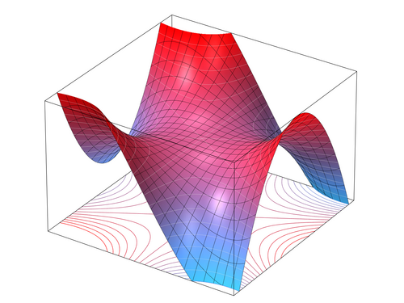

*Grafik suatu fungsi global pada ruang afin dua dimensi; Inductiveload, domain publik. Rincian sumber berada pada kredit media Unit 14.*

### Teorema: seksi global pada spektrum afin

Misalkan $K$ lapangan tertutup secara aljabar, $R$ aljabar-$K$ bertipe hingga yang tereduksi, dan $V=K\!-\!\operatorname{Spek}(R)$. Maka

$$\Gamma(V,\mathcal O)=R.$$

#### Bukti

Setiap $F\in R$ langsung memberikan fungsi aljabar pada seluruh $V$, jadi terdapat homomorfisme aljabar-$K$

$$R\longrightarrow\Gamma(V,\mathcal O).$$

Jika $F$ menginduksi fungsi nol di setiap titik, Teorema 11.1 dan sifat tereduksi memberikan $F=0$. Jadi pemetaan itu injektif.

Sekarang misalkan $f:V\to K$ suatu fungsi aljabar. Untuk setiap $P\in V$ terdapat $G_P,H_P\in R$ dengan $P\in D(H_P)$ dan

$$f=\frac{G_P}{H_P}\quad\text{pada }D(H_P).$$

Himpunan-himpunan $D(H_P)$ menutupi $V$. Menurut Korolari 11.12, unsur-unsur $H_P$ membangkitkan ideal satuan, sehingga berhingga banyak di antaranya sudah membangkitkan ideal satuan. Nyatakan unsur-unsur itu dengan

$$H_i=H_{P_i},\qquad i=1,\ldots,m.$$

Maka $D(H_i)$ menutupi seluruh $V$. Pada setiap irisan $D(H_iH_j)=D(H_i)\cap D(H_j)$ berlaku

$$f(Q)=\frac{G_i(Q)}{H_i(Q)}=\frac{G_j(Q)}{H_j(Q)}.$$

Menurut Lema 14.8 dan sifat tereduksi,

$$H_iH_jG_iH_j=H_iH_jG_jH_i$$

di $R$. Ganti $H_i$ dengan $H_i^2$ dan $G_i$ dengan $G_iH_i$. Penyajian $G_i/H_i$ tetap sama, sedangkan hubungan terakhir menyederhana menjadi

$$H_iG_j=H_jG_i.$$

Karena $H_i$ membangkitkan ideal satuan, terdapat $A_i\in R$ dengan

$$\sum_{i=1}^m A_iH_i=1.$$

Tetapkan

$$F=\sum_{i=1}^m A_iG_i.$$

Kita klaim bahwa $F$ menginduksi $f$ pada seluruh $V$. Ambil $Q\in V$; tanpa mengurangi keumuman, misalkan $Q\in D(H_1)$. Maka

$$\begin{aligned}
f(Q)
&=\frac{G_1(Q)}{H_1(Q)}\\
&=\frac{G_1(Q)}{H_1(Q)}
\left(\sum_{i=1}^m A_iH_i\right)(Q)\\
&=\sum_{i=1}^m A_i(Q)\frac{G_1(Q)H_i(Q)}{H_1(Q)}\\
&=\sum_{i=1}^m A_i(Q)G_i(Q)\\
&=F(Q).
\end{aligned}$$

Jadi homomorfisme di atas juga surjektif.

### Korolari: seksi pada himpunan terbuka utama

Misalkan $F\in R$ dalam situasi teorema sebelumnya. Maka

$$\Gamma(D(F),\mathcal O)=R_F.$$

#### Bukti

Pernyataan ini langsung mengikuti dari Lema 14.7 dan Teorema 14.9.

### Catatan: masalah Hilbert ke-14

Salah satu varian masalah Hilbert ke-14 menanyakan apakah gelanggang fungsi aljabar $\Gamma(U,\mathcal O)$ dibangkitkan secara hingga untuk setiap himpunan terbuka $U$. Jawabannya benar untuk himpunan terbuka berbentuk $U=D(f)$, juga ketika $R$ reguler atau faktorial, dan pada dimensi kecil. Namun, secara umum jawabannya tidak benar.

**Provenans edisi.** Terjemahan dan produksi pembaca: OpenAI Codex gpt-5.6-sol, Ultra. Sumber, pengarang, dan lisensi komponen dipertahankan seperti dinyatakan dalam metadata dan berkas hak edisi.

# Lembar Kerja 14

## Soal latihan

### Soal 14.1

Misalkan $K$ lapangan tertutup secara aljabar dan $R=K[X]$ gelanggang polinomial di atas $K$. Tunjukkan bahwa setiap fungsi aljabar $f$ pada suatu himpunan terbuka

$$U=D(F)\subseteq K\!-\!\operatorname{Spek}(R)=\mathbb A_K^1$$

mempunyai bentuk

$$f=\frac GH,$$

dengan $G,H\in R$ yang tidak dapat disederhanakan lagi dan $D(F)\subseteq D(H)$.

### Soal 14.2 ★

Misalkan $K$ lapangan tertutup secara aljabar dan $R$ aljabar-$K$ bertipe hingga yang merupakan daerah integral faktorial. Tunjukkan bahwa setiap fungsi aljabar $f$ pada suatu himpunan terbuka

$$U\subseteq K\!-\!\operatorname{Spek}(R)$$

mempunyai bentuk $f=G/H$, dengan $G,H\in R$ yang tidak dapat disederhanakan lagi dan $U\subseteq D(H)$.

### Soal 14.3

Lengkapi bukti Lema 14.4.

### Soal 14.4

Misalkan $U\subseteq K\!-\!\operatorname{Spek}(R)$ suatu subhimpunan terbuka dari spektrum-$K$ aljabar-$K$ $R$ di atas lapangan tertutup secara aljabar $K$, dan misalkan

$$f\in\Gamma(U,\mathcal O)$$

suatu fungsi aljabar. Tunjukkan bahwa $f$ mendefinisikan pemetaan kontinu ke $K$.

### Soal 14.5

Tunjukkan bahwa gelanggang $\Gamma(U,\mathcal O)$ tereduksi.

### Soal 14.6

Misalkan $K$ lapangan tertutup secara aljabar. Tinjau titik

$$P=(0,1)\in V(X^3-Y^3+1)=C\subseteq\mathbb A_K^2$$

dan tetapkan $U=C\setminus\{P\}$. Deskripsikan suatu fungsi aljabar pada $U$ yang tidak dapat diperluas menjadi fungsi aljabar pada seluruh $C$.

### Soal 14.7 ★

Tinjau parabola Neil

$$C=V(Y^2-X^3)\subseteq\mathbb A_K^2$$

dan titik $P=(1,1)\in C$. Temukan fungsi aljabar yang terdefinisi pada $C\setminus\{P\}$ tetapi tidak pada seluruh $C$.

**Petunjuk.** Temukan dua faktorisasi berbeda dari $X^3-X^2$.

### Soal 14.8

Misalkan $K$ lapangan tertutup secara aljabar, $R$ aljabar-$K$ bertipe hingga yang merupakan daerah integral, dan

$$U=D(\mathfrak a)\subseteq K\!-\!\operatorname{Spek}(R),
\qquad
\mathfrak a=(f_1,\ldots,f_n).$$

Tunjukkan bahwa

$$\Gamma(U,\mathcal O)=\bigcap_{i=1}^n R_{f_i},$$

dengan irisan diambil di dalam lapangan pecahan $Q(R)$.

### Soal 14.9

Misalkan $R$ aljabar-$K$ komutatif bertipe hingga di atas lapangan tertutup secara aljabar, $U\subseteq K\!-\!\operatorname{Spek}(R)$ terbuka, dan $f:U\to K$ suatu fungsi. Misalkan

$$U=\bigcup_{i\in I}U_i$$

suatu penutup terbuka dan setiap restriksi $f_i=f|_{U_i}$ merupakan fungsi aljabar. Tunjukkan bahwa $f$ sendiri aljabar.

### Soal 14.10

Misalkan $K$ lapangan tertutup secara aljabar dan $R$ aljabar-$K$ bertipe hingga yang merupakan daerah integral. Tunjukkan bahwa untuk himpunan terbuka $U\subseteq V$, pemetaan restriksi

$$\Gamma(V,\mathcal O)\longrightarrow\Gamma(U,\mathcal O)$$

bersifat injektif.

### Soal 14.11

Tinjau

$$V=V(XW-YZ)\subseteq\mathbb A_K^4.$$

Deskripsikan suatu himpunan terbuka $U\subseteq\mathbb A_K^4$ sedemikian sehingga homomorfisme gelanggang yang bersesuaian

$$\Gamma(U,\mathcal O)\longrightarrow\Gamma(U\cap V,\mathcal O)$$

tidak surjektif.

Soal berikut menggunakan konsep limit suatu pemetaan. Soal 1.9 dapat membantu.

### Soal 14.12

Tinjau kurva

$$C=V(Y^2-X^2-X^3)\subseteq\mathbb A_{\mathbb C}^2,$$

titik $P=(0,0)\in C$, dan komplemen terbuka $U=C\setminus\{P\}$.

1. Tunjukkan bahwa $Y/X$ merupakan fungsi aljabar pada $U$ yang tidak dapat diperluas secara aljabar ke seluruh $C$.
2. Tunjukkan bahwa limit pemetaan di $P$ untuk fungsi $\varphi=Y/X:U\to\mathbb C$ tidak ada.
3. Tunjukkan bahwa terdapat barisan $(w_n)_{n\in\mathbb N}$ dan $(z_n)_{n\in\mathbb N}$ di $U$ yang keduanya konvergen ke $P$, sedangkan barisan citra masing-masing di bawah $\varphi$ konvergen ke nilai yang berbeda.

Konsep-konsep berikut penting di banyak bidang matematika dan merangkum sifat-sifat utama berkas struktur pada spektrum-$K$.

### Definisi pendukung: praberkas

Misalkan $X$ suatu ruang topologis. Suatu *praberkas* $\mathcal F$ pada $X$ adalah aturan yang mengaitkan:

- kepada setiap himpunan terbuka $U\subseteq X$, suatu himpunan $\mathcal F(U)$;
- kepada setiap inklusi himpunan terbuka $U\subseteq V$, suatu pemetaan

  $$\rho_{V,U}:\mathcal F(V)\longrightarrow\mathcal F(U),$$

sedemikian sehingga

$$\rho_{U,U}=\operatorname{Id}_{\mathcal F(U)}$$

dan, untuk $U\subseteq V\subseteq W$,

$$\rho_{W,U}=\rho_{V,U}\circ\rho_{W,V}.$$

Pemetaan $\rho_{V,U}$ disebut *pemetaan restriksi*. Praberkas ini disebut *praberkas grup* apabila setiap $\mathcal F(U)$ adalah grup dan setiap pemetaan restriksi adalah homomorfisme grup. Ia disebut *praberkas gelanggang komutatif* apabila setiap $\mathcal F(U)$ adalah gelanggang komutatif dan setiap pemetaan restriksi adalah homomorfisme gelanggang.

### Soal 14.13

Tunjukkan bahwa aturan yang mengaitkan kepada setiap himpunan terbuka

$$U\subseteq K\!-\!\operatorname{Spek}(R)$$

gelanggang fungsi aljabar $\Gamma(U,\mathcal O)$, dan kepada setiap inklusi $U_1\subseteq U_2$ pemetaan restriksi

$$\Gamma(U_2,\mathcal O)\longrightarrow\Gamma(U_1,\mathcal O),$$

merupakan praberkas aljabar-$K$.

### Definisi pendukung: berkas

Suatu *berkas* $\mathcal F$ pada ruang topologis $X$ adalah praberkas yang memenuhi dua sifat berikut.

1. **Ketunggalan lokal.** Untuk setiap penutup terbuka $U=\bigcup_{i\in I}U_i$ dan $s,t\in\mathcal F(U)$, jika

   $$\rho_{U,U_i}(s)=\rho_{U,U_i}(t)
   \qquad\text{untuk semua }i\in I,$$

   maka $s=t$.
2. **Perekatan.** Untuk setiap penutup terbuka $U=\bigcup_{i\in I}U_i$ dan seksi-seksi $s_i\in\mathcal F(U_i)$ yang kompatibel pada setiap irisan, yakni

   $$\rho_{U_i,U_i\cap U_j}(s_i)
   =\rho_{U_j,U_i\cap U_j}(s_j)
   \qquad(i,j\in I),$$

   terdapat $s\in\mathcal F(U)$ dengan $s_i=\rho_{U,U_i}(s)$ untuk semua $i\in I$.

### Soal 14.14

Misalkan $X,Y$ ruang topologis. Untuk setiap himpunan terbuka $U\subseteq X$, tetapkan

$$\mathcal C(U)=C^0(U,Y)
=\{\varphi:U\to Y\mid\varphi\text{ kontinu}\}.$$

Tunjukkan bahwa aturan ini merupakan berkas pada $X$.

### Soal 14.15

Misalkan $X$ suatu ruang topologis. Untuk setiap himpunan terbuka $U\subseteq X$, tetapkan

$$\mathcal C(U)=C^0(U,\mathbb R)
=\{\varphi:U\to\mathbb R\mid\varphi\text{ kontinu}\}.$$

Tunjukkan bahwa aturan ini merupakan berkas aljabar-$\mathbb R$ komutatif pada $X$.

### Soal 14.16

Misalkan $M$ suatu manifold terdiferensialkan. Untuk setiap himpunan terbuka $U\subseteq M$, tinjau himpunan $C^1(U,\mathbb R)$ semua fungsi terdiferensialkan pada $U$. Misalkan

$$M=\bigcup_{i\in I}U_i$$

suatu penutup terbuka.

1. Tunjukkan bahwa jika $V\subseteq U$ terbuka dan $f\in C^1(U,\mathbb R)$, maka $f|_V\in C^1(V,\mathbb R)$.
2. Misalkan $f\in C^1(M,\mathbb R)$. Tunjukkan bahwa $f=0$ jika dan hanya jika $f|_{U_i}=0$ untuk setiap $i$.
3. Misalkan diberikan fungsi-fungsi $f_i\in C^1(U_i,\mathbb R)$ yang memenuhi syarat kompatibilitas

   $$f_i|_{U_i\cap U_j}=f_j|_{U_i\cap U_j}$$

   untuk semua $i,j$. Tunjukkan bahwa terdapat $f\in C^1(M,\mathbb R)$ dengan $f|_{U_i}=f_i$ untuk semua $i$.

### Soal 14.17

Tunjukkan bahwa aturan yang mengaitkan kepada setiap himpunan terbuka $U\subseteq K\!-\!\operatorname{Spek}(R)$ gelanggang fungsi aljabar $\Gamma(U,\mathcal O)$, dan kepada setiap inklusi $U_1\subseteq U_2$ pemetaan restriksi

$$\Gamma(U_2,\mathcal O)\longrightarrow\Gamma(U_1,\mathcal O),$$

merupakan berkas aljabar-$K$.

Soal-soal berikut membahas ultrafilter dan ideal prima minimal. Kita catat definisinya.

Suatu ideal prima $\mathfrak p$ di dalam gelanggang komutatif disebut *ideal prima minimal* jika tidak terdapat ideal prima $\mathfrak q$ dengan $\mathfrak q\subsetneq\mathfrak p$.

Misalkan $R$ suatu gelanggang komutatif. Suatu sistem multiplikatif $F\subseteq R$ disebut *ultrafilter* jika $0\notin F$ dan $F$ maksimal di antara sistem multiplikatif yang tidak memuat $0$.

### Soal 14.18

Misalkan $R$ gelanggang komutatif dan $F\subseteq R$ sistem multiplikatif dengan $0\notin F$. Tunjukkan bahwa $F$ merupakan ultrafilter jika dan hanya jika, untuk setiap $g\in R$ dengan $g\notin F$, terdapat $f\in F$ dan $n\in\mathbb N$ sehingga

$$fg^n=0.$$

### Soal 14.19

Misalkan $R$ gelanggang komutatif dan $F\subseteq R$ suatu ultrafilter. Tunjukkan bahwa komplemen $R\setminus F$ merupakan ideal prima minimal di $R$.

### Soal 14.20

Misalkan $R$ gelanggang komutatif dan $S$ sistem multiplikatif dengan $0\notin S$. Tunjukkan bahwa $S$ termuat di dalam suatu ultrafilter.

**Petunjuk.** Gunakan lema Zorn.

### Soal 14.21

Misalkan $R$ gelanggang komutatif yang tereduksi. Tunjukkan bahwa setiap pembagi nol termuat di dalam suatu ideal prima minimal.

### Soal 14.22

Misalkan $K$ lapangan tertutup secara aljabar dan $\mathfrak a\subseteq K[X_1,\ldots,X_n]$ suatu ideal radikal. Tetapkan

$$R=K[X_1,\ldots,X_n]/\mathfrak a,
\qquad
V=V(\mathfrak a).$$

Tunjukkan bahwa komponen-komponen tak tereduksi dari $V$ bersesuaian dengan ideal-ideal prima minimal dari gelanggang koordinat $R$.

### Soal 14.23

Misalkan $K$ lapangan tertutup secara aljabar dan $R$ aljabar-$K$ komutatif bertipe hingga. Tunjukkan bahwa ideal-ideal prima minimal dari $R$ bersesuaian dengan komponen-komponen tak tereduksi dari $K\!-\!\operatorname{Spek}(R)$.

## Soal untuk dikumpulkan

### Soal 14.24 (3 poin)

Misalkan $K$ lapangan tertutup secara aljabar, $P\in\mathbb A_K^2$, dan

$$U=\mathbb A_K^2\setminus\{P\}.$$

Tunjukkan bahwa

$$\Gamma(U,\mathcal O)=K[X,Y].$$

Dengan kata lain, setiap fungsi aljabar yang terdefinisi di luar satu titik bidang afin dapat diperluas ke titik tersebut.

### Soal 14.25 (5 poin: 1+2+2)

Tinjau parabola Neil

$$C=V(X^2-Y^3)\subseteq\mathbb A_{\mathbb C}^2.$$

1. Tunjukkan bahwa pada $C$ berlaku $D(X)=D(Y)$.
2. Tunjukkan bahwa pada $U=D(Y)\subseteq C$, pecahan $X/Y$ mendefinisikan fungsi aljabar yang tidak dapat diperluas secara aljabar ke seluruh $C$.
3. Tunjukkan bahwa fungsi kontinu $X/Y:D(Y)\to\mathbb C$ mempunyai perluasan kontinu ke seluruh $C$.

### Soal 14.26 (4 poin)

Misalkan $R$ suatu aljabar-$K$ integral bertipe hingga di atas lapangan tertutup secara aljabar $K$, dan misalkan

$$q\in Q=Q(R)$$

suatu unsur lapangan pecahan $R$. Tunjukkan bahwa

$$\mathfrak a
=\left\{f\in R\mathrel{\Big|}
\text{terdapat }n\in\mathbb N\text{ dengan }f^nq\in R\right\}$$

merupakan ideal di $R$. Tunjukkan pula bahwa

$$D(\mathfrak a)\subseteq K\!-\!\operatorname{Spek}(R)$$

merupakan domain definisi maksimal fungsi aljabar $q$.

### Soal 14.27 (4 poin)

Misalkan $R$ gelanggang komutatif dan $f_1,\ldots,f_n\in R$ membangkitkan ideal satuan. Andaikan setiap pelokalan $R_{f_i}$, $i=1,\ldots,n$, merupakan gelanggang Noether. Tunjukkan bahwa $R$ juga Noether.

# Solusi Publik Lembar Kerja 14

Pada batas revisi yang dibekukan, sumber hanya menyediakan solusi publik untuk Soal 14.2 dan 14.7. Tidak ada solusi tambahan yang dibuat untuk edisi ini.

## Solusi Soal 14.2

Misalkan

$$U=\bigcup_{i\in I}D(H_i)$$

dengan $I$ berhingga, dan pada setiap $D(H_i)$ fungsi $f$ mempunyai penyajian

$$f=\frac{F_i}{H_i},$$

yakni

$$f(Q)=\frac{F_i(Q)}{H_i(Q)}
\qquad\text{untuk setiap }Q\in D(H_i).$$

Pada irisan $D(H_i)\cap D(H_j)$ berlaku

$$\frac{F_i(Q)}{H_i(Q)}
=f(Q)
=\frac{F_j(Q)}{H_j(Q)}.$$

Jadi

$$H_j(Q)F_i(Q)-H_i(Q)F_j(Q)=0$$

untuk setiap $Q\in D(H_i)\cap D(H_j)$. Oleh karena itu unsur

$$H_iH_j(H_jF_i-H_iF_j)$$

menginduksi fungsi nol pada seluruh $K\!-\!\operatorname{Spek}(R)$. Karena $R$ integral dan $K$ tertutup secara aljabar, teorema identitas memberikan

$$H_iH_j(H_jF_i-H_iF_j)=0$$

di $R$. Setelah mengabaikan anggota penutup yang kosong, $H_i$ dan $H_j$ tidak nol; karena $R$ suatu daerah integral, diperoleh

$$H_jF_i=H_iF_j.$$

Berdasarkan ketunggalan faktorisasi prima, terdapat unsur $A,B,C,D$ dan suatu satuan $u$ dengan

$$H_jF_i=(AB)(CD)=(u^{-1}AD)(uBC)=H_iF_j.$$

Akibatnya

$$\frac{F_i}{H_i}
=\frac{uCD}{AD}
=\frac{uC}{A}
=\frac{uBC}{AB}
=\frac{F_j}{H_j}.$$

Penyajian pecahan $uC/A$ berlaku pada $D(H_i)\cup D(H_j)$. Dengan cara ini, kita dapat menggabungkan dua anggota penutup dan memperkecil himpunan indeks $I$. Karena $I$ berhingga, pengulangan proses tersebut akhirnya menghasilkan satu pecahan $G/H$ yang berlaku pada seluruh $U$. Dengan membatalkan faktor persekutuan, $G$ dan $H$ dapat dipilih tidak dapat disederhanakan, dan tentu $U\subseteq D(H)$.

Kembali ke Soal 14.2.

## Solusi Soal 14.7

Ideal maksimal yang bersesuaian dengan titik $P$ diberikan oleh $(X-1,Y-1)$. Di dalam gelanggang koordinat

$$R=K[X,Y]/(Y^2-X^3)$$

berlaku

$$X^2(X-1)=X^3-X^2=Y^2-X^2=(Y-X)(Y+X).$$

Karena itu, di dalam lapangan pecahan kita dapat menetapkan

$$f:=\frac{X^2}{Y-X}=\frac{X+Y}{X-1}.$$

Penyajian-penyajian ini mendefinisikan fungsi aljabar pada

$$D(Y-X,X-1)=D(Y-1,X-1)=C\setminus\{P\}.$$

Untuk menunjukkan bahwa fungsi tersebut tidak terdefinisi pada seluruh $C$, tinjau pemetaan

$$\begin{aligned}
\varphi:\mathbb A_K^1&\longrightarrow C,\\
t&\longmapsto(t^2,t^3).
\end{aligned}$$

Kita mempunyai

$$\varphi^{-1}(C\setminus\{P\})=\mathbb A_K^1\setminus\{1\}.$$

Praimaj fungsi $f$ melalui pemetaan ini adalah

$$\frac{t^2+t^3}{t^2-1}
=\frac{t^2(1+t)}{(t+1)(t-1)}
=\frac{t^2}{t-1}.$$

Fungsi ini mempunyai kutub di $t=1$ dan tidak dapat diperluas menjadi fungsi aljabar pada seluruh garis afin. Maka $f$ juga tidak dapat diperluas secara aljabar ke seluruh $C$.

**Catatan edisi:** pada langkah pembatalan terakhir, sumber menampilkan $-t^2/(t-1)$. Faktorisasi yang ditampilkan pada baris sebelumnya memberikan $t^2/(t-1)$ tanpa tanda minus. Kutub di $t=1$ dan kesimpulan pembuktian tidak berubah.

Kembali ke Soal 14.7.

# Kuliah 15: Varietas Afin dan Kuasiafin, Gelanggang Lokal, dan Tangkai

## Varietas afin dan kuasiafin

### Definisi: varietas afin

Misalkan $K$ lapangan tertutup secara aljabar dan $R$ aljabar-$K$ bertipe hingga. Spektrum-$K$

$$V=K\!-\!\operatorname{Spek}(R),$$

dengan setiap himpunan terbuka Zariski $U\subseteq V$ dilengkapi gelanggang fungsi aljabar $\Gamma(U,\mathcal O)$, disebut *varietas afin*.

Suatu subhimpunan terbuka dari varietas afin, dengan setiap himpunan terbukanya juga dilengkapi gelanggang struktur, disebut *varietas kuasiafin*. Varietas kuasiafin dapat ditutupi oleh berhingga banyak himpunan terbuka berbentuk $D(f)$, yang masing-masing merupakan varietas afin. Sebagian pengarang hanya menyebut spektrum-$K$ yang tak tereduksi sebagai varietas.

Teorema 14.9 menjamin bahwa tidak ada informasi yang hilang ketika kita beralih dari $R$ ke

$$V=K\!-\!\operatorname{Spek}(R),$$

karena gelanggang $R$ dapat diperoleh kembali sebagai $\Gamma(V,\mathcal O)$. Hal ini tidak dapat dilakukan hanya dari ruang topologisnya.

## Gelanggang lokal

Untuk suatu titik $P$ dalam spektrum-$K$, kita tertarik pada semua fungsi aljabar yang terdefinisi di $P$ dan mempunyai penyajian rasional pada suatu lingkungan $P$. Fungsi-fungsi tersebut terdefinisi pada lingkungan yang berbeda, dan tidak ada lingkungan terkecil tempat semua fungsi aljabar yang terdefinisi di $P$ sekaligus terdefinisi. Kita mempunyai sistem gelanggang

$$\bigl(\Gamma(U,\mathcal O)\bigr)_{P\in U}$$

yang hendak dipahami secara geometris dan aljabar. Sistem ini ternyata mempunyai limit yang bermakna - disebut *limit langsung* atau *kolimit* - dan limit tersebut sama dengan pelokalan $R_{\mathfrak m}$ pada ideal maksimal $\mathfrak m$ yang bersesuaian dengan $P$. Kita mulai dengan istilah aljabarnya.

### Definisi: gelanggang lokal

Suatu gelanggang komutatif $R$ disebut *lokal* jika $R$ mempunyai tepat satu ideal maksimal.

Syarat ini ekuivalen dengan tertutupnya komplemen grup satuan $R$ terhadap penjumlahan. Gelanggang lokal yang paling sederhana adalah lapangan. Kepada setiap gelanggang lokal $R$ dengan ideal maksimal $\mathfrak m$ dikaitkan lapangan faktor $R/\mathfrak m$, yang disebut *lapangan residu* $R$. Kita akan segera melihat bahwa setiap titik spektrum-$K$ mempunyai gelanggang lokal yang secara aljabar menggambarkan “rupa lokal” varietas di titik itu.

### Definisi: pelokalan pada ideal prima

Misalkan $R$ gelanggang komutatif dan $\mathfrak p$ ideal prima. Pelokalan terhadap sistem multiplikatif

$$S=R\setminus\mathfrak p$$

disebut *pelokalan* $R$ pada $\mathfrak p$ dan ditulis $R_{\mathfrak p}$. Dengan demikian,

$$R_{\mathfrak p}
=\left\{\frac fg\mathrel{\Big|}f\in R,\ g\notin\mathfrak p\right\}.$$

Teorema berikut menjelaskan alasan penamaan itu.

### Teorema: pelokalan pada ideal prima bersifat lokal

Misalkan $R$ gelanggang komutatif dan $\mathfrak p$ ideal prima di $R$. Maka $R_{\mathfrak p}$ merupakan gelanggang lokal dengan ideal maksimal

$$\mathfrak pR_{\mathfrak p}
=\left\{\frac fg\mathrel{\Big|}f\in\mathfrak p,\ g\notin\mathfrak p\right\}.$$

#### Bukti

Himpunan yang ditampilkan memang suatu ideal di dalam

$$R_{\mathfrak p}
=\left\{\frac fg\mathrel{\Big|}f\in R,\ g\notin\mathfrak p\right\}.$$

Kita tunjukkan bahwa komplemen $\mathfrak pR_{\mathfrak p}$ hanya terdiri atas satuan, sehingga ideal itu harus maksimal. Misalkan

$$q=\frac fg\in R_{\mathfrak p}$$

tetapi $q\notin\mathfrak pR_{\mathfrak p}$. Maka $f,g\notin\mathfrak p$, sehingga pecahan kebalikannya $g/f$ juga terletak di dalam pelokalan.

## Lapangan pecahan dan lapangan fungsi

Jika $R$ suatu daerah integral, lapangan pecahannya merupakan pelokalan pada ideal prima nol. Sekarang kita tunjukkan bahwa untuk varietas afin tak tereduksi $K\!-\!\operatorname{Spek}(R)$, setiap fungsi aljabar secara alami terletak di dalam lapangan pecahan.

### Lema: fungsi aljabar sebagai unsur lapangan pecahan

Misalkan $K$ lapangan tertutup secara aljabar, $R$ aljabar-$K$ integral bertipe hingga, dan

$$\varnothing\ne U\subseteq K\!-\!\operatorname{Spek}(R)$$

suatu subhimpunan terbuka. Terdapat homomorfisme aljabar-$R$ injektif yang ditentukan secara tunggal

$$\Gamma(U,\mathcal O)\longrightarrow Q(R).$$

Khususnya, setiap fungsi aljabar yang terdefinisi pada himpunan terbuka tak kosong $U$ merupakan suatu unsur lapangan pecahan $Q(R)$.

#### Bukti

Ambil $P\in U$ dan misalkan pada suatu lingkungan $P$ fungsi aljabar $f$ diberikan oleh

$$f=G/H,
\qquad G,H\in R,
\qquad H\ne0.$$

Pecahan $G/H$ langsung dapat dipandang sebagai unsur lapangan pecahan. Misalkan $Q\in U$ titik lain dengan penyajian

$$f=G'/H'.$$

Menurut Lema 14.8 dan karena $R$ merupakan daerah integral,

$$GH'=G'H$$

di $R$. Jadi unsur lapangan pecahan tersebut terdefinisi dengan baik. Pemetaan yang diperoleh jelas suatu homomorfisme gelanggang dan membuat diagram

$$\begin{matrix}
R &&\\
\downarrow & \searrow &\\
\Gamma(U,\mathcal O)&\longrightarrow&Q(R)
\end{matrix}$$

komutatif. Sifat-sifat ini juga menentukan pemetaan tersebut secara tunggal: fungsi aljabar yang berasal dari unsur $R$ harus dipetakan ke unsur yang sama di lapangan pecahan, sehingga citra setiap pecahan sudah ditentukan.

Untuk injektivitas, jika $G/H=0$ di lapangan pecahan, maka $G=0$ dan fungsi yang bersesuaian adalah fungsi nol pada $D(H)$. Untuk penyajian lain $G'/H'$ bagi fungsi yang sama, hubungan di atas kembali memberikan $G'=0$; jadi fungsi itu nol pada seluruh $U$.

Ketunggalan juga langsung menunjukkan bahwa untuk dua himpunan terbuka $U\subseteq U'$, diagram

$$\begin{matrix}
\Gamma(U',\mathcal O)&&\\
\downarrow&\searrow&\\
\Gamma(U,\mathcal O)&\longrightarrow&Q(R)
\end{matrix}$$

komutatif, dengan homomorfisme restriksi di sebelah kiri. Mulai sekarang, dalam kasus integral kita mengidentifikasi fungsi aljabar dengan unsur lapangan pecahan yang bersesuaian.

## Filter topologis dan tangkainya

Hasil bagian sebelumnya mengatakan bahwa lapangan pecahan dapat diperoleh sebagai gabungan terurut dari semua gelanggang seksi $\Gamma(U,\mathcal O)$ ketika $U$ menjelajahi semua himpunan terbuka tak kosong. Konstruksi serupa dapat dilakukan untuk sistem himpunan terbuka yang terstruktur dengan sesuai. Untuk itu kita memerlukan konsep filter.

### Definisi: filter topologis

Misalkan $X$ ruang topologis. Suatu sistem $F$ yang terdiri atas subhimpunan-subhimpunan terbuka $X$ disebut *filter topologis* jika, untuk himpunan terbuka $U,V$, berlaku:

1. $X\in F$;
2. jika $U\in F$ dan $U\subseteq V$, maka $V\in F$;
3. jika $U,V\in F$, maka $U\cap V\in F$.

[figure not shown]

Empat lingkaran abu-abu konsentris pada latar transparan

*Representasi skematis suatu filter lingkungan; Andreas Pietzowski, [CC BY-SA 4.0](https://creativecommons.org/licenses/by-sa/4.0). Rincian sumber berada pada kredit media Unit 15.*

### Definisi: filter lingkungan

Misalkan $X$ ruang topologis dan $M\subseteq X$. Sistem

$$\mathcal U(M)
=\{U\subseteq X\mid U\text{ terbuka dan }M\subseteq U\}$$

disebut *filter lingkungan* $M$.

Sistem ini jelas suatu filter topologis. Khususnya, untuk satu titik $P\in X$ terdapat filter lingkungan $\mathcal U(P)$ yang menghimpun semua lingkungan terbuka titik itu.

Misalkan diberikan dua lingkungan terbuka $U_1,U_2$ dari $P$ dan dua fungsi aljabar

$$f_1\in\Gamma(U_1,\mathcal O),
\qquad
f_2\in\Gamma(U_2,\mathcal O).$$

Pada mulanya jumlah $f_1+f_2$ - demikian pula hasil kalinya - belum bermakna karena domain definisinya berbeda. Dalam kasus integral, keduanya dapat dipandang sebagai unsur lapangan pecahan dan dijumlahkan di sana. Sebagai alternatif, kita dapat beralih ke irisan $U_1\cap U_2$, yang juga merupakan lingkungan terbuka $P$, lalu menjumlahkan restriksi kedua fungsi di sana. Sifat penting filter adalah bahwa bersama setiap dua himpunan terbukanya, filter juga memuat irisannya, dengan inklusi

$$U_1\cap U_2\subseteq U_1,U_2$$

dan pemetaan restriksi yang bersesuaian

$$\Gamma(U_1,\mathcal O),\Gamma(U_2,\mathcal O)
\longrightarrow\Gamma(U_1\cap U_2,\mathcal O).$$

Pengamatan ini dirumuskan secara tepat melalui himpunan terarah dan sistem terarah.

### Definisi: himpunan terarah

Suatu himpunan terurut $(I,\preccurlyeq)$ disebut *terurut secara terarah* atau singkatnya *terarah* jika untuk setiap $i,j\in I$ terdapat $k\in I$ dengan

$$i,j\preccurlyeq k.$$

Kita memandang filter topologis sebagai himpunan yang diurutkan oleh inklusi. Sifat irisan filter membuatnya terarah; arah urutannya adalah

$$\preccurlyeq\;=\;\supseteq.$$

### Definisi: sistem terurut dan sistem terarah

Misalkan $(I,\preccurlyeq)$ suatu himpunan indeks terurut. Keluarga himpunan

$$M_i,\qquad i\in I,$$

disebut *sistem terurut himpunan* jika:

1. untuk $i\preccurlyeq j$ terdapat pemetaan $\varphi_{ij}:M_i\to M_j$;
2. untuk $i\preccurlyeq j\preccurlyeq k$ berlaku

   $$\varphi_{ik}=\varphi_{jk}\circ\varphi_{ij}.$$

Jika himpunan indeksnya juga terarah, keluarga tersebut disebut *sistem terarah himpunan*.

Jika semua $M_i$ merupakan grup (atau gelanggang) dan semua pemetaan di antaranya homomorfisme grup (atau homomorfisme gelanggang), kita berbicara tentang sistem terurut atau terarah grup (atau gelanggang).

### Definisi: kolimit

Misalkan $(M_i)_{i\in I}$ suatu sistem terarah himpunan. Himpunan

$$\operatorname{colim}_{i\in I}M_i
=\left(\biguplus_{i\in I}M_i\right)\!\big/\!\sim$$

disebut *kolimit* (juga *limit langsung* atau *limit induktif*) sistem tersebut. Di sini $\sim$ adalah relasi ekuivalensi yang menyatakan dua unsur $m\in M_i$ dan $n\in M_j$ ekuivalen jika terdapat $k\in I$ dengan $i,j\preccurlyeq k$ dan

$$\varphi_{ik}(m)=\varphi_{jk}(n).$$

Secara khusus, $s_i\in M_i$ ekuivalen dengan citranya $\varphi_{ik}(s_i)\in M_k$ untuk setiap $i\preccurlyeq k$.

**Catatan edisi:** pada kalimat terakhir, sumber menulis $s_i\in M$, padahal sistem hanya mendefinisikan himpunan-himpunan $M_i$. Edisi ini menampilkan indeks yang diperlukan, $s_i\in M_i$.

Jika kita mempunyai sistem terarah grup (atau gelanggang), kolimit himpunan di atas juga dapat diberi struktur grup (atau gelanggang). Dua unsur kolimit yang diwakili oleh $s_i\in M_i$ dan $s_j\in M_j$ dapat diganti dengan citranya di suatu $M_k$ dengan $i,j\preccurlyeq k$, lalu operasinya didefinisikan di $M_k$; lihat Soal 15.23.

Contoh utama kita adalah sistem terarah gelanggang

$$\Gamma(U,\mathcal O),\qquad U\in F,$$

yang diarahkan oleh suatu filter topologis. Kolimit sistem ini mendapat nama tersendiri.

### Definisi: tangkai pada filter

Misalkan $(V,\mathcal O)$ varietas kuasiafin dan $F$ filter topologis di $V$. Kolimit

$$\mathcal O_F
=\operatorname{colim}_{U\in F}\Gamma(U,\mathcal O)$$

disebut *tangkai* $\mathcal O$ pada $F$.

Tangkai pada filter lingkungan suatu titik $P$ juga disebut tangkai di $P$ dan ditulis $\mathcal O_P$.

### Teorema: tangkai di suatu titik adalah pelokalan

Misalkan $R$ aljabar komutatif tereduksi bertipe hingga di atas lapangan tertutup secara aljabar $K$. Misalkan

$$P\in K\!-\!\operatorname{Spek}(R)$$

suatu titik dengan ideal maksimal $\mathfrak m\subseteq R$ yang bersesuaian. Terdapat isomorfisme alami aljabar-$R$

$$R_{\mathfrak m}\longrightarrow\mathcal O_P.$$

#### Bukti

Tangkai $\mathcal O_P$ mempunyai struktur aljabar-$R$ yang tunggal karena seluruh ruang termasuk dalam filter. Jika $F\in R$ dan $F\notin\mathfrak m$, fungsi $1/F$ terdefinisi pada lingkungan terbuka $D(F)$ dari $P$. Di sana berlaku $F\cdot(1/F)=1$, sehingga $F$ menjadi satuan di dalam kolimit. Berdasarkan sifat universal pelokalan, terdapat homomorfisme aljabar-$R$

$$R_{\mathfrak m}\longrightarrow\mathcal O_P.$$

Kita buktikan bahwa pemetaan ini bijektif. Mula-mula ambil $f\in\mathcal O_P$. Unsur ini diwakili oleh suatu fungsi aljabar

$$f\in\Gamma(U,\mathcal O),
\qquad P\in U.$$

Khususnya, $f$ mempunyai penyajian rasional di $P$: pada $D(H)$ berlaku

$$f=G/H,
\qquad P\in D(H).$$

Syarat terakhir berarti $H(P)\ne0$, atau ekuivalen $H\notin\mathfrak m$. Jadi $G/H\in R_{\mathfrak m}$ dan dipetakan ke $f$. Ini membuktikan surjektivitas.

Untuk injektivitas, ambil $G/H$ dengan $H\notin\mathfrak m$ dan andaikan citranya di dalam tangkai adalah nol. Artinya terdapat lingkungan terbuka $U$ dari $P$ tempat $G/H$ merupakan fungsi nol. Kita boleh memilih

$$P\in D(H')\subseteq D(H)$$

dan, berdasarkan Korolari 14.10, menuliskan pada himpunan itu

$$G/H=G'/H'=0.$$

Menurut Lema 14.8,

$$H(H')^2G=0$$

di $R$. Karena $H$ dan $H'$ menjadi satuan di $R_{\mathfrak m}$, diperoleh $G/H=0$ di dalam pelokalan.

### Lema: seksi sebagai irisan gelanggang lokal

Misalkan $K$ lapangan tertutup secara aljabar, $R$ aljabar-$K$ integral bertipe hingga, dan

$$U\subseteq K\!-\!\operatorname{Spek}(R)$$

suatu himpunan terbuka. Maka

$$\Gamma(U,\mathcal O)=\bigcap_{P\in U}\mathcal O_P,$$

dengan irisan diambil di dalam lapangan pecahan $Q(R)$.

#### Bukti

Untuk setiap $P\in U$ terdapat homomorfisme gelanggang injektif

$$\Gamma(U,\mathcal O)\longrightarrow\mathcal O_P
\longrightarrow Q(R).$$

Karena itu terdapat homomorfisme gelanggang injektif

$$\Gamma(U,\mathcal O)
\longrightarrow\bigcap_{P\in U}\mathcal O_P.$$

Sebaliknya, misalkan $f\in Q(R)$ berada di dalam irisan di sebelah kanan. Untuk setiap $P\in U$, terdapat penyajian $f=G/H$ dengan

$$P\in D(H)\subseteq U.$$

Ini langsung berarti bahwa $f$ merupakan fungsi aljabar pada $U$.

### Definisi: lapangan fungsi

Misalkan $V$ varietas kuasiafin tak tereduksi. Tangkai $\mathcal O_V$ pada filter semua himpunan terbuka tak kosong di $V$ merupakan suatu lapangan, yang disebut *lapangan fungsi* $V$.

**Provenans edisi.** Terjemahan dan produksi pembaca: OpenAI Codex gpt-5.6-sol, Ultra. Sumber, pengarang, dan lisensi komponen dipertahankan seperti dinyatakan dalam metadata dan berkas hak edisi.

# Lembar Kerja 15

## Soal latihan

### Soal 15.1

Misalkan $R$ gelanggang komutatif. Tunjukkan bahwa pernyataan-pernyataan berikut ekuivalen.

1. $R$ mempunyai tepat satu ideal maksimal.
2. Himpunan unsur bukan satuan $R\setminus R^\times$ merupakan ideal di $R$.

### Soal 15.2

Misalkan $R$ gelanggang komutatif. Tunjukkan bahwa $R$ merupakan gelanggang lokal jika dan hanya jika, setiap kali $a+b$ merupakan satuan, setidaknya salah satu dari $a$ atau $b$ merupakan satuan.

### Soal 15.3

Tentukan semua subgelanggang bilangan rasional $\mathbb Q$ yang merupakan gelanggang lokal.

### Soal 15.4

Misalkan $R$ gelanggang komutatif lokal. Tunjukkan bahwa $R$ terhubung.

### Soal 15.5

Misalkan $\mathfrak n$ ideal maksimal di dalam gelanggang komutatif $R$. Misalkan $R_{\mathfrak n}$ pelokalan $R$ pada $\mathfrak n$, dan

$$\mathfrak m=\mathfrak nR_{\mathfrak n}$$

ideal maksimal $R_{\mathfrak n}$. Tunjukkan bahwa

$$R/\mathfrak n=R_{\mathfrak n}/\mathfrak m.$$

### Soal 15.6 ★

Misalkan $R$ gelanggang komutatif dan $\mathfrak p$ ideal prima. Gelanggang faktor

$$S=R/\mathfrak p$$

merupakan daerah integral dengan lapangan pecahan $Q=Q(S)$, sedangkan $R_{\mathfrak p}$ merupakan gelanggang lokal dengan ideal maksimal $\mathfrak pR_{\mathfrak p}$. Tunjukkan bahwa terdapat isomorfisme alami

$$Q(S)\cong R_{\mathfrak p}/\mathfrak pR_{\mathfrak p}.$$

Lapangan ini juga disebut lapangan residu pada $\mathfrak p$.

### Soal 15.7

Untuk $a\in\mathbb C$, tunjukkan bahwa homomorfisme substitusi

$$\begin{aligned}
\mathbb C[X]&\longrightarrow\mathbb C,\\
X&\longmapsto a,
\end{aligned}$$

sama dengan pemetaan evaluasi ke lapangan residu pada ideal prima $(X-a)$, yaitu

$$\mathbb C[X]_{(X-a)}/(X-a)\mathbb C[X]_{(X-a)}.$$

### Soal 15.8

Misalkan $R$ gelanggang lokal dengan lapangan residu $K$. Tunjukkan bahwa $R$ dan $K$ mempunyai karakteristik yang sama jika dan hanya jika $R$ memuat suatu lapangan.

### Soal 15.9 ★

Misalkan $R$ gelanggang lokal dan $\mathfrak a$ ideal di $R$. Tunjukkan bahwa pemetaan

$$R^\times\longrightarrow(R/\mathfrak a)^\times$$

bersifat surjektif.

### Soal 15.10

Misalkan $K$ lapangan tertutup secara aljabar dan

$$R=K[X_1,\ldots,X_n].$$

Tunjukkan bahwa semua pelokalan $R$ pada ideal maksimal saling isomorfik.

### Soal 15.11

Misalkan $K$ lapangan dan tinjau silang sumbu

$$V=K\!-\!\operatorname{Spek}\bigl(K[X,Y]/(XY)\bigr).$$

Untuk setiap titik $P\in V$, tentukan apakah gelanggang lokal di $P$ merupakan daerah integral.

### Soal 15.12

Tinjau parabola Neil

$$C=V(X^2-Y^3)\subseteq\mathbb A_K^2$$

di atas lapangan tertutup secara aljabar $K$. Tunjukkan bahwa semua pelokalan $C$ pada titik $P\ne(0,0)$ saling isomorfik, tetapi tidak isomorfik dengan pelokalan di titik asal.

### Soal 15.13

Misalkan $R$ pelokalan di titik asal dari kurva

$$C=V(Y^2-X^2-X^3)\subseteq\mathbb A_K^2,$$

dan misalkan $S$ pelokalan silang sumbu di titik asal. Apakah kedua gelanggang lokal ini isomorfik?

### Soal 15.14

Misalkan $R$ gelanggang komutatif dan $\mathfrak p$ ideal prima. Tunjukkan bahwa $\mathfrak p$ merupakan ideal prima minimal jika dan hanya jika reduksi pelokalan $R_{\mathfrak p}$ merupakan lapangan.

### Soal 15.15

Misalkan $R$ gelanggang komutatif, $\mathfrak m$ ideal maksimal dengan pelokalan $R_{\mathfrak m}$, dan $\mathfrak a$ ideal yang masuk ke kernel pemetaan pelokalan. Tunjukkan bahwa $R_{\mathfrak m}$ juga merupakan suatu pelokalan dari $R/\mathfrak a$.

### Soal 15.16

Misalkan $K$ lapangan dan $R$ aljabar-$K$ yang dibangkitkan secara hingga. Misalkan

$$S=R_{\mathfrak m}$$

pelokalan $R$ pada ideal maksimal $\mathfrak m$. Tunjukkan bahwa lapangan residu $S$ merupakan perluasan hingga dari $K$.

### Soal 15.17

Misalkan $R$ gelanggang komutatif, $f\in R$, dan $\mathfrak a$ ideal. Tunjukkan bahwa

$$f\in\mathfrak a$$

jika dan hanya jika, untuk setiap ideal prima $\mathfrak p$, berlaku

$$f\in\mathfrak aR_{\mathfrak p}.$$

**Catatan.** Karena itu, keanggotaan ideal disebut sifat lokal.

### Soal 15.18

Misalkan $R$ gelanggang komutatif. Buktikan ekuivalensi pernyataan berikut.

1. $R$ tereduksi.
2. Untuk setiap ideal prima $\mathfrak p$, gelanggang $R_{\mathfrak p}$ tereduksi.
3. Untuk setiap ideal maksimal $\mathfrak m$, gelanggang $R_{\mathfrak m}$ tereduksi.

**Catatan.** Karena itu, ketereduksian disebut sifat lokal. Berikan pula contoh gelanggang komutatif yang bukan daerah integral tetapi semua pelokalannya pada ideal prima merupakan daerah integral.

### Soal 15.19 ★

Misalkan $K$ lapangan dan $R,S$ aljabar-$K$ integral yang dibangkitkan secara hingga. Misalkan

$$\varphi:R\longrightarrow S$$

suatu homomorfisme aljabar-$K$, dan $\mathfrak n$ ideal maksimal di $S$ dengan

$$\varphi^{-1}(\mathfrak n)=\mathfrak m.$$

Andaikan pemetaan yang diinduksi merupakan isomorfisme

$$R_{\mathfrak m}\longrightarrow S_{\mathfrak n}.$$

Tunjukkan bahwa terdapat $f\in R$ dengan $f\notin\mathfrak m$ sedemikian sehingga

$$R_f\longrightarrow S_{\varphi(f)}$$

merupakan isomorfisme.

### Soal 15.20

Misalkan $K$ lapangan tertutup secara aljabar, $R$ aljabar-$K$ komutatif yang dibangkitkan secara hingga, dan $F_1,F_2$ filter topologis di $K\!-\!\operatorname{Spek}(R)$ dengan $F_1\subseteq F_2$. Tunjukkan bahwa terdapat homomorfisme gelanggang

$$\mathcal O_{F_1}\longrightarrow\mathcal O_{F_2}.$$

### Soal 15.21

Misalkan $K$ lapangan tertutup secara aljabar, $R$ aljabar-$K$ komutatif yang dibangkitkan secara hingga, dan

$$P\in K\!-\!\operatorname{Spek}(R).$$

Tanpa menggunakan Teorema 15.12, tunjukkan bahwa tangkai $\mathcal O_P$ merupakan gelanggang lokal.

### Soal 15.22 ★

Misalkan $K$ lapangan, $R$ aljabar-$K$ integral yang dibangkitkan secara hingga dengan lapangan pecahan $Q(R)$, dan $q\in Q(R)$. Tunjukkan bahwa himpunan

$$\left\{P\in K\!-\!\operatorname{Spek}(R)
\mathrel{\Big|}q\in\mathcal O_P\right\}$$

terbuka di $K\!-\!\operatorname{Spek}(R)$, dengan $\mathcal O_P$ menyatakan gelanggang lokal di titik $P$.

### Soal 15.23

Misalkan $I$ himpunan indeks terarah dan $(G_i)_{i\in I}$ sistem terarah grup komutatif. Tunjukkan bahwa kolimitnya merupakan grup komutatif.

### Soal 15.24

Misalkan $I$ himpunan indeks terarah dan $(M_i)_{i\in I}$ sistem terarah himpunan. Misalkan $N$ himpunan lain. Untuk setiap $i\in I$, andaikan diberikan pemetaan

$$\psi_i:M_i\longrightarrow N$$

sedemikian sehingga untuk setiap $i\preccurlyeq j$ berlaku

$$\psi_i=\psi_j\circ\varphi_{ij},$$

dengan $\varphi_{ij}$ pemetaan sistem. Buktikan sifat universal kolimit: terdapat tepat satu pemetaan

$$\psi:\operatorname{colim}_{i\in I}M_i\longrightarrow N$$

sedemikian sehingga

$$\psi_i=\psi\circ j_i,$$

dengan $j_i:M_i\to\operatorname{colim}_{i\in I}M_i$ pemetaan alami.

Tunjukkan pula bahwa jika $(M_i)_{i\in I}$ merupakan sistem terarah grup, $N$ juga grup, dan semua $\psi_i$ homomorfisme grup, maka $\psi$ juga homomorfisme grup.

## Soal untuk dikumpulkan

### Soal 15.25 (4 poin)

Deskripsikan himpunan $M$ semua matriks $2\times3$ dengan rank paling tinggi satu di atas lapangan $K$ sebagai spektrum-$K$ suatu aljabar-$K$ yang sesuai. Tunjukkan bahwa terdapat isomorfisme antara suatu subhimpunan terbuka Zariski tak kosong dari $M$ dan suatu himpunan terbuka di $\mathbb A_K^4$.

### Soal 15.26 (4 poin)

Misalkan $K$ lapangan, $R$ aljabar-$K$ bertipe hingga, dan $P_1,\ldots,P_n$ berhingga banyak titik di

$$X=K\!-\!\operatorname{Spek}(R).$$

Tunjukkan bahwa filter lingkungan titik-titik tersebut dibangkitkan oleh himpunan-himpunan terbuka berbentuk $D(f)$. Dengan kata lain, untuk setiap himpunan terbuka $U$ yang memuat $P_1,\ldots,P_n$, tunjukkan bahwa terdapat $F\in R$ dengan

$$P_1,\ldots,P_n\in D(F)\subseteq U.$$

### Soal 15.27 (5 poin: 1+2+2)

Misalkan $K$ lapangan, $R$ aljabar-$K$ komutatif bertipe hingga, dan $S$ sistem multiplikatif di $R$. Definisikan

$$F(S)=\left\{U\subseteq K\!-\!\operatorname{Spek}(R)
\mathrel{\Big|}
U\text{ terbuka dan terdapat }f\in S\text{ dengan }D(f)\subseteq U
\right\}.$$

1. Tunjukkan bahwa $F=F(S)$ merupakan filter topologis di $K\!-\!\operatorname{Spek}(R)$.
2. Tunjukkan bahwa terdapat homomorfisme gelanggang

   $$R_S\longrightarrow\mathcal O_F.$$
3. Tunjukkan bahwa homomorfisme pada bagian 2 merupakan isomorfisme jika $K$ tertutup secara aljabar dan $R$ tereduksi.

### Soal 15.28 (4 poin)

Misalkan

$$X=K\!-\!\operatorname{Spek}(R)$$

varietas afin, $P_1,\ldots,P_n\in X$ berhingga banyak titik, $F$ filter lingkungan titik-titik tersebut, dan $\mathcal O_F$ tangkai yang bersesuaian. Tunjukkan bahwa $\mathcal O_F$ merupakan gelanggang lokal jika dan hanya jika $n=1$.

### Soal 15.29 (4 poin)

Misalkan $R$ gelanggang komutatif dan $S\subseteq R$ sistem multiplikatif. Pada $S$, tinjau urutan parsial berikut: kita menetapkan $f\preccurlyeq g$ jika $f$ membagi suatu pangkat $g$, dan mengidentifikasi dua unsur jika relasi ini berlaku dalam kedua arah. Tunjukkan bahwa gelanggang-gelanggang komutatif

$$R_f,\qquad f\in S,$$

membentuk sistem terarah dan

$$\operatorname{colim}_{f\in S}R_f=R_S.$$

# Solusi Publik Lembar Kerja 15

Pada batas revisi yang dibekukan, sumber hanya menyediakan solusi publik untuk Soal 15.6, 15.9, 15.19, dan 15.22. Tidak ada solusi tambahan yang dibuat untuk edisi ini.

## Solusi Soal 15.6

Tinjau diagram komutatif homomorfisme gelanggang

$$\begin{array}{ccccc}
R&\longrightarrow&R/\mathfrak p&\longrightarrow&Q(R/\mathfrak p)\\
\downarrow&&\downarrow_{\varphi}&&\downarrow_{\psi}\\
R_{\mathfrak p}&\longrightarrow&R_{\mathfrak p}/\mathfrak pR_{\mathfrak p}
&=&R_{\mathfrak p}/\mathfrak pR_{\mathfrak p}.
\end{array}$$

Di bawah homomorfisme gelanggang

$$R\longrightarrow R_{\mathfrak p}/\mathfrak pR_{\mathfrak p},$$

ideal prima $\mathfrak p$ dipetakan ke nol, sehingga diperoleh homomorfisme terinduksi $\varphi$. Homomorfisme $\varphi$ memetakan setiap unsur tak nol

$$[r]\in R/\mathfrak p,
\qquad [r]\ne0,$$

yang diwakili oleh $r\notin\mathfrak p$, ke suatu satuan. Berdasarkan sifat universal pelokalan, $\varphi$ karena itu dapat diperluas ke lapangan pecahan:

$$\psi:Q(R/\mathfrak p)
\longrightarrow R_{\mathfrak p}/\mathfrak pR_{\mathfrak p}.$$

Sebagai homomorfisme gelanggang antara lapangan, $\psi$ injektif. Setiap unsur lapangan residu di ruas kanan dapat diwakili oleh pecahan $r/s$ di $R_{\mathfrak p}$ dengan $s\notin\mathfrak p$. Unsur itu merupakan citra

$$\frac{[r]}{[s]}\in Q(R/\mathfrak p),$$

karena $[s]\ne0$. Jadi $\psi$ juga surjektif dan merupakan isomorfisme.

Kembali ke Soal 15.6.

## Solusi Soal 15.9

Jika $\mathfrak a=R$, gelanggang faktornya adalah gelanggang nol dan pernyataannya jelas. Jadi andaikan

$$\mathfrak a\subseteq\mathfrak m,$$

dengan $\mathfrak m$ ideal maksimal tunggal $R$.

Misalkan $r\in R$ mewakili suatu satuan di $R/\mathfrak a$, dan pilih $s\in R$ sedemikian sehingga

$$rs=1\quad\text{di }R/\mathfrak a.$$

Ini berarti

$$rs-1\in\mathfrak a\subseteq\mathfrak m.$$

Jika $r$ bukan satuan, maka $r\in\mathfrak m$, sehingga $rs\in\mathfrak m$. Akan tetapi, ini memberikan kontradiksi

$$1=(1-rs)+rs\in\mathfrak m.$$

Jadi $r$ sendiri merupakan satuan. Dengan demikian setiap satuan di $R/\mathfrak a$ mempunyai pra-citra satuan di $R$.

Kembali ke Soal 15.9.

## Solusi Soal 15.19

Kita buktikan terlebih dahulu bahwa pemetaan

$$R_f\longrightarrow S_{\varphi(f)}$$

surjektif untuk suatu $f\in R$ yang sesuai. Pilih suatu sistem pembangkit aljabar-$K$, katakanlah $x_1,\ldots,x_n$, bagi $S$. Berdasarkan surjektivitas pemetaan lokal, terdapat unsur

$$y_i=\frac{r_i}{g_i}\in R_{\mathfrak m},
\qquad g_i\notin\mathfrak m,$$

dengan $\varphi(y_i)=x_i$ di $S_{\mathfrak n}$. Kesamaan terakhir berarti bahwa untuk suatu $h_i\notin\mathfrak n$ berlaku

$$h_i\bigl(\varphi(r_i)-\varphi(g_i)x_i\bigr)=0$$

di $S$. Karena $S$ integral dan $h_i\ne0$, diperoleh

$$\varphi(r_i)=\varphi(g_i)x_i$$

di $S$.

Tetapkan

$$f=g_1\cdots g_n.$$

Karena setiap $g_i\notin\mathfrak m$ dan $\mathfrak m$ prima, kita mempunyai $f\notin\mathfrak m$. Semua $y_i$ dapat dituliskan dengan penyebut utama bersama $f$, sehingga $y_i\in R_f$. Dengan demikian setiap pembangkit $x_i$ berada di dalam citra $R_f\to S_{\varphi(f)}$. Pangkat-pangkat penyebut $\varphi(f)^k$ juga merupakan citra pangkat-pangkat $f^k$. Maka pemetaan itu surjektif.

**Catatan edisi:** sumber langsung menyimpulkan surjektivitas dari kesamaan di $S_{\mathfrak n}$ tanpa menuliskan langkah pembatalan $h_i$ di atas. Langkah tersebut sah tepat karena hipotesis menyatakan bahwa $S$ integral; edisi ini membuat ketergantungan itu eksplisit tanpa mengubah argumen.

Sekarang kita buktikan injektivitas. Andaikan $q\in R_f$ dipetakan ke nol. Maka citranya tentu juga nol di $S_{\mathfrak n}$, dan $q$ berasal dari unsur di $R_{\mathfrak m}$. Karena pemetaan lokal merupakan isomorfisme, $q=0$ di $R_{\mathfrak m}$. Karena $R$ integral, hal ini juga memberikan $q=0$ di $R_f$. Jadi pemetaan tersebut injektif dan, bersama surjektivitasnya, merupakan isomorfisme.

Kembali ke Soal 15.19.

## Solusi Soal 15.22

Kita tunjukkan bahwa untuk setiap titik $P$ dengan $q\in\mathcal O_P$, terdapat lingkungan terbuka $P$ tempat sifat yang sama berlaku di setiap titik. Himpunan dalam soal lalu merupakan gabungan lingkungan-lingkungan terbuka tersebut dan karena itu terbuka.

Gelanggang lokal di $P$ berbentuk

$$\mathcal O_P=R_{\mathfrak m}$$

untuk suatu ideal maksimal $\mathfrak m$ di $R$. Keanggotaan $q\in R_{\mathfrak m}$ berarti bahwa

$$q=\frac rf$$

dengan $f\notin\mathfrak m$. Maka $P\in D(f)$, sehingga $D(f)$ merupakan lingkungan terbuka $P$. Untuk setiap $P'\in D(f)$, unsur $f$ juga merupakan penyebut yang diizinkan. Jadi $q\in\mathcal O_{P'}$ bagi setiap $P'\in D(f)$, seperti yang diperlukan.

Kembali ke Soal 15.22.

# Kuliah 16: Filter Tak Tereduksi, Morfisme, dan Serat

## Filter tak tereduksi

[figure not shown]

Bubuk kopi tertahan di dalam kertas penyaring yang ditempatkan pada penyangga keramik putih

*Suatu filter dapat diidentifikasi dengan apa yang tertahan di dalamnya. Elke Wetzig (Elya), [CC BY-SA 3.0](https://creativecommons.org/licenses/by-sa/3.0/). Rincian sumber berada pada kredit media Unit 16.*

Pada kuliah sebelumnya kita melihat bahwa suatu titik $P$ di spektrum-$K$

$$K\!-\!\operatorname{Spek}(R)$$

menentukan filter lingkungannya, dan bahwa tangkai pada filter itu sama dengan pelokalan $R$ pada ideal maksimal yang bersesuaian

$$\mathfrak m_P\subseteq R.$$

Kita juga melihat bahwa, jika $R$ integral, tangkai pada filter semua himpunan terbuka tak kosong menghasilkan lapangan pecahan $R$, yang pada gilirannya merupakan pelokalan pada ideal nol. Hubungan ini diperumum oleh konsep filter tak tereduksi.

### Definisi: filter tak tereduksi

Suatu filter topologis $F$ disebut *tak tereduksi* jika

$$\varnothing\notin F$$

dan memenuhi syarat berikut: jika $U,V$ dua himpunan terbuka dengan

$$U\cup V\in F,$$

maka $U\in F$ atau $V\in F$.

Untuk filter Zariski, yakni filter topologis dalam topologi Zariski, berlaku korespondensi berikut.

### Teorema: ideal prima, himpunan tertutup tak tereduksi, dan filter tak tereduksi

Misalkan $K$ lapangan tertutup secara aljabar, $R$ aljabar-$K$ komutatif bertipe hingga, dan

$$X=K\!-\!\operatorname{Spek}(R).$$

Objek-objek berikut saling bersesuaian:

1. ideal prima di $R$;
2. subhimpunan tertutup tak tereduksi dari $X$;
3. filter tak tereduksi di $X$.

Subhimpunan tertutup tak tereduksi $Y\subseteq X$ bersesuaian dengan filter

$$F(Y)=\{U\subseteq X\mid U\text{ terbuka dan }U\cap Y\ne\varnothing\}.$$

Tangkai berkas struktur pada filter ini adalah pelokalan $R_{\mathfrak p}$, dengan $\mathfrak p$ ideal prima yang bersesuaian.

#### Bukti

Korespondensi antara ideal prima dan subhimpunan tertutup tak tereduksi sudah diketahui: ideal prima $\mathfrak p$ bersesuaian dengan subhimpunan tertutup tak tereduksi $V(\mathfrak p)$; lihat Lema 4.3 dan Proposisi 11.7.

Konstruksi yang diberikan untuk suatu himpunan tertutup tak tereduksi $Y$ memang menghasilkan filter tak tereduksi. Ketaktereduksiannya langsung dari definisi; yang perlu diperiksa hanyalah sifat irisan filter. Misalkan

$$U,V\in F(Y),$$

sehingga $Y\cap U$ dan $Y\cap V$ tak kosong. Karena $Y$ tak tereduksi,

$$(Y\cap U)\cap(Y\cap V)=Y\cap(U\cap V)$$

juga tak kosong. Jadi $U\cap V\in F(Y)$.

Sekarang misalkan $F$ suatu filter topologis tak tereduksi. Kita klaim bahwa komplemen dari

$$S=\{f\in R\mid D(f)\in F\}$$

merupakan ideal prima. Himpunan $S$ langsung merupakan sistem multiplikatif jenuh. Tinggal dibuktikan bahwa komplemennya tertutup terhadap penjumlahan. Misalkan $g,h\in R$ dan $g+h\in S$. Maka $D(g+h)\in F$. Karena

$$D(g)\cup D(h)=D(g,h)\supseteq D(g+h),$$

himpunan $D(g)\cup D(h)$ juga berada dalam $F$. Ketaktereduksian $F$ memberikan $D(g)\in F$ atau $D(h)\in F$, sehingga $g\in S$ atau $h\in S$. Dengan demikian komplemen $S$ tertutup terhadap penjumlahan dan merupakan ideal prima.

Komposisi ketiga korespondensi selalu kembali ke objek semula. Untuk melihat hal ini, cukup gunakan bahwa suatu filter Zariski tak tereduksi dibangkitkan oleh himpunan-himpunan terbuka berbentuk $D(f)$; lihat Soal 16.1. Pernyataan mengenai tangkai merupakan kasus khusus Soal 15.27.

Filter yang terkait dengan suatu himpunan tertutup tak tereduksi $Y$ juga disebut *filter generik* $Y$, dan tangkainya disebut *tangkai generik* $Y$. Kasus khusus korespondensi dalam Teorema 16.2 memberi hubungan antara ideal prima minimal, komponen tak tereduksi, dan ultrafilter. Di sisi lain terdapat korespondensi antara ideal maksimal, titik, dan filter lingkungan.

## Morfisme antarvarietas

### Definisi: morfisme

Misalkan $X$ dan $Y$ varietas kuasiafin, dan misalkan

$$\psi:Y\longrightarrow X$$

suatu pemetaan kontinu. Pemetaan $\psi$ disebut *morfisme* varietas kuasiafin jika untuk setiap himpunan terbuka $U\subseteq X$ dan setiap fungsi aljabar

$$f\in\Gamma(U,\mathcal O),$$

fungsi komposisi

$$f\circ\psi:\psi^{-1}(U)\longrightarrow U
\stackrel{f}{\longrightarrow}\mathbb A_K^1$$

berada di $\Gamma(\psi^{-1}(U),\mathcal O)$.

### Catatan: homomorfisme tarik-balik

Menurut definisi, untuk setiap himpunan terbuka $U\subseteq X$, suatu morfisme $\psi:Y\to X$ menginduksi homomorfisme gelanggang

$$\widetilde\psi:
\Gamma(U,\mathcal O)
\longrightarrow
\Gamma(\psi^{-1}(U),\mathcal O).$$

Khususnya, terdapat homomorfisme gelanggang global

$$\widetilde\psi:
\Gamma(X,\mathcal O)
\longrightarrow
\Gamma(Y,\mathcal O).$$

Jika $U_1\subseteq U_2$ merupakan himpunan terbuka di $X$, kita mempunyai diagram komutatif pemetaan kontinu

$$\begin{matrix}
\psi^{-1}(U_1)&\longrightarrow&U_1\\
\downarrow&&\downarrow\\
\psi^{-1}(U_2)&\longrightarrow&U_2,
\end{matrix}$$

dengan panah vertikal berupa inklusi terbuka. Diagram ini menghasilkan diagram komutatif homomorfisme gelanggang

$$\begin{matrix}
\Gamma(\psi^{-1}(U_1),\mathcal O)&\longleftarrow&\Gamma(U_1,\mathcal O)\\
\uparrow&&\uparrow\\
\Gamma(\psi^{-1}(U_2),\mathcal O)&\longleftarrow&\Gamma(U_2,\mathcal O).
\end{matrix}$$

**Catatan edisi:** sumber menyebut $U_1,U_2$ sebagai himpunan terbuka di $Y$. Akan tetapi, definisi sebelumnya, ekspresi $\psi^{-1}(U_i)$, dan kedua diagram menuntut $U_i\subseteq X$. Edisi ini menampilkan domain yang ditentukan oleh konteks tersebut.

### Proposisi: inklusi terbuka dan komposisi

Misalkan $K$ lapangan tertutup secara aljabar dan $U,X,Y,Z$ varietas kuasiafin. Maka:

1. suatu inklusi terbuka $U\subseteq X$ merupakan morfisme;
2. jika $\theta:Z\to Y$ dan $\psi:Y\to X$ morfisme, maka $\psi\circ\theta$ juga morfisme.

Sifat-sifat berikut lebih penting.

### Teorema: homomorfisme aljabar menginduksi morfisme

Misalkan $K$ lapangan tertutup secara aljabar dan $R,S$ aljabar-$K$ komutatif bertipe hingga, dengan spektrum-$K$

$$X=K\!-\!\operatorname{Spek}(R),
\qquad
Y=K\!-\!\operatorname{Spek}(S).$$

Setiap homomorfisme aljabar-$K$

$$\varphi:R\longrightarrow S$$

menginduksi pemetaan spektrum

$$\varphi^*:Y\longrightarrow X$$

yang merupakan morfisme.

#### Bukti

Menurut Teorema 12.7, pemetaan $\varphi^*:Y\to X$ sudah diketahui kontinu. Misalkan $U\subseteq X$ terbuka, tetapkan

$$V=(\varphi^*)^{-1}(U),$$

dan ambil fungsi aljabar $f:U\to K$. Kita harus menunjukkan bahwa $f\circ\varphi^*:V\to K$ juga aljabar. Ambil $P\in V$, tetapkan $Q=\varphi^*(P)$, dan pilih

$$Q\in D(H)\subseteq U,
\qquad
f=G/H\quad\text{pada }D(H),
\qquad G,H\in R.$$

Menurut Teorema 12.7,

$$P\in(\varphi^*)^{-1}(D(H))=D(\varphi(H)).$$

Pada himpunan terbuka ini berlaku

$$f\circ\varphi^*=\frac{\varphi(G)}{\varphi(H)}.$$

Memang, untuk $\widetilde P\in D(\varphi(H))$,

$$\begin{aligned}
(f\circ\varphi^*)(\widetilde P)
&=f(\varphi^*(\widetilde P))\\
&=\frac{G(\varphi^*(\widetilde P))}
{H(\varphi^*(\widetilde P))}\\
&=\frac{(\varphi(G))(\widetilde P)}
{(\varphi(H))(\widetilde P)}.
\end{aligned}$$

Jadi komposisi itu lokalnya merupakan fungsi rasional dengan penyebut tak nol, sebagaimana diperlukan.

### Catatan: tarik-balik pada himpunan terbuka utama

Dalam situasi Teorema 16.6, homomorfisme gelanggang yang terkait dengan $U=D(f)$ adalah pemetaan alami

$$\Gamma(D(f),\mathcal O)\cong R_f
\longrightarrow
\Gamma(D(\varphi(f)),\mathcal O)=S_{\varphi(f)}.$$

### Lema: fungsi aljabar global adalah morfisme ke garis afin

Misalkan $U$ varietas kuasiafin di atas lapangan tertutup secara aljabar $K$, dan misalkan

$$f\in\Gamma(U,\mathcal O)$$

suatu fungsi aljabar. Maka $f$ mendefinisikan morfisme

$$f:U\longrightarrow\mathbb A_K^1\cong K.$$

#### Bukti

Menurut Soal 14.4, pemetaan tersebut kontinu. Misalkan $U\subseteq K\!-\!\operatorname{Spek}(R)$, ambil himpunan terbuka

$$V=D(s)\subseteq\mathbb A_K^1,
\qquad
W=f^{-1}(V)\subseteq U,$$

dan suatu fungsi aljabar pada $V$,

$$q=\frac r{s^n}\in\Gamma(V,\mathcal O)=K[T]_s.$$

Kita perlu menunjukkan bahwa $q\circ f$ aljabar pada $W$. Ambil $P\in W$ dan penyajian lokal

$$f=G/H$$

pada suatu lingkungan $D(H)\ni P$. Maka

$$(q\circ f)(P)
=q(f(P))
=\frac r{s^n}\!\left(\frac GH(P)\right)
=\frac{r(G(P)/H(P))}{(s(G(P)/H(P)))^n}.$$

Penyebutnya tidak nol karena $f(P)\in D(s)$; jadi ini merupakan penyajian rasional yang diperlukan.

### Teorema: morfisme ke garis afin adalah seksi global

Misalkan $U\subseteq K\!-\!\operatorname{Spek}(R)$ varietas kuasiafin, dengan $R$ aljabar-$K$ komutatif bertipe hingga di atas lapangan tertutup secara aljabar $K$. Terdapat bijeksi alami

$$\begin{aligned}
\operatorname{Mor}(U,\mathbb A_K^1)&\longrightarrow\Gamma(U,\mathcal O),\\
\psi&\longmapsto\widetilde\psi(T),
\end{aligned}$$

dengan $T$ variabel dalam

$$K[T]=\Gamma(\mathbb A_K^1,\mathcal O).$$

Khususnya, morfisme dari $U$ ke garis afin ditentukan secara tunggal oleh homomorfisme gelanggang global

$$\widetilde\psi:K[T]\longrightarrow\Gamma(U,\mathcal O).$$

#### Bukti

Pemetaan di atas terdefinisi baik dan surjektif. Jika diberikan fungsi aljabar global $f\in\Gamma(U,\mathcal O)$, mula-mula kita memperoleh pemetaan $f:U\to K$. Variabel $T$, yang bersesuaian dengan pemetaan identitas pada $K=\mathbb A_K^1$, ditarik balik sepanjang $f$ menjadi unsur $f$ itu sendiri. Menurut Lema 16.8, $f$ merupakan morfisme.

Injektivitas mengikuti karena baik morfisme maupun fungsi aljabar ditentukan secara tunggal oleh pemetaan kontinu yang mendasarinya.

### Teorema: morfisme ke varietas afin sebagai homomorfisme aljabar

Misalkan $U\subseteq K\!-\!\operatorname{Spek}(R)$ varietas kuasiafin, dengan $R$ aljabar-$K$ komutatif bertipe hingga di atas lapangan tertutup secara aljabar $K$. Misalkan $S$ aljabar-$K$ komutatif bertipe hingga lainnya. Terdapat bijeksi alami

$$\begin{aligned}
\operatorname{Mor}\bigl(U,K\!-\!\operatorname{Spek}(S)\bigr)
&\longrightarrow
\operatorname{Hom}^{\mathrm{alg}}_K\bigl(S,\Gamma(U,\mathcal O)\bigr),\\
\psi&\longmapsto\widetilde\psi.
\end{aligned}$$

#### Bukti

Pemetaan ini terdefinisi baik. Teorema 16.9 membuktikan pernyataan untuk $S=K[T]$. Karena morfisme ke ruang afin $\mathbb A_K^n$ ditentukan oleh komponennya dan homomorfisme aljabar-$K$ dari $K[T_1,\ldots,T_n]$ ditentukan oleh substitusi bagi $T_i$, pernyataan itu juga berlaku bagi setiap gelanggang polinomial $K[T_1,\ldots,T_n]$.

Sekarang tuliskan

$$S=K[T_1,\ldots,T_n]/\mathfrak a,
\qquad
K\!-\!\operatorname{Spek}(S)\cong V(\mathfrak a)=V
\subseteq\mathbb A_K^n.$$

Komposisi suatu morfisme $U\to K\!-\!\operatorname{Spek}(S)$ dengan inklusi tertutup ke ruang afin juga merupakan morfisme. Karena itu terdapat diagram komutatif

$$\begin{matrix}
\operatorname{Mor}\bigl(U,K\!-\!\operatorname{Spek}(S)\bigr)
&\longrightarrow&
\operatorname{Hom}^{\mathrm{alg}}_K\bigl(S,\Gamma(U,\mathcal O)\bigr)\\
\downarrow&&\downarrow\\
\operatorname{Mor}(U,\mathbb A_K^n)
&\longrightarrow&
\operatorname{Hom}^{\mathrm{alg}}_K
\bigl(K[T_1,\ldots,T_n],\Gamma(U,\mathcal O)\bigr).
\end{matrix}$$

Pemetaan bawah telah diketahui bijektif dan kedua pemetaan vertikal injektif. Kita hanya perlu memeriksa bahwa pemetaan bawah membawa kedua subhimpunan atas satu sama lain.

Suatu morfisme $U\to\mathbb A_K^n$ yang, sebagai pemetaan, memfaktor melalui $V$ juga merupakan morfisme ke $V$. Sifat morfisme cukup diperiksa pada himpunan terbuka utama $D(H)$ dengan $H\in S$. Jika $\widetilde H\in K[T_1,\ldots,T_n]$ mewakili $H$, pemetaan

$$K[T_1,\ldots,T_n]_{\widetilde H}\longrightarrow S_H$$

surjektif. Karena itu setiap unsur $S_H$ ditarik balik menjadi fungsi aljabar. Pada sisi kanan diagram, suatu homomorfisme aljabar berada dalam subhimpunan atas tepat ketika $\mathfrak a$ berada dalam kernelnya. Pernyataan sekarang mengikuti dari Soal 16.8.

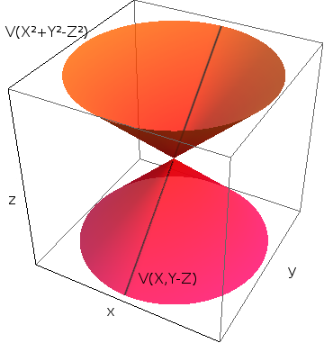

Kerucut ganda yang dipotong oleh sebuah garis miring, dengan sumbu koordinat x, y, dan z

*Tidak setiap fungsi yang terdefinisi di luar garis pada kerucut dapat diperluas ke ruang afin tanpa garis tersebut. Pmidden, domain publik. Rincian sumber berada pada kredit media Unit 16.*

### Contoh: restriksi yang tidak surjektif

Tinjau kerucut standar sebagai subhimpunan tertutup

$$V=V(X^2+Y^2-Z^2)\subseteq\mathbb A_K^3.$$

Misalkan

$$U=D(X,Z-Y)\subseteq\mathbb A_K^3.$$

Irisan $U\cap V=D(X,Z-Y)$, kini dipandang di dalam $V$, merupakan himpunan terbuka di $V$. Homomorfisme gelanggang yang terkait

$$\Gamma(U,\mathcal O)\longrightarrow\Gamma(U\cap V,\mathcal O)$$

tidak surjektif. Di ruas kiri hanya terdapat gelanggang polinomial dalam tiga variabel; bandingkan Soal 14.24. Sebaliknya, dari

$$X^2=Z^2-Y^2=(Z-Y)(Z+Y)$$

diperoleh fungsi aljabar pada $U\cap V$

$$\frac{X}{Z-Y}=\frac{Z+Y}{X}.$$

Fungsi ini tidak berada dalam citra pemetaan tersebut karena tidak memperluas menjadi fungsi pada seluruh kerucut.

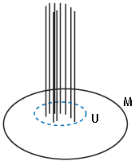

Garis-garis serat vertikal di atas daerah berbentuk oval M, dengan suatu daerah terbuka putus-putus U di dalam M

*Serat-serat suatu pemetaan: $M$ adalah kodomain, domain merupakan gabungan semua serat, dan pemetaan bergerak dari atas ke bawah. １３２人目’, [CC BY-SA 3.0](https://creativecommons.org/licenses/by-sa/3.0/). Rincian sumber berada pada kredit media Unit 16.*

### Definisi: serat

Misalkan

$$\psi:Y\longrightarrow X$$

suatu morfisme antara varietas afin. Untuk suatu titik $P\in X$, pra-citra

$$\psi^{-1}(P)\subseteq Y$$

disebut *serat* di atas $P$. Sebagai subhimpunan tertutup dari $Y$, serat tersebut juga merupakan varietas afin.

**Provenans edisi.** Terjemahan dan produksi pembaca: OpenAI Codex gpt-5.6-sol, Ultra. Sumber, pengarang, dan lisensi komponen dipertahankan seperti dinyatakan dalam metadata dan berkas hak edisi.

# Lembar Kerja 16

## Soal latihan

### Soal 16.1 ★

Misalkan

$$X=K\!-\!\operatorname{Spek}(R)$$

spektrum-$K$ suatu aljabar-$K$ komutatif yang dibangkitkan secara hingga. Tunjukkan bahwa suatu filter tak tereduksi dibangkitkan oleh himpunan-himpunan terbuka berbentuk $D(f)$.

### Soal 16.2

Misalkan $X=K\!-\!\operatorname{Spek}(R)$ varietas afin dan $Z\subseteq X$ subhimpunan tertutup. Tunjukkan bahwa filter lingkungan $\mathcal U(Z)$ dibangkitkan oleh himpunan-himpunan terbuka berbentuk $D(f)$.

### Soal 16.3

Misalkan $X$ ruang topologis. Tunjukkan bahwa setiap ultrafilter bersifat tak tereduksi.

### Soal 16.4

Tunjukkan bahwa, dalam korespondensi Teorema 16.2, ideal maksimal, titik dalam spektrum-$K$, dan filter lingkungan titik saling bersesuaian.

### Soal 16.5

Tunjukkan bahwa, dalam korespondensi Teorema 16.2, ideal prima minimal, komponen tak tereduksi spektrum-$K$, dan ultrafilter saling bersesuaian.

### Soal 16.6

Misalkan $K$ lapangan tertutup secara aljabar. Tinjau bidang afin $\mathbb A_K^2$ beserta sumbu-$x$

$$V=V(y).$$

Tunjukkan bahwa himpunan berikut merupakan sistem multiplikatif jenuh:

$$S=
\left\{
f\in K[X,Y]
\mathrel{\Big|}
\text{komponen homogen }f_{\deg(f)}
\text{ memuat }x^{\deg(f)}
\right\}.$$

Buat sketsa himpunan nol beberapa polinomial yang berada di $S$ dan beberapa yang tidak berada di $S$.

Misalkan $F$ filter topologis yang bersesuaian. Bandingkan $F$ dengan filter lingkungan $V$ dan filter generik $V$.

### Soal 16.7

Misalkan $U$ varietas kuasiafin di atas lapangan tertutup secara aljabar $K$. Tunjukkan bahwa satuan-satuan dalam $\Gamma(U,\mathcal O_U)$ bersesuaian dengan morfisme dari $U$ ke

$$\mathbb A_K^\times
=\mathbb A_K^1\setminus\{0\}.$$

### Soal 16.8

Misalkan $U$ varietas kuasiafin di atas lapangan tertutup secara aljabar $K$ dan

$$\psi:U\longrightarrow\mathbb A_K^n$$

suatu morfisme. Tunjukkan bahwa $\psi$ memfaktor melalui subhimpunan tertutup

$$V(\mathfrak a)\subseteq\mathbb A_K^n$$

jika dan hanya jika $\mathfrak a$ berada dalam kernel homomorfisme gelanggang global

$$\widetilde\psi:
K[T_1,\ldots,T_n]\longrightarrow\Gamma(U,\mathcal O_U).$$

### Soal 16.9

Misalkan $U$ dan $V$ varietas kuasiafin di atas lapangan tertutup secara aljabar $K$, dan misalkan

$$W=U\uplus V$$

gabungan saling lepasnya. Tunjukkan bahwa, untuk setiap varietas kuasiafin $Z$, suatu morfisme $W\to Z$ sama saja dengan sepasang morfisme, masing-masing dari $U$ ke $Z$ dan dari $V$ ke $Z$.

### Soal 16.10 ★

Berikan contoh dua varietas afin $V_1,V_2$ dan suatu morfisme bijektif

$$\psi:V_1\longrightarrow V_2$$

yang pemetaan inversnya tidak kontinu.

### Soal 16.11 ★

Misalkan

$$V=V(x^2+y^2-1)\subseteq\mathbb A_K^2$$

lingkaran satuan di atas lapangan $K$, dan misalkan $P=(a,b)$ serta $Q=(c,d)$ titik-titik pada $V$. Tunjukkan bahwa terdapat automorfisme

$$\varphi:V\longrightarrow V$$

dengan $\varphi(P)=Q$.

### Soal 16.12 ★

1. Dalam kasus real, buat sketsa himpunan nol

   $$V=V(XY,XZ,YZ)\subseteq\mathbb A_K^3$$

   dan

   $$W=V(ST(S-T))\subseteq\mathbb A_K^2.$$
2. Bentuk suatu morfisme bijektif

   $$\varphi:V\longrightarrow W.$$
3. Tunjukkan bahwa, jika karakteristik $K$ bukan $2$, morfisme $\varphi$ merupakan isomorfisme di luar titik asal.

### Soal 16.13 ★

Tunjukkan bahwa pemetaan

$$\begin{aligned}
\varphi:V(Z^2+W^2-1)&\longrightarrow V(X^2+Y^2-1),\\
(Z,W)&\longmapsto(Z^2-W^2,2ZW)=(X,Y)
\end{aligned}$$

merupakan morfisme lingkaran satuan ke dirinya sendiri. Tunjukkan bahwa pra-citra setiap titik

$$P\in V(X^2+Y^2-1)$$

terdiri atas dua titik.

### Soal 16.14

Misalkan $X$ dan $Z$ varietas kuasiafin di atas lapangan tertutup secara aljabar $K$. Untuk setiap himpunan terbuka $U\subseteq X$, tinjau

$$\mathcal F(U)
:=\{\varphi:U\to Z\mid\varphi\text{ merupakan morfisme}\}.$$

Tunjukkan bahwa $\mathcal F$ merupakan berkas pada $X$.

### Soal 16.15 ★

Deskripsikan suatu homomorfisme aljabar-$K$ sedemikian sehingga pemetaan spektrum-$K$ yang diinduksinya menggambarkan operasi penjumlahan pada $K$.

### Soal 16.16

Misalkan $K$ lapangan tertutup secara aljabar. Tunjukkan bahwa penjumlahan, perkalian, negasi, invers, dan pembagian pada $K$ dapat direalisasikan sebagai morfisme pada domain alaminya masing-masing.

### Soal 16.17

Misalkan $R$ gelanggang komutatif,

$$\mathfrak a=(f_1,\ldots,f_n)$$

ideal yang dibangkitkan secara hingga, dan $f\in R$. Aljabar-$R$

$$A=
R[T_1,\ldots,T_n]/(f_1T_1+\cdots+f_nT_n+f)$$

disebut *aljabar pemaksa* bagi $f_1,\ldots,f_n,f$. Tunjukkan bahwa $A$ mempunyai sifat berikut: untuk setiap homomorfisme gelanggang $\varphi:R\to S$ ke suatu gelanggang komutatif $S$ yang memenuhi

$$\varphi(f)\in\mathfrak aS,$$

terdapat homomorfisme aljabar-$R$

$$\vartheta:A\longrightarrow S.$$

Tunjukkan pula bahwa homomorfisme ini *tidak* ditentukan secara tunggal.

### Soal 16.18

Misalkan $R$ aljabar-$K$ komutatif bertipe hingga di atas lapangan tertutup secara aljabar. Untuk $f_1,\ldots,f_n,f\in R$, misalkan

$$A=
R[T_1,\ldots,T_n]/(f_1T_1+\cdots+f_nT_n+f)$$

aljabar pemaksa yang terkait. Karakterisasikan serat-serat morfisme

$$K\!-\!\operatorname{Spek}(A)
\longrightarrow
K\!-\!\operatorname{Spek}(R).$$

## Soal untuk dikumpulkan

### Soal 16.19 (4 poin)

Misalkan $K$ lapangan tertutup secara aljabar, $R,S$ aljabar-$K$ integral bertipe hingga, dan

$$\varphi:R\longrightarrow S$$

suatu homomorfisme aljabar-$K$, dengan morfisme terkait

$$\varphi^*:
K\!-\!\operatorname{Spek}(S)
\longrightarrow
K\!-\!\operatorname{Spek}(R).$$

Tunjukkan bahwa pernyataan-pernyataan berikut ekuivalen.

1. $\varphi$ injektif.
2. Citra $\varphi^*$ rapat dalam $K\!-\!\operatorname{Spek}(R)$.
3. $\varphi$ menginduksi homomorfisme gelanggang $Q(R)\to Q(S)$.

### Soal 16.20 (4 poin)

Misalkan $K$ lapangan tertutup secara aljabar, $R,S$ aljabar-$K$ integral bertipe hingga, dan diberikan homomorfisme aljabar-$K$

$$\varphi:Q(R)\longrightarrow Q(S)$$

antara lapangan pecahannya. Tunjukkan bahwa terdapat himpunan terbuka

$$U\subseteq K\!-\!\operatorname{Spek}(S)$$

dan suatu morfisme

$$U\longrightarrow K\!-\!\operatorname{Spek}(R)$$

yang menginduksi $\varphi$.

### Soal 16.21 (5 poin)

Berikan contoh dua kurva aljabar afin $C_1,C_2$ di atas $\mathbb C$ dan suatu morfisme bijektif

$$\psi:C_1\longrightarrow C_2$$

yang pemetaan inversnya tidak kontinu dalam topologi metrik.

### Soal 16.22 (6 poin)

Berikan contoh dua varietas afin tak tereduksi $V_1,V_2$ dan suatu morfisme bijektif

$$\psi:V_1\longrightarrow V_2$$

yang pemetaan inversnya tidak kontinu dalam topologi Zariski, dan karena itu juga bukan morfisme.

### Soal 16.23 (3 poin)

Misalkan

$$U\subseteq K\!-\!\operatorname{Spek}(R)$$

varietas kuasiafin dan $f\in\Gamma(U,\mathcal O)$ fungsi aljabar. Misalkan

$$f=g_i/h_i,
\qquad i=1,\ldots,n,$$

merupakan penyajian lokal $f$ pada himpunan-himpunan terbuka $D(h_i)\subseteq U$ yang menutupi $U$. Tunjukkan bahwa pra-citra nolnya adalah subhimpunan tertutup

$$f^{-1}(0)=V(h_1g_1,\ldots,h_ng_n)\cap U.$$

**Catatan edisi:** pada ruas kiri penyajian lokal, sumber menulis $q=g_i/h_i$, padahal fungsi yang telah didefinisikan dan yang penyajiannya sedang diberikan adalah $f$. Edisi ini menampilkan variabel yang ditentukan oleh konteks soal.

# Solusi Publik Lembar Kerja 16

Pada batas revisi yang dibekukan, sumber hanya menyediakan solusi publik untuk Soal 16.1, 16.10, 16.11, 16.12, 16.13, dan 16.15. Tidak ada solusi tambahan yang dibuat untuk edisi ini. Solusi 16.13 dipertahankan sampai batas yang benar-benar tersedia di sumber; batas itu dijelaskan pada tempatnya.

## Solusi Soal 16.1

Misalkan $F$ filter tak tereduksi. Untuk setiap $U\in F$, tuliskan

$$U=D(f_1)\cup\cdots\cup D(f_k).$$

Karena $F$ tak tereduksi, setidaknya satu $D(f_i)$ berada di $F$. Karena

$$D(f_i)\subseteq U,$$

himpunan-himpunan terbuka berbentuk $D(f)$ yang berada di $F$ membangkitkan filter tersebut.

Kembali ke Soal 16.1.

## Solusi Soal 16.10

Tinjau garis afin $\mathbb A_K^1$ dan garis tertusuk

$$Y=\mathbb A_K^1\setminus\{0\},$$

yang merupakan varietas afin karena dapat direalisasikan sebagai hiperbola. Tinjau gabungan saling lepas

$$Z=Y\uplus\{P\}$$

dengan satu titik tambahan. Terdapat morfisme alami

$$Z\longrightarrow\mathbb A_K^1$$

yang pada $Y$ merupakan inklusi terbuka dan memetakan $P$ ke titik nol. Pemetaan ini bijektif. Akan tetapi, $\{P\}$ terbuka di sisi kiri dan tidak terbuka di sisi kanan. Jadi pemetaan inversnya tidak kontinu.

Kembali ke Soal 16.10.

## Solusi Soal 16.11

Cukup diberikan, bagi titik $(1,0)$ dan $P=(a,b)\in V$, suatu automorfisme lingkaran yang membawa $(1,0)$ ke $P$. Automorfisme yang diminta dari $P$ ke $Q$ kemudian diperoleh sebagai komposisi pemetaan-pemetaan semacam itu dan, bila perlu, inversnya.

Tinjau pemetaan linear bijektif

$$\varphi:K^2\longrightarrow K^2$$

yang diberikan oleh matriks

$$\begin{pmatrix}
a&-b\\
b&a
\end{pmatrix}.$$

Pemetaan ini membawa $(1,0)$ ke $(a,b)$. Suatu titik $(x,y)\in V$ dipetakan ke

$$(ax-by,bx+ay).$$

Untuk titik citra berlaku

$$\begin{aligned}
(ax-by)^2+(bx+ay)^2
&=a^2x^2-2abxy+b^2y^2+b^2x^2+2abxy+a^2y^2\\
&=(a^2+b^2)x^2+(a^2+b^2)y^2\\
&=x^2+y^2\\
&=1.
\end{aligned}$$

Jadi titik citra kembali berada pada lingkaran dan $\varphi$ menginduksi pemetaan aljabar $V\to V$. Pemetaan linear dengan matriks

$$\begin{pmatrix}
a&b\\
-b&a
\end{pmatrix}$$

memberikan morfisme invers. Dengan demikian diperoleh automorfisme.

**Catatan edisi:** pada suku kedua ruas pertama perhitungan, sumber menulis $(bx+ax)^2$. Pemetaan yang baru saja didefinisikan dan ekspansi pada baris berikutnya sama-sama menuntut $(bx+ay)^2$, yang ditampilkan di sini.

Kembali ke Soal 16.11.

## Solusi Soal 16.12

1. Kita mempunyai

   $$V=V(XY,XZ,YZ)
   =V(X,Y)\cup V(X,Z)\cup V(Y,Z),$$

   yakni gabungan ketiga sumbu koordinat di ruang afin tiga dimensi.

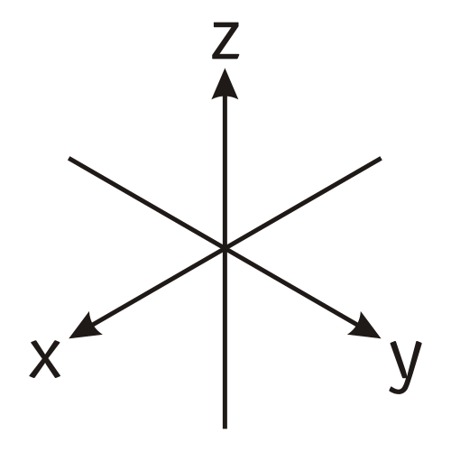

   Tiga sumbu koordinat yang berpotongan di titik asal

   *Sketsa gabungan ketiga sumbu koordinat. Kalan, [CC BY-SA 3.0](https://creativecommons.org/licenses/by-sa/3.0/). Rincian sumber berada pada kredit media Unit 16.*

   **Catatan edisi:** sumber menampilkan $V(XY)\cup V(XZ)\cup V(YZ)$ pada ruas kanan. Gabungan itu bukan himpunan nol bersama ketiga polinomial dan bukan hanya ketiga sumbu. Edisi ini menampilkan dekomposisi komponen yang sesuai dengan ruas kiri dan dengan kalimat sumber sesudahnya.
2. Pemetaan linear

   $$K^3\longrightarrow K^2$$

   yang, terhadap basis standar, diberikan oleh matriks

   $$\begin{pmatrix}
   1&0&1\\
   0&1&1
   \end{pmatrix}$$

   adalah identitas pada bidang $XY$ dan membawa sumbu $Z$ ke diagonal utama bidang tersebut. Karena itu citra gabungan sumbu seluruhnya berada dalam

   $$W=V(ST(S-T)),$$

   sehingga diperoleh morfisme

   $$\varphi:V\longrightarrow W.$$

   Morfisme ini bijektif karena setiap garis yang terlibat dipetakan secara bijektif ke salah satu garis.
3. Secara aljabar terdapat homomorfisme aljabar-$K$

   $$K[S,T]/(ST(S-T))
   \longrightarrow
   K[X,Y,Z]/(XY,XZ,YZ),$$

   dengan

   $$S\longmapsto X+Z,
   \qquad
   T\longmapsto Y+Z.$$

   Homomorfisme ini menginduksi homomorfisme pelokalan

   $$\bigl(K[S,T]/(ST(S-T))\bigr)_{S+T}
   \longrightarrow
   \bigl(K[X,Y,Z]/(XY,XZ,YZ)\bigr)_{X+Y+2Z}.$$

   Irisan $V(S+T)$, maupun $V(X+Y+2Z)$, dengan masing-masing dari ketiga garis hanya terdiri atas titik asal, dengan menggunakan bahwa $\operatorname{char}(K)\ne2$. Karena itu kedua pelokalan menggambarkan komplemen titik asal.

   Dengan variabel

   $$A=X+Z,
   \qquad
   B=Y+Z,$$

   gelanggang di ruas kanan dapat ditulis

   $$K[A,B,Z,(A+B)^{-1}]
   \big/
   \bigl((A-Z)Z,(B-Z)Z,(A-Z)(B-Z)\bigr).$$

   Di dalam gelanggang ini,

   $$\begin{aligned}
   2AB
   &=2Z(A+B)-2Z^2\\
   &=2Z(A+B)-AZ-BZ\\
   &=Z(A+B),
   \end{aligned}$$

   sehingga

   $$Z=\frac{2AB}{A+B}.$$

   Jadi $Z$ dapat dieliminasi. Karena

   $$A-Z
   =A-\frac{2AB}{A+B}
   =\frac{A^2-AB}{A+B},$$

   pembangkit-pembangkit ideal berubah menjadi

   $$(A-Z)Z
   =\frac{2A^2B(A-B)}{(A+B)^2},$$

   $$(B-Z)Z
   =-\frac{2AB^2(A-B)}{(A+B)^2},$$

   dan

   $$\begin{aligned}
   (A-Z)(B-Z)
   &=\frac{A^2-AB}{A+B}\,
   \frac{B^2-AB}{A+B}\\
   &=\frac{2A^2B^2-AB^3-A^3B}{(A+B)^2}.
   \end{aligned}$$

   **Catatan edisi:** sumber mencetak tanda positif di depan pecahan untuk $(B-Z)Z$. Substitusi yang ditampilkan memberi tanda negatif. Perubahan tanda tidak mengubah ideal yang dibangkitkan, tetapi kesamaan aljabarnya ditampilkan dengan tanda yang benar di sini.

   Karena $A+B$ dan $2$ merupakan satuan, kedua pembangkit pertama memberikan

   $$A^3B=A^2B^2=AB^3,$$

   sehingga pembangkit ketiga berlebihan. Selain itu,

   $$AB(A-B)(A+B)=AB(A^2-B^2)$$

   berada dalam ideal. Karena $A+B$ satuan, $AB(A-B)$ juga berada dalam ideal; sebaliknya unsur itu membangkitkan ideal yang sama. Jadi pemetaan yang diberikan oleh $S\mapsto A$ dan $T\mapsto B$ merupakan isomorfisme pada komplemen titik asal.

Kembali ke Soal 16.12.

## Solusi Soal 16.13

Terdapat morfisme

$$V(Z^2+W^2-1)\longrightarrow\mathbb A_K^2.$$

Jadi cukup diperiksa bahwa citranya memenuhi persamaan lingkaran. Memang,

$$\begin{aligned}
X^2+Y^2
&=(Z^2-W^2)^2+4Z^2W^2\\
&=(Z^2-(1-Z^2))^2+4Z^2(1-Z^2)\\
&=(2Z^2-1)^2+4Z^2(1-Z^2)\\
&=4Z^4-4Z^2+1+4Z^2-4Z^4\\
&=1.
\end{aligned}$$

**Batas solusi sumber:** solusi publik yang dibekukan berhenti setelah membuktikan bahwa citra memenuhi persamaan lingkaran. Ia tidak membuktikan pernyataan kedua soal bahwa setiap serat terdiri atas dua titik. Edisi ini tidak mengarang kelanjutan yang tidak tersedia di sumber.

Kembali ke Soal 16.13.

## Solusi Soal 16.15

Tinjau homomorfisme substitusi

$$\begin{aligned}
K[X]&\longrightarrow K[Y,Z],\\
X&\longmapsto Y+Z.
\end{aligned}$$

Pemetaan spektrum yang diinduksi adalah

$$\begin{aligned}
\mathbb A_K^2\cong K^2&\longrightarrow\mathbb A_K^1\cong K,\\
(y,z)&\longmapsto y+z.
\end{aligned}$$

Ini tepat merupakan operasi penjumlahan pada $K$.

Kembali ke Soal 16.15.

# Kuliah 17: Gelanggang Monoid dan Grup Selisih

Setelah mengembangkan teori cukup jauh, kini kita beralih kepada suatu kelas contoh yang luas, yaitu gelanggang monoid.

## Gelanggang monoid

### Definisi: gelanggang monoid

Misalkan $M$ suatu monoid komutatif yang ditulis secara aditif dan $R$ suatu gelanggang komutatif. *Gelanggang monoid* $R[M]$ dibangun sebagai berikut. Sebagai modul-$R$,

$$R[M]=\bigoplus_{m\in M}Re_m,$$

yakni $R[M]$ adalah modul bebas dengan basis

$$(e_m)_{m\in M}.$$

Perkalian pada unsur-unsur basis didefinisikan oleh

$$e_m\cdot e_k:=e_{m+k}$$

dan diperluas secara distributif ke seluruh $R[M]$. Unsur netral $0\in M$ menentukan unsur netral perkalian

$$1=e_0.$$

### Catatan: bentuk unsur dan perkalian

Setiap unsur gelanggang monoid mempunyai bentuk tunggal

$$f=\sum_{m\in\widetilde M}a_me_m,$$

dengan $\widetilde M\subseteq M$ hingga dan $a_m\in R$. Penjumlahan dilakukan per komponen, sedangkan perkalian diberikan secara eksplisit oleh

$$\begin{aligned}
fg
&=\left(\sum_{m\in\widetilde M}a_me_m\right)
\left(\sum_{k\in\overline M}b_ke_k\right)\\
&=\sum_{\ell\in M}
\left(\sum_{\substack{m+k=\ell\\m\in\widetilde M,\ k\in\overline M}}
a_mb_k\right)e_\ell.
\end{aligned}$$

Hanya berhingga banyak $\ell$ yang muncul, dan setiap jumlah di bagian dalam juga hingga. Inilah arti perluasan distributif pada definisi di atas.

Lazimnya $e_m$ ditulis dengan notasi yang lebih sugestif, yaitu $X^m$, dengan $X$ suatu simbol yang mengingatkan kita pada variabel. Aturan

$$X^mX^k=X^{m+k}$$

menyerupai aturan pada gelanggang polinomial. Memang, gelanggang polinomial merupakan kasus khusus gelanggang monoid. Biasanya kita menulis

$$\sum_{m\in M}a_mX^m,$$

dengan hampir semua $a_m=0$. Unsur berbentuk $X^m$ disebut *monomial*. Pemetaan

$$\begin{aligned}
M&\longrightarrow R[M],\\
m&\longmapsto X^m
\end{aligned}$$

adalah homomorfisme monoid, dengan struktur monoid perkalian pada ruas kanan.

Secara alami, gelanggang monoid merupakan aljabar-$R$: unsur $f\in R$ di dalam $R[M]$ dipahami sebagai

$$f=f\cdot1=fX^0.$$

Karena itu $R$ juga disebut *gelanggang dasar* gelanggang monoid tersebut. Gelanggang monoid sudah menarik bahkan ketika gelanggang dasarnya suatu lapangan.

### Contoh: gelanggang polinomial

Misalkan $n$ bilangan asli dan

$$M=\mathbb N^n.$$

Setiap $k\in\mathbb N^n$ merupakan suatu $n$-tuple $k=(k_1,\ldots,k_n)$ dengan $k_i\in\mathbb N$, dan dapat ditulis sebagai

$$(k_1,\ldots,k_n)
=k_1(1,0,\ldots,0)+\cdots+k_n(0,\ldots,0,1).$$

Dengan menulis $X_i=X^{e_i}$ untuk monomial yang bersesuaian dengan unsur basis ke-$i$, kita memperoleh

$$X^k=X_1^{k_1}X_2^{k_2}\cdots X_n^{k_n}.$$

Jadi gelanggang monoid dari $\mathbb N^n$ di atas $R$ tepat merupakan gelanggang polinomial dalam $n$ variabel. Khususnya,

$$R[\mathbb N]=R[X].$$

Gelanggang monoid dari monoid trivial $\{0\}$ adalah gelanggang dasar itu sendiri.

### Contoh: gelanggang Laurent

Misalkan $n$ bilangan asli dan

$$M=\mathbb Z^n.$$

Monoid $M$ adalah grup komutatif bebas berperingkat $n$. Setiap $k\in\mathbb Z^n$ merupakan suatu $n$-tuple $k=(k_1,\ldots,k_n)$ dengan $k_i\in\mathbb Z$, yang dapat ditulis sebagai

$$(k_1,\ldots,k_n)
=k_1(1,0,\ldots,0)+\cdots+k_n(0,\ldots,0,1).$$

Unsur tersebut menghasilkan monomial

$$X^k=X_1^{k_1}X_2^{k_2}\cdots X_n^{k_n},
\qquad X_i=X^{e_i}.$$

Karena itu

$$R[M]
=R[X_1,\ldots,X_n,X_1^{-1},\ldots,X_n^{-1}].$$

Gelanggang ini isomorfik dengan pelokalan gelanggang polinomial pada hasil kali semua variabel:

$$R[M]
=R[X_1,\ldots,X_n,X_1^{-1},\ldots,X_n^{-1}]
=R[X_1,\ldots,X_n]_{X_1\cdots X_n}.$$

Gelanggang tersebut disebut *gelanggang Laurent* dalam $n$ variabel di atas $R$.

## Sifat universal gelanggang monoid

### Teorema: sifat universal

Misalkan $R$ gelanggang komutatif, $M$ monoid komutatif, $B$ aljabar-$R$ komutatif, dan

$$\varphi:M\longrightarrow(B,\cdot,1)$$

homomorfisme monoid. Maka terdapat tepat satu homomorfisme aljabar-$R$

$$\widetilde\varphi:R[M]\longrightarrow B$$

yang membuat diagram berikut komutatif:

$$\begin{matrix}
M&\longrightarrow&R[M]\\
&\searrow&\downarrow\widetilde\varphi\\
&&B.
\end{matrix}$$

#### Bukti

Suatu homomorfisme modul-$R$

$$\widetilde\varphi:R[M]\longrightarrow B$$

ditentukan oleh citra unsur-unsur basis $(X^m)_{m\in M}$. Diagram komutatif tepat ketika

$$\widetilde\varphi(X^m)=\varphi(m).$$

Syarat ini menentukan pemetaan secara tunggal dan langsung memberinya sifat homomorfisme modul-$R$. Kita tinggal memeriksa perkalian. Pertama,

$$\widetilde\varphi(1)
=\widetilde\varphi(X^0)
=\varphi(0)
=1.$$

Selanjutnya,

$$\begin{aligned}
\widetilde\varphi(X^mX^k)
&=\widetilde\varphi(X^{m+k})\\
&=\varphi(m+k)\\
&=\varphi(m)\varphi(k)\\
&=\widetilde\varphi(X^m)\widetilde\varphi(X^k).
\end{aligned}$$

Jadi pemetaan menghormati perkalian pada monomial. Untuk

$$f=\sum_{m\in M}a_mX^m,
\qquad
g=\sum_{k\in M}b_kX^k,$$

dengan dukungan hingga, diperoleh

$$\begin{aligned}
\widetilde\varphi(fg)
&=\widetilde\varphi\!\left(
\sum_{\ell\in M}\left(\sum_{m+k=\ell}a_mb_k\right)X^\ell
\right)\\
&=\sum_{\ell\in M}\left(\sum_{m+k=\ell}a_mb_k\right)
\varphi(\ell)\\
&=\sum_{m,k\in M}a_mb_k\varphi(m)\varphi(k)\\
&=\left(\sum_{m\in M}a_m\varphi(m)\right)
\left(\sum_{k\in M}b_k\varphi(k)\right)\\
&=\widetilde\varphi(f)\widetilde\varphi(g).
\end{aligned}$$

Dengan demikian $\widetilde\varphi$ adalah homomorfisme gelanggang.

### Korolari: funktorialitas terhadap monoid

Misalkan $R$ gelanggang komutatif, $M,N$ monoid komutatif, dan

$$\varphi:M\longrightarrow N$$

homomorfisme monoid. Pemetaan ini menginduksi homomorfisme aljabar-$R$

$$\begin{aligned}
\widetilde\varphi:R[M]&\longrightarrow R[N],\\
X^m&\longmapsto X^{\varphi(m)}.
\end{aligned}$$

#### Bukti

Terapkan Teorema 17.5 pada aljabar-$R$ $B=R[N]$ dan komposisi homomorfisme monoid

$$M\stackrel{\varphi}{\longrightarrow}N\longrightarrow R[N].$$

### Catatan: substitusi dari aljabar polinomial

Suatu keluarga $(m_i)_{i\in I}$ di dalam monoid $M$ menentukan homomorfisme monoid

$$\mathbb N^{(I)}\longrightarrow M$$

yang memetakan unsur basis ke-$i$, $e_i$, ke $m_i$. Jika $I=\{1,\ldots,n\}$ hingga, Korolari 17.6 menghasilkan homomorfisme aljabar-$R$

$$R[\mathbb N^n]=R[X_1,\ldots,X_n]\longrightarrow R[M].$$

Ini adalah homomorfisme substitusi yang diberikan oleh

$$X_i\longmapsto X^{m_i}.$$

### Definisi: titik bernilai gelanggang

Untuk monoid komutatif $M$ dan gelanggang komutatif $R$, suatu homomorfisme monoid

$$M\longrightarrow(R,\cdot,1)$$

disebut *titik bernilai $R$* dari $M$.

### Catatan: titik monoid dan spektrum-$K$

Menurut Teorema 17.5, suatu titik bernilai $R$ dari $M$ ekuivalen dengan homomorfisme aljabar-$R$ dari $R[M]$ ke $R$. Untuk lapangan dasar $K$,

$$\begin{aligned}
K\!-\!\operatorname{Spek}(K[M])
&=\operatorname{Hom}^{\mathrm{alg}}_K(K[M],K)\\
&=\operatorname{Mor}_{\mathrm{mon}}(M,K)\\
&=\{\text{titik bernilai }K\text{ dari }M\}.
\end{aligned}$$

Jadi spektrum-$K$ sudah memiliki deskripsi sederhana pada taraf monoid yang murni bersifat multiplikatif. Akan tetapi, gelanggang monoid tetap mutlak diperlukan untuk mendefinisikan topologi Zariski dan berkas fungsi aljabar pada $K\!-\!\operatorname{Spek}(K[M])$.

### Catatan: pembangkit dan relasi binomial

Monoid komutatif sering dideskripsikan oleh berhingga banyak pembangkit $e_1,\ldots,e_r$ beserta relasi-relasi binomial berbentuk

$$n_1e_1+\cdots+n_re_r=m_1e_1+\cdots+m_re_r,
\qquad n_i,m_i\in\mathbb N.$$

Suatu titik bernilai $K$

$$\varphi:M\longrightarrow K$$

ditentukan secara tunggal oleh $a_i=\varphi(e_i)$. Untuk setiap relasi binomial yang berlaku di $M$, nilai-nilai tersebut harus memenuhi

$$a_1^{n_1}\cdots a_r^{n_r}
=a_1^{m_1}\cdots a_r^{m_r}.$$

### Lema: injektivitas dan surjektivitas

Misalkan $R$ gelanggang komutatif tak nol, $M,N$ monoid komutatif, dan

$$\varphi:M\longrightarrow N$$

homomorfisme monoid. Pemetaan $\varphi$ injektif (berturut-turut, surjektif) jika dan hanya jika homomorfisme aljabar-$R$ terkait

$$\widetilde\varphi:R[M]\longrightarrow R[N]$$

injektif (berturut-turut, surjektif).

#### Bukti

Misalkan $\varphi$ injektif dan

$$\widetilde\varphi\!\left(\sum_{m\in M}a_mX^m\right)
=\sum_{m\in M}a_mX^{\varphi(m)}=0.$$

Karena semua $\varphi(m)$ berbeda, setiap $a_m=0$. Sebaliknya, jika $\varphi$ tidak injektif, ambil $m\ne k$ dengan $\varphi(m)=\varphi(k)$. Maka

$$\widetilde\varphi(X^m)=\widetilde\varphi(X^k),
\qquad X^m\ne X^k,$$

sehingga $\widetilde\varphi$ tidak injektif.

Jika $\varphi$ surjektif, untuk setiap unsur $\sum_{n\in N}a_nX^n\in R[N]$ pilih pra-citra $m_n\in M$ dari $n$. Unsur $\sum_{n\in N}a_nX^{m_n}$ merupakan pra-citranya. Sebaliknya, jika $n\in N$ tidak berada dalam citra $\varphi$, monomial tak nol $X^n$ tidak dapat berada dalam citra $\widetilde\varphi$.

### Korolari: sistem pembangkit

Misalkan $R$ gelanggang komutatif tak nol, $M$ monoid komutatif, dan $(m_i)_{i\in I}$ suatu keluarga unsur $M$. Keluarga $(m_i)_{i\in I}$ membangkitkan $M$ sebagai monoid jika dan hanya jika $(X^{m_i})_{i\in I}$ membangkitkan $R[M]$ sebagai aljabar-$R$.

#### Bukti

Keluarga $(m_i)_{i\in I}$ membangkitkan $M$ tepat ketika homomorfisme monoid

$$\mathbb N^{(I)}\longrightarrow M$$

surjektif. Menurut Lema 17.11, ini ekuivalen dengan surjektivitas

$$\begin{aligned}
R[X_i\mid i\in I]&\longrightarrow R[M],\\
X_i&\longmapsto X^{m_i},
\end{aligned}$$

yang tepat berarti bahwa $X^{m_i}$ membangkitkan $R[M]$ sebagai aljabar-$R$.

### Korolari: funktorialitas terhadap gelanggang dasar

Misalkan $R$ gelanggang komutatif, $S$ aljabar-$R$, dan $M$ monoid komutatif. Terdapat homomorfisme aljabar-$R$ alami

$$\begin{aligned}
R[M]&\longrightarrow S[M],\\
\sum_{m\in M}a_mX^m&\longmapsto\sum_{m\in M}a_mX^m,
\end{aligned}$$

dengan koefisien dari $R$ dipandang melalui pemetaan struktur $R\to S$.

#### Bukti

Terapkan Teorema 17.5 pada aljabar-$R$ $S[M]$ dan homomorfisme monoid alami $M\to S[M]$.

## Grup selisih suatu monoid

Kita ingin mengetahui kapan gelanggang monoid merupakan domain integral (yang hanya mungkin jika gelanggang dasarnya integral) dan bagaimana lapangan pecahannya dapat dideskripsikan. Di dalam lapangan pecahan, setiap unsur tak nol harus dapat dibalik; khususnya, demikian pula monomial-monomial $X^m$. Karena itu wajar untuk mencari suatu grup aditif yang memuat $M$.

**Catatan edisi:** setelah menggunakan $X^m$ secara konsisten sebagai notasi monomial, sumber mencetak $T^m$ pada kalimat terakhir. Edisi ini mempertahankan notasi $X^m$ yang telah ditetapkan dalam kuliah ini.

### Definisi: grup selisih

Misalkan $M$ monoid komutatif. Himpunan *selisih formal*

$$\Gamma(M)=\{m-n\mid m,n\in M\}$$

dilengkapi dengan penjumlahan

$$(m_1-n_1)+(m_2-n_2)
:=(m_1+m_2)-(n_1+n_2)$$

dan identifikasi

$$m_1-n_1=m_2-n_2$$

jika terdapat $u\in M$ sehingga

$$u+m_1+n_2=u+m_2+n_1.$$

Objek $\Gamma(M)$ disebut *grup selisih* dari $M$.

Soal 17.13 meminta pembaca membuktikan bahwa objek tersebut benar-benar suatu grup. Konstruksinya meniru pembentukan lapangan pecahan, dengan notasi perkalian diganti oleh notasi penjumlahan. Sebagai contoh,

$$\Gamma(\mathbb N)=\mathbb Z.$$

Terdapat homomorfisme monoid alami

$$\begin{aligned}
M&\longrightarrow\Gamma(M),\\
m&\longmapsto m-0.
\end{aligned}$$

Biasanya kita menulis $m$ saja untuk $m-0$. Pemetaan ini tidak selalu injektif, karena pada relasi identifikasi di atas boleh muncul unsur tambahan $u$. Kita sekarang mengkarakterisasi monoid yang tidak memerlukan unsur tambahan tersebut.

### Definisi: hukum pembatalan

Suatu monoid komutatif $M$ dikatakan memenuhi *hukum pembatalan* (atau disebut monoid kanselatif) jika, dari

$$m+n=m+k,
\qquad m,n,k\in M,$$

selalu mengikuti $n=k$.

Untuk monoid semacam itu, pemetaan $M\to\Gamma(M)$ bersifat injektif; lihat Soal 17.16.

**Provenans edisi.** Terjemahan dan produksi pembaca: OpenAI Codex gpt-5.6-sol, Ultra. Sumber, pengarang, dan lisensi komponen dipertahankan seperti dinyatakan dalam metadata dan berkas hak edisi.

# Lembar Kerja 17

## Soal latihan

### Soal 17.1

Hitung

$$\left(4T^{(-1,3)}-6T^{(-2,5)}+5T^{(0,-2)}+3T^{(-1,1)}\right)
\left(-7T^{(1,0)}+8T^{(4,5)}-4T^{(-3,5)}+6T^{(3,-1)}\right)$$

di dalam gelanggang monoid $K[\mathbb Z^2]$.

### Soal 17.2

Hitung

$$\left(4T^0-9T^1+9T^2+7T^3-4T^4\right)
\left(4T^0-T^1+5T^2+7T^3-T^4\right)$$

di dalam gelanggang monoid $K[\mathbb Z/(5)]$.

### Soal 17.3 ★

Hitung

$$\left(3T^0-2T^1+5T^2\right)
\left(4T^0-6T^1+5T^2\right)$$

di dalam gelanggang monoid

$$\mathbb Z/(7)[\mathbb Z/(3)]$$

di atas lapangan $\mathbb Z/(7)$.

### Soal 17.4

Tunjukkan bahwa perkalian pada gelanggang monoid dari suatu monoid komutatif memenuhi hukum asosiatif dan distributif.

### Soal 17.5

Misalkan $K$ suatu lapangan. Temukan monoid komutatif $M$ sehingga terdapat isomorfisme

$$K[M]\cong K[X,Y,U,V]/(UX-VY).$$

### Soal 17.6

Misalkan $R$ gelanggang komutatif. Buktikan isomorfisme aljabar-$R$

$$R[\mathbb Z^n]
\cong R[X_1,\ldots,X_n]_{X_1\cdots X_n}$$

dengan menggunakan sifat universal gelanggang monoid dan pelokalan.

### Soal 17.7

Tunjukkan bahwa gelanggang koordinat kerucut standar

$$V(Z^2-X^2-Y^2)$$

di atas $\mathbb C$ dapat direalisasikan sebagai gelanggang monoid.

### Soal 17.8

Misalkan $R$ gelanggang komutatif dan

$$A=R[X_1,\ldots,X_n].$$

Untuk suatu keluarga monomial

$$\{X^\nu\mid \nu\in J\subseteq\mathbb N^n\},$$

tunjukkan bahwa subaljabar-$R$ dari $A$ yang dibangkitkan oleh monomial-monomial tersebut sama dengan gelanggang monoid $R[M]$, dengan $M$ submonoid $\mathbb N^n$ yang dibangkitkan oleh $(\nu)_{\nu\in J}$.

### Soal 17.9

Misalkan $M$ monoid komutatif dan $e\in M$ memenuhi

$$2e=e.$$

Untuk suatu lapangan $K$, tunjukkan bahwa $T^e$ merupakan unsur idempoten di $K[M]$.

### Soal 17.10

Misalkan $G\ne\{0\}$ suatu grup komutatif hingga. Tunjukkan bahwa gelanggang monoid $\mathbb C[G]$ tidak terhubung, walaupun tidak ada unsur $e\ne0$ di $G$ yang memenuhi

$$2e=e.$$

**Catatan edisi:** judul entitas sumber dan konteks gelanggang monoid komutatif menetapkan bahwa $G$ komutatif, tetapi kalimat yang ditampilkan sumber hanya menyebut grup hingga. Edisi ini menampilkan hipotesis komutatif yang dinyatakan oleh entitas soal.

### Soal 17.11

Berikan contoh submonoid

$$M\subseteq\mathbb N^2$$

yang tidak dibangkitkan secara hingga.

Unsur yang dapat dibalik dalam suatu monoid juga disebut *satuan* monoid. Satuan-satuan tersebut membentuk *grup satuan* monoid itu.

### Soal 17.12 ★

Misalkan $M$ monoid komutatif, $K$ lapangan, dan $m\in M$. Tunjukkan bahwa $m$ merupakan satuan di $M$ jika dan hanya jika $T^m$ merupakan satuan di $K[M]$.

### Soal 17.13

Tunjukkan bahwa grup selisih dari suatu monoid komutatif benar-benar merupakan suatu grup.

### Soal 17.14

Misalkan $M$ monoid komutatif. Tunjukkan bahwa grup selisihnya

$$\Gamma=\Gamma(M)$$

merupakan grup komutatif dan mempunyai sifat universal berikut: untuk setiap homomorfisme monoid

$$\varphi:M\longrightarrow G$$

ke suatu grup $G$, terdapat tepat satu homomorfisme grup

$$\widetilde\varphi:\Gamma\longrightarrow G$$

yang memperluas $\varphi$.

### Soal 17.15

Misalkan $M\subseteq N$ monoid-monoid komutatif. Tunjukkan bahwa

$$\widetilde M
=\{n\in N\mid\text{terdapat }k\in\mathbb N_+
\text{ dengan }kn\in M\}$$

merupakan submonoid dari $N$ yang memuat $M$.

### Soal 17.16

Misalkan $M$ monoid komutatif dengan grup selisih $\Gamma=\Gamma(M)$. Tunjukkan bahwa pernyataan-pernyataan berikut ekuivalen.

1. $M$ memenuhi hukum pembatalan.
2. Pemetaan kanonik $M\to\Gamma(M)$ injektif.
3. $M$ dapat direalisasikan sebagai submonoid suatu grup.

### Soal 17.17

Misalkan $M$ monoid komutatif dan $R$ gelanggang komutatif. Karakterisasikan subhimpunan $I\subseteq M$ yang membuat

$$R[I]=\bigoplus_{m\in I}RT^m\subseteq R[M]$$

menjadi ideal di $R[M]$.

**Catatan edisi:** sumber mencetak $\bigoplus_{m\in I}T^m$ tanpa modul koefisien $R$. Karena $R[I]$ dimaksudkan sebagai submodul-$R$ dari $R[M]$, edisi ini menampilkan $\bigoplus_{m\in I}RT^m$.

### Soal 17.18

Tinjau homomorfisme monoid

$$\mathbb N^2\longrightarrow\mathbb Z,
\qquad e_1\longmapsto1,
\qquad e_2\longmapsto-1.$$

Deskripsikan pemetaan terkait antara gelanggang-gelanggang monoid (untuk suatu lapangan $K$) dan antara spektrum-$K$ terkait.

### Soal 17.19

Tinjau monoid komutatif

$$M=\mathbb N^r,
\qquad
N=\mathbb N^s.$$

Tunjukkan bahwa suatu homomorfisme monoid dari $M$ ke $N$ ditentukan secara tunggal oleh matriks berentri di $\mathbb N$ dengan $r$ kolom dan $s$ baris. Bagaimana bentuk pemetaan spektrum yang terkait?

### Soal 17.20

Misalkan $M$ suatu matriks persegi $r\times r$ berentri di $\mathbb N$, dengan pemetaan monoid dan pemetaan spektrum terkait

$$\varphi:
K\!-\!\operatorname{Spek}(K[\mathbb N^r])
\longrightarrow
K\!-\!\operatorname{Spek}(K[\mathbb N^r]),$$

dengan $K$ lapangan tak hingga. Tunjukkan bahwa

$$\det M\ne0$$

jika dan hanya jika $\varphi$ memetakan secara surjektif ke suatu himpunan terbuka di $K\!-\!\operatorname{Spek}(K[\mathbb N^r])$.

Soal berikut menggunakan definisi ini. Suatu *filter* $F$ dalam monoid komutatif $M$ adalah submonoid yang juga *stabil terhadap pembagi*: jika $f\in F$ dan $g\mid f$, maka $g\in F$.

### Soal 17.21

Misalkan $M$ monoid komutatif. Tunjukkan bahwa terdapat filter terkecil di $M$ dan bahwa filter tersebut membentuk suatu grup.

### Soal 17.22

Misalkan $M$ monoid komutatif dan $f\in M$. Tinjau himpunan

$$M_f
=\{m-nf\mid m\in M,\ n\in\mathbb N\}/\!\sim,$$

dengan

$$m-nf\sim m'-n'f$$

jika dan hanya jika terdapat $k\in\mathbb N$ sehingga

$$m+n'f+kf=m'+nf+kf$$

di $M$.

1. Tunjukkan bahwa $\sim$ merupakan relasi ekuivalensi.
2. Definisikan struktur monoid pada $M_f$.
3. Misalkan $R$ gelanggang komutatif dan $T^f\in R[M]$ monomial yang bersesuaian dengan $f$. Tunjukkan bahwa

   $$R[M_f]\cong R[M]_{T^f}.$$

### Soal 17.23

Misalkan $M,N$ monoid komutatif yang dibangkitkan secara hingga, dengan

$$K\!-\!\operatorname{Spek}(K[M])
=\operatorname{Mor}_{\mathrm{mon}}(M,K)$$

dan

$$K\!-\!\operatorname{Spek}(K[N])
=\operatorname{Mor}_{\mathrm{mon}}(N,K).$$

Untuk homomorfisme monoid $\varphi:M\to N$, tunjukkan bahwa pemetaan spektrum terkait dapat didefinisikan dengan dua cara berbeda yang secara substantif sama.

### Soal 17.24

Tinjau monoid komutatif $M$ dengan tiga pembangkit $e,f,g$ dan satu-satunya relasi

$$e+f=5g.$$

Tentukan spektrum-$K$ dari $M$ untuk berbagai lapangan $K$.

### Soal 17.25

Misalkan $M$ monoid komutatif hingga. Tunjukkan bahwa spektrum-$K$ dari $M$ juga hingga.

### Soal 17.26

Di dalam

$$R=\mathbb R[\mathbb Q_{\geq0}],$$

hitung hasil kali

$$\left(X^2+4X^{3/2}-5X+X^{1/2}\right)
\left(2X^{3/2}+4X-7X^{1/2}\right).$$

### Soal 17.27

Misalkan $K$ lapangan. Tunjukkan bahwa setiap unsur

$$F\in R=K[\mathbb Q_{\geq0}]$$

dapat ditulis sebagai polinomial dalam $X^{1/b}$ untuk suatu $b\in\mathbb N_+$. Dengan kata lain, terdapat $P\in K[Y]$ sehingga

$$F=P(X^{1/b}).$$

Polinomial apa yang dapat dipilih untuk

$$F=X^{1/2}+X^{1/3}+X^{1/5}?$$

### Soal 17.28

Tunjukkan bahwa di dalam $R=K[\mathbb Q_{\geq0}]$, unsur $X$ tidak mempunyai faktorisasi menjadi unsur-unsur tak tereduksi.

### Soal 17.29

Tunjukkan bahwa di dalam $R=\mathbb R[\mathbb Q_{\geq0}]$, unsur $X^2+1$ tidak tak tereduksi.

### Soal 17.30

Tunjukkan bahwa di dalam $R=\mathbb C[\mathbb Q_{\geq0}]$ tidak terdapat unsur tak tereduksi.

### Soal 17.31 ★

Tentukan semua pembagi $X$ dalam gelanggang

$$R=K[\mathbb Q_{\geq0}],$$

dengan $K$ suatu lapangan.

### Soal 17.32 ★

Tentukan satuan-satuan dalam gelanggang

$$R=K[\mathbb Q],$$

dengan $K$ suatu lapangan.

## Soal untuk dikumpulkan

### Soal 17.33 (6 poin)

Misalkan $M\subseteq N$ monoid-monoid komutatif yang dibangkitkan secara hingga dan memenuhi hukum pembatalan. Tunjukkan bahwa, untuk suatu lapangan $K$, homomorfisme gelanggang

$$K[M]\subseteq K[N]$$

hingga jika dan hanya jika, untuk setiap $n\in N$, terdapat $k\in\mathbb N_+$ dengan $kn\in M$.

### Soal 17.34 (4 poin)

Misalkan

$$M=(\mathbb Q,+)$$

grup aditif bilangan rasional. Tentukan

$$\mathbb Q\!-\!\operatorname{Spek}(\mathbb Q[M]).$$

Bagaimana hasilnya jika $\mathbb Q$ diganti dengan $\mathbb R$?

### Soal 17.35 (4 poin)

Misalkan

$$\varphi:M\longrightarrow N$$

homomorfisme monoid komutatif. Tunjukkan bahwa himpunan semua titik di $K\!-\!\operatorname{Spek}(K[N])$ yang oleh pemetaan spektrum dipetakan ke titik satu

$$1\in K\!-\!\operatorname{Spek}(K[M])$$

(yakni titik yang bersesuaian dengan pemetaan konstan $M\to1$) mempunyai struktur spektrum-$K$ dari suatu monoid yang sesuai.

### Soal 17.36 (4 poin)

Tinjau monoid-monoid berbentuk

$$M=(\mathbb Z/(m),+).$$

Deskripsikan $K\!-\!\operatorname{Spek}(K[M])$ secara umum dan secara khusus untuk

$$K=\mathbb R,\ \mathbb C,\ \mathbb Z/(5).$$

Temukan unsur-unsur idempoten di

$$\mathbb C[\mathbb Z/(3)].$$

### Soal 17.37 (4 poin)

Misalkan $M$ monoid komutatif. Definisikan bijeksi antara objek-objek berikut.

1. Filter-filter di $M$.
2. $\operatorname{Mor}_{\mathrm{mon}}(M,(\{0,1\},1,\cdot))$.
3. $\mathbb F_2\!-\!\operatorname{Spek}(M)$.
4. Himpunan

   $$\left\{
   \varphi\in K\!-\!\operatorname{Spek}(K[M])
   \mathrel{\Big|}
   \varphi(M)\subseteq\{0,1\}
   \right\},$$

   dengan $K$ suatu lapangan.

### Soal 17.38 (3 poin)

Misalkan $M,N$ monoid komutatif dan $K$ lapangan. Apa hubungan antara

$$K\!-\!\operatorname{Spek}(K[M\times N])$$

dan

$$K\!-\!\operatorname{Spek}(K[M]),
\qquad
K\!-\!\operatorname{Spek}(K[N])?$$

### Soal 17.39 (4 poin)

Misalkan $K$ lapangan dan $G$ grup. Tinjau gelanggang grup $K[G]$, lalu misalkan $M$ suatu modul-$K[G]$. Tunjukkan bahwa:

1. $M$ tidak lain adalah ruang vektor-$K$ $V$ beserta homomorfisme grup

   $$\rho:G\longrightarrow\operatorname{Aut}_K(V);$$
2. suatu homomorfisme modul-$K[G]$

   $$\varphi:M\longrightarrow M$$

   adalah pemetaan linear-$K$ yang juga memenuhi

   $$\varphi\circ\rho(g)=\rho(g)\circ\varphi$$

   untuk setiap $g\in G$.

Pemetaan $\rho$ disebut *representasi* dari $G$. Representasi semacam itu sering lebih mudah ditangani daripada $G$ sendiri, dan kerap memberi wawasan yang berguna mengenai $G$.

**Catatan edisi:** ruas kanan persamaan sumber mencetak $\rho\circ\varphi$ tanpa argumen $g$. Edisi ini menampilkan $\rho(g)\circ\varphi$, endomorfisme yang bertipe benar dan yang menyatakan syarat pemetaan saling-menjalin.

# Solusi Publik Lembar Kerja 17

Pada batas revisi yang dibekukan, sumber hanya menyediakan solusi publik untuk Soal 17.3, 17.12, 17.31, dan 17.32. Tidak ada solusi tambahan yang dibuat untuk edisi ini.

## Solusi Soal 17.3

Di dalam $\mathbb Z/(7)[\mathbb Z/(3)]$, koefisien dihitung modulo $7$ dan pangkat $T$ modulo $3$. Karena itu

$$\begin{aligned}
&(3T^0-2T^1+5T^2)(4T^0-6T^1+5T^2)\\
&=(3T^0+5T^1+5T^2)(4T^0+T^1+5T^2)\\
&=5T^0+3T^1+T^2+6T^1+5T^2+4T^0
+6T^2+5T^0+4T^1\\
&=6T+5T^2.
\end{aligned}$$

Kembali ke Soal 17.3.

## Solusi Soal 17.12

Jika $m$ satuan di $M$, terdapat $n\in M$ dengan

$$m+n=0.$$

Maka

$$T^mT^n=T^{m+n}=T^0=1,$$

sehingga $T^m$ satuan di gelanggang monoid.

Sebaliknya, misalkan $T^m$ satuan di gelanggang monoid. Terdapat unsur

$$P=\sum_{n\in E}a_nT^n$$

dengan dukungan hingga $E\subseteq M$, semua koefisien yang dicantumkan $a_n\in K$ tak nol, dan

$$T^mP=\sum_{n\in E}a_nT^{m+n}=1.$$

Koefisien $T^0$ pada ruas kiri sama dengan $1$, sehingga setidaknya terdapat $n\in E$ dengan

$$m+n=0.$$

Jadi $m$ mempunyai invers di $M$.

**Catatan edisi:** sumber menyatakan bahwa semua eksponen $m+n$ harus sama dengan nol. Pada monoid yang tidak memenuhi hukum pembatalan, suku-suku dengan eksponen yang sama dapat bergabung dan saling meniadakan di luar nol. Argumen yang diperlukan dan sah adalah bahwa koefisien tak nol dari $T^0$ menjamin keberadaan setidaknya satu $n$ dengan $m+n=0$; itulah yang ditampilkan di atas.

Kembali ke Soal 17.12.

## Solusi Soal 17.31

Pembagi-pembagi $X$ tepat merupakan unsur berbentuk

$$aX^q,
\qquad a\ne0,
\qquad q\in\mathbb Q_{\geq0},
\qquad q\leq1.$$

Setiap unsur semacam itu memang pembagi, sebab

$$(aX^q)(a^{-1}X^{1-q})
=X^qX^{1-q}
=X^{q+1-q}
=X.$$

Sebaliknya, misalkan

$$P=a_{q_1}X^{q_1}+a_{q_2}X^{q_2}+\cdots+a_{q_n}X^{q_n},
\qquad
0\leq q_1<q_2<\cdots<q_n,$$

merupakan pembagi $X$. Maka terdapat

$$Q=b_{r_1}X^{r_1}+b_{r_2}X^{r_2}+\cdots+b_{r_m}X^{r_m},
\qquad
0\leq r_1<r_2<\cdots<r_m,$$

dengan semua koefisien yang dicantumkan tak nol dan $PQ=X$. Suku berpangkat terendah dan tertinggi dalam hasil kali itu adalah

$$a_{q_1}b_{r_1}X^{q_1+r_1}
\quad\text{dan}\quad
a_{q_n}b_{r_m}X^{q_n+r_m};$$

keduanya tak nol. Agar $PQ=X$, harus berlaku

$$q_1+r_1=q_n+r_m=1.$$

Karena urutan eksponen ketat, ini hanya mungkin jika $n=m=1$. Jadi $P=aX^q$ dengan $0\leq q\leq1$, seperti dinyatakan.

**Catatan edisi:** pada suku ekstrem terakhir, sumber mencetak $a_{q_n}b_{r_n}$, padahal dukungan $Q$ mempunyai $m$ suku dan baris berikutnya sendiri menggunakan $r_m$. Edisi ini menampilkan indeks terminal $a_{q_n}b_{r_m}$.

Kembali ke Soal 17.31.

## Solusi Soal 17.32

Satuan-satuan tepat merupakan unsur berbentuk

$$aX^q,
\qquad a\ne0,
\qquad q\in\mathbb Q.$$

Unsur semacam itu satuan karena

$$(aX^q)(a^{-1}X^{-q})
=X^qX^{-q}
=X^{q-q}
=X^0
=1.$$

Sebaliknya, misalkan

$$P=a_{q_1}X^{q_1}+a_{q_2}X^{q_2}+\cdots+a_{q_n}X^{q_n},
\qquad
q_1<q_2<\cdots<q_n,$$

suatu satuan. Terdapat

$$Q=b_{r_1}X^{r_1}+b_{r_2}X^{r_2}+\cdots+b_{r_m}X^{r_m},
\qquad
r_1<r_2<\cdots<r_m,$$

dengan semua koefisien yang dicantumkan tak nol dan $PQ=1$. Suku berpangkat terendah dan tertinggi dalam hasil kali adalah

$$a_{q_1}b_{r_1}X^{q_1+r_1}
\quad\text{dan}\quad
a_{q_n}b_{r_m}X^{q_n+r_m},$$

dan keduanya tak nol. Agar hasil kali sama dengan $1$, harus berlaku

$$q_1+r_1=q_n+r_m=0.$$

Ketatnya urutan eksponen memaksa $n=m=1$. Jadi $P=aX^q$.

Kembali ke Soal 17.32.

# Kuliah 18: Kurva Monomial dan Monoid Numerik

## Kurva monomial

Sekarang kita mengkhususkan teori gelanggang monoid pada kasus satu dimensi dan memperoleh gelanggang-gelanggang yang mendeskripsikan kurva monomial.

### Definisi: kurva monomial

Suatu *kurva monomial* adalah citra garis afin $\mathbb A_K^1$ di bawah pemetaan berbentuk

$$\begin{aligned}
\mathbb A_K^1&\longrightarrow\mathbb A_K^n,\\
t&\longmapsto(t^{e_1},\ldots,t^{e_n}),
\end{aligned}$$

dengan $e_i\geq1$ untuk semua $i$.

Kita akan segera melihat bahwa citra pemetaan monomial semacam itu tertutup secara Zariski. Jadi kurva monomial benar-benar merupakan kurva aljabar. Karena terparametrisasi, kurva monomial merupakan kurva rasional, tetapi pada umumnya bukan kurva bidang. Kadang-kadang pemetaannya sendiri juga disebut kurva monomial.

Sering kali kita membatasi perhatian pada eksponen $e_i$ yang secara bersama saling prima. Ini bukan pembatasan penting. Jika $m$ adalah faktor persekutuan terbesar semua $e_i$, kita dapat menulis

$$e_i=mf_i$$

dengan $f_1,\ldots,f_n$ saling prima, lalu memfaktorkan pemetaan sebagai

$$\mathbb A_K^1\longrightarrow\mathbb A_K^1\longrightarrow\mathbb A_K^n,
\qquad
t\longmapsto t^m=s,
\qquad
s\longmapsto(s^{f_1},\ldots,s^{f_n}).$$

Pemetaan pertama hanyalah pemangkatan, sedangkan pemetaan kedua adalah pemetaan kurva monomial dengan eksponen saling prima.

**Catatan edisi:** meskipun domain pemetaan kedua adalah garis afin dengan koordinat tunggal $s$, sumber mencetak koordinat citranya sebagai $(s_1^{f_1},\ldots,s_n^{f_n})$. Edisi ini menampilkan pangkat dari input skalar yang telah didefinisikan, yakni $(s^{f_1},\ldots,s^{f_n})$.

### Catatan: pemetaan monoid yang mendasari

Pemetaan monomial

$$t\longmapsto(t^{e_1},\ldots,t^{e_n})$$

tidak lain adalah pemetaan spektrum-$K$ yang bersesuaian dengan homomorfisme monoid

$$\mathbb N^n\longrightarrow\mathbb N$$

yang membawa vektor basis ke-$i$ ke $e_i$; bandingkan Catatan 17.9.

**Catatan edisi:** sumber mencetak koordinat sebagai $(t_1^{e_1},\ldots,t_n^{e_n})$, padahal inputnya adalah skalar tunggal $t$. Edisi ini menampilkan koordinat yang bertipe benar.

Homomorfisme monoid tersebut memfaktor sebagai

$$\mathbb N^n\longrightarrow M\longrightarrow\mathbb N,$$

dengan $M$ submonoid $\mathbb N$ yang dibangkitkan oleh $e_1,\ldots,e_n$. Submonoid semacam itu disebut *monoid numerik*. Pemetaan pertama surjektif. Pada taraf gelanggang kita memperoleh

$$K[\mathbb N^n]=K[X_1,\ldots,X_n]
\longrightarrow K[M]
\longrightarrow K[\mathbb N]=K[T],$$

sedangkan secara geometris kita memperoleh pemetaan spektrum

$$\mathbb A_K^1
\longrightarrow
K\!-\!\operatorname{Spek}(K[M])
\subseteq\mathbb A_K^n.$$

Jadi citra garis afin berada di dalam spektrum-$K$ gelanggang monoid $K[M]$. Teorema 18.10 akan menunjukkan bahwa

$$\mathbb A_K^1\longrightarrow K\!-\!\operatorname{Spek}(K[M])$$

selalu surjektif dan, jika eksponen-eksponennya saling prima, juga injektif.

### Contoh: parabola Neil

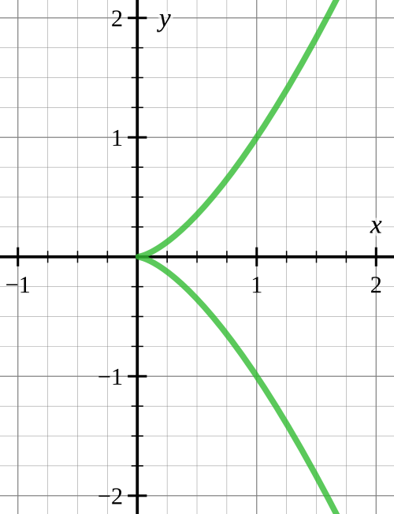

Kurva berbentuk cusp dengan dua cabang halus yang bertemu runcing di titik asal

*Parabola Neil dengan titik singular kuspidal di titik asal. Georg-Johann, [CC BY-SA 3.0](https://creativecommons.org/licenses/by-sa/3.0/). Rincian sumber dan perbedaan label hak berada pada kredit media Unit 18.*

*Parabola Neil* $C$ adalah citra pemetaan monomial

$$\begin{aligned}
\mathbb A_K^1&\longrightarrow\mathbb A_K^2,\\
t&\longmapsto(t^2,t^3)=(x,y).
\end{aligned}$$

Persamaan yang terkait adalah

$$y^2=x^3,$$

sehingga

$$C=V(Y^2-X^3).$$

Kurva monomial hanya ditentukan oleh tuple eksponen $(e_1,\ldots,e_n)$, atau ekuivalen oleh monoid numerik yang dibangkitkannya. Jadi data kombinatorial yang diperlukan sangat sedikit. Walaupun demikian, kurva-kurva ini menyediakan banyak contoh yang kaya dalam teori kurva aljabar. Fenomena serupa berlaku lebih umum untuk gelanggang monoid dan varietas aljabar yang didefinisikannya.

## Invarian monoid numerik

### Lema: semua bilangan yang cukup besar berada di dalam monoid

Misalkan $M\subseteq\mathbb N$ monoid numerik yang dibangkitkan oleh bilangan asli saling prima $e_1,\ldots,e_n$. Untuk setiap $m\in\mathbb N$ terdapat penyajian

$$m=a_1e_1+\cdots+a_ne_n$$

dengan

$$0\leq a_i<e_{i+1},
\qquad 1\leq i\leq n-1.$$

Jika $m$ cukup besar, kita juga dapat memilih $a_n\geq0$, sehingga semua koefisien dalam penyajian tersebut tak negatif.

#### Bukti

Karena $e_1,\ldots,e_n$ saling prima, mula-mula terdapat penyajian

$$m=b_1e_1+\cdots+b_ne_n$$

dengan koefisien bilangan bulat. Kita ubah penyajian ini langkah demi langkah. Dengan pembagian bersisa, tuliskan

$$b_1=c_1e_2+a_1,
\qquad
0\leq a_1<e_2.$$

Substitusikan ke penyajian $m$ dan gabungkan suku $c_1e_2e_1$ dengan $b_2e_2$. Koefisien kedua yang baru kemudian diproses bersama pembangkit ketiga dengan cara yang sama. Dengan melanjutkan proses ini, semua koefisien pertama sampai ke-$(n-1)$ memperoleh bentuk yang diinginkan.

Dalam bentuk tersebut, jumlah $n-1$ suku pertama terbatas oleh suatu konstanta yang hanya bergantung pada para pembangkit. Jika $m$ melampaui batas itu, suku terakhir, dan karenanya koefisien terakhir $a_n$, harus tak negatif.

Jadi, mulai dari suatu ambang tertentu, setiap bilangan asli berada di dalam monoid yang dibangkitkan oleh eksponen-eksponen saling prima itu. Ambang minimal tersebut memperoleh nama khusus.

### Definisi: bilangan konduktor

Misalkan $M\subseteq\mathbb N$ monoid numerik yang dibangkitkan oleh pembangkit-pembangkit saling prima. Bilangan terkecil $f$ yang memenuhi

$$\mathbb N_{\geq f}\subseteq M$$

disebut *bilangan konduktor* $M$.

Invarian-invarian berikut juga dapat dihitung secara diskret pada taraf monoid numerik. Kelak kita akan mendefinisikannya untuk kurva aljabar sebarang; pada keumuman itu, penghitungannya biasanya lebih sulit.

### Definisi: dimensi penyematan

Misalkan $M\subseteq\mathbb N$ monoid numerik dengan pembangkit-pembangkit saling prima. Jumlah unsur terkecil di antara semua sistem pembangkit $M$ disebut *dimensi penyematan* $M$.

### Definisi: multiplisitas

Misalkan $M\subseteq\mathbb N$ monoid numerik dengan pembangkit-pembangkit saling prima. Unsur positif terkecil

$$e\in M,
\qquad e\geq1,$$

disebut *multiplisitas* $M$ dan ditulis $e(M)$.

### Definisi: derajat singularitas

Misalkan $M\subseteq\mathbb N$ monoid numerik dengan pembangkit-pembangkit saling prima. Banyak celah, yakni banyak unsur dalam

$$\mathbb N\setminus M,$$

disebut *derajat singularitas* $M$ dan ditulis $\delta(M)$.

### Contoh: monoid yang dibangkitkan oleh 5, 8, dan 11

Tinjau monoid numerik $M$ yang dibangkitkan oleh $5,8,11$. Jadi $M$ terdiri atas semua jumlah

$$5a_1+8a_2+11a_3,
\qquad a_1,a_2,a_3\geq0.$$

Unsur-unsurnya mencakup

$$0,5,8,10,11,13,15,16,18,19,20,21,22,23,24,25,\ldots.$$

Karena $18,19,20,21,22$ merupakan lima bilangan berurutan di $M$ dan $5\in M$, semua bilangan setelahnya juga berada di $M$. Karena itu bilangan konduktornya $18$, multiplisitasnya $5$, derajat singularitasnya $10$, dan dimensi penyematannya $3$.

## Parametrisasi dan sistem pembangkit kanonik

### Teorema: parametrisasi monomial adalah bijeksi

Misalkan $M\subseteq\mathbb N$ submonoid yang dibangkitkan oleh bilangan asli saling prima $e_1,\ldots,e_n$. Pemetaan monomial

$$\mathbb A_K^1\longrightarrow K\!-\!\operatorname{Spek}(K[M])$$

merupakan bijeksi.

#### Bukti

Menurut Catatan 17.9, pemetaan ini dapat dipandang sebagai pemetaan alami

$$\mathbb A_K^1
=\operatorname{Mor}_{\mathrm{mon}}(\mathbb N,K)
\longrightarrow
\operatorname{Mor}_{\mathrm{mon}}(M,K)$$

yang diinduksi oleh inklusi $M\subseteq\mathbb N$.

Untuk membuktikan injektivitas, misalkan $a,b\in K$ dan

$$a^m=b^m$$

untuk semua $m\in M$. Jika $b=0$, segera diperoleh $a=0$. Jadi anggap $b\ne0$; dengan cara yang sama $a\ne0$. Menurut Lema 18.4, mulai dari suatu $f$, semua bilangan asli berada di $M$. Khususnya,

$$a^f=b^f,
\qquad
a^{f+1}=b^{f+1}.$$

Maka

$$a=\frac{a^{f+1}}{a^f}
=\frac{b^{f+1}}{b^f}
=b.$$

Untuk surjektivitas, berikan homomorfisme monoid

$$\varphi:M\longrightarrow K.$$

Kita harus memperluasnya ke seluruh $\mathbb N$. Tuliskan

$$\varphi(e_i)=a_i\in K.$$

Nilai-nilai ini memenuhi

$$a_j^{e_i}
=\varphi(e_j)^{e_i}
=\varphi(e_ie_j)
=\varphi(e_i)^{e_j}
=a_i^{e_j}.$$

Jika salah satu $a_i=0$, semua $a_i=0$, dan pemetaan yang membawa setiap bilangan positif ke $0$ (serta $0$ ke $1$) memberi perluasan. Jadi kita dapat menganggap semua $a_i$ satuan.

Karena $e_i$ saling prima, terdapat $m_1,\ldots,m_n\in\mathbb Z$ dengan

$$m_1e_1+\cdots+m_ne_n=1.$$

Tetapkan

$$a=a_1^{m_1}\cdots a_n^{m_n}.$$

Kita klaim bahwa homomorfisme $\mathbb N\to K$ yang ditentukan oleh $1\mapsto a$, yakni $k\mapsto a^k$, memperluas $\varphi$. Cukup memeriksanya pada semua $e_i$. Untuk $e_1$,

$$\begin{aligned}
a^{e_1}
&=(a_1^{m_1}\cdots a_n^{m_n})^{e_1}\\
&=a_1^{e_1m_1}a_2^{e_1m_2}\cdots a_n^{e_1m_n}\\
&=a_1^{1-\sum_{i=2}^nm_ie_i}
(a_2^{e_1m_2}\cdots a_n^{e_1m_n})\\
&=a_1(a_1^{-e_2}a_2^{e_1})^{m_2}
\cdots(a_1^{-e_n}a_n^{e_1})^{m_n}\\
&=a_1,
\end{aligned}$$

karena setiap faktor dalam baris kedua terakhir sama dengan $1$ menurut relasi $a_j^{e_i}=a_i^{e_j}$. Argumen yang sama berlaku untuk setiap $e_i$.

### Catatan: bukti melalui grup selisih

Surjektivitas teorema di atas juga dapat dilihat melalui sifat universal grup selisih. Grup selisih monoid numerik dengan pembangkit saling prima adalah $\mathbb Z$. Kasus ketika suatu pembangkit dipetakan ke nol ditangani seperti dalam bukti. Jika semua citra bukan nol, kita memperoleh homomorfisme monoid

$$\varphi:M\longrightarrow K^\times.$$

Sifat universal grup selisih memberikan perluasan tunggal

$$\widetilde\varphi:\mathbb Z\longrightarrow K^\times,$$

yang menghasilkan pra-citra yang diperlukan.

**Catatan edisi:** pada langkah ini sumber menyebut sifat universal gelanggang monoid. Konstruksi yang benar-benar digunakan adalah perluasan dari $M$ ke grup selisihnya $\mathbb Z$, sehingga edisi ini menampilkan sifat universal grup selisih.

Dua pernyataan berikut menunjukkan bahwa monoid numerik mempunyai sistem pembangkit kanonik. Dengan demikian dimensi penyematan memperoleh interpretasi yang kelak dapat dialihkan ke gelanggang lokal Noether sebarang. Gelanggang monoid itu sendiri tentu tidak lokal, tetapi pelokalannya pada singularitas monoid numerik bersifat lokal.

### Lema: sistem pembangkit minimal kanonik

Misalkan $M\subseteq\mathbb N$ monoid numerik dengan pembangkit-pembangkit saling prima. Tetapkan

$$M_+=\{m\in M\mid m\geq1\}$$

dan

$$M_++M_+=\{m+m'\mid m,m'\in M_+\}.$$

Maka

$$M_+\setminus(M_++M_+)$$

merupakan sistem pembangkit $M$, dan setiap sistem pembangkit lain memuat himpunan ini.

#### Bukti

Suatu unsur

$$m\in M_+\setminus(M_++M_+)$$

tidak dapat ditulis sebagai jumlah dua unsur positif lain dari $M$. Karena itu ia harus berada dalam setiap sistem pembangkit.

Sebaliknya, himpunan tersebut sudah membangkitkan $M$. Jika tidak, pilih unsur terkecil $x\in M$ yang tidak dibangkitkannya. Karena $x$ bukan anggota $M_+\setminus(M_++M_+)$, terdapat

$$x=x_1+x_2,
\qquad x_1,x_2\in M_+.$$

Kedua suku lebih kecil daripada $x$, sehingga masing-masing dapat ditulis sebagai jumlah unsur-unsur dari himpunan kanonik. Ini langsung memberi kontradiksi.

**Catatan edisi:** sumber mencetak $x_1,x_2\in M_++M_+$. Dari $x\in M_++M_+$, definisi himpunan jumlah hanya memberikan $x_1,x_2\in M_+$, dan keanggotaan inilah yang diperlukan untuk argumen descent minimal.

### Korolari: dimensi penyematan dari pembangkit kanonik

Dalam situasi lema di atas, dimensi penyematan $M$ sama dengan banyak unsur dalam

$$M_+\setminus(M_++M_+).$$

#### Bukti

Pernyataan ini langsung mengikuti dari Lema 18.12.

**Provenans edisi.** Terjemahan dan produksi pembaca: OpenAI Codex gpt-5.6-sol, Ultra. Sumber, pengarang, dan lisensi komponen dipertahankan seperti dinyatakan dalam metadata dan berkas hak edisi.

# Lembar Kerja 18

## Soal latihan

### Soal 18.1

Seorang pemalsu uang membuat uang kertas 3 euro dan 7 euro.

1. Tunjukkan bahwa hanya ada berhingga banyak jumlah uang yang tidak dapat ia bayarkan secara tepat. Berapakah jumlah terbesar yang tidak dapat ia bayarkan?
2. Berapakah jumlah terkecil yang dapat ia bayarkan dengan dua cara berbeda?
3. Deskripsikan himpunan $M$ dari jumlah-jumlah euro bulat yang dapat ia bayarkan dengan uang kertasnya.

### Soal 18.2

Seorang pemalsu uang membuat uang kertas 4 euro, 9 euro, dan 11 euro.

1. Tunjukkan bahwa hanya ada berhingga banyak jumlah uang yang tidak dapat ia bayarkan secara tepat. Berapakah jumlah terbesar yang tidak dapat ia bayarkan?
2. Berapakah jumlah terkecil yang dapat ia bayarkan dengan dua cara berbeda?
3. Deskripsikan secara eksplisit himpunan $M$ dari jumlah-jumlah euro bulat yang dapat ia bayarkan dengan uang kertasnya.

### Soal 18.3 ★

Seorang pemalsu uang membuat uang kertas 7 euro, 11 euro, 13 euro, dan 37 euro. Berapa banyak jumlah euro bulat yang tidak dapat ia bayarkan dengan uang kertasnya, dan berapakah jumlah terbesar yang tidak dapat ia bayarkan? Tentukan multiplisitas dan dimensi penyematan monoid numerik yang terkait.

### Soal 18.4 ★

Untuk monoid numerik

$$M\subseteq\mathbb N$$

yang dibangkitkan oleh $4$, $7$, dan $17$, tentukan dimensi penyematan, multiplisitas, bilangan konduktor, dan derajat singularitasnya.

### Soal 18.5

Untuk monoid numerik $M$ yang dibangkitkan oleh $5$, $7$, dan $9$, tentukan dimensi penyematan, multiplisitas, bilangan konduktor, dan derajat singularitasnya.

### Soal 18.6

Misalkan $M\subseteq\mathbb N$ monoid numerik yang dibangkitkan oleh bilangan asli saling prima. Tunjukkan bahwa dimensi penyematan paling besar sama dengan multiplisitas.

### Soal 18.7

Misalkan $M\subseteq\mathbb N$ monoid numerik yang dibangkitkan oleh bilangan-bilangan saling prima dan dimensi penyematannya sama dengan multiplisitasnya. Tunjukkan bahwa pembangkit terbesar dalam suatu sistem pembangkit minimal lebih besar daripada atau sama dengan bilangan konduktor.

### Soal 18.8

Berikan contoh monoid numerik $M$ yang multiplisitas dan dimensi penyematannya sama-sama $3$, sedangkan bilangan konduktornya prima dan bukan anggota sistem pembangkit minimal.

### Soal 18.9

Misalkan $M\subseteq\mathbb N$ monoid numerik yang dibangkitkan oleh unsur-unsur saling prima. Andaikan multiplisitas $M$ sama dengan bilangan konduktor $M$. Tentukan suatu sistem pembangkit minimal dan dimensi penyematan $M$.

### Soal 18.10 ★

Tinjau parabola Neil

$$C=V(Y^2-X^3)\subseteq\mathbb A_{\mathbb C}^2$$

dan titik $P=(1,1)\in C$. Tunjukkan bahwa ideal maksimal yang terkait dengan $P$, yakni ideal $(X-1,Y-1)$ dalam gelanggang koordinat

$$R=\mathbb C[X,Y]/(Y^2-X^3),$$

tidak dapat dideskripsikan sebagai radikal dari satu unsur $f\in R$.

Soal di atas menunjukkan bahwa setiap kurva $D$ yang memotong parabola Neil di titik $(1,1)$ juga memotongnya di setidaknya satu titik lain. Pernyataan ini juga menggeneralisasi Soal 1.13.

### Soal 18.11 ★

Tinjau submonoid bilangan asli yang dibangkitkan oleh $2$ dan $3$, yakni

$$M=\{0,2,3,4,5,\ldots\}\subset\mathbb N,$$

serta gelanggang kelas sisa

$$R=\mathbb Z/(9).$$

Tinjau pula himpunan titik bernilai-$R$ dari $M$ dan $\mathbb N$, yakni himpunan homomorfisme monoid $\operatorname{Mor}_{\mathrm{mon}}(M,R)$ dan $\operatorname{Mor}_{\mathrm{mon}}(\mathbb N,R)$, serta pemetaan pembatasan

$$\begin{aligned}
\psi:\operatorname{Mor}_{\mathrm{mon}}(\mathbb N,R)
&\longrightarrow\operatorname{Mor}_{\mathrm{mon}}(M,R),\\
\pi&\longmapsto\pi|_M.
\end{aligned}$$

1. Tentukan satuan dan unsur nilpoten di $R$.
2. Tentukan banyak unsur dalam $\operatorname{Mor}_{\mathrm{mon}}(\mathbb N,R)$.
3. Tunjukkan bahwa setiap $\rho\in\operatorname{Mor}_{\mathrm{mon}}(M,R)$ yang memenuhi bahwa $\rho(2)$ adalah satuan di $R$ mempunyai perluasan ke $\mathbb N$.
4. Tentukan semua $\pi\in\operatorname{Mor}_{\mathrm{mon}}(\mathbb N,R)$ yang pembatasannya pada $M\setminus\{0\}$ merupakan fungsi nol.
5. Tentukan semua $\rho\in\operatorname{Mor}_{\mathrm{mon}}(M,R)$ yang tidak mempunyai perluasan ke $\mathbb N$.
6. Tentukan banyak unsur dalam $\operatorname{Mor}_{\mathrm{mon}}(M,R)$.

### Soal 18.12

Misalkan $M$ monoid numerik. Tentukan semua filter di $M$.

### Soal 18.13

Misalkan $M$ monoid numerik dan $K$ lapangan. Tunjukkan bahwa terdapat $f\in K[M]$ sedemikian sehingga

$$K[M]_f=K[X]_X.$$

### Soal 18.14

Misalkan $M$ monoid numerik, $K$ lapangan, dan $K[M]$ gelanggang monoid yang terkait. Tunjukkan bahwa

$$K[M]\cong K[\mathbb N]$$

jika dan hanya jika $M=\mathbb N$.

### Soal 18.15 ★

Berikan contoh suatu homomorfisme monoid injektif

$$M\longrightarrow N$$

antara monoid-monoid komutatif sedemikian sehingga pemetaan spektrum yang terkait tidak surjektif.

### Soal 18.16

Misalkan $M$ monoid komutatif dan $K$ lapangan.

1. Tunjukkan bahwa pemetaan diagonal

   $$\begin{aligned}
   \Delta:M&\longrightarrow M\times M,\\
   m&\longmapsto(m,m)
   \end{aligned}$$

   merupakan homomorfisme monoid.
2. Deskripsikan homomorfisme aljabar-$K$ yang terkait

   $$K[M]\longrightarrow K[M\times M]
   \cong K[M]\otimes K[M].$$
3. Deskripsikan pemetaan spektrum yang terkait

   $$K\!-!\operatorname{Spek}(K[M])\times
   K\!-!\operatorname{Spek}(K[M])
   \longrightarrow K\!-!\operatorname{Spek}(K[M]).$$

   Tunjukkan khususnya bahwa pemetaan ini membuat $K\!-!\operatorname{Spek}(K[M])$ sendiri menjadi monoid komutatif.

### Soal 18.17

Khususkan Soal 18.16 pada monoid-monoid

$$M=\mathbb N,\ \mathbb Z,\ \mathbb N^r,\ \mathbb Z^r.$$

### Soal 18.18

Misalkan $M$ monoid komutatif, $K$ lapangan, dan

$$P\in K\!-!\operatorname{Spek}(M)$$

suatu titik tetap.

1. Tunjukkan bahwa terdapat pemetaan kontinu

   $$\begin{aligned}
   \Psi_P:K\!-!\operatorname{Spek}(M)
   &\longrightarrow K\!-!\operatorname{Spek}(M),\\
   Q&\longmapsto Q\cdot P.
   \end{aligned}$$
2. Deskripsikan homomorfisme aljabar-$K$ yang terkait $K[M]\longrightarrow K[M]$.
3. Karakterisasikan titik-titik $P$ yang membuat pemetaan ini bijektif.

### Soal 18.19

Misalkan $M,N$ monoid-monoid komutatif, $\varphi:M\longrightarrow N$ homomorfisme monoid, dan $K$ lapangan. Tunjukkan bahwa pemetaan spektrum

$$\varphi^*:K\!-!\operatorname{Spek}(N)
\longrightarrow K\!-!\operatorname{Spek}(M)$$

juga merupakan homomorfisme monoid.

### Soal 18.20

Misalkan $a,b,c,d,r,s\geq1$ bilangan asli. Tinjau kurva terdiferensial kontinu

$$\begin{aligned}
[0,1]&\longrightarrow\mathbb R^2,\\
t&\longmapsto(t^r,t^s).
\end{aligned}$$

Hitung integral garis sepanjang lintasan ini untuk medan vektor

$$F(x,y)=(x^ay^b,x^cy^d).$$

## Soal untuk dikumpulkan

### Soal 18.21 (6 poin)

Misalkan $M$ monoid numerik yang dibangkitkan oleh dua unsur saling prima $d>e$. Tentukan dimensi penyematan, multiplisitas, bilangan konduktor, dan derajat singularitas $M$.

### Soal 18.22 (3 poin)

Untuk monoid numerik $M$ yang dibangkitkan oleh $3$, $7$, $9$, dan $11$, tentukan dimensi penyematan, multiplisitas, bilangan konduktor, dan derajat singularitasnya.

### Soal 18.23 (4 poin)

Klasifikasikan semua monoid numerik $M$ dengan pembangkit-pembangkit saling prima yang memenuhi

$$f(M)\leq6.$$

Untuk setiap monoid, berikan dimensi penyematan, multiplisitas, dan derajat singularitasnya.

### Soal 18.24 (8 poin: 1+3+1+2+1)

Tinjau submonoid bilangan asli yang dibangkitkan oleh $2$ dan $5$, yakni

$$M=\{0,2,4,5,6,\ldots\}\subset\mathbb N,$$

serta gelanggang kelas sisa $R=\mathbb Z/(4)$. Tinjau pula himpunan titik bernilai-$R$ dari $M$ dan $\mathbb N$, yakni $\operatorname{Mor}_{\mathrm{mon}}(M,R)$ dan $\operatorname{Mor}_{\mathrm{mon}}(\mathbb N,R)$, serta pemetaan pembatasan

$$\begin{aligned}
\psi:\operatorname{Mor}_{\mathrm{mon}}(\mathbb N,R)
&\longrightarrow\operatorname{Mor}_{\mathrm{mon}}(M,R),\\
\pi&\longmapsto\pi|_M.
\end{aligned}$$

1. Tentukan satuan dan unsur nilpoten di $R$, serta banyak unsur dalam $\operatorname{Mor}_{\mathrm{mon}}(\mathbb N,R)$.
2. Tunjukkan bahwa setiap $\rho\in\operatorname{Mor}_{\mathrm{mon}}(M,R)$ yang memenuhi bahwa $\rho(2)$ adalah satuan di $R$ mempunyai perluasan ke $\mathbb N$.
3. Tentukan semua $\pi\in\operatorname{Mor}_{\mathrm{mon}}(\mathbb N,R)$ yang pembatasannya pada $M\setminus\{0\}$ merupakan fungsi nol.
4. Tentukan semua $\rho\in\operatorname{Mor}_{\mathrm{mon}}(M,R)$ yang tidak mempunyai perluasan ke $\mathbb N$.
5. Tentukan banyak unsur dalam $\operatorname{Mor}_{\mathrm{mon}}(M,R)$.

### Soal 18.25 (3 poin)

Misalkan $M\subseteq\mathbb N$ monoid numerik dan $K$ lapangan. Definisikan

$$M_+=M\cap\mathbb N_+$$

dan

$$nM_+=\left\{m\in M\mathrel{\Big|}
\text{terdapat penyajian }m=m_1+\cdots+m_n
\text{ dengan }m_i\in M_+\right\}.$$

Tunjukkan bahwa $nM_+$ adalah “ideal-ideal” di $M$, bahwa $M_+$ menentukan suatu ideal maksimal $\mathfrak m$ di $K[M]$, dan bahwa ideal yang terkait dengan $nM_+$ sama dengan $\mathfrak m^n$.

### Soal 18.26 (4 poin)

Misalkan $K$ lapangan tertutup secara aljabar dan $M,N$ monoid-monoid numerik dengan $M\subseteq N$. Tunjukkan bahwa pemetaan spektrum yang terkait surjektif.

*Petunjuk sumber:* Gunakan Teorema 18.10.

### Soal 18.27 (3 poin)

Misalkan $M,N$ monoid-monoid numerik. Untuk invarian numerik $\nu$ yang mana di antara multiplisitas, bilangan konduktor, derajat singularitas, dan dimensi penyematan, inklusi

$$M\subseteq N$$

mengakibatkan taksiran

$$\nu(M)\geq\nu(N)?$$

Berikan bukti atau contoh penyangkal.

### Soal 18.28 (3 poin)

Misalkan $M$ monoid numerik yang tidak isomorfik dengan $\mathbb N$, dan $K$ lapangan. Tunjukkan bahwa gelanggang monoid $K[M]$ mempunyai unsur-unsur tak tereduksi yang tidak prima. Berikan unsur-unsur dalam $K[M]$ yang mempunyai dua faktorisasi tak tereduksi yang secara esensial berbeda.

**Provenans edisi.** Terjemahan dan produksi pembaca: OpenAI Codex gpt-5.6-sol, Ultra. Sumber, pengarang, dan lisensi komponen dipertahankan seperti dinyatakan dalam metadata dan berkas hak edisi.

# Solusi Publik Lembar Kerja 18

Pada batas revisi yang dibekukan, sumber hanya menyediakan solusi publik untuk Soal 18.3, 18.4, 18.10, 18.11, dan 18.15. Tidak ada solusi tambahan yang dibuat untuk edisi ini.

## Solusi Soal 18.3

Kita hitung jumlah-jumlah yang dapat dibentuk dari keempat bilangan tersebut. Caranya ialah menambahkan kelipatan $7$ pada jumlah yang dibentuk dari bilangan-bilangan yang lebih besar. Kelipatan $7$ ialah

$$7,14,21,28,35,42,\ldots.$$

Mulai dari $11$ diperoleh

$$11,18,25,32,39,46,\ldots.$$

Mulai dari $13$ diperoleh

$$13,20,27,34,41,\ldots.$$

Mulai dari $22=11+11$ diperoleh

$$22,29,36,43,\ldots,$$

dan mulai dari $24=11+13$ diperoleh

$$24,31,38,45,\ldots.$$

Tambahkan pula

$$26=13+13,\qquad
33=11+11+11,\qquad
35=11+11+13,\qquad
37=11+13+13.$$

Persamaan terakhir juga menunjukkan bahwa pembangkit $37$ berlebih. Kini terdapat urutan tanpa celah dari $31$ sampai $37$, yang panjangnya $7$; karena itu semua bilangan yang lebih besar juga berada di dalam monoid. Bilangan $30$ tidak berada di dalamnya. Jadi bilangan konduktornya $31$, dan $30$ merupakan jumlah terbesar yang tidak dapat dibayarkan.

Multiplisitasnya adalah bilangan positif terkecil, yaitu $7$, dan dimensi penyematannya $3$ karena $37$ berlebih. Celah-celahnya ialah

$$1,2,3,4,5,6,8,9,10,12,15,16,17,19,23,30.$$

Jadi derajat singularitasnya $16$; tepat sebanyak itulah jumlah yang tidak dapat dibayarkan.

Kembali ke Soal 18.3.

## Solusi Soal 18.4

Monoid memuat semua kelipatan $4$, yakni

$$4,8,12,16,20,24,\ldots.$$

Ia juga memuat semua jumlah $7$ dengan kelipatan $4$,

$$7,11,15,19,23,\ldots,$$

semua jumlah $2\cdot7=14$ dengan kelipatan $4$,

$$14,18,22,26,\ldots,$$

dan semua jumlah $3\cdot7=21$ dengan kelipatan $4$,

$$21,25,\ldots.$$

Dengan demikian semua bilangan mulai dari $18$ telah tercakup, sebab setiap kelas sisa modulo $4$ mempunyai wakil di dalam monoid. Karena pembangkit $17$ juga tersedia, semua bilangan mulai dari $14$ berada di dalam monoid. Jadi bilangan konduktornya $14$.

Multiplisitasnya adalah bilangan positif terkecil di dalam monoid, yaitu $4$. Dimensi penyematannya $3$, sebab pembangkit $17$ tidak dapat dibuang. Celahnya ialah

$$1,2,3,5,6,9,10,13,$$

sehingga derajat singularitasnya $8$.

Kembali ke Soal 18.4.

## Solusi Soal 18.10

Tinjau homomorfisme gelanggang injektif

$$\begin{aligned}
\varphi:R&\longrightarrow\mathbb C[T],\\
X&\longmapsto T^2,\\
Y&\longmapsto T^3.
\end{aligned}$$

Perluasan ideal $(X-1,Y-1)$ adalah

$$(T^2-1,T^3-1)
=((T-1)(T+1),(T-1)(T^2+T+1)).$$

Radikal ideal ini ialah $(T-1)$, sebab $1$ merupakan satu-satunya akar bersama kedua polinomial itu. Hal ini juga mengikuti dari Nullstellensatz; dalam kasus ini bahkan berlaku kesamaan ideal yang bersesuaian.

Andaikan $(X-1,Y-1)=\sqrt{(f)}$ untuk suatu $f\in R$. Setelah diperluas ke $\mathbb C[T]$, harus berlaku

$$\varphi(f)=c(T-1)^n$$

untuk suatu $n\in\mathbb N_+$ dan $c\in\mathbb C^\times$. Koefisien $T$ dalam polinomial ini tak nol. Akan tetapi, setiap unsur dalam citra $R$ mempunyai bentuk

$$\varphi(f)=a_0+a_2T^2+a_3T^3+\cdots+a_dT^d,$$

dan karenanya tidak mempunyai suku linear. Ini kontradiksi.

**Catatan edisi:** sumber menulis langsung $\varphi(f)=(T-1)^n$. Dari kesamaan radikal hanya diperoleh kelipatan skalar tak nol $c(T-1)^n$. Edisi ini mempertahankan argumen dengan faktor $c$ yang diperlukan; koefisien linearnya tetap tak nol.

Kembali ke Soal 18.10.

## Solusi Soal 18.11

1. Unsur-unsur

   $$1,2,4,5,7,8$$

   adalah satuan, sebab semuanya relatif prima dengan $9$. Unsur-unsur $0,3,6$ nilpoten, sebab kuadratnya sama dengan $0$ dalam $R$.
2. Untuk homomorfisme monoid

   $$\pi:\mathbb N\longrightarrow R$$

   harus berlaku $\pi(0)=1$. Homomorfisme itu ditentukan secara tunggal oleh nilai $\pi(1)$, dan setiap unsur $R$ dapat dipilih sebagai nilai tersebut. Jadi

   $$\left|\operatorname{Mor}_{\mathrm{mon}}(\mathbb N,R)\right|=9.$$
3. Misalkan $\rho(2)$ satuan. Satu-satunya pilihan yang mungkin ialah

   $$\pi(1)=\rho(3)\rho(2)^{-1},$$

   sebab harus berlaku

   $$\rho(3)=\pi(3)=\pi(2)\pi(1)=\rho(2)\pi(1).$$

   Kita periksa bahwa ini benar-benar menentukan homomorfisme dari $\mathbb N$ ke $R$. Kasus ketika salah satu penjumlah adalah $0$, atau ketika kedua penjumlah sekurang-kurangnya $2$, langsung mengikuti dari sifat homomorfisme $\rho$. Untuk $i=j=1$,

   $$\begin{aligned}
   \pi(1)\pi(1)
   &=\rho(3)\rho(2)^{-1}\rho(3)\rho(2)^{-1}\\
   &=\rho(3+3)\rho(2+2)^{-1}\rho(2)^{-1}\rho(2)\\
   &=\rho(6)\rho(6)^{-1}\rho(2)\\
   &=\rho(2)=\pi(2).
   \end{aligned}$$

   Untuk $j\geq2$,

   $$\begin{aligned}
   \pi(1)\pi(j)
   &=\pi(1)\rho(j)\\
   &=\rho(3)\rho(2)^{-1}\rho(j)\\
   &=\rho(3+j)\rho(2)^{-1}\\
   &=\rho(1+j)\rho(2)\rho(2)^{-1}\\
   &=\rho(1+j)=\pi(1+j).
   \end{aligned}$$
4. Jika $\pi(1)$ satuan, seluruh citranya terdiri atas satuan, sehingga pembatasan pada $M\setminus\{0\}$ bukan fungsi nol. Jika

   $$\pi(1)\in\{0,3,6\},$$

   maka $\pi(2)=0$, lalu $\pi(i)=0$ untuk setiap $i\geq2$. Jadi tepat ketiga pilihan nilai tersebut memberikan pembatasan nol yang diminta.
5. Menurut bagian 3, hanya $\rho$ dengan $\rho(2)$ nilpoten yang mungkin tidak mempunyai perluasan. Dalam hal itu $\rho(3)$ juga nilpoten. Jika $\rho(3)$ satuan, maka

   $$\rho(3+3)=\rho(6)=\rho(2+2+2)$$

   akan menjadi satuan, dan karenanya $\rho(2)$ juga satuan, suatu kontradiksi.

   Sebaliknya, pilih sebarang unsur nilpoten untuk $\rho(2)$ dan $\rho(3)$. Maka harus berlaku $\rho(n)=0$ untuk setiap $n\geq4$, sebab setiap bilangan semacam itu dapat ditulis $n=2i+3j$ dengan $i+j\geq2$. Setiap pilihan demikian benar-benar memberi homomorfisme monoid $M\to R$. Homomorfisme tersebut hanya mempunyai perluasan ke $\mathbb N$ ketika

   $$\rho(2)=\rho(3)=0.$$

   Delapan pasangan nilpoten lainnya tidak mempunyai perluasan.
6. Enam homomorfisme dengan $\rho(2)$ satuan, delapan homomorfisme tanpa perluasan dari bagian 5, dan satu homomorfisme nol pada $M\setminus\{0\}$ menghasilkan

   $$6+8+1=15$$

   unsur dalam $\operatorname{Mor}_{\mathrm{mon}}(M,R)$.

Kembali ke Soal 18.11.

## Solusi Soal 18.15

Tinjau inklusi

$$\mathbb N\subset\mathbb Z.$$

Untuk sebarang lapangan $K$, pemetaan

$$\varphi:\mathbb N\longrightarrow(K,\cdot,1)$$

yang membawa $0$ ke $1$ dan setiap bilangan positif ke $0$ merupakan homomorfisme monoid, dan karenanya suatu titik dalam $K\!-!\operatorname{Spek}(K[\mathbb N])$. Homomorfisme ini tidak dapat diperluas menjadi homomorfisme monoid pada seluruh $\mathbb Z$, sebab $1$ dapat dibalik di $\mathbb Z$ dan karena itu harus dipetakan ke suatu satuan. Jadi pemetaan spektrum yang diinduksi oleh inklusi di atas tidak surjektif.

Kembali ke Soal 18.15.

**Provenans edisi.** Terjemahan dan produksi pembaca: OpenAI Codex gpt-5.6-sol, Ultra. Sumber, pengarang, dan lisensi komponen dipertahankan seperti dinyatakan dalam metadata dan berkas hak edisi.

# Kuliah 19: Penyajian sebagai Gelanggang Faktor dan Keintegralan

## Penyajian gelanggang koordinat kurva monomial sebagai gelanggang faktor

Misalkan

$$M\subseteq\mathbb N$$

monoid numerik yang dibangkitkan oleh bilangan-bilangan asli $e_1,\ldots,e_n$ dengan $\gcd(e_1,\ldots,e_n)=1$. Surjeksi yang terkait

$$\mathbb N^n\longrightarrow M\subseteq\mathbb N$$

menghasilkan surjeksi

$$\begin{aligned}
K[X_1,\ldots,X_n]&\longrightarrow K[M],\\
X_i&\longmapsto T^{e_i},
\end{aligned}$$

dan pembenaman tertutup

$$C=K\!-\!\operatorname{Spek}(K[M])\hookrightarrow\mathbb A_K^n.$$

Dengan persamaan apa kurva $C$ dapat dideskripsikan?

### Teorema: persamaan binomial yang mendeskripsikan kurva

Misalkan $M\subseteq\mathbb N$ submonoid yang dibangkitkan oleh $e_1,\ldots,e_n$ dengan $\gcd(e_1,\ldots,e_n)=1$, dan misalkan

$$\mathbb N^n\longrightarrow M$$

pemetaan surjektif yang terkait, dengan homomorfisme faktor

$$\varphi:K[X_1,\ldots,X_n]\longrightarrow K[M].$$

Maka ideal kernel dideskripsikan oleh

$$\ker\varphi=
\left(
\prod_{i\in I_1}X_i^{r_i}-\prod_{i\in I_2}X_i^{s_i}
\mathrel{\Bigg|}
\begin{array}{l}
I_1,I_2\subseteq\{1,\ldots,n\}\text{ saling lepas},\\
\displaystyle\sum_{i\in I_1}r_ie_i=
\sum_{i\in I_2}s_ie_i,\\
r_i,s_i\geq1
\end{array}
\right).$$

#### Bukti

Bahwa unsur-unsur yang ditampilkan berada dalam ideal kernel langsung mengikuti dari

$$\begin{aligned}
\varphi\left(\prod_{i\in I_1}X_i^{r_i}\right)
&=\prod_{i\in I_1}\left(T^{e_i}\right)^{r_i}\\
&=T^{\sum_{i\in I_1}r_ie_i}.
\end{aligned}$$

**Catatan edisi:** pada baris ini sumber beralih dari variabel $T$ yang ditetapkan dalam homomorfisme ke huruf kecil $t$. Edisi ini mempertahankan satu variabel $T$ secara konsisten; tidak ada isi matematis yang berubah.

Untuk arah sebaliknya, misalkan

$$F\in K[X_1,\ldots,X_n]$$

suatu polinom dengan $\varphi(F)=0$. Tuliskan

$$F=\sum_\nu a_\nu X^\nu,
\qquad
\nu=(\nu_1,\ldots,\nu_n).$$

Maka

$$\begin{aligned}
\varphi(F)
&=\sum_\nu a_\nu T^{\sum_{i=1}^n\nu_ie_i}\\
&=\sum_{k\geq0}
\left(
\sum_{\nu:\,\sum_{i=1}^n\nu_ie_i=k}a_\nu
\right)T^k.
\end{aligned}$$

**Catatan edisi:** sumber menulis batas penjumlahan `\sum_{k=0}` tanpa batas atas. Karena $F$ adalah polinom dan baris ini mengelompokkan suku menurut bobot tak negatif $k$, edisi menulis $\sum_{k\geq0}$; hanya notasi yang dilengkapi.

Karena polinom ini sama dengan nol, semua koefisiennya nol. Jadi, untuk setiap $k$, polinom

$$F_k=
\sum_{\nu:\,\sum_{i=1}^n\nu_ie_i=k}a_\nu X^\nu$$

juga berada dalam kernel. Karena itu kita boleh menganggap bahwa $F$ hanya memuat monomial-monomial $X^\nu$ dengan nilai yang sama

$$\sum_{i=1}^n\nu_ie_i=k.$$

Ambil salah satu monomial $X^\nu$ yang muncul dalam $F$, dengan $a_\nu\ne0$. Setidaknya satu monomial lain, katakanlah $X^\mu$, juga harus muncul, karena satu monomial saja tidak dipetakan ke nol. Kita tulis

$$F=a_\nu(X^\nu-X^\mu)
+\left(F-a_\nu X^\nu+a_\nu X^\mu\right).$$

Monomial $X^\nu$ tidak lagi muncul dalam suku di sebelah kanan, dan tidak ada monomial baru yang ditambahkan. Dari $X^\nu-X^\mu$ kita dapat memfaktorkan semua variabel yang muncul pada kedua sisi sejauh mungkin, sehingga diperoleh

$$X^\nu-X^\mu
=X_1^{b_1}\cdots X_n^{b_n}
\left(
\prod_{i\in I_1}X_i^{r_i}
-\prod_{i\in I_2}X_i^{s_i}
\right),$$

dengan $I_1$ dan $I_2$ saling lepas serta

$$\sum_{i\in I_1}e_ir_i=\sum_{i\in I_2}e_is_i.$$

Jadi suku pertama dalam penyajian $F$ di atas berada dalam ideal yang dibangkitkan oleh binomial-binomial yang dinyatakan. Kita dapat melanjutkan dengan suku kedua, yang memuat satu monomial lebih sedikit. Proses ini berakhir dan membuktikan klaim.

Persamaan-persamaan dalam teorema di atas disebut *persamaan binomial*. Persamaan binomial yang paling sederhana berbentuk

$$X_i^{e_j/\gcd(e_i,e_j)}
=X_j^{e_i/\gcd(e_i,e_j)},
\qquad i\ne j.$$

Untuk kurva monomial bidang, ini juga merupakan satu-satunya persamaan.

### Korolari: persamaan kurva monomial bidang

Misalkan $C$ kurva monomial bidang yang diberikan oleh

$$t\longmapsto(t^{e_1},t^{e_2})=(x,y),$$

dengan $e_1$ dan $e_2$ saling prima. Maka

$$C=V(X^{e_2}-Y^{e_1}).$$

#### Bukti

Pernyataan ini langsung mengikuti dari Teorema 19.1.

Untuk kurva monomial ruang, persamaan-persamaan yang mendeskripsikannya juga masih dapat ditentukan dengan cukup mudah, karena selalu mungkin mengisolasi satu variabel.

### Contoh: kurva kubik terpilin

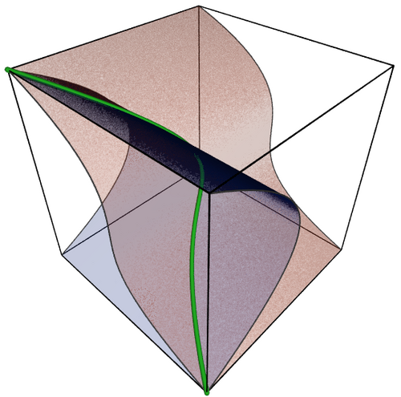

Kurva ruang hijau yang berpilin pada dua permukaan tembus pandang di dalam kotak tiga dimensi

*Kurva kubik terpilin. Claudio Rocchini, [CC BY 3.0](https://creativecommons.org/licenses/by/3.0/). Sumber kuliah memberi label sebaris CC BY-SA 3.0, sedangkan metadata Commons yang dibekukan menyediakan opsi CC BY 3.0 yang digunakan untuk komponen ini.*

Misalkan

$$C\subset\mathbb A_K^3$$

adalah *kurva kubik terpilin*, yaitu citra pemetaan monomial

$$t\longmapsto(t,t^2,t^3).$$

Kurva ini isomorfik dengan garis afin dan, khususnya, mulus. Menurut Teorema 19.1, ideal yang mendeskripsikannya ialah

$$\begin{aligned}
\mathfrak a
&=(Y-X^2,Z-X^3,Y^3-Z^2,Z-XY)\\
&=(Y-X^2,Z-X^3).
\end{aligned}$$

Dua pembangkit ideal terakhir berlebih, sebab keduanya dapat dinyatakan melalui dua pembangkit lainnya. Jadi

$$C=V(Y-X^2,Z-X^3).$$

Citra $C$ di bawah tiga proyeksi yang berbeda adalah

$$C_1=V(Z^2-Y^3),\qquad
C_2=V(Z-X^3),\qquad
C_3=V(Y-X^2).$$

Kurva $C_2$ dan $C_3$ isomorfik dengan garis afin, sebagai grafik suatu pemetaan, sedangkan $C_1$ adalah parabola Neil yang singular.

### Contoh: kurva monomial dengan eksponen 3, 4, dan 5

Misalkan $C$ kurva monomial yang diberikan oleh

$$t\longmapsto(t^3,t^4,t^5)=(x,y,z).$$

Untuk masing-masing dari ketiga variabel, menurut Teorema 19.1 kita harus menentukan pangkat yang, setelah pangkat-pangkat $t$ disubstitusikan, juga dapat dinyatakan sebagai monomial dalam dua variabel lainnya.

Pertama-tama, persamaan-persamaan yang hanya melibatkan dua variabel adalah

$$Y^3=X^4,\qquad Z^3=X^5,\qquad Z^4=Y^5.$$

Seperti dalam kasus bidang, untuk setiap pasangan variabel hanya mungkin ada satu relasi dasar.

Dalam relasi yang melibatkan ketiga variabel, salah satu variabel muncul sendiri pada satu sisi. Mulailah dengan $X$. Pangkat $X$ dan $X^2$ belum dapat dinyatakan melalui variabel lain, tetapi

$$X^3=T^9=YZ.$$

Tidak mungkin ada kombinasi lain yang bebas dari relasi ini. Secara umum, suatu penyajian ganda

$$X^k=Y^iZ^j=Y^aZ^b$$

menghasilkan relasi antara pangkat $Y$ dan pangkat $Z$, setelah pangkat yang lebih kecil dicoret. Karena semua relasi yang hanya melibatkan dua variabel sudah dicantumkan, setiap pangkat $X$ menghasilkan paling banyak satu relasi baru.

Kita sudah selesai untuk relasi dengan $X$ sendirian. Memang, jika

$$X^k=Y^iZ^j,$$

maka $k\geq3$. Jika $i=0$ atau $j=0$, relasinya sudah tercantum. Jadi anggap $i,j\geq1$. Dengan persamaan $X^3=YZ$, eksponen-eksponen dalam persamaan itu dapat diperkecil: kurangi eksponen $X$ sebesar $3$ dan masing-masing eksponen $Y$ dan $Z$ sebesar $1$.

Untuk $Y$ kita langsung memperoleh

$$Y^2=ZX,$$

yang kembali mereduksi semua persamaan lainnya. Untuk $Z$ kita memperoleh

$$Z^2=X^2Y$$

dan

$$Z^3=XY^3.$$

Tidak ada monomial yang lebih kecil dalam $X$ dan $Y$ yang dapat dinyatakan sebagai pangkat $Z$. Karena itu setiap relasi lain dapat dikembalikan pada salah satu relasi sebelumnya.

Secara keseluruhan, kurva $C$ mempunyai penyajian

$$C=V(Y^3-X^4,\ Z^3-X^5,\ Z^4-Y^5,\ X^3-YZ,\ Y^2-XZ,\ Z^2-X^2Y,\ Z^3-XY^3).$$

**Catatan edisi:** dalam daftar terakhir ini sumber memasukkan `\mathdisplaybruch X^3-YZ`, yaitu pemanggilan makro pecahan tanpa argumen berkurung. Edisi menampilkan relasi yang sudah dinyatakan dan dibuktikan tepat sebelumnya, $X^3-YZ$.

## Keintegralan

### Definisi: persamaan keintegralan

Misalkan $R$ dan $S$ gelanggang-gelanggang komutatif dan

$$R\subseteq S$$

suatu perluasan gelanggang. Untuk $x\in S$, persamaan berbentuk

$$x^n+r_{n-1}x^{n-1}+r_{n-2}x^{n-2}+\cdots+r_1x+r_0=0,$$

dengan $r_i\in R$ untuk $i=0,\ldots,n-1$, disebut *persamaan keintegralan* untuk $x$.

### Definisi: unsur integral

Misalkan $R\subseteq S$ suatu perluasan gelanggang komutatif. Unsur $x\in S$ disebut *integral atas $R$* jika $x$ memenuhi suatu persamaan keintegralan dengan koefisien dalam $R$.

### Definisi: penutupan integral

Misalkan $R\subseteq S$ suatu perluasan gelanggang komutatif. Himpunan semua unsur $x\in S$ yang integral atas $R$ disebut *penutupan integral* $R$ di dalam $S$.

### Definisi: perluasan integral

Misalkan $R\subseteq S$ suatu perluasan gelanggang komutatif. Gelanggang $S$ disebut *integral atas $R$*, dan $R\subseteq S$ disebut *perluasan gelanggang integral*, jika setiap $x\in S$ integral atas $R$.

Gelanggang $S$ integral atas $R$ jika dan hanya jika penutupan integral $R$ di dalam $S$ sama dengan $S$.

### Lema: karakterisasi unsur integral

Misalkan $R\subseteq S$ suatu perluasan gelanggang komutatif. Untuk suatu unsur $x\in S$, pernyataan-pernyataan berikut ekuivalen.

1. Unsur $x$ integral atas $R$.
2. Terdapat subaljabar-$R$ $T$ dari $S$ yang memuat $x$ dan dibangkitkan secara hingga sebagai modul-$R$.
3. Terdapat submodul-$R$ $M$ dari $S$ yang dibangkitkan secara hingga, memuat suatu unsur bukan pembagi nol di $S$, dan memenuhi $xM\subseteq M$.

#### Bukti

**(1) $\Rightarrow$ (2).** Tinjau subaljabar-$R$ dari $S$ yang dibangkitkan oleh pangkat-pangkat $x$,

$$R[x].$$

Subaljabar ini terdiri atas semua ekspresi polinomial dalam $x$ dengan koefisien di $R$. Dari suatu persamaan keintegralan

$$x^n+r_{n-1}x^{n-1}+r_{n-2}x^{n-2}+\cdots+r_1x+r_0=0$$

diperoleh

$$x^n=-r_{n-1}x^{n-1}-r_{n-2}x^{n-2}-\cdots-r_1x-r_0.$$

Jadi $x^n$ dapat dinyatakan sebagai ekspresi polinomial berderajat lebih kecil. Dengan mengalikan persamaan terakhir ini dengan $x^i$, setiap pangkat $x$ dengan eksponen sekurang-kurangnya $n$ dapat diganti oleh ekspresi polinomial berderajat lebih kecil. Akhirnya semua pangkat tersebut dapat dinyatakan dengan derajat paling besar $n-1$. Dengan demikian

$$R[x]=R+Rx+Rx^2+\cdots+Rx^{n-2}+Rx^{n-1},$$

dan $x^0=1,x,x^2,\ldots,x^{n-1}$ merupakan sistem pembangkit berhingga untuk modul-$R$ $T=R[x]$.

**(2) $\Rightarrow$ (3).** Misalkan

$$x\in T\subseteq S,$$

dengan $T$ subaljabar-$R$ yang dibangkitkan secara hingga sebagai modul-$R$. Maka $xT\subseteq T$, dan $T$ memuat unsur bukan pembagi nol $1$.

**(3) $\Rightarrow$ (1).** Misalkan $M\subseteq S$ submodul-$R$ yang dibangkitkan secara hingga dan memenuhi $xM\subseteq M$, lalu pilih pembangkit $y_1,\ldots,y_n$ bagi $M$. Untuk setiap $i$, unsur $xy_i$ merupakan kombinasi linear-$R$ dari $y_j$, sehingga

$$xy_i=\sum_{j=1}^n r_{ij}y_j,
\qquad r_{ij}\in R.$$

Dalam bentuk matriks,

$$x
\begin{pmatrix}
y_1\\y_2\\\vdots\\y_n
\end{pmatrix}
=
\begin{pmatrix}
r_{1,1}&r_{1,2}&\cdots&r_{1,n}\\
r_{2,1}&r_{2,2}&\cdots&r_{2,n}\\
\vdots&\vdots&\ddots&\vdots\\
r_{n,1}&r_{n,2}&\cdots&r_{n,n}
\end{pmatrix}
\begin{pmatrix}
y_1\\y_2\\\vdots\\y_n
\end{pmatrix}.$$

Jadi

$$0=
\underbrace{
\begin{pmatrix}
x-r_{1,1}&-r_{1,2}&\cdots&-r_{1,n}\\
-r_{2,1}&x-r_{2,2}&\cdots&-r_{2,n}\\
\vdots&\vdots&\ddots&\vdots\\
-r_{n,1}&-r_{n,2}&\cdots&x-r_{n,n}
\end{pmatrix}}_{A}
\begin{pmatrix}
y_1\\y_2\\\vdots\\y_n
\end{pmatrix}.$$

Entri-entri matriks $A$ berada di $S$. Jika $A^{\operatorname{adj}}$ adalah matriks adjugat (adjoin klasik) dari $A$, maka

$$A^{\operatorname{adj}}Ay=0,$$

dengan $y=(y_1,\ldots,y_n)^{\mathsf T}$. Menurut identitas adjugat,

$$A^{\operatorname{adj}}A=(\det A)I_n,$$

sehingga

$$((\det A)I_n)y=0.$$

Jadi $(\det A)y_j=0$ untuk setiap $j$, dan karena itu

$$(\det A)z=0$$

untuk setiap $z\in M$. Menurut asumsi, $M$ memuat suatu unsur bukan pembagi nol di $S$; akibatnya $\det A=0$. Akan tetapi, determinan ini merupakan ekspresi polinomial monik dalam $x$ berderajat $n$. Jadi $x$ memenuhi suatu persamaan keintegralan.

### Korolari: penutupan integral merupakan subaljabar

Misalkan $R\subseteq S$ suatu perluasan gelanggang komutatif. Penutupan integral $R$ di dalam $S$ merupakan subaljabar-$R$ dari $S$.

#### Bukti

Persamaan keintegralan $X-r=0$, untuk $r\in R$, menunjukkan bahwa setiap unsur $R$ integral atas $R$. Misalkan $x_1,x_2\in S$ integral atas $R$. Menurut karakterisasi keintegralan, terdapat subaljabar-subaljabar-$R$

$$T_1,T_2\subseteq S$$

dengan $x_1\in T_1$ dan $x_2\in T_2$ yang masing-masing dibangkitkan secara hingga sebagai modul-$R$. Misalkan $y_1,\ldots,y_n$ sistem pembangkit-$R$ bagi $T_1$, dan $z_1,\ldots,z_m$ sistem pembangkit-$R$ bagi $T_2$. Kita dapat menganggap $y_1=z_1=1$.

Tinjau modul-$R$ yang dibangkitkan secara hingga

$$T=T_1T_2
=\left\langle y_iz_j\mathrel{\Big|}
i=1,\ldots,n,\ j=1,\ldots,m\right\rangle.$$

Modul ini jelas memuat $x_1+x_2$, $x_1x_2$, dan $1$. Modul-$R$ $T$ juga merupakan aljabar-$R$. Memang, untuk dua unsur sebarang,

$$\left(\sum r_{ij}y_iz_j\right)
\left(\sum s_{k\ell}y_kz_\ell\right)
=\sum r_{ij}s_{k\ell}y_iy_kz_jz_\ell,$$

dan $y_iy_k\in T_1$ serta $z_jz_\ell\in T_2$, sehingga kombinasi linear ini berada dalam $T$.

Karena itu jumlah dan hasil kali dua unsur integral kembali integral. Jadi penutupan integral adalah subgelanggang $S$ yang memuat $R$, yaitu suatu subaljabar-$R$.

### Definisi: tertutup secara integral

Misalkan $R\subseteq S$ suatu perluasan gelanggang komutatif. Gelanggang $R$ disebut *tertutup secara integral di dalam $S$* jika penutupan integral $R$ di dalam $S$ sama dengan $R$.

**Provenans edisi.** Terjemahan dan produksi pembaca: OpenAI Codex gpt-5.6-sol, Ultra. Sumber, pengarang, dan lisensi komponen dipertahankan seperti dinyatakan dalam metadata dan berkas hak edisi.

# Lembar Kerja 19

## Soal latihan

### Soal 19.1

Tentukan pembangkit ideal untuk kurva monomial yang diberikan oleh

$$\begin{aligned}
\mathbb A_K^1&\longrightarrow\mathbb A_K^3,\\
t&\longmapsto(t^2,t^3,t^4).
\end{aligned}$$

### Soal 19.2

Tentukan pembangkit ideal untuk kurva monomial yang diberikan oleh

$$\begin{aligned}
\mathbb A_K^1&\longrightarrow\mathbb A_K^3,\\
t&\longmapsto(t^4,t^5,t^6).
\end{aligned}$$

### Soal 19.3

Misalkan

$$R\subseteq S$$

suatu perluasan gelanggang integral antara domain-domain integral, dan misalkan $F\subseteq R$ suatu sistem multiplikatif. Tunjukkan bahwa perluasan hasil pelokalan

$$R_F\subseteq S_F$$

juga integral.

### Soal 19.4 ★

Misalkan $R$ dan $S$ domain-domain integral dan

$$R\subseteq S$$

suatu perluasan gelanggang integral. Misalkan $f\in R$ merupakan unsur yang menjadi satuan di $S$. Tunjukkan bahwa $f$ sudah merupakan satuan di $R$.

### Soal 19.5

Misalkan $R\subseteq S$ suatu perluasan gelanggang integral dan $f\in R$. Tunjukkan: jika $f$, dipandang sebagai unsur $S$, merupakan satuan, maka $f$ merupakan satuan di $R$.

### Soal 19.6

Berikan contoh suatu perluasan gelanggang integral

$$R\subseteq S$$

yang memiliki unsur bukan pembagi nol $f\in R$ yang menjadi pembagi nol di $S$.

### Soal 19.7

Misalkan

$$P=X^2-3X+7$$

dan

$$Q=Y^3-Y^2+4Y-5.$$

Jelaskan mengapa perluasan gelanggang

$$\mathbb Z\subseteq\mathbb Z[X,Y]/(P,Q)$$

integral, lalu temukan persamaan keintegralan untuk $x+y$ dan untuk $xy$. Huruf kecil menyatakan kelas sisa dari variabel-variabelnya.

### Soal 19.8

Misalkan $R\subseteq S$ suatu perluasan gelanggang antara gelanggang-gelanggang komutatif hingga $R$ dan $S$. Tunjukkan bahwa perluasan gelanggang ini integral.

### Soal 19.9

Misalkan $R$ suatu gelanggang komutatif dan

$$S=R[X_1,\ldots,X_n]/\mathfrak a$$

suatu aljabar-$R$ yang dibangkitkan secara hingga sebagai aljabar dan integral atas $R$. Tunjukkan bahwa $S$ merupakan modul-$R$ yang dibangkitkan secara hingga.

### Soal 19.10

Misalkan

$$\varphi:R\longrightarrow S$$

suatu homomorfisme gelanggang antara gelanggang-gelanggang komutatif, dan andaikan $\varphi$ integral. Misalkan pula $R\longrightarrow R'$ suatu homomorfisme gelanggang. Tunjukkan bahwa homomorfisme hasil perubahan dasar

$$\begin{aligned}
\varphi':R'&\longrightarrow R'\otimes_R S,\\
f&\longmapsto f\otimes1
\end{aligned}$$

juga integral.

### Soal 19.11

Untuk setiap lapangan $K$ dengan karakteristik $\ne2$, tunjukkan bahwa homomorfisme gelanggang

$$\begin{aligned}
K[X,Y]/(X^2+Y^2-1)&\longrightarrow
K[U,V]/(U^2+V^2-1),\\
(X,Y)&\longmapsto(U^2-V^2,2UV)
\end{aligned}$$

merupakan homomorfisme integral.

### Soal 19.12 ★

Misalkan $K$ suatu lapangan dan diberikan suatu perluasan gelanggang yang hingga sebagai modul-$K[X]$, berbentuk

$$K[X]\subseteq
K[X][Y]/\left(Y^n+P_{n-1}(X)Y^{n-1}+\cdots+P_2(X)Y^2+P_1(X)Y+P_0(X)\right)
=R,$$

dengan $P_i(X)\in K[X]$, dan misalkan gelanggang perluasan $R$ merupakan domain integral. Pilih $k$ sedemikian sehingga derajat $P_i$ paling besar $k(n-i)$ untuk semua

$$i=0,1,\ldots,n-1.$$

Tunjukkan bahwa $YX^{-k}$ memenuhi persamaan keintegralan berderajat $n$ atas $K[X^{-1}]$, dan bahwa aljabar perluasan

$$K[X^{-1},YX^{-k}]$$

mempunyai lapangan pecahan yang sama dengan $R$.

### Soal 19.13

1. Misalkan $R$ suatu domain integral. Tunjukkan bahwa $R$ tertutup secara integral di dalam gelanggang polinomial $R[X]$.
2. Berikan contoh suatu gelanggang komutatif $R$ yang tidak tertutup secara integral di dalam gelanggang polinomialnya.

## Soal untuk dikumpulkan

### Soal 19.14 (4 poin)

Misalkan $M\subseteq\mathbb N$ submonoid numerik yang dibangkitkan oleh $3,5,7$. Tentukan suatu penyajian gelanggang monoid yang terkait sebagai gelanggang faktor.

### Soal 19.15 (3 poin)

Misalkan $R,S,T$ gelanggang-gelanggang komutatif dan

$$\varphi:R\longrightarrow S,
\qquad
\psi:S\longrightarrow T$$

homomorfisme gelanggang sedemikian sehingga $S$ integral atas $R$ dan $T$ integral atas $S$. Tunjukkan bahwa $T$ juga integral atas $R$.

*Petunjuk sumber:* Bandingkan Soal 10.26.

**Provenans edisi.** Terjemahan dan produksi pembaca: OpenAI Codex gpt-5.6-sol, Ultra. Sumber, pengarang, dan lisensi komponen dipertahankan seperti dinyatakan dalam metadata dan berkas hak edisi.

# Solusi Publik Lembar Kerja 19

Pada batas revisi yang dibekukan, sumber hanya menyediakan solusi publik untuk Soal 19.4 dan 19.12. Tidak ada solusi tambahan yang dibuat untuk edisi ini.

## Solusi Soal 19.4

Misalkan $s\in S$ invers dari $f$, sehingga $fs=1$. Karena $S$ integral atas $R$, terdapat suatu persamaan keintegralan untuk $s$, katakanlah

$$s^n+a_{n-1}s^{n-1}+\cdots+a_1s+a_0=0,
\qquad a_i\in R.$$

Kita kalikan persamaan ini dengan $f^n$ dan memperoleh

$$(fs)^n+a_{n-1}f(fs)^{n-1}+\cdots+a_1f^{n-1}(fs)+a_0f^n=0,$$

atau, karena $fs=1$,

$$1+a_{n-1}f+\cdots+a_1f^{n-1}+a_0f^n=0.$$

Dengan memfaktorkan $f$, kita memperoleh

$$1+f\left(a_{n-1}+\cdots+a_1f^{n-2}+a_0f^{n-1}\right)=0,$$

dan dengan demikian

$$f\left(-a_{n-1}-\cdots-a_1f^{n-2}-a_0f^{n-1}\right)=1.$$

Ekspresi di dalam tanda kurung berada di $R$. Jadi $f$ juga mempunyai invers di $R$.

Kembali ke Soal 19.4.

## Solusi Soal 19.12

Kita kalikan persamaan keintegralan yang diberikan dengan $X^{-kn}$. Di dalam lapangan pecahan $Q$ dari gelanggang faktor yang mendefinisikan $R$, kita memperoleh

$$Y^nX^{-kn}+\sum_{i=0}^{n-1}P_iY^iX^{-kn}=0.$$

Di sini

$$Y^nX^{-kn}=(YX^{-k})^n$$

dan

$$\begin{aligned}
P_iY^iX^{-kn}
&=P_iY^iX^{-ki}X^{-k(n-i)}\\
&=(YX^{-k})^iP_iX^{-k(n-i)}.
\end{aligned}$$

Syarat pada $k$ memastikan bahwa

$$P_iX^{-k(n-i)}$$

merupakan polinom dalam $X^{-1}$. Jadi persamaan yang dihasilkan merupakan persamaan keintegralan monik berderajat $n$ untuk $YX^{-k}$ atas $K[X^{-1}]$.

Karena $R$ merupakan domain integral, polinom pendefinisi asal tak tereduksi. Setelah perubahan variabel yang dapat dibalik di $K(X)$, polinom monik hasil di atas tak tereduksi di $K[X^{-1}][Z]$, dengan $Z$ suatu variabel formal yang kemudian dipetakan ke $YX^{-k}$.

**Catatan edisi:** sumber menyebut persamaan itu tak tereduksi “di $K[X^{-1},YX^{-k}]$”. Di dalam aljabar faktor tersebut, relasinya bernilai nol; gelanggang polinomial yang tepat untuk menyatakan ketaktereduksian adalah $K[X^{-1}][Z]$. Edisi memperjelas gelanggang tempat polinom itu dipandang dan variabel formalnya; klaim ini tidak diperlukan untuk dua kesimpulan yang diminta.

Kita mempunyai

$$K[X^{-1}][YX^{-k}]\subseteq Q.$$

Lapangan pecahan ruas kiri memuat $X$ sebagai invers dari $X^{-1}$, lalu memuat

$$Y=(YX^{-k})X^k.$$

Karena itu lapangan pecahannya memuat $K(X,Y)=Q$. Inklusi sebaliknya sudah jelas dari inklusi di atas, sehingga kedua lapangan pecahan sama.

Kembali ke Soal 19.12.

**Provenans edisi.** Terjemahan dan produksi pembaca: OpenAI Codex gpt-5.6-sol, Ultra. Sumber, pengarang, dan lisensi komponen dipertahankan seperti dinyatakan dalam metadata dan berkas hak edisi.

# Kuliah 20: Gelanggang Normal dan Normalisasi

## Gelanggang normal dan normalisasi

### Definisi: domain integral normal

Suatu domain integral disebut *normal* jika tertutup secara integral di dalam lapangan pecahannya.

Contoh penting gelanggang normal diberikan oleh domain faktorisasi tunggal.

### Teorema: domain faktorisasi tunggal bersifat normal

Misalkan $R$ suatu domain faktorisasi tunggal. Maka $R$ normal.

#### Bukti

Misalkan

$$K=Q(R)$$

lapangan pecahan $R$, dan misalkan $q\in K$ memenuhi persamaan keintegralan

$$q^n+r_{n-1}q^{n-1}+r_{n-2}q^{n-2}+\cdots+r_1q+r_0=0,
\qquad r_i\in R.$$

Tuliskan

$$q=\frac ab,
\qquad a,b\in R,
\qquad b\ne0,$$

dalam bentuk yang telah disederhanakan, sehingga $a$ dan $b$ tidak mempunyai pembagi prima bersama. Kita harus menunjukkan bahwa $b$ satuan di $R$, sebab dalam hal itu

$$q=ab^{-1}\in R.$$

Kalikan persamaan keintegralan di atas dengan $b^n$. Di dalam $R$ diperoleh

$$a^n+(r_{n-1}b)a^{n-1}+(r_{n-2}b^2)a^{n-2}
+\cdots+(r_1b^{n-1})a+r_0b^n=0.$$

Jika $b$ bukan satuan, terdapat pembagi prima $p$ dari $b$. Unsur $p$ membagi semua suku

$$(r_{n-i}b^i)a^{n-i},
\qquad i\geq1,$$

dan karena itu juga membagi suku pertama $a^n$. Maka $p$ membagi $a$, yang bertentangan dengan asumsi bahwa $a$ dan $b$ tidak mempunyai pembagi prima bersama.

### Lema: pelokalan domain integral normal kembali normal

Misalkan $R$ suatu domain integral normal dan $S\subseteq R$ suatu sistem multiplikatif. Maka pelokalan $R_S$ juga normal.

#### Bukti

Lihat Soal 20.6.

### Definisi: normalisasi domain integral

Misalkan $R$ suatu domain integral dan $Q(R)$ lapangan pecahannya. Penutupan integral $R$ di dalam $Q(R)$ disebut *normalisasi* $R$.

Menurut Korolari 19.10, normalisasi merupakan subgelanggang lapangan pecahan. Suatu fakta tak trivial menyatakan bahwa jika $R$ bertipe hingga di atas suatu lapangan, normalisasinya juga bertipe hingga.

## Normalisasi gelanggang monoid

Kita akan membahas kapan gelanggang monoid bersifat normal dan bagaimana normalisasi gelanggang monoid dapat dideskripsikan. Mula-mula kita memerlukan syarat-syarat yang menjamin bahwa gelanggang monoid di atas suatu domain integral kembali merupakan domain integral.

### Definisi: monoid bebas torsi

Suatu monoid komutatif $M$ disebut *bebas torsi* jika, untuk $m,n\in M$ dan suatu bilangan positif $r\in\mathbb N_+$, dari

$$rm=rn$$

selalu mengikuti

$$m=n.$$

### Teorema: gelanggang monoid bebas torsi merupakan domain integral

Misalkan $R$ suatu domain integral dan $M$ suatu monoid komutatif bebas torsi yang memenuhi hukum pembatalan. Maka gelanggang monoid $R[M]$ merupakan domain integral.

#### Bukti

Mula-mula,

$$M\subseteq\Gamma(M),$$

dengan $\Gamma(M)$ grup selisih $M$. Karena itu

$$R[M]\subseteq R[\Gamma(M)]$$

merupakan subgelanggang, sehingga cukup membuktikan pernyataan untuk $R[\Gamma(M)]$. Karena $M$ bebas torsi, menurut Soal 20.10 grup $\Gamma(M)$ juga bebas torsi. Jadi kita boleh menganggap bahwa $M$ sendiri merupakan grup komutatif bebas torsi.

Misalkan

$$\left(\sum_{m\in M}a_mX^m\right)
\left(\sum_{m\in M}b_mX^m\right)=0.$$

Hampir semua koefisien dalam kedua jumlah itu nol. Oleh karena itu seluruh perhitungan berlangsung di dalam suatu subgrup $U$ yang dibangkitkan secara hingga dari grup bebas torsi $M$. Menurut teorema utama tentang grup komutatif bebas torsi yang dibangkitkan secara hingga,

$$U\cong\mathbb Z^n.$$

Dengan demikian kita bahkan boleh menganggap $M=\mathbb Z^n$. Dalam hal ini $R[M]$ adalah pelokalan suatu gelanggang polinom di atas domain integral, dan karena itu merupakan domain integral.

Tanpa hukum pembatalan, gelanggang monoid di atas suatu domain integral dapat mempunyai pembagi nol.

### Contoh: pembagi nol tanpa hukum pembatalan

Misalkan $M$ suatu monoid yang memuat dua unsur berbeda $m$ dan $n$ dengan

$$m+n=n+n.$$

Tanpa hukum pembatalan, persamaan ini tidak mengakibatkan $m=n$. Di dalam gelanggang monoid di atas domain integral sebarang $R$ berlaku

$$X^m-X^n\ne0
\qquad\text{dan}\qquad
X^n\ne0,$$

tetapi

$$(X^m-X^n)X^n
=X^{m+n}-X^{n+n}
=X^{2n}-X^{2n}
=0.$$

### Definisi: normalisasi monoid

Misalkan $M$ suatu monoid komutatif bebas torsi yang memenuhi hukum pembatalan, dengan grup selisih $\Gamma(M)$. Submonoid

$$\widetilde M
=\{m\in\Gamma(M)\mid
\text{terdapat }r\in\mathbb N_+\text{ dengan }rm\in M\}$$

disebut *normalisasi* $M$.

### Teorema: normalisasi gelanggang monoid

Misalkan $M$ suatu monoid komutatif bebas torsi yang memenuhi hukum pembatalan, dengan grup selisih $\Gamma(M)$ dan normalisasi

$$M\subseteq\widetilde M\subseteq\Gamma(M).$$

Misalkan pula $R$ suatu domain integral normal. Maka normalisasi gelanggang monoid $R[M]$ ialah gelanggang monoid

$$R[\widetilde M].$$

Khususnya, gelanggang monoid dari suatu monoid normal di atas gelanggang normal juga normal.

#### Bukti

Mula-mula,

$$R[M]\subseteq R[\widetilde M]
\subseteq R[\Gamma(M)]
\subseteq Q(R)[\Gamma(M)]
\subseteq Q(R[M]).$$

Ambil $m\in\widetilde M$ dengan

$$m=n-k,
\qquad n,k\in M,$$

dan dengan

$$rm=\underbrace{m+\cdots+m}_{r\text{ kali}}\in M.$$

Maka

$$T^m=\frac{T^n}{T^k}$$

merupakan unsur lapangan pecahan, sedangkan

$$(T^m)^r\in R[M].$$

Jadi $T^m$ memenuhi suatu persamaan keintegralan murni di atas $R[M]$ dan berada dalam normalisasi $R[M]$. Dengan demikian,

$$R[\widetilde M]\subseteq R[M]^{\operatorname{norm}}.$$

**Catatan edisi:** pada dua rumus terakhir sumber mengganti gelanggang dasar $R$ dengan $K$, meskipun teorema dan seluruh argumen menetapkan $R$. Edisi ini mempertahankan $R$ secara konsisten. Sumber juga mencetak $rm=M$ pada syarat definisi; sesuai definisi $\widetilde M$, relasi yang diperlukan dan ditampilkan di sini ialah $rm\in M$.

Untuk inklusi sebaliknya, kita dapat mengganti $M$ dengan $\widetilde M$ dan karena itu membatasi diri pada kasus ketika $M$ normal. Pertama-tama dibuktikan bahwa, untuk grup komutatif bebas torsi $G$, gelanggang grup $R[G]$ normal. Hal ini mengikuti dari fakta bahwa gelanggang polinom di atas suatu domain normal kembali normal. Selanjutnya harus ditunjukkan bahwa $R[M]$ tertutup secara integral di dalam $R[\Gamma(M)]$.

Suatu unsur

$$q\in R(\Gamma(M))$$

beserta persamaan keintegralannya berada di dalam gelanggang monoid dari suatu subgrup yang dibangkitkan secara hingga

$$U\subseteq\Gamma(M).$$

Karena itu kita boleh menganggap

$$\Gamma(M)=\mathbb Z^n.$$

Pada titik ini masuk sedikit geometri konveks, yang tidak kita uraikan. Bagaimanapun, suatu submonoid normal

$$M\subseteq\mathbb Z^n$$

dapat dinyatakan sebagai irisan $\mathbb Z^n$ dengan suatu kerucut polihedral di dalam $\mathbb Q^n$ atau $\mathbb R^n$. Menurut lema Gordan, kerucut tersebut pada gilirannya merupakan irisan berhingga dari setengah ruang $H_i$. Suatu setengah ruang $H$ diberikan oleh pemetaan linear

$$p:V=\mathbb R^n\longrightarrow\mathbb R$$

melalui

$$H=p^{-1}(\mathbb R_+).$$

Karena itu $M$ merupakan irisan berhingga

$$M=\bigcap_{i\in I}M_i,
\qquad
M_i=p_i^{-1}(\mathbb N),$$

dengan

$$M_i\cong\mathbb N\times\mathbb Z^{n-1}.$$

Akibatnya,

$$R[M]=\bigcap_{i\in I}R[M_i]$$

normal menurut Soal 20.7, sebab setiap

$$R[M_i]\cong R[\mathbb N\times\mathbb Z^{n-1}]$$

normal.

### Contoh: payung Whitney

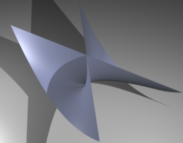

Permukaan abu-abu kebiruan berbentuk payung Whitney yang berpotongan sendiri di ruang tiga dimensi

*Payung Whitney. Claudio Rocchini, [CC BY 2.5](https://creativecommons.org/licenses/by/2.5/). Label lisensi sebaris pada sumber berbeda dari opsi yang tersedia pada metadata Commons; rincian pembekuan hak berada pada kredit media Unit 20.*

Tinjau permukaan aljabar yang diberikan oleh persamaan

$$X^2Z=Y^2.$$

Kita akan memahaminya sebagai permukaan yang terkait dengan suatu gelanggang monoid. Tetapkan

$$M=\langle(1,0),(1,1),(0,2)\rangle\subseteq\mathbb N^2.$$

Karena

$$(1,1)-(1,0)=(0,1),$$

grup selisihnya ialah $\mathbb Z^2$. Selain itu,

$$2(0,1)=(0,2)\in M,$$

sehingga $\mathbb N^2$ merupakan normalisasi $M$. Ketiga pembangkit memberikan homomorfisme monoid surjektif

$$\begin{aligned}
\mathbb N^3&\longrightarrow M,\\
e_i&\longmapsto m_i.
\end{aligned}$$

Secara geometris, pemetaan monomial

$$\mathbb N^3\longrightarrow M\subseteq\mathbb N^2$$

bersesuaian dengan pemetaan

$$\begin{aligned}
\mathbb A_K^2&\longrightarrow
K\!-!\operatorname{Spek}(K[M])\hookrightarrow\mathbb A_K^3,\\
(s,t)&\longmapsto(s,st,t^2).
\end{aligned}$$

Di bawah homomorfisme monoid tersebut,

$$2e_1+e_3\longmapsto(2,2)
\qquad\text{dan}\qquad
2e_2\longmapsto(2,2).$$

Hal ini menghasilkan persamaan

$$X^2Z=Y^2,$$

yang tentu juga dapat dibaca langsung dari parametrisasi.

**Catatan edisi:** sumber mencetak bahwa kedua unsur itu dipetakan ke $(1,1)$. Dari pembangkit yang ditampilkan, keduanya dipetakan ke $(2,2)$. Edisi memperbaiki koordinat ini secara transparan; relasi $X^2Z=Y^2$ tidak berubah.

Persamaan pendefinisi juga dapat ditulis sebagai

$$Z=\left(\frac YX\right)^2.$$

Jadi, berangkat dari $K[X,Y]$, kita mengadjoin kuadrat dari $Y/X$.

### Contoh: kerucut standar monomial

Tinjau submonoid

$$M=\langle(1,0),(-1,2),(0,1)\rangle\subseteq\mathbb Z^2.$$

Untuk gelanggang monoid yang terkait berlaku

$$K[M]\cong K[X,Y,Z]/(Z^2-XY).$$

Kita klaim bahwa monoid tersebut normal, yakni sama dengan normalisasinya. Dua pembangkit $(1,0)$ dan $(-1,2)$ masing-masing menentukan sebuah garis di $\mathbb R^2$, dan monoid itu terdiri atas semua titik kisi di dalam kerucut yang ditentukan oleh kedua garis tersebut. Titik-titik kisi dalam kerucut ini diberikan oleh dua syarat

$$\{(s,t)\in\mathbb Z^2\mid t\geq0\text{ dan }t\geq-2s\}.$$

Suatu titik di dalam himpunan ini dengan $s\geq0$ jelas berada di $M$. Sekarang misalkan $(s,t)$ suatu titik di dalam himpunan tersebut dengan $s<0$. Berdasarkan syarat linear kedua, kita dapat menulis

$$(s,t)=-s(-1,2)+(t+2s)(0,1),$$

dan titik ini berada di $M$ karena $t+2s\geq0$.

Dengan kedua garis tersebut, $M$ juga langsung dapat dideskripsikan sebagai

$$M=M_1\cap M_2,$$

dengan

$$M_1=\{(s,t)\in\mathbb Z^2\mid t\geq0\}
\cong\mathbb Z\times\mathbb N$$

dan

$$M_2=\{(s,t)\in\mathbb Z^2\mid t\geq-2s\}
\cong\mathbb Z\times\mathbb N.$$

Identifikasi kedua berasal dari basis-$\mathbb Z$ $(-1,2),(0,1)$. Dari deskripsi eksplisit ini mengikuti bahwa gelanggang monoid yang terkait normal.

## Kurva monomial dan normalisasi

Kelak kita akan melihat bahwa suatu kurva aljabar normal jika dan hanya jika kurva itu nonsingular. Dalam kasus kurva monomial, normalisasinya dapat dideskripsikan dengan mudah.

### Teorema: normalisasi kurva monomial

Misalkan

$$M\subseteq\mathbb N$$

suatu submonoid yang dibangkitkan oleh bilangan-bilangan saling prima $e_1,\ldots,e_n$, dan misalkan

$$K[M]\subseteq K[T]$$

perluasan gelanggang monoid yang terkait. Maka $K[T]$ merupakan normalisasi $K[M]$.

Dengan kata lain, pemetaan monomial

$$\mathbb A_K^1\longrightarrow K\!-!\operatorname{Spek}(K[M])$$

merupakan suatu normalisasi.

#### Bukti

Kita mempunyai

$$K[M]=K[T^{e_1},\ldots,T^{e_n}]\subseteq K[T].$$

Karena eksponen-eksponennya saling prima, eksponen-eksponen itu membangkitkan $1$. Jika dipandang secara multiplikatif, ini berarti bahwa terdapat suatu monomial dalam pangkat-pangkat tersebut, dengan eksponen negatif juga diizinkan, yang sama dengan $T$. Jadi $T$ merupakan hasil bagi unsur-unsur $K[M]$, dan kedua lapangan pecahannya sama.

Di sisi lain, $T$ memenuhi persamaan keintegralan atas $K[M]$, misalnya

$$X^{e_1}-T^{e_1}=0.$$

Di sini $X$ adalah variabel polinom, sedangkan $T^{e_1}$ merupakan koefisien di $K[M]$. Karena $K[T]$ normal—bahkan merupakan domain faktorisasi tunggal, sebab ia domain ideal utama—maka $K[T]$ adalah normalisasi $K[M]$.

**Catatan edisi:** sumber memakai simbol $T$ untuk variabel polinom sekaligus untuk unsur yang diuji, lalu menambahkan keterangan “dibaca dengan benar”. Edisi membedakan keduanya dengan menamai variabel polinom $X$; isi matematis tidak berubah.

Dengan demikian kurva-kurva monomial menyediakan banyak contoh ketika normalisasi merupakan bijeksi pada tingkat spektrum-$K$. Pemetaan itu juga merupakan homeomorfisme untuk topologi Zariski, yang pada kasus kurva memang sangat sederhana. Namun, keliru jika kedua kurva dianggap identik. Jika $e_i\ne1$ untuk semua $i$, normalisasi pada tingkat gelanggang bukanlah bijeksi. Dalam geometri aljabar kita tidak boleh hanya memandang wujud himpunan nol secara himpunan atau topologis; gelanggang dan persamaan yang mendasarinya tidak boleh dilupakan. Perbedaannya juga tampak dalam situasi terbenam, ketika parabola Neil mempunyai sebuah cusp.

Normalisasi memberi interpretasi baru bagi derajat singularitas kurva monomial.

### Lema: derajat singularitas sebagai dimensi normalisasi

Misalkan $M\subseteq\mathbb N$ suatu monoid numerik yang ditentukan oleh pembangkit-pembangkit saling prima. Misalkan

$$R=K[M]$$

gelanggang monoid yang terkait dan

$$R^{\operatorname{norm}}=K[T]$$

normalisasinya. Maka

$$\delta(M)=\dim_K\bigl(R^{\operatorname{norm}}/R\bigr).$$

#### Bukti

Normalisasi mempunyai basis-$K$

$$\{T^m\mid m\in\mathbb N\},$$

sedangkan gelanggang monoid $K[M]$ mempunyai basis-$K$

$$\{T^m\mid m\in M\}.$$

Karena itu ruang faktor

$$K[T]/K[M]$$

mempunyai basis-$K$

$$\{T^m\mid m\in\mathbb N\setminus M\}.$$

Dimensi ruang faktor adalah banyak unsur suatu basis, yaitu banyak celah $M$. Jumlah ini persis derajat singularitas $M$.

**Provenans edisi.** Terjemahan dan produksi pembaca: OpenAI Codex gpt-5.6-sol, Ultra. Sumber, pengarang, dan lisensi komponen dipertahankan seperti dinyatakan dalam metadata dan berkas hak edisi.

# Lembar Kerja 20

## Soal latihan

Empat soal berikut harus dibuktikan dengan dua cara: secara langsung dan dengan menggunakan sifat normal $\mathbb Z$.

### Soal 20.1 ★

Tunjukkan bahwa $\sqrt{2}$ merupakan bilangan irasional.

### Soal 20.2

Misalkan $p$ suatu bilangan prima. Dengan menggunakan ketunggalan faktorisasi prima bilangan asli, tunjukkan bahwa bilangan real $\sqrt p$ irasional.

### Soal 20.3 ★

Buktikan dengan menggunakan ketunggalan faktorisasi prima di $\mathbb Z$ bahwa $9^{1/3}$ irasional.

### Soal 20.4 ★

Misalkan

$$n=p_1^{\alpha_1}\cdots p_r^{\alpha_r}$$

faktorisasi prima kanonik dari bilangan asli $n$. Misalkan $k$ suatu bilangan asli positif, dan andaikan tidak semua eksponen $\alpha_i$ merupakan kelipatan $k$. Tunjukkan bahwa bilangan real

$$n^{1/k}$$

irasional.

### Soal 20.5 ★

Misalkan $R$ suatu domain integral normal dan $f\in R$ dengan $f\ne0$. Tunjukkan bahwa pelokalan $R_f$ juga normal.

### Soal 20.6

Misalkan $R$ suatu domain integral normal dan $S\subseteq R$ suatu sistem multiplikatif. Tunjukkan bahwa pelokalan $R_S$ juga normal.

### Soal 20.7

Misalkan $K$ suatu lapangan dan $(R_i\subseteq K)_{i\in I}$ suatu keluarga subgelanggang normal. Tunjukkan bahwa irisan

$$\bigcap_{i\in I}R_i$$

juga normal.

### Soal 20.8

Misalkan $R$ suatu domain integral. Tunjukkan bahwa $R$ normal jika dan hanya jika $R$ bertepatan dengan normalisasinya.

### Soal 20.9

Misalkan $R$ suatu domain integral. Andaikan normalisasi $R$ sama dengan lapangan pecahannya $Q(R)$. Tunjukkan bahwa $R$ sendiri sudah merupakan lapangan.

### Soal 20.10

Misalkan $M$ suatu monoid bebas torsi. Tunjukkan bahwa grup selisih $\Gamma(M)$ juga bebas torsi.

### Soal 20.11

Misalkan $M$ suatu grup komutatif. Tunjukkan bahwa sifat bebas torsi dari $M$ ekuivalen dengan sifat berikut: jika $m\in M$ dan

$$rm=0$$

untuk suatu bilangan asli positif $r\in\mathbb N$, maka selalu $m=0$. Tunjukkan pula bahwa ekuivalensi ini tidak harus berlaku untuk suatu monoid.

### Soal 20.12 ★

Tinjau lokus nol

$$C=V(Y^2-X^4)\subseteq\mathbb A_{\mathbb C}^2.$$

1. Apakah $C$ tak tereduksi?
2. Dapatkah gelanggang koordinat $\mathbb C[X,Y]/(Y^2-X^4)$ diperoleh sebagai gelanggang monoid?
3. Dapatkah gelanggang koordinat $\mathbb C[X,Y]/(Y^2-X^4)$ diperoleh sebagai gelanggang monoid dari suatu submonoid

   $$M\subseteq\mathbb N\times\mathbb Z/(2)?$$

### Soal 20.13 ★

Misalkan $n\in\mathbb N_+$ dan

$$M\subseteq\mathbb N\times\mathbb Z/(n)$$

suatu submonoid. Tunjukkan bahwa $m\in M$ merupakan satuan jika dan hanya jika $m$, ketika dipandang sebagai unsur $\mathbb N\times\mathbb Z/(n)$, merupakan satuan.

### Soal 20.14 ★

Misalkan $n\in\mathbb N_+$. Tunjukkan bahwa spektrum-$\mathbb C$ dari monoid komutatif

$$M=\mathbb N\times\mathbb Z/(n)$$

terdiri atas $n$ komponen tak tereduksi yang semuanya isomorfik dengan garis afin $\mathbb A_{\mathbb C}^1$.

### Soal 20.15

Misalkan $R$ suatu domain integral dengan normalisasi $R^{\operatorname{norm}}$. Tunjukkan bahwa

$$\mathfrak f=
\left\{g\in R\mathrel{\Big|}gR^{\operatorname{norm}}\subseteq R\right\}$$

merupakan suatu ideal di $R$.

### Soal 20.16

Misalkan $M\subseteq\mathbb N$ suatu monoid numerik yang dibangkitkan oleh bilangan-bilangan asli saling prima. Tunjukkan bahwa ideal konduktor dari gelanggang monoid terkait $K[M]$ memenuhi

$$\mathfrak f=(M_{\geq f}),$$

dengan $f$ menyatakan bilangan konduktor monoid tersebut.

### Soal 20.17 ★

Misalkan $M\subseteq\mathbb N$ suatu monoid numerik. Tunjukkan bahwa derajat singularitas $M$ sama dengan masing-masing dari tiga bilangan berikut.

1. Panjang maksimum suatu rantai monoid

   $$M=M_0\subset M_1\subset M_2\subset\cdots\subset M_n=\mathbb N.$$
2. Panjang maksimum suatu rantai aljabar-$K$

   $$K[M]=R_0\subset R_1\subset R_2\subset\cdots\subset R_n=K[T].$$
3. Panjang maksimum suatu rantai—suatu bendera—subruang vektor-$K$

   $$K[M]=V_0\subset V_1\subset V_2\subset\cdots\subset V_n=K[T].$$

### Soal 20.18

Tinjau Contoh 20.11. Berapakah nilai ketiga pembangkit di bawah homomorfisme-homomorfisme monoid $\varphi_1,\varphi_2$ ke $\mathbb Z$ yang disebutkan di sana dan yang digunakan untuk mendeskripsikan monoid tersebut? Tentukan kokernel homomorfisme grup

$$\begin{aligned}
\Gamma(M)&\longrightarrow\mathbb Z^2,\\
m&\longmapsto\bigl(\varphi_1(m),\varphi_2(m)\bigr).
\end{aligned}$$

Kokernel ini disebut **grup kelas pembagi** dari gelanggang monoid tersebut.

*Catatan edisi tentang sumber:* Contoh yang dirujuk menyatakan kedua pertidaksamaan $t\geq0$ dan $t\geq-2s$, tetapi tidak memberi label atau rumus eksplisit untuk $\varphi_1,\varphi_2$. Dengan urutan kedua pertidaksamaan itu, fungsional yang dimaksud dapat disimpulkan sebagai $\varphi_1(s,t)=t$ dan $\varphi_2(s,t)=t+2s$; rumus ini merupakan inferensi editorial yang dinyatakan terbuka, bukan pernyataan tersembunyi dari sumber.

## Soal untuk dikumpulkan

### Soal 20.19 (3 poin)

Misalkan $R$ suatu domain integral normal dan

$$R\subseteq S$$

suatu perluasan gelanggang integral. Misalkan $f\in R$. Tunjukkan bahwa untuk ideal utama yang dibangkitkan oleh $f$ berlaku

$$R\cap(f)S=(f)R.$$

### Soal 20.20 (6 poin)

Misalkan $R$ suatu domain integral normal. Tunjukkan bahwa gelanggang polinomial $R[X]$ juga normal.

### Soal 20.21 (5 poin)

Misalkan $R$ suatu domain integral normal dan $a\in R$. Andaikan $a$ tidak mempunyai akar kuadrat di $R$. Tunjukkan bahwa polinom $X^2-a$ merupakan unsur prima di $R[X]$.

*Petunjuk sumber:* Gunakan lapangan pecahan $Q(R)$.

*Peringatan sumber:* Dalam konteks ini, sifat prima tidak harus ekuivalen dengan sifat tak tereduksi.

### Soal 20.22 (4 poin)

Misalkan $R$ suatu domain integral. Tunjukkan bahwa ketiga sifat berikut ekuivalen.

1. $R$ normal.
2. Untuk setiap ideal prima $\mathfrak p$, pelokalan $R_{\mathfrak p}$ normal.
3. Untuk setiap ideal maksimal $\mathfrak m$, pelokalan $R_{\mathfrak m}$ normal.

Karena itu, kenormalan disebut suatu **sifat lokal**.

### Soal 20.23 (2 poin)

Misalkan

$$M\subseteq\Gamma(M)\cong\mathbb Z^n$$

suatu monoid, dan tinjau himpunan

$$M^*=
\left\{\varphi:\Gamma(M)\longrightarrow\mathbb Z
\mathrel{\Big|}\varphi(M)\subseteq\mathbb N\right\}.$$

Tunjukkan bahwa $M^*$ merupakan submonoid normal dari $\operatorname{Hom}(\mathbb Z^n,\mathbb Z)$.

Monoid ini disebut **monoid dual** dari $M$.

**Provenans edisi.** Terjemahan dan produksi pembaca: OpenAI Codex gpt-5.6-sol, Ultra. Sumber, pengarang, dan lisensi komponen dipertahankan seperti dinyatakan dalam metadata dan berkas hak edisi.

# Solusi Publik Lembar Kerja 20

Pada batas revisi yang dibekukan, sumber hanya menyediakan solusi publik untuk Soal 20.1, 20.3, 20.4, 20.5, 20.12, 20.13, 20.14, dan 20.17. Solusi untuk Soal 20.1 dan 20.4 berupa halaman pembungkus yang mentransklusikan tubuh bukti terpisah; edisi ini memuat tubuh bukti beku tersebut secara lengkap. Tidak ada solusi tambahan yang dibuat untuk edisi ini.

## Solusi Soal 20.1

Kita andaikan bahwa ada bilangan rasional yang kuadratnya sama dengan $2$, lalu menurunkan suatu kontradiksi. Jadi, misalkan

$$x\in\mathbb Q$$

dan

$$x^2=2.$$

Setiap bilangan rasional dapat ditulis sebagai pecahan dengan pembilang dan penyebut bilangan bulat. Karena itu, kita dapat menulis

$$x=\frac ab.$$

Kita juga dapat mengandaikan bahwa pecahan ini telah disederhanakan, sehingga $a$ dan $b$ tidak mempunyai pembagi bersama selain satu. Pilihan ini hanya menyederhanakan penyajian dan bukan asumsi yang hendak dibantah. Sebenarnya, kita hanya memerlukan bahwa sekurang-kurangnya salah satu dari $a$ dan $b$ ganjil; jika keduanya genap, kita dapat membagi keduanya dengan $2$, dan melanjutkan demikian bila perlu.

Persamaan $x^2=2$ berarti

$$x^2=\left(\frac ab\right)^2=\frac{a^2}{b^2}=2.$$

Dengan mengalikan persamaan ini dengan $b^2$, kita memperoleh persamaan dalam $\mathbb Z$,

$$2b^2=a^2.$$

Jadi $a^2$ genap, karena merupakan kelipatan $2$. Akibatnya, $a$ sendiri genap, sebab kuadrat bilangan ganjil tetap ganjil. Maka kita dapat menulis

$$a=2c$$

untuk suatu $c\in\mathbb Z$. Substitusi ke persamaan di atas memberikan

$$2b^2=(2c)^2=2^2c^2.$$

Setelah membagi dengan $2$, kita memperoleh

$$b^2=2c^2.$$

Dengan alasan yang sama, $b^2$, dan karenanya $b$, juga genap. Hal ini bertentangan dengan pilihan bahwa $a$ dan $b$ tidak keduanya genap.

Kembali ke Soal 20.1.

## Solusi Soal 20.3

Andaikan terdapat penyajian

$$9^{1/3}=\frac ab$$

dengan $a,b\in\mathbb N_+$. Jika $a$ dan $b$ mempunyai pembagi bersama yang sekurang-kurangnya $2$, kita dapat menyederhanakan pecahan itu. Karena itu, kita boleh mengandaikan bahwa $a$ dan $b$ saling prima. Dengan mengambil pangkat tiga dari persamaan awal, kita memperoleh

$$9=\frac{a^3}{b^3},$$

atau

$$3^2b^3=a^3.$$

Bilangan ini mempunyai faktorisasi prima yang unik. Karena $3$ muncul di dalamnya, berlaku $3\mid a^3$, dan karena $3$ prima, juga $3\mid a$. Jadi eksponen $3$ pada faktorisasi prima ruas kanan sekurang-kurangnya $3$. Sebaliknya, karena $a$ dan $b$ saling prima, $b$ tidak habis dibagi $3$; eksponen $3$ pada ruas kiri tepat $2$. Ini merupakan kontradiksi.

Kembali ke Soal 20.3.

## Solusi Soal 20.4

Bilangan

$$n=p_1^{\alpha_1}\cdots p_r^{\alpha_r}$$

tidak dapat mempunyai akar pangkat $k$ di $\mathbb Z$, sebab dalam suatu pangkat ke-$k$ semua eksponen pada faktor-faktor prima merupakan kelipatan $k$, sedangkan menurut asumsi hal itu tidak berlaku bagi semua $\alpha_i$.

Karena $\mathbb Z$ merupakan domain faktorisasi tunggal, ia normal. Oleh karena itu, tidak mungkin pula ada

$$x\in Q(\mathbb Z)=\mathbb Q$$

dengan

$$x^k=n.$$

Jadi bilangan real $n^{1/k}$ irasional.

Kembali ke Soal 20.4.

## Solusi Soal 20.5

Misalkan

$$q\in Q(R)=Q(R_f)$$

merupakan unsur dalam lapangan pecahan dan memenuhi suatu persamaan keintegralan atas $R_f$. Jadi terdapat persamaan

$$q^n+g_{n-1}q^{n-1}+\cdots+g_1q+g_0=0,
\qquad g_i\in R_f.$$

Setiap $g_i$ dapat ditulis sebagai pecahan yang penyebutnya merupakan suatu pangkat dari $f$. Kita dapat memilih satu pangkat tetap $f^k$ sebagai penyebut bersama. Dengan memperbesar $k$ bila perlu, kita juga boleh mengandaikan bahwa $k$ merupakan kelipatan $n$.

Kita kalikan persamaan tersebut dengan $f^{kn}$ dan memperoleh

$$(f^kq)^n
+g_{n-1}f^k(f^kq)^{n-1}
+\cdots
+g_1f^{k(n-1)}(f^kq)
+f^{kn}g_0=0.$$

Semua koefisien dalam persamaan ini berada di $R$. Jadi persamaan tersebut merupakan persamaan keintegralan untuk $f^kq$ atas $R$. Karena $R$ normal, kita memperoleh $f^kq\in R$, dan dengan demikian

$$q=\frac b{f^k}\in R_f$$

untuk suatu $b\in R$. Jadi pelokalan $R_f$ juga normal.

Kembali ke Soal 20.5.

## Solusi Soal 20.12

1. Kita mempunyai

   $$Y^2-X^4=(Y-X^2)(Y+X^2),$$

   sehingga kurva tersebut tereduksi.
2. Tinjau monoid $M$ dengan dua pembangkit $e,f$ dan satu-satunya relasi

   $$2f=4e.$$

   Maka

   $$\mathbb C[M]\cong\mathbb C[X,Y]/(Y^2-X^4).$$
3. Ambil

   $$e=(1,1)\in\mathbb N\times\mathbb Z/(2)$$

   dan

   $$f=(2,1)\in\mathbb N\times\mathbb Z/(2).$$

   Berlaku $2f=4e$. Semua relasi lain merupakan kelipatan relasi ini. Memang, jika

   $$af=be,
   \qquad a,b\in\mathbb N,$$

   maka perbandingan koordinat pertama memberikan $b=2a$, sedangkan perbandingan koordinat kedua mengharuskan $a$ genap.

Kembali ke Soal 20.12.

## Solusi Soal 20.13

Misalkan

$$m=(r,s)\in M.$$

Jika $m$ merupakan satuan di $M$, maka tentu ia juga merupakan satuan di $\mathbb N\times\mathbb Z/(n)$, sebab inversnya di $M$ juga berada di monoid yang lebih besar itu.

Sebaliknya, misalkan $m$ merupakan satuan di $\mathbb N\times\mathbb Z/(n)$. Pertama-tama harus berlaku $r=0$. Untuk

$$m=(0,s),
\qquad 0\leq s<n,$$

inversnya di $\mathbb N\times\mathbb Z/(n)$ adalah

$$(0,n-s)=(0,-s).$$

Namun

$$(n-1)(0,s)=(0,(n-1)s)=(0,-s).$$

Karena $(0,s)\in M$ dan $M$ tertutup terhadap penjumlahan, unsur invers ini juga berada di $M$. Jadi $m$ merupakan satuan di $M$.

Kembali ke Soal 20.13.

## Solusi Soal 20.14

Kita mempunyai

$$\begin{aligned}
\mathbb C[M]
&\cong \mathbb C[S,T]/(S^n-1)\\
&\cong \mathbb C[T][S]/(S^n-1)\\
&\cong \mathbb C[T][S]\Big/\left(\prod_{\zeta^n=1}(S-\zeta)\right)\\
&\cong \left(\mathbb C[S]\Big/\left(\prod_{\zeta^n=1}(S-\zeta)\right)\right)[T],
\end{aligned}$$

dengan $\zeta$ menjelajahi semua $n$ akar satuan kompleks. Selanjutnya,

$$\mathbb C[S]\Big/\left(\prod_{\zeta^n=1}(S-\zeta)\right)
\cong\mathbb C^n,$$

dengan isomorfisme yang diberikan oleh

$$S\longmapsto(\zeta_0,\zeta_1,\ldots,\zeta_{n-1}).$$

Akibatnya,

$$\left(\mathbb C[S]\Big/\left(\prod_{\zeta^n=1}(S-\zeta)\right)\right)[T]
\cong\mathbb C^n[T]
\cong(\mathbb C[T])^n$$

merupakan gelanggang produk dari $n$ gelanggang polinomial $\mathbb C[T]$. Oleh karena itu, spektrum-$\mathbb C$ gelanggang ini merupakan gabungan terpisah dari $n$ salinan

$$\operatorname{Spec}_{\mathbb C}(\mathbb C[T])
\cong\mathbb A^1_{\mathbb C}.$$

Setiap garis afin tersebut tak tereduksi.

**Catatan edisi:** dalam ketiga hasil kali, sumber memakai indeks dummy $\eta$ pada $\prod_\eta(S-\zeta)$, sedangkan faktor dan kalimat penjelas memakai $\zeta$. Edisi ini menyeragamkan indeksnya secara transparan menjadi $\prod_{\zeta^n=1}(S-\zeta)$.

Kembali ke Soal 20.14.

## Solusi Soal 20.17

Derajat singularitas $\delta$ adalah banyaknya celah $M$ di dalam $\mathbb N$. Nilai ini sama dengan

$$\dim_K(R^{\mathrm{norm}}/R)
=\dim_K(K[T]/K[M]).$$

1. Dalam suatu rantai monoid

   $$M=M_0\subsetneq M_1\subsetneq M_2\subsetneq\cdots
   \subsetneq M_n=\mathbb N,$$

   sekurang-kurangnya satu unsur harus ditambahkan pada setiap langkah. Karena itu, $n\leq\delta$. Sebaliknya, definisikan $M_{i+1}$ secara berturut-turut dengan menambahkan ke $M_i$ unsur terbesar yang belum berada di $M_i$. Hasilnya tetap sebuah monoid dan mempunyai tepat satu unsur lebih banyak daripada $M_i$. Prosedur ini menghasilkan rantai sepanjang $\delta$, seperti yang diinginkan.
2. Rantai sepanjang $\delta$ tersebut menghasilkan rantai aljabar-$K$

   $$K[M]=K[M_0]\subsetneq K[M_1]\subsetneq K[M_2]\subsetneq\cdots
   \subsetneq K[M_\delta]=K[\mathbb N].$$

   Semua inklusi itu ketat: jika $m\in M_{i+1}\setminus M_i$, maka

   $$T^m\in K[M_{i+1}]\setminus K[M_i].$$

   Bagian berikut memberikan alasan umum bahwa tidak ada rantai yang lebih panjang.
3. Rantai aljabar pada bagian 2 khususnya merupakan rantai subruang vektor atas $K$. Karena

   $$\dim_K(K[\mathbb N]/K[M])=\delta,$$

   tidak mungkin ada rantai subruang vektor yang lebih panjang: rantai tersebut berkorespondensi dengan rantai di ruang faktor $K[\mathbb N]/K[M]$, sedangkan dalam ruang vektor berdimensi $\delta$, panjang maksimum rantai inklusi ketat adalah $\delta$.

**Catatan edisi:** pada langkah 2, sumber menulis $T^m\in M_{i+1}\setminus M_i$. Karena $M_i$ terdiri atas eksponen, hubungan yang bertipe benar adalah $m\in M_{i+1}\setminus M_i$, yang kemudian menghasilkan $T^m\in K[M_{i+1}]\setminus K[M_i]$. Edisi ini menuliskan implikasi tersebut secara eksplisit.

Kembali ke Soal 20.17.

**Provenans edisi.** Terjemahan dan produksi pembaca: OpenAI Codex gpt-5.6-sol, Ultra. Sumber, pengarang, dan lisensi komponen dipertahankan seperti dinyatakan dalam metadata dan berkas hak edisi.

# Kuliah 21: Gelanggang Valuasi Diskret dan Lema Nakayama

## Gelanggang valuasi diskret

Kita sekarang melanjutkan kajian lokal kurva aljabar. Dalam pembahasan berikutnya kita akan memperoleh berbagai karakterisasi bagi suatu titik pada kurva agar nonsingular—atau mulus. Untuk sebuah titik $P$ pada kurva, terdapat gelanggang lokal di $P$, yaitu pelokalan gelanggang koordinat afin kurva pada ideal maksimal yang bersesuaian dengan $P$. Jika

$$P=(a,b)\in C=V(F)\subseteq\mathbb A_K^2,$$

gelanggang lokal itu dapat dideskripsikan dengan dua cara:

$$K[X,Y]_{(X-a,Y-b)}/(F)
\cong
(K[X,Y]/(F))_{\mathfrak m},$$

dengan $\mathfrak m$ ideal maksimal yang kini dipandang di dalam gelanggang faktor. Gelanggang ini memuat sifat-sifat aljabar pokok titik tersebut. Konsep pertama yang penting adalah gelanggang valuasi diskret.

### Definisi: gelanggang valuasi diskret

Suatu *gelanggang valuasi diskret* adalah domain ideal utama $R$ yang, hingga asosiasi, mempunyai tepat satu unsur prima.

Pembangkit ideal maksimal pada gelanggang valuasi diskret juga disebut *uniformisator lokal*.

### Lema: sifat-sifat pertama gelanggang valuasi diskret

Suatu gelanggang valuasi diskret merupakan domain ideal utama lokal dan Noether yang mempunyai tepat dua ideal prima, yaitu

$$(0)\subset\mathfrak m,$$

dengan $\mathfrak m$ ideal maksimalnya.

#### Bukti

Suatu gelanggang valuasi diskret bukan lapangan. Dalam domain ideal utama yang bukan lapangan, setiap ideal maksimal dibangkitkan oleh suatu unsur prima, sedangkan pembangkit prima dari dua ideal maksimal yang berbeda tidak dapat saling berasosiasi. Karena dalam gelanggang valuasi diskret hanya ada satu unsur prima hingga asosiasi, hanya ada satu ideal maksimal.

Demikian pula, setiap ideal prima tak nol di dalam domain ideal utama dibangkitkan oleh suatu unsur prima. Karena itu satu-satunya ideal prima tak nol ialah $\mathfrak m$; bersama ideal nol, diperoleh tepat dua ideal prima.

### Contoh: pelokalan $K[X]$ pada $(X)$

Misalkan $K$ suatu lapangan, $K[X]$ gelanggang polinomial, dan

$$R=K[X]_{(X)}$$

pelokalan pada ideal maksimal

$$\mathfrak m=(X).$$

Maka $R$ merupakan gelanggang valuasi diskret. Kedua ideal primanya ialah

$$(0)\subset(X).$$

Gelanggang $R$ merupakan domain ideal utama karena $K[X]$ adalah domain ideal utama. Karena hanya terdapat satu ideal maksimal, hingga asosiasi hanya terdapat satu unsur prima, yaitu $X$.

### Contoh: pelokalan $\mathbb Z$ pada $(p)$

Misalkan $p$ suatu bilangan prima dan

$$R=\mathbb Z_{(p)}$$

pelokalan pada ideal maksimal

$$\mathfrak m=(p).$$

Maka $R$ merupakan gelanggang valuasi diskret. Kedua ideal primanya ialah

$$(0)\subset(p).$$

Gelanggang $R$ merupakan domain ideal utama karena $\mathbb Z$ adalah domain ideal utama. Karena hanya terdapat satu ideal maksimal, hingga asosiasi hanya terdapat satu unsur prima, yaitu $p$.

### Definisi: orde pada gelanggang valuasi diskret

Misalkan $R$ suatu gelanggang valuasi diskret dengan unsur prima $p$. Untuk setiap unsur tak nol $f\in R$, terdapat suatu $n\in\mathbb N$ dan suatu satuan $u\in R^\times$ sehingga

$$f=up^n.$$

Bilangan $n$ disebut *orde* $f$ dan ditulis

$$\operatorname{ord}(f)=n.$$

Jadi orde tidak lain adalah eksponen dari unsur prima tunggal—hingga asosiasi—dalam faktorisasi prima $f$.

### Lema: sifat-sifat orde

Misalkan $R$ suatu gelanggang valuasi diskret dengan ideal maksimal

$$\mathfrak m=(p).$$

Pemetaan orde

$$\begin{aligned}
R\setminus\{0\}&\longrightarrow\mathbb N,\\
f&\longmapsto\operatorname{ord}(f)
\end{aligned}$$

mempunyai sifat-sifat berikut. Untuk $f,g\in R\setminus\{0\}$,

1. berlaku

   $$\operatorname{ord}(fg)
   =\operatorname{ord}(f)+\operatorname{ord}(g);$$
2. jika $f+g\ne0$, berlaku

   $$\operatorname{ord}(f+g)
   \geq
   \min\{\operatorname{ord}(f),\operatorname{ord}(g)\};$$
3. berlaku $f\in\mathfrak m$ jika dan hanya jika

   $$\operatorname{ord}(f)\geq1;$$
4. berlaku $f\in R^\times$ jika dan hanya jika

   $$\operatorname{ord}(f)=0.$$

**Bukti.** Lihat Soal 21.2.

**Catatan edisi — koreksi sumber.** Sumber mendefinisikan $\operatorname{ord}$ hanya pada $R\setminus\{0\}$, tetapi mencetak ketaksamaan pada jumlah tanpa mengecualikan $f+g=0$. Edisi ini menambahkan syarat $f+g\ne0$, sehingga setiap kemunculan $\operatorname{ord}$ berada di dalam domain definisinya.

Kita sekarang akan membuktikan suatu karakterisasi penting bagi gelanggang valuasi diskret. Secara khusus, karakterisasi itu menunjukkan bahwa domain integral lokal normal yang Noether dan mempunyai tepat dua ideal prima sudah merupakan gelanggang valuasi diskret. Mula-mula kita memerlukan sebuah lema.

### Lema 21.7: nilpotensi ideal maksimal

Misalkan $S$ suatu gelanggang komutatif lokal dan Noether. Andaikan ideal maksimal $\mathfrak m$ merupakan satu-satunya ideal prima $S$. Maka terdapat suatu $n\in\mathbb N$ sehingga

$$\mathfrak m^n=0.$$

#### Bukti

Pertama kita klaim bahwa setiap unsur $S$ merupakan satuan atau nilpoten. Ambil suatu unsur $f\in S$ yang bukan satuan. Karena $S$ lokal,

$$f\in\mathfrak m.$$

Andaikan $f$ tidak nilpoten.

> **Jembatan edisi 21.A — lema ideal prima.** Jika suatu unsur $f$ dalam gelanggang komutatif tidak nilpoten, terdapat ideal prima $\mathfrak p$ yang tidak memuat $f$. Memang, himpunan multiplikatif $T=\{1,f,f^2,\ldots\}$ tidak memuat nol. Dengan lema Zorn, pilih ideal $\mathfrak p$ yang maksimal di antara ideal-ideal yang tidak beririsan dengan $T$. Jika $ab\in\mathfrak p$ tetapi $a,b\notin\mathfrak p$, maka $\mathfrak p+(a)$ dan $\mathfrak p+(b)$ masing-masing beririsan dengan $T$. Mengalikan satu unsur dari setiap irisan menghasilkan unsur $T\cap\mathfrak p$, suatu kontradiksi. Jadi $\mathfrak p$ prima dan, karena $\mathfrak p\cap T=\varnothing$, berlaku $f\notin\mathfrak p$. Sumber merujuk fakta ini melalui penomoran kursus lain; edisi menyertakan pernyataan dan buktinya agar argumen mandiri.

Ideal prima $\mathfrak p$ tersebut berbeda dari $\mathfrak m$, sebab $f\in\mathfrak m$ tetapi $f\notin\mathfrak p$. Ini bertentangan dengan asumsi bahwa $\mathfrak m$ satu-satunya ideal prima. Jadi setiap unsur ideal maksimal bersifat nilpoten.

Karena $S$ Noether, ideal $\mathfrak m$ mempunyai sistem pembangkit berhingga

$$\mathfrak m=(f_1,\ldots,f_k).$$

Jika $\mathfrak m=0$, cukup ambil $n=1$. Karena itu selanjutnya kita boleh menganggap $k\geq1$.

Pilih $m\in\mathbb N$ sehingga

$$f_i^m=0
\qquad\text{untuk semua }i=1,\ldots,k,$$

dan tetapkan $n=km$. Setiap unsur $\mathfrak m^n$ merupakan kombinasi linear dari produk-produk berbentuk

$$\left(\sum_{i=1}^k a_{i1}f_i\right)
\left(\sum_{i=1}^k a_{i2}f_i\right)
\cdots
\left(\sum_{i=1}^k a_{in}f_i\right).$$

Setelah dikembangkan, setiap suku merupakan monomial

$$f_1^{r_1}\cdots f_k^{r_k}
\qquad\text{dengan}\qquad
\sum_{i=1}^k r_i=n.$$

Untuk paling sedikit satu indeks $i$ berlaku

$$r_i\geq\frac nk=m.$$

Karena $f_i^m=0$, setiap monomial itu nol. Maka $\mathfrak m^n=0$.

### Teorema: karakterisasi gelanggang valuasi diskret

Misalkan $R$ suatu domain integral lokal dan Noether yang mempunyai tepat dua ideal prima

$$(0)\subset\mathfrak m.$$

Pernyataan-pernyataan berikut ekuivalen.

1. $R$ merupakan gelanggang valuasi diskret.
2. $R$ merupakan domain ideal utama.
3. $R$ merupakan domain faktorisasi tunggal.
4. $R$ normal.
5. Ideal maksimal $\mathfrak m$ merupakan ideal utama.

#### Bukti

Implikasi $(1)\Rightarrow(2)$ langsung mengikuti Definisi 21.1.

Implikasi $(2)\Rightarrow(3)$ mengikuti Teorema 9.3 dalam Aljabar Komutatif.

Implikasi $(3)\Rightarrow(4)$ mengikuti Teorema 20.2.

Untuk membuktikan $(4)\Rightarrow(5)$, ambil

$$f\in\mathfrak m,
\qquad f\ne0.$$

> **Jembatan edisi 21.B — penerapan pada $R/(f)$.** Tetapkan $S=R/(f)$. Gelanggang $S$ tetap Noether dan lokal, dengan ideal maksimal $\widetilde{\mathfrak m}=\mathfrak m/(f)$. Ideal-ideal prima $S$ bersesuaian dengan ideal prima $R$ yang memuat $(f)$. Karena ideal prima $R$ hanya $(0)$ dan $\mathfrak m$, sedangkan $f\ne0$, satu-satunya ideal prima yang memuat $(f)$ ialah $\mathfrak m$. Jadi $\widetilde{\mathfrak m}$ satu-satunya ideal prima $S$. Lema 21.7 memberi $\widetilde{\mathfrak m}^{\,n}=0$ untuk suatu $n$, yang setelah ditarik kembali ke $R$ tepat berarti $\mathfrak m^n\subseteq(f)$.

Pilih $n$ minimal sehingga

$$\mathfrak m^n\subseteq(f)
\qquad\text{dan}\qquad
\mathfrak m^{n-1}\nsubseteq(f).$$

Pilih

$$g\in\mathfrak m^{n-1}\setminus(f)$$

dan tinjau

$$h:=\frac fg\in Q(R).$$

Di sini $g\ne0$. Inversnya,

$$h^{-1}=\frac gf,$$

tidak berada di $R$, sebab jika berada di $R$ maka $g\in(f)$. Karena $R$ normal, $h^{-1}$ juga tidak integral atas $R$. Menurut kriteria modul bagi keintegralan pada Lema 19.9, khususnya untuk ideal maksimal $\mathfrak m\subset R$, berlaku

$$h^{-1}\mathfrak m\nsubseteq\mathfrak m.$$

Di sisi lain, berdasarkan pilihan $g$,

$$h^{-1}\mathfrak m
=\frac gf\mathfrak m
\subseteq\frac{\mathfrak m^n}{f}
\subseteq R.$$

Dengan demikian $h^{-1}\mathfrak m$ adalah suatu ideal $R$ yang tidak termuat dalam ideal maksimal. Jadi

$$h^{-1}\mathfrak m=R.$$

Dari persamaan ini diperoleh $h\in\mathfrak m$. Selain itu, untuk setiap $x\in\mathfrak m$ berlaku $h^{-1}x\in R$, sehingga

$$x=h(h^{-1}x)\in(h).$$

Maka

$$(h)=\mathfrak m,$$

dan ideal maksimal itu utama.

Sekarang buktikan $(5)\Rightarrow(1)$. Misalkan

$$\mathfrak m=(\pi).$$

Unsur $\pi$ prima dan, hingga asosiasi, merupakan satu-satunya unsur prima. Ambil suatu $f\in R$, $f\ne0$, yang bukan satuan. Maka

$$f\in\mathfrak m,$$

sehingga $f=\pi g_1$. Unsur $g_1$ merupakan satuan atau kembali berada di $\mathfrak m$. Dalam kasus kedua,

$$g_1=\pi g_2
\qquad\text{dan}\qquad
f=\pi^2g_2.$$

Kita klaim bahwa proses ini berhenti, sehingga

$$f=\pi^ku$$

untuk suatu $k\in\mathbb N$ dan satuan $u$. Jika tidak, untuk setiap $n$ yang sebesar apa pun dapat ditulis

$$f=\pi^ng_n.$$

Dengan penerapan Lema 21.7 pada $R/(f)$ seperti dalam Jembatan 21.B, terdapat $m\in\mathbb N$ sehingga

$$(\pi^m)=\mathfrak m^m\subseteq(f).$$

Jika $n\geq m+1$, maka untuk beberapa $a,b\in R$ diperoleh

$$\pi^m=af=a\pi^{m+1}b,$$

dan karena $R$ domain integral, pembatalan $\pi^m$ menghasilkan kontradiksi

$$1=ab\pi.$$

Jadi setiap unsur tak nol yang bukan satuan merupakan hasil kali suatu pangkat $\pi$ dengan sebuah satuan. Khususnya, $R$ merupakan domain faktorisasi tunggal. Karena $R$ Noether, setiap ideal dapat ditulis

$$\mathfrak a=(f_1,\ldots,f_s).$$

Ideal nol sudah utama. Untuk $\mathfrak a\ne0$, hapus pembangkit yang nol dan tuliskan setiap pembangkit yang tersisa sebagai

$$f_i=\pi^{n_i}u_i$$

dengan $u_i$ satuan. Jika

$$n=\min_i n_i,$$

maka

$$\mathfrak a=(\pi^n).$$

Jadi $R$ adalah domain ideal utama dengan tepat satu unsur prima hingga asosiasi; menurut definisi, $R$ merupakan gelanggang valuasi diskret.

## Lema Nakayama

Di dalam kelas domain integral lokal Noether yang mempunyai tepat dua ideal prima $(0)\subset\mathfrak m$—dan karena itu bukan lapangan—teorema di atas menunjukkan bahwa $R$ merupakan gelanggang valuasi diskret jika dan hanya jika ideal maksimal $\mathfrak m$ dibangkitkan oleh satu unsur. Karena itu wajar untuk menanyakan, secara lebih umum, berapa banyak pembangkit yang diperlukan oleh ideal maksimal gelanggang lokal pada suatu titik kurva aljabar. Pertanyaan ini mengarah pada dimensi penyematan, yang telah muncul pada kurva monomial. Dimensi tersebut juga merupakan dimensi ruang vektor atas $R/\mathfrak m$

$$\mathfrak m/\mathfrak m^2.$$

Untuk menjelaskan hubungan ini, kita memerlukan beberapa persiapan, terutama Lema Nakayama.

**Catatan edisi — koreksi lingkup sumber.** Kalimat peralihan sumber menyatakan ekuivalensi antara “gelanggang valuasi diskret” dan “ideal maksimal utama” tanpa mengulang hipotesis. Edisi ini secara eksplisit mempertahankan lingkup teorema: domain integral lokal Noether dengan tepat dua ideal prima.

Konstruksi berikut dipakai dalam Lema Nakayama. Misalkan $V$ suatu modul-$R$, $U\subseteq V$ suatu submodul, dan $I\subseteq R$ suatu ideal. Notasi $IU$ menyatakan submodul-$R$ dari $V$ yang dibangkitkan oleh semua unsur

$$fv,
\qquad f\in I,
\qquad v\in U.$$

Submodul ini juga merupakan submodul dari $U$. Jika $U$ sendiri sebuah ideal— jadi submodul-$R$ dari $R$—konstruksi tersebut sama dengan hasil kali ideal. Modul faktor $V/IV$ secara alami bukan hanya modul-$R$, melainkan juga modul-$(R/I)$. Jika $I$ maksimal, modul faktor itu bahkan merupakan ruang vektor atas lapangan residu $R/I$.

### Lema Nakayama

Misalkan $(R,\mathfrak m)$ suatu gelanggang lokal dan $V$ suatu modul-$R$ yang dibangkitkan secara hingga. Jika

$$\mathfrak mV=V,$$

maka

$$V=0.$$

#### Bukti

Misalkan $v_1,\ldots,v_n$ suatu sistem pembangkit $V$. Karena $v_i\in\mathfrak mV$, untuk setiap $v_i$ terdapat penyajian

$$v_i=a_{i1}v_1+\cdots+a_{in}v_n,
\qquad a_{ij}\in\mathfrak m.$$

Jadi, untuk setiap $i$,

$$(1-a_{ii})v_i
=a_{i1}v_1+\cdots+a_{i,i-1}v_{i-1}
+a_{i,i+1}v_{i+1}+\cdots+a_{in}v_n.$$

Karena $a_{ii}\in\mathfrak m$, koefisien $1-a_{ii}$ merupakan satuan dalam gelanggang lokal $R$. Kita dapat menyelesaikan persamaan itu terhadap $v_i$; artinya, $v_i$ berlebih dalam sistem pembangkit. Dengan menghapus pembangkit satu demi satu, pada akhirnya tidak tersisa pembangkit. Maka $V$ adalah modul nol.

> **Jembatan edisi 21.C — korolari pembangkit minimal.** Misalkan $(R,\mathfrak m)$ gelanggang lokal, $k=R/\mathfrak m$ lapangan residunya, dan $V$ modul-$R$ yang dibangkitkan secara hingga. Unsur $v_1,\ldots,v_r$ membangkitkan $V$ jika dan hanya jika kelas-kelasnya membangkitkan ruang vektor $V/\mathfrak mV$ atas $k$. Arah maju langsung. Untuk arah balik, tetapkan $N=Rv_1+\cdots+Rv_r$. Hipotesis pada kelas-kelas memberi $V=N+\mathfrak mV$, sehingga $V/N=\mathfrak m(V/N)$. Lema Nakayama memberikan $V/N=0$, jadi $V=N$. Akibatnya, jumlah minimal pembangkit $V$ ialah $\dim_k(V/\mathfrak mV)$. Jika $\mathfrak m$ dibangkitkan secara hingga— khususnya dalam konteks Noether di atas—maka $\mu_R(\mathfrak m)=\dim_k(\mathfrak m/\mathfrak m^2)$, yaitu dimensi penyematan. Korolari ini menyediakan alat yang diperlukan untuk menilai banyaknya pembangkit ideal pada Soal 21.25–21.26, tanpa memberikan solusi bagi soal-soal tersebut.

**Provenans edisi.** Terjemahan dan produksi pembaca: OpenAI Codex gpt-5.6-sol, Ultra. Sumber, pengarang, dan lisensi komponen dipertahankan seperti dinyatakan dalam metadata dan berkas hak edisi.

# Lembar Kerja 21

## Soal latihan

### Soal 21.1

Misalkan

$$M\subseteq\mathbb N$$

suatu monoid numerik yang dibangkitkan oleh pembangkit-pembangkit yang saling prima, dan misalkan $K[M]$ gelanggang monoid $M$ di atas suatu lapangan $K$. Tuliskan $M_+=M\setminus\{0\}$ dan misalkan

$$R=K[M]_{\mathfrak m}$$

pelokalan pada ideal maksimal

$$\mathfrak m=K[M_+]
=\left\langle T^m\mathrel{\Big|}m\in M_+\right\rangle.$$

Tunjukkan bahwa $R$ merupakan gelanggang valuasi diskret hanya dalam kasus $M=\mathbb N$.

*Catatan koreksi sumber:* Pada penyajian terakhir untuk $\mathfrak m$, sumber mengindeks pembangkit dengan semua $m\in M$, yang akan memasukkan $T^0=1$ dan menghasilkan seluruh gelanggang. Indeks tersebut dikoreksi menjadi $m\in M_+$ agar menyatakan ideal monomial positif yang dimaksud.

### Soal 21.2

Misalkan $R$ suatu gelanggang valuasi diskret dengan ideal maksimal $\mathfrak m=(p)$. Tunjukkan bahwa fungsi orde

$$\operatorname{ord}:R\setminus\{0\}\longrightarrow\mathbb N$$

memiliki sifat-sifat berikut.

1. Untuk setiap $f,g\in R\setminus\{0\}$,

   $$\operatorname{ord}(fg)
   =\operatorname{ord}(f)+\operatorname{ord}(g).$$
2. Untuk setiap $f,g\in R\setminus\{0\}$ dengan $f+g\ne0$,

   $$\operatorname{ord}(f+g)
   \geq\min\{\operatorname{ord}(f),\operatorname{ord}(g)\}.$$
3. Untuk setiap $f\in R\setminus\{0\}$, berlaku $f\in\mathfrak m$ jika dan hanya jika $\operatorname{ord}(f)\geq1$.
4. Untuk setiap $f\in R\setminus\{0\}$, berlaku $f\in R^\times$ jika dan hanya jika $\operatorname{ord}(f)=0$.

*Catatan koreksi sumber:* Syarat $f+g\ne0$ ditambahkan pada bagian 2 karena domain fungsi $\operatorname{ord}$ yang diberikan di sini tidak memuat $0$.

### Soal 21.3 ★

Misalkan $R$ suatu gelanggang valuasi diskret dengan lapangan pecahan $Q$. Tunjukkan bahwa tidak ada gelanggang perantara sejati antara $R$ dan $Q$.

### Soal 21.4

Misalkan $R$ suatu gelanggang valuasi diskret dengan lapangan pecahan $Q$. Karakterisasikan submodul-$R$ yang dibangkitkan secara hingga dari $Q$. Ke bentuk apakah suatu sistem pembangkitnya dapat dibawa?

### Soal 21.5

Misalkan $R$ suatu gelanggang valuasi diskret. Untuk setiap $q\in Q(R)\setminus\{0\}$, definisikan

$$\operatorname{ord}(q)\in\mathbb Z$$

sedemikian sehingga definisi tersebut bertepatan dengan orde unsur-unsur $R$ dan mendefinisikan suatu homomorfisme grup

$$Q(R)\setminus\{0\}\longrightarrow\mathbb Z.$$

Apakah kernel homomorfisme ini?

### Soal 21.6

Misalkan $K$ suatu lapangan dengan $\operatorname{char}(K)\ne2$, dan misalkan

$$V=V(x^2+y^2-1)\subseteq\mathbb A_K^2$$

lingkaran satuan di atas $K$. Misalkan pula $P=(a,b)\in V$ suatu titik.

1. Tunjukkan bahwa gelanggang lokal $R$ dari $V$ di titik $P$ merupakan gelanggang valuasi diskret.
2. Simpulkan bahwa gelanggang koordinat

   $$K[X,Y]/(X^2+Y^2-1)$$

   normal.
3. Untuk bagian ini, andaikan selain itu bahwa $-1$ bukan kuadrat di $K$. Tunjukkan bahwa

   $$K[X,Y]/(X^2+Y^2-1)$$

   bukan domain faktorisasi tunggal.
4. Tentukan orde $X$ dan $Y-1$ di dalam gelanggang lokal pada titik $(0,1)$.

*Catatan koreksi sumber:* Sumber tidak membatasi karakteristik dan menyatakan gelanggang pada bagian 3 selalu tidak faktorial. Dalam karakteristik $2$, persamaan kurva merupakan kuadrat dan gelanggang koordinatnya tidak tereduksi. Jika $\operatorname{char}(K)\ne2$, gelanggang itu faktorial tepat ketika $-1$ merupakan kuadrat di $K$; pernyataan di atas menambahkan hipotesis minimum yang membuat keempat bagian benar. Izin dalam sumber untuk mengandaikan $K$ tertutup secara aljabar juga dihapus karena bertentangan dengan bagian 3.

### Soal 21.7

Misalkan $R$ suatu gelanggang valuasi diskret dengan ideal maksimal $\mathfrak m=(\pi)$, dan misalkan $K=R/(\pi)$ lapangan residunya. Tunjukkan bahwa untuk setiap $n\in\mathbb N$ terdapat suatu isomorfisme modul-$R$

$$(\pi^n)/(\pi^{n+1})\longrightarrow K.$$

### Soal 21.8 ★

Misalkan $K$ suatu lapangan dan

$$\nu:(K^\times,\cdot,1)\longrightarrow(\mathbb Z,+,0)$$

suatu homomorfisme grup surjektif yang memenuhi

$$\nu(f+g)\geq\min\{\nu(f),\nu(g)\}$$

untuk setiap $f,g\in K^\times$ dengan $f+g\ne0$. Tunjukkan bahwa

$$R=\{f\in K^\times\mid\nu(f)\geq0\}\cup\{0\}$$

merupakan gelanggang valuasi diskret.

*Catatan koreksi sumber:* Syarat $f+g\ne0$ ditambahkan karena $\nu$ hanya didefinisikan pada $K^\times$.

### Soal 21.9

Misalkan $f\in\mathbb C[X]$ dengan $f\ne0$ dan $a\in\mathbb C$. Tunjukkan bahwa ketiga “orde” $f$ di titik $a$ berikut bertepatan.

1. Orde pelenyapan $f$ di titik $a$, yaitu orde minimum suatu turunan yang memenuhi

   $$f^{(k)}(a)\ne0.$$
2. Eksponen faktor linear $X-a$ dalam faktorisasi $f$ menjadi polinom-polinom tak tereduksi.
3. Orde $f$ di dalam pelokalan $\mathbb C[X]_{(X-a)}$ dari $\mathbb C[X]$ pada ideal maksimal $(X-a)$.

Soal sebelumnya dapat diperluas ke lapangan dasar lain melalui konsep pendiferensialan formal. Misalkan $K$ suatu lapangan dan $K[X]$ gelanggang polinomial di atas $K$. Untuk suatu polinom

$$F=\sum_{i=0}^n a_iX^i\in K[X],$$

polinom

$$F'=na_nX^{n-1}+(n-1)a_{n-1}X^{n-2}+\cdots
+3a_3X^2+2a_2X+a_1$$

disebut **turunan formal** dari $F$.

### Soal 21.10

Tentukan turunan formal dari

$$2X^7+X^6+2X^5+X^4+X^3+X^2+2
\in(\mathbb Z/(3))[X].$$

### Soal 21.11

Misalkan $K$ suatu lapangan dan $K[X]$ gelanggang polinomial di atas $K$. Buktikan aturan-aturan perhitungan berikut untuk pendiferensialan formal $F\mapsto F'$.

1. Turunan polinom konstan adalah $0$.
2. Operasi turunan bersifat linear atas $K$.
3. Berlaku aturan hasil kali

   $$(FG)'=FG'+F'G.$$

### Soal 21.12

Misalkan $K$ suatu lapangan, $F\in K[X]$, dan misalkan $a\in K$ sudah merupakan akar dari $F$. Tunjukkan bahwa $a$ merupakan akar multipel dari $F$ jika dan hanya jika

$$F'(a)=0,$$

dengan $F'$ menyatakan turunan formal dari $F$.

*Catatan koreksi sumber:* Hipotesis $F(a)=0$ ditambahkan. Tanpanya, $F'(a)=0$ juga dapat berlaku ketika $a$ sama sekali bukan akar $F$.

### Soal 21.13

Misalkan $K$ suatu lapangan berkarakteristik positif $p>0$. Tentukan himpunan semua polinom $F\in K[T]$ yang turunan formalnya memenuhi $F'=0$.

### Soal 21.14

Tunjukkan bahwa, di atas suatu lapangan $K$ berkarakteristik $0$, untuk $i\leq n$ berlaku hubungan

$$\frac{1}{i!}\left(X^n\right)^{(i)}
=\binom ni X^{n-i}.$$

### Soal 21.15

Misalkan $K$ suatu lapangan berkarakteristik $0$, $f\in K[X]$ dengan $f\ne0$, dan $a\in K$. Tunjukkan bahwa ketiga “orde” $f$ di titik $a$ berikut bertepatan.

1. Orde pelenyapan $f$ di titik $a$, yaitu orde minimum suatu turunan formal yang memenuhi

   $$f^{(k)}(a)\ne0.$$
2. Eksponen faktor linear $X-a$ dalam faktorisasi $f$.
3. Orde $f$ di dalam pelokalan $K[X]_{(X-a)}$ dari $K[X]$ pada ideal maksimal $(X-a)$.

Untuk soal-soal berikut, gunakan definisi ini. Misalkan $R$ suatu gelanggang komutatif, $\mathfrak a\subseteq R$ suatu ideal, dan $U\subseteq V$ suatu submodul dari modul-$R$ $V$. Dengan $\mathfrak aU$ kita maksud submodul yang dibangkitkan oleh semua hasil kali

$$fv\quad\text{dengan }f\in\mathfrak a\text{ dan }v\in U.$$

### Soal 21.16

Misalkan $\mathfrak a,\mathfrak b\subseteq R$ ideal-ideal dalam suatu gelanggang komutatif. Tunjukkan bahwa hasil kali ideal $\mathfrak a\mathfrak b$ bertepatan dengan hasil kali $\mathfrak a\mathfrak b$ yang dibentuk dari ideal $\mathfrak a$ dan submodul-$R$ $\mathfrak b\subseteq R$ menurut definisi di atas.

### Soal 21.17

Misalkan $\mathfrak a,\mathfrak b\subseteq R$ ideal-ideal dalam suatu gelanggang komutatif dan $U\subseteq V$ suatu submodul dari modul-$R$ $V$. Tunjukkan bahwa

$$(\mathfrak a\cdot\mathfrak b)\cdot U
=\mathfrak a\cdot(\mathfrak b\cdot U).$$

### Soal 21.18

Misalkan $\mathfrak a,\mathfrak b\subseteq R$ ideal-ideal dalam suatu gelanggang komutatif dan $U\subseteq V$ suatu submodul dari modul-$R$ $V$. Tunjukkan bahwa

$$(\mathfrak a+\mathfrak b)\cdot U
=\mathfrak a\cdot U+\mathfrak b\cdot U.$$

### Soal 21.19

Misalkan $\mathfrak a\subseteq R$ suatu ideal dalam gelanggang komutatif dan $U,W\subseteq V$ submodul-submodul dari modul-$R$ $V$. Tunjukkan bahwa

$$\mathfrak a\cdot(U+W)=\mathfrak a\cdot U+\mathfrak a\cdot W.$$

### Soal 21.20

Misalkan $(R,\mathfrak m)$ suatu gelanggang lokal Noether dan $n\in\mathbb N$. Tunjukkan bahwa

$$\mathfrak m^{n+1}=\mathfrak m^n$$

menyiratkan

$$\mathfrak m^n=0.$$

*Catatan koreksi sumber:* Kuantifikasi $n\in\mathbb N$ ditambahkan secara eksplisit; sumber menggunakan $n$ tanpa memperkenalkannya.

### Soal 21.21

Misalkan $(R,\mathfrak m)$ suatu domain integral lokal yang bukan lapangan, dan misalkan $Q$ lapangan pecahan $R$. Tunjukkan bahwa

$$\mathfrak mQ=Q.$$

## Soal untuk dikumpulkan

### Soal 21.22 (4 poin)

Misalkan $K$ suatu lapangan dan $K(T)$ lapangan fungsi rasional di atas $K$. Carilah suatu gelanggang valuasi diskret

$$R\subseteq K(T)$$

yang memenuhi

$$Q(R)=K(T)
\qquad\text{dan}\qquad
R\cap K[T]=K.$$

### Soal 21.23 (4 poin)

Misalkan $K$ suatu lapangan. Suatu **deret pangkat dalam satu variabel** di atas $K$ adalah suatu ekspresi formal berbentuk

$$a_0+a_1T+a_2T^2+a_3T^3+\cdots,
\qquad a_i\in K.$$

Jadi, di sini dapat terdapat tak hingga banyak koefisien $a_i$ yang tidak nol. Definisikan struktur gelanggang pada himpunan semua deret pangkat yang memperluas struktur gelanggang pada gelanggang polinomial dalam satu variabel. Tunjukkan bahwa gelanggang ini merupakan gelanggang valuasi diskret.

### Soal 21.24 (4 poin)

Misalkan $R$ suatu domain integral dengan sifat berikut: untuk setiap dua unsur $f,g\in R$, salah satu dari $f$ membagi $g$ atau $g$ membagi $f$. Andaikan $R$ Noether, tetapi bukan lapangan. Tunjukkan bahwa $R$ merupakan gelanggang valuasi diskret.

### Soal 21.25 (3 poin)

Tunjukkan bahwa setiap ideal dalam

$$K[X,Y]_{(X,Y)}/(X^2-Y^3)$$

dapat dibangkitkan oleh paling banyak dua unsur.

### Soal 21.26 (3 poin)

Berikan contoh suatu kurva monomial bidang dan suatu ideal dalam gelanggang lokal terkait pada singularitasnya yang tidak dapat dibangkitkan oleh dua unsur.

**Provenans edisi.** Terjemahan dan produksi pembaca: OpenAI Codex gpt-5.6-sol, Ultra. Sumber, pengarang, dan lisensi komponen dipertahankan seperti dinyatakan dalam metadata dan berkas hak edisi.

# Solusi Publik Lembar Kerja 21

Pada batas revisi yang dibekukan, sumber hanya menyediakan solusi publik untuk Soal 21.3 dan 21.8. Kedua solusi berupa tubuh sumber lengkap tanpa transklusi pembungkus. Tidak ada solusi tambahan yang dibuat untuk edisi ini.

## Solusi Soal 21.3

Misalkan ideal maksimal di $R$ adalah

$$\mathfrak m=(\pi).$$

Lapangan pecahan $R$ adalah

$$Q(R)=R_\pi,$$

dan di dalam lapangan ini setiap unsur tak nol berbentuk

$$u\pi^n,
\qquad u\in R^\times,\quad n\in\mathbb Z.$$

Misalkan

$$R\subsetneq T\subseteq Q(R).$$

Karena inklusi pertama ketat, terdapat suatu unsur

$$u\pi^n\in T$$

dengan $n<0$. Karena $u$ merupakan satuan di $R\subseteq T$, kita juga mempunyai $\pi^n\in T$. Selanjutnya, $-n-1\geq0$, sehingga

$$\pi^{-1}=\pi^{-n-1}\pi^n\in T.$$

Jadi $R_\pi\subseteq T$. Bersama dengan $T\subseteq Q(R)=R_\pi$, hal ini memberikan

$$T=Q(R).$$

Dengan demikian, tidak ada gelanggang perantara sejati antara $R$ dan lapangan pecahannya.

Kembali ke Soal 21.3.

## Solusi Soal 21.8

Pertama-tama kita tunjukkan bahwa $R$ merupakan subgelanggang dari lapangan $K$. Menurut definisi, $0\in R$. Karena $\nu$ homomorfisme grup, berlaku

$$\nu(1)=0,$$

sehingga $1\in R$. Untuk $f,g\in R$, kasus yang melibatkan unsur nol langsung memenuhi ketertutupan terhadap perkalian. Jika $f$ dan $g$ tak nol, maka

$$\nu(fg)=\nu(f)+\nu(g)\geq0,$$

sehingga $fg\in R$. Untuk penjumlahan, jika salah satu dari $f,g$ sama dengan nol atau jika $f+g=0$, ketertutupan juga langsung berlaku. Dalam kasus selebihnya, $f,g,f+g$ semuanya tak nol dan asumsi memberikan

$$\nu(f+g)\geq\min\{\nu(f),\nu(g)\}\geq0.$$

Jadi $f+g\in R$. Selain itu,

$$\nu(-1)+\nu(-1)
=\nu((-1)^2)
=\nu(1)
=0,$$

sehingga $\nu(-1)=0$ dan $-1\in R$. Dengan demikian, $R$ juga tertutup terhadap pengambilan negatif dan merupakan gelanggang komutatif.

Selanjutnya kita tunjukkan bahwa $R$ merupakan gelanggang lokal. Tetapkan

$$\mathfrak m
:=
\{f\in K^\times\mid \nu(f)\geq1\}\cup\{0\}
\subseteq R.$$

Himpunan ini memuat $0$. Jika $f,g\in\mathfrak m$, kasus yang melibatkan unsur nol atau memenuhi $f+g=0$ bersifat langsung. Dalam kasus selebihnya,

$$\nu(f+g)\geq\min\{\nu(f),\nu(g)\}\geq1,$$

sehingga $f+g\in\mathfrak m$. Untuk $f\in\mathfrak m$ dan $g\in R$, kasus $f=0$ atau $g=0$ juga langsung. Jika keduanya tak nol, maka

$$\nu(gf)=\nu(g)+\nu(f)\geq1,$$

sehingga $gf\in\mathfrak m$. Jadi $\mathfrak m$ merupakan ideal.

Komplemen $R\setminus\mathfrak m$ terdiri tepat atas unsur $h\in K^\times$ dengan

$$\nu(h)=0.$$

Untuk unsur seperti itu,

$$\nu(h^{-1})=-\nu(h)=0,$$

sehingga $h^{-1}\in R$. Jadi semua unsur dalam $R\setminus\mathfrak m$ merupakan satuan. Oleh karena itu, $\mathfrak m$ adalah satu-satunya ideal maksimal, dan $R$ merupakan gelanggang lokal.

Masih harus ditunjukkan bahwa $R$ merupakan gelanggang valuasi diskret. Karena $\nu$ surjektif, terdapat $p\in K^\times$ dengan

$$\nu(p)=1.$$

Khususnya, $p\in R$. Kita tunjukkan bahwa $p$ merupakan unsur prima. Untuk unsur tak nol $x,y\in R$, unsur $y$ merupakan kelipatan $x$ tepat ketika

$$\nu(y)\geq\nu(x),$$

sebab kondisi itu ekuivalen dengan $y/x\in R$. Sekarang misalkan $p\mid xy$ untuk $x,y\in R$. Jika $xy=0$, salah satu faktor sama dengan nol dan tentu merupakan kelipatan $p$. Jika $xy\ne0$, maka

$$1=\nu(p)\leq\nu(xy)=\nu(x)+\nu(y).$$

Karena $\nu(x)$ dan $\nu(y)$ bilangan bulat tak negatif, berlaku $\nu(x)\geq1$ atau $\nu(y)\geq1$. Dengan karakterisasi keterbagian di atas, $p$ membagi salah satu dari $x$ atau $y$. Jadi $p$ merupakan unsur prima.

Dengan argumen yang sama, setiap unsur tak nol $x\in R$ dengan

$$n=\nu(x)$$

berasosiasi dengan $p^n$. Memang, $\nu(x/p^n)=0$, sehingga $x/p^n$ merupakan satuan di $R$. Jadi $R$ merupakan domain ideal utama dengan tepat ideal-ideal $0$ dan

$$(p^n),
\qquad n\in\mathbb N.$$

Dengan demikian, $R$ merupakan gelanggang valuasi diskret.

**Catatan edisi:** sumber mendefinisikan $\nu$ hanya pada $K^\times$, tetapi menyatakan pertaksamaan untuk $\nu(f+g)$ tanpa syarat $f+g\ne0$. Karena $\nu(0)$ tidak terdefinisi, edisi ini memakai pertaksamaan tersebut hanya ketika $f+g\ne0$ dan menangani kasus jumlah nol secara terpisah; edisi ini tidak memperluas $\nu$ ke $0$.

Kembali ke Soal 21.8.

**Provenans edisi.** Terjemahan dan produksi pembaca: OpenAI Codex gpt-5.6-sol, Ultra. Sumber, pengarang, dan lisensi komponen dipertahankan seperti dinyatakan dalam metadata dan berkas hak edisi.

# Kuliah 22: Dimensi Penyematan serta Titik Mulus dan Singular

## Dimensi penyematan

### Definisi: dimensi penyematan

Misalkan $R$ suatu gelanggang komutatif lokal dan Noether dengan ideal maksimal $\mathfrak m$. Banyaknya unsur dalam suatu sistem pembangkit minimal bagi ideal $\mathfrak m$ disebut *dimensi penyematan* $R$, dan ditulis

$$\operatorname{embdim}(R).$$

Suatu domain integral lokal Noether berdimensi satu—artinya, satu-satunya ideal primanya ialah ideal nol dan ideal maksimal—merupakan gelanggang valuasi diskret jika dan hanya jika dimensi penyematannya $1$, menurut Teorema 21.8. Dimensi penyematan selalu paling sedikit sebesar dimensi suatu gelanggang lokal. Gelanggang-gelanggang yang mencapai kesamaan memainkan peranan khusus dan disebut *gelanggang reguler*. Kita telah menjumpai dimensi penyematan dalam kasus kurva monomial dan harus menunjukkan bahwa definisi di sana (Definisi 18.6) selaras dengan definisi yang baru ini.

Pertama-tama kita buktikan karakterisasi lain yang merupakan akibat Lema Nakayama.

### Lema: pembangkit modul dan pembangkit modulo $\mathfrak m$

Misalkan $(R,\mathfrak m,K)$ suatu gelanggang lokal dan $V$ suatu modul-$R$ yang dibangkitkan secara hingga. Maka banyak pembangkit minimal

$$\mu(V)$$

sama dengan dimensi ruang vektor-$K$

$$V/\mathfrak mV.$$

#### Bukti

Kita buktikan pernyataan yang sedikit lebih umum: unsur-unsur

$$v_1,\ldots,v_n\in V$$

membentuk sistem pembangkit-$R$ bagi $V$ jika dan hanya jika kelas-kelas residunya di $V/\mathfrak mV$ membentuk sistem pembangkit atas $R/\mathfrak m$. Salah satu arahnya langsung. Jadi misalkan $v_1,\ldots,v_n\in V$ diberikan dan kelas-kelasnya modulo $\mathfrak m$ membentuk suatu sistem pembangkit. Misalkan

$$U\subseteq V$$

submodul-$R$ yang dibangkitkan oleh $v_i$. Hipotesis tersebut berarti

$$V=U+\mathfrak mV.$$

Tinjau modul faktor $V/U$. Di sana berlaku

$$(V/U)\mathfrak m=V/U.$$

Lema Nakayama memberikan

$$V/U=0,$$

dan karena itu

$$V=U.$$

### Korolari: dimensi penyematan sebagai dimensi ruang kotangen

Misalkan $(R,\mathfrak m,K)$ suatu gelanggang lokal dan Noether. Maka dimensi penyematannya sama dengan

$$\mu(\mathfrak m)
=
\dim_K\left(\mathfrak m/\mathfrak m^2\right).$$

#### Bukti

Pernyataan ini langsung mengikuti Lema Nakayama yang diterapkan pada ideal $\mathfrak m$ dan modul-$R$ yang dibangkitkan secara hingga $\mathfrak m$.

Modul-$R$

$$\mathfrak m/\mathfrak m^2,$$

yang muncul dalam pernyataan di atas dan merupakan ruang vektor atas $R/\mathfrak m$, juga disebut *ruang kotangen* gelanggang lokal tersebut.

### Lema: ruang kotangen sebelum dan sesudah pelokalan

Misalkan $R$ suatu gelanggang komutatif dan Noether serta $\mathfrak n$ suatu ideal maksimal. Misalkan

$$S=R_{\mathfrak n}$$

pelokalan pada $\mathfrak n$, dengan ideal maksimal

$$\mathfrak m=\mathfrak nR_{\mathfrak n}.$$

Maka

$$\mathfrak m/\mathfrak m^2
\cong
\mathfrak n/\mathfrak n^2.$$

Secara khusus, dimensi penyematan pelokalan tersebut sama dengan

$$\dim_{R/\mathfrak n}\left(\mathfrak n/\mathfrak n^2\right).$$

#### Bukti

Menurut Soal 15.5,

$$R/\mathfrak n
\cong
R_{\mathfrak n}/\mathfrak m,$$

sehingga lapangan residunya sama; tuliskan lapangan residu bersama ini sebagai $K$. Homomorfisme modul-$R$ alami

$$\mathfrak n\longrightarrow\mathfrak m$$

menginduksi homomorfisme ruang vektor-$K$

$$\mathfrak n/\mathfrak n^2
\longrightarrow
\mathfrak m/\mathfrak m^2.$$

Pemetaan ini surjektif, sebab pembangkit modul-$R$ bagi $\mathfrak n$ dipetakan ke pembangkit modul-$R_{\mathfrak n}$ bagi $\mathfrak m$, dan kelas-kelas pembangkit ini modulo $\mathfrak m^2$ membentuk sistem pembangkit ruang vektor-$K$.

Untuk membuktikan injektivitas, ambil

$$f\in\mathfrak n$$

yang dipetakan ke $0$ di ruas kanan. Artinya,

$$f\in\mathfrak m^2$$

di dalam pelokalan $R_{\mathfrak n}$. Jadi terdapat unsur-unsur

$$g_1,\ldots,g_n\in\mathfrak n,
\qquad
h_1,\ldots,h_n\in\mathfrak n,$$

serta unsur-unsur

$$q_i=\frac{a_i}{s_i}\in R_{\mathfrak n},
\qquad
s_i\notin\mathfrak n,
\qquad
a_i\in R,$$

sedemikian sehingga

$$f=\frac{a_1}{s_1}g_1h_1+\cdots+\frac{a_n}{s_n}g_nh_n.$$

Jika diterjemahkan kembali ke $R$, ini berarti bahwa terdapat suatu

$$s\notin\mathfrak n$$

dengan

$$sf=b_1g_1h_1+\cdots+b_ng_nh_n$$

untuk beberapa $b_i\in R$. Karena $s$ tidak termasuk ideal maksimal $\mathfrak n$, terdapat $r\in R$ dan $g\in\mathfrak n$ sehingga

$$g+rs=1.$$

Kalikan persamaan sebelumnya dengan $r$. Kita memperoleh

$$(1-g)f
=
r\left(b_1g_1h_1+\cdots+b_ng_nh_n\right),$$

atau, ekuivalen,

$$f
=
r\left(b_1g_1h_1+\cdots+b_ng_nh_n\right)+gf.$$

Ruas kanan jelas termasuk $\mathfrak n^2$. Jadi $f$ menentukan unsur nol di $\mathfrak n/\mathfrak n^2$, dan injektivitas pun terbukti.

### Lema: kesamaan dimensi penyematan numerik dan aljabar

Misalkan $K$ suatu lapangan dan $M$ suatu monoid numerik yang dibangkitkan oleh bilangan-bilangan asli yang saling prima. Misalkan

$$R=K[M]$$

gelanggang monoid yang terkait, dengan ideal maksimal

$$\mathfrak n=(M_+),$$

dan misalkan $R_{\mathfrak n}$ pelokalannya. Maka dimensi penyematan numerik $M$—atau $K[M]$—sama dengan dimensi penyematan gelanggang lokal $R_{\mathfrak n}$.

#### Bukti

Berlaku

$$\mathfrak n
=(M_+)
=\bigoplus_{m\in M_+}K\,T^m$$

dan

$$\mathfrak n^2
=(2M_+)
=\bigoplus_{m\in2M_+}K\,T^m.$$

Karena itu ruang residunya ialah

$$\mathfrak n/\mathfrak n^2
=
\bigoplus_{m\in M_+\setminus2M_+}K\,T^m.$$

Dimensi-$K$ ruang ini sama dengan banyaknya unsur $M_+\setminus2M_+$. Menurut Korolari 18.13, himpunan $M_+\setminus2M_+$ merupakan sistem pembangkit monoid minimal $M$. Jadi dimensi-$K$ tersebut sama dengan dimensi penyematan numerik.

Di sisi lain, menurut Lema 22.4, dimensi-$K$ $\mathfrak n/\mathfrak n^2$ sama dengan dimensi penyematan gelanggang lokal $R_{\mathfrak n}$ yang terkait.

## Titik mulus dan singular

[figure not shown]

Kurva hitam dengan sebuah titik merah dan garis singgung merah yang menyentuh kurva di titik tersebut

*Garis singgung pada sebuah kurva. Karya Jacj di Wikipedia bahasa Inggris; versi-versi berikutnya diunggah oleh Oleg Alexandrov. Domain publik; berkas lokal: `authority/assets/Tangent_to_a_curve.svg`.*

**Catatan edisi — kredit media.** Baris kredit sumber menamai AxelBoldt dan CC BY-SA 3.0. Metadata Commons beku untuk berkas ini menyatakan domain publik serta mencatat riwayat karya Jacj/Oleg Alexandrov; metadata Commons tersebut mengatur kredit komponen pada edisi ini.

Misalkan $K$ suatu lapangan dan

$$F\in K[X,Y],
\qquad
F\ne0,$$

suatu polinom tanpa faktor berulang. Karena yang kita perhatikan hanya kurva yang terkait, apabila lapangan itu tertutup secara aljabar, hipotesis ini bukanlah pembatasan berkat Nullstellensatz Hilbert. Untuk setiap titik

$$(a,b)\in\mathbb A_K^2,$$

kita dapat beralih ke variabel $X-a$ dan $Y-b$. Artinya, titik tersebut digeser ke titik asal. Karena itu, untuk mengkaji perilaku suatu polinom pada sebuah titik, kita selalu dapat membatasi perhatian pada titik asal.

Misalkan sekarang

$$P=(0,0).$$

Tuliskan $F$ melalui komponen-komponen homogennya sebagai

$$F=F_d+F_{d-1}+\cdots+F_1+F_0,$$

dengan $F_i$ homogen berderajat $i$. Apa yang dapat dibaca dari masing-masing komponen homogen itu? Pertama-tama, secara langsung berlaku

$$P\in V(F)
\quad\Longleftrightarrow\quad
F_0=0.$$

Jika koordinat $P$, yaitu $(0,0)$, disubstitusikan ke $F$, semua komponen berderajat lebih tinggi menjadi $0$ dan hanya komponen konstan $F_0$ yang tersisa. Karena kita terutama tertarik pada perilaku kurva di sebuah titik kurva, kita akan sering membatasi perhatian pada situasi

$$F_0=0.$$

Komponen homogen $F_i$ manakah yang pertama kali tidak nol? Peranan apa yang dimainkan indeks $i$ itu, dan peranan apa yang dimainkan faktor-faktor linearnya?

Mula-mula andaikan

$$F_0=0
\qquad\text{dan}\qquad
F_1=aX+bY.$$

Bentuk linear ini, yang mungkin saja nol, juga dapat dicirikan dengan turunan parsial:

$$\frac{\partial F}{\partial X}(P)=a
\qquad\text{dan}\qquad
\frac{\partial F}{\partial Y}(P)=b.$$

Di sini dan selanjutnya polinom diturunkan secara formal. Dengan demikian,

$$F_1=0
\quad\Longleftrightarrow\quad
\frac{\partial F}{\partial X}(P)
=
\frac{\partial F}{\partial Y}(P)
=0.$$

Jika hal ini tidak terjadi, wajar untuk memandang garis yang didefinisikan oleh

$$F_1(X,Y)=0$$

sebagai garis singgung kurva di titik $P$. Petunjuk pertamanya ialah bahwa dalam kasus linear

$$F=F_1,$$

garis tersebut seharusnya berimpit dengan garis singgungnya.

### Definisi: titik mulus dan titik singular

Misalkan $K$ suatu lapangan dan $F\in K[X,Y]$ suatu polinom tak nol. Misalkan

$$P\in C=V(F)\subseteq\mathbb A_K^2$$

suatu titik pada kurva bidang afin yang terkait. Titik $P$ disebut *titik mulus* $C$ jika

$$\frac{\partial F}{\partial X}(P)\ne0
\qquad\text{atau}\qquad
\frac{\partial F}{\partial Y}(P)\ne0.$$

Jika tidak, titik tersebut disebut *singular*.

Kurva itu disebut *mulus* apabila mulus di setiap titiknya.

> **Jembatan edisi 22.A — lingkup istilah.** Kuliah ini bekerja dengan presentasi kurva bidang oleh polinom $F$ tanpa faktor berulang sebagaimana ditetapkan di atas, dan “mulus” dalam definisi ini berarti kriteria turunan formal yang baru saja dinyatakan untuk presentasi tersebut. Edisi tidak memperluas pernyataan itu menjadi identifikasi tanpa syarat dengan kemulusan skema di atas lapangan sembarang, khususnya lapangan tak sempurna.

### Definisi: multiplisitas dan garis singgung

Misalkan $K$ suatu lapangan tertutup secara aljabar dan $F\in K[X,Y]$ suatu polinom tak nol. Misalkan

$$P\in C=V(F)\subseteq\mathbb A_K^2$$

suatu titik pada kurva bidang afin yang terkait dan, setelah perubahan koordinat afin berupa translasi, anggap $P$ sebagai titik asal. Misalkan

$$F=F_d+F_{d-1}+\cdots+F_m$$

dekomposisi homogen $F$, dengan

$$F_d\ne0,
\qquad
F_m\ne0,
\qquad
d\geq m.$$

Bilangan $m$ disebut *multiplisitas* kurva di titik $P$. Misalkan

$$F_m=G_1\cdots G_m$$

dekomposisi menjadi faktor-faktor linear. Setiap garis

$$V(G_i),
\qquad i=1,\ldots,m,$$

disebut *garis singgung* pada $C$ di titik $P$. Banyaknya kemunculan $G_i$ di dalam $F_m$ juga disebut *multiplisitas* garis singgung tersebut.

**Catatan edisi — koreksi sumber.** Sumber menyebut perpindahan titik umum $P$ ke titik asal sebagai “transformasi linear variabel”. Translasi $(X,Y)\mapsto(X-a,Y-b)$ adalah perubahan koordinat afin, bukan transformasi linear kecuali $P=(0,0)$. Edisi menggunakan istilah yang tepat tanpa mengubah dekomposisi homogen dalam koordinat baru.

Titik itu mulus jika dan hanya jika multiplisitasnya $1$. Dalam hal ini terdapat tepat satu garis singgung melalui titik tersebut, dan kemiringannya dapat dihitung melalui turunan-turunan parsial.

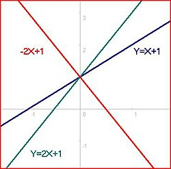

Tiga garis lurus berwarna merah, hijau, dan biru yang berpotongan di titik koordinat nol-koma-satu

*Garis-garis yang berpotongan di titik $(0,1)$. Cronholm144, domain publik; berkas lokal: `authority/assets/250px-3_equations_-5.JPG`.*

### Contoh: beberapa garis melalui titik asal

Misalkan diberikan $d$ garis berbeda

$$L_1,\ldots,L_d$$

di bidang afin, semuanya melalui titik asal. Misalkan

$$a_iX+b_iY=0,
\qquad i=1,\ldots,d,$$

persamaan-persamaan garis yang terkait, yang hanya ditentukan hingga suatu skalar. Gabungan garis-garis tersebut dideskripsikan oleh produk

$$F=(a_1X+b_1Y)\cdots(a_dX+b_dY).$$

Secara khusus,

$$F=F_d$$

homogen berderajat $d$. Di sini setiap faktor linear mendefinisikan sebuah garis singgung melalui titik asal. Multiplisitasnya ialah $d$.

### Contoh: folium Descartes

[figure not shown]

Potret René Descartes dengan rambut sebahu, kerah putih, dan pakaian hitam pada latar gelap

*René Descartes (1596–1650). Potret menurut Frans Hals; diunggah ke Commons oleh Dedden; domain publik; berkas lokal: `authority/assets/250px-Frans_Hals_-_Portret_van_René_Descartes.jpg`.*

[figure not shown]

Grafik folium Descartes berwarna hijau dengan gelung di kuadran pertama, simpul di titik asal, dan asimtot biru putus-putus

*Folium Descartes $x^3+y^3-3xy=0$, beserta sumbu, kisi, dan asimtotnya. Georg-Johann, [CC BY-SA 3.0](https://creativecommons.org/licenses/by-sa/3.0/); berkas lokal: `authority/assets/Kartesisches-Blatt.svg`.*

*Folium Descartes* dideskripsikan oleh persamaan

$$F=X^3+Y^3-3XY=0.$$

Angka $3$ di sini tidak penting dan dapat diganti dengan bilangan lain yang tidak sama dengan $0$. Komponen-komponen homogen persamaan kurva tersebut ialah

$$F_3=X^3+Y^3$$

dan

$$F_2=-3XY.$$

Jadi titik asal folium Descartes mempunyai multiplisitas dua dan bersifat singular. Sumbu $X$ dan sumbu $Y$ keduanya merupakan garis singgung, masing- masing dengan multiplisitas satu. Pada semua titik lainnya kurva itu mulus, dengan syarat lapangan dasarnya tidak berkarakteristik $3$. Dari

$$\frac{\partial F}{\partial X}=3X^2-3Y=0
\qquad\text{dan}\qquad
\frac{\partial F}{\partial Y}=3Y^2-3X=0$$

diperoleh

$$Y=X^2
\qquad\text{dan}\qquad
X=Y^2,$$

sehingga juga

$$Y=Y^4,$$

dan demikian pula untuk $X$. Jadi

$$Y=X=0,$$

atau $X$ dan $Y$ keduanya merupakan akar satuan ketiga: keduanya $1$, atau $X$ dan $Y$ adalah dua akar satuan ketiga lainnya, dalam salah satu urutan. Akan tetapi, pada titik-titik lain tempat kedua turunan parsial itu nol, $F$ bernilai $-1$. Karena itu titik-titik ini bukanlah titik kurva.

### Catatan: persamaan garis singgung di titik mulus

Untuk suatu titik mulus

$$P\in C=V(F)$$

pada kurva aljabar bidang, multiplisitasnya ialah

$$m=1.$$

Jika $P=(0,0)$, suku linear persamaan kurvanya ialah

$$F_1=uX+vY=0,$$

dan

$$\frac{\partial F}{\partial X}(P)=u
\qquad\text{serta}\qquad
\frac{\partial F}{\partial Y}(P)=v,$$

sebab komponen-komponen homogen $F$ yang berderajat lebih tinggi tidak memberikan sumbangan pada turunan parsial di titik asal. Jadi persamaan linear tersebut merupakan persamaan garis singgung.

Untuk titik mulus sembarang

$$P=(a,b)\in C,$$

persamaan garis singgung juga dapat langsung dibaca dari turunan-turunan parsial $F$ di $P$. Garis singgung itu diberikan oleh

$$\frac{\partial F}{\partial X}(P)(X-a)
+
\frac{\partial F}{\partial Y}(P)(Y-b)
=0.$$

### Catatan: pemetaan tangen dan arah garis singgung

Misalkan $F\in K[X,Y]$ dengan kurva aljabar bidang terkait $C$, dan misalkan

$$P\in C=V(F)$$

suatu titik mulus kurva. Pemetaan

$$F:\mathbb A_K^2\longrightarrow\mathbb A_K^1$$

dan titik $P$ menentukan *pemetaan tangen* linear, yang juga disebut *diferensial total*, di antara ruang-ruang tangen terkait:

$$\begin{aligned}
T_PF
=
\left(
\frac{\partial F}{\partial X}(P),
\frac{\partial F}{\partial Y}(P)
\right):
T_P\mathbb A_K^2\cong\mathbb A_K^2
&\longrightarrow
T_{F(P)}\mathbb A_K^1
=T_0\mathbb A_K^1
\cong\mathbb A_K^1,\\
(s,t)
&\longmapsto
\frac{\partial F}{\partial X}(P)s
+
\frac{\partial F}{\partial Y}(P)t.
\end{aligned}$$

Karena $P$ titik mulus, pemetaan linear ini bukan pemetaan nol. Arah garis singgung $C$ di $P$ merupakan kernel pemetaan tangen ini. Ketika bidang tangen di $P$ diidentifikasi dengan bidang afin sekelilingnya, titik $P$ harus diidentifikasi dengan titik asal: garis singgung harus melalui titik tersebut, sedangkan kernel hanya menentukan suatu arah linear.

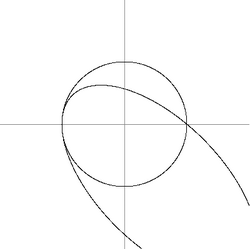

Dua kurva hitam—sebuah lingkaran dan sebuah cabang melengkung—yang berpotongan di dua titik, ditampilkan pada sumbu koordinat abu-abu

*Pada kurva aljabar, titik potong komponen-komponen tak tereduksi tidak pernah mulus. Sumber kuliah mengkreditkan Michael Larsen; metadata Commons mencatat pengunggah Maksim dan lisensi [CC BY-SA 3.0](https://creativecommons.org/licenses/by-sa/3.0/); berkas lokal: `authority/assets/250px-Intersect3.png`.*

Pernyataan berikut menunjukkan bahwa titik perpotongan dua komponen tak tereduksi tidak pernah dapat mulus.

### Lema: titik mulus terletak pada hanya satu komponen

Misalkan

$$C=V(F)$$

suatu kurva aljabar bidang dan

$$F=F_1\cdots F_n$$

dekomposisinya menjadi faktor-faktor prima yang berbeda. Misalkan $P\in C$ suatu titik mulus kurva. Maka $P$ terletak pada hanya satu komponen

$$C_i=V(F_i)$$

kurva tersebut.

**Bukti.** Lihat Soal 22.9.

### Korolari: kurva mulus dan terhubung bersifat tak tereduksi

Misalkan

$$C\subseteq\mathbb A_K^2$$

suatu kurva aljabar bidang mulus yang terhubung dalam topologi Zariski di atas lapangan tertutup secara aljabar $K$. Maka $C$ tak tereduksi.

#### Bukti

Menurut Lema 22.12, komponen-komponen tak tereduksi kurva tersebut saling lepas. Akan tetapi, komponen-komponen itu juga merupakan komponen-komponen terhubung kurva. Jadi hanya terdapat satu komponen tak tereduksi, dan karena itu kurva tersebut tak tereduksi.

**Provenans edisi.** Terjemahan dan produksi pembaca: OpenAI Codex gpt-5.6-sol, Ultra. Sumber, pengarang, dan lisensi komponen dipertahankan seperti dinyatakan dalam metadata dan berkas hak edisi.

# Lembar Kerja 22

## Soal latihan

### Soal 22.1

Misalkan $R$ gelanggang lokal pada titik perpotongan ketiga sumbu koordinat di ruang berdimensi tiga. Tentukan dimensi penyematannya.

### Soal 22.2

Berikan contoh suatu kurva

$$C\subseteq\mathbb A_K^n$$

yang memiliki titik-titik $P_1,P_2,P_3\in C$ dengan dimensi penyematan berturut-turut $1,2,3$.

### Soal 22.3

Misalkan $H(X)\in K[X]$, $F=Y-H$, dan

$$C=V(F)\subseteq\mathbb A_K^2$$

grafik $H$ yang dipandang sebagai kurva aljabar bidang. Misalkan

$$P=(a,b)=(a,H(a))$$

suatu titik pada grafik tersebut.

1. Tunjukkan bahwa multiplisitas $C$ di $P$ sama dengan $1$.
2. Tunjukkan bahwa garis singgung pada $C$ di $P$ bertepatan dengan garis singgung biasa pada grafik di titik $a$.

### Soal 22.4

Misalkan $K$ suatu lapangan dan

$$F_1,\ldots,F_m\in K[X_1,\ldots,X_\ell]$$

serta

$$G_1,\ldots,G_n\in K[X_1,\ldots,X_m]$$

polinom-polinom yang menghasilkan pemetaan polinomial

$$\mathbb A_K^\ell\mathrel{\mathop{\longrightarrow}^{F}}
\mathbb A_K^m\mathrel{\mathop{\longrightarrow}^{G}}\mathbb A_K^n.$$

Misalkan $J(F)_P$ dan $J(G)_Q$ matriks-matriks Jacobi yang didefinisikan melalui pendiferensialan parsial formal. Buktikan aturan rantai formal

$$J(G\circ F)_P=J(G)_{F(P)}\circ J(F)_P.$$

### Soal 22.5 ★

1. Tunjukkan bahwa pendiferensialan parsial formal terhadap suatu variabel pada gelanggang polinomial $K[X_1,\ldots,X_n]$ komutatif dengan dehomogenisasi terhadap variabel lain.
2. Tunjukkan bahwa pernyataan tersebut tidak berlaku jika kedua operasi dilakukan terhadap variabel yang sama.

### Soal 22.6 ★

Misalkan

$$H\in K[X_1,\ldots,X_n]$$

suatu polinom homogen berderajat $e$ dalam penggradasian standar. Tunjukkan hubungan

$$eH=X_1\frac{\partial H}{\partial X_1}+\cdots+
X_n\frac{\partial H}{\partial X_n}.$$

### Soal 22.7

Tinjau kurva yang diberikan oleh

$$y=2x^4+3x^2-x+1$$

beserta titik

$$P=(1, 5).$$

Carilah suatu transformasi koordinat yang membawa $P$ ke titik $(0,0)$ dan membawa garis singgung di $P$ ke sumbu-$x$.

### Soal 22.8

Misalkan $K$ suatu lapangan dan $F\in K[X,Y]$ suatu polinom tak konstan yang faktor-faktor primanya semuanya sederhana. Misalkan

$$C=V(F)$$

kurva bidang yang terkait. Andaikan lebih lanjut bahwa $F$ tetap bebas faktor berulang setelah perluasan skalar ke suatu ketertutupan aljabar dari $K$. Tunjukkan bahwa $C$ hanya memiliki berhingga banyak titik singular.

*Catatan edisi — koreksi hipotesis sumber:* Syarat bahwa faktor-faktor prima $F$ sederhana hanya di $K[X,Y]$ tidak cukup jika $K$ tak sempurna. Misalnya, di karakteristik $p>0$ sebuah polinom tereduksi di $K[X,Y]$ dapat menjadi pangkat ke-$p$ setelah perluasan skalar, sehingga kedua turunan parsialnya nol dan lokus singular geometrisnya berdimensi positif. Edisi ini menyatakan syarat tepat yang diperlukan dalam argumen: $F$ tereduksi secara geometris. Kondisi itu otomatis, misalnya, jika $K$ sempurna dan $F$ bebas faktor berulang.

### Soal 22.9 ★

Buktikan Lema 22.12.

[figure not shown]

Diagram lingkaran dengan jari-jari menuju titik singgung dan garis singgung yang tegak lurus terhadap jari-jari tersebut

*Gambar: Pada sebuah lingkaran, garis singgung di suatu titik tegak lurus terhadap jari-jari yang menuju titik itu. Karya Christophe Dang Ngoc Chan (Cdang), versi SVG turunan oleh Hagman; CC BY-SA 3.0.*

### Soal 22.10 ★

Tunjukkan bahwa lingkaran satuan di atas suatu lapangan berkarakteristik $\ne2$ adalah mulus, dan tentukan persamaan garis singgung di setiap titiknya.

### Soal 22.11

Misalkan $K$ suatu lapangan.

1. Tunjukkan bahwa grafik suatu polinom $F\in K[X]$ merupakan kurva aljabar mulus.
2. Misalkan $F,G\in K[X]$ polinom-polinom tanpa akar bersama. Tunjukkan bahwa grafik fungsi rasional $F/G$ juga merupakan kurva aljabar mulus.

### Soal 22.12 ★

Tentukan titik-titik singular kurva aljabar bidang

$$V\left(-2X^3+3X^2Y-Y+\frac{2}{3}\sqrt{\frac{1}{3}}\right)
\subseteq\mathbb A_{\mathbb C}^2.$$

### Soal 22.13

Untuk lintasan yang dihitung dalam Contoh 8.5, tentukan koordinat titik-titik tempat kurva tersebut singular.

### Soal 22.14 ★

Tentukan faktorisasi prima polinom

$$X^3+XY^2\in\mathbb C[X,Y],$$

kemudian tentukan singularitas kurva afin yang terkait, beserta multiplisitas dan garis-garis singgungnya.

### Soal 22.15 ★

Tentukan multiplisitas dan garis-garis singgung di titik asal $(0,0)$ dari kurva aljabar bidang

$$C=V\left(Y^4+X^3+3XY^2+2X^2Y\right)
\subseteq\mathbb A_{\mathbb C}^2.$$

### Soal 22.16 ★

Untuk lokus nol yang diberikan oleh polinom

$$V^3+U^2V-2UV+2U^2-4U-2V,$$

tentukan suatu titik singular dengan menggunakan turunan parsial. Lakukan transformasi koordinat yang membawa titik tersebut ke titik asal. Tentukan multiplisitas dan garis-garis singgung di titik itu.

*Catatan edisi — koreksi lingkup sumber:* Soal tidak menyebut lapangan dasar, sedangkan solusi sumber membagi dengan $2$ dan $3$, lalu memfaktorkan dengan $\sqrt3$. Untuk mengikuti solusi tersebut, andaikan $\operatorname{char}(K)\notin\{2,3\}$ dan $\sqrt3\in K$ (misalnya $K=\mathbb R$ atau $\mathbb C$). Di lapangan lain, titik yang ditemukan tetap dapat diperiksa langsung, tetapi faktorisasi dan multiplisitas garis singgung perlu dibaca di lapangan dasar yang bersangkutan; dalam karakteristik $2$, kerucut tangennya mempunyai satu garis singgung ganda.

[figure not shown]

Grafik kardioid simetris dengan titik runcing di sisi kiri dan lengkungan membulat di sisi kanan

*Gambar: Kardioid dengan persamaan polar $r=a(1+\cos\theta)$ untuk $a=1$. Karya D.328; CC BY-SA 3.0.*

### Soal 22.17

Tentukan singularitas, termasuk multiplisitas dan garis-garis singgungnya, dari kardioid yang diberikan oleh

$$V\left(\left(X^2+Y^2\right)^2
-2X\left(X^2+Y^2\right)-Y^2\right).$$

### Soal 22.18 ★

Tinjau dua kurva real

$$V\left(X^5-X^3+2XY+7Y^2-9\right)$$

di titik $(1,1)$ dan

$$V\left(X^4+Y^4-3X^2Y^2+5X+7Y\right)$$

di titik asal. Apakah kedua kurva ini secara lokal saling difeomorfik di titik-titik yang diberikan tersebut?

## Soal untuk dikumpulkan

### Soal 22.19 (3 poin)

Misalkan $K$ suatu lapangan berkarakteristik $p\geq0$. Karakterisasikan polinom-polinom $F\in K[X,Y]$ yang memenuhi masing-masing dari ketiga keadaan berikut:

1. turunan parsial pertama sama dengan $0$;
2. turunan parsial kedua sama dengan $0$;
3. kedua turunan parsial sama dengan $0$.

### Soal 22.20 (4 poin)

Untuk kurva

$$V\left(X^3+Y^3-3XY+1\right),$$

tentukan titik-titik singularnya di atas $\mathbb R$ dan di atas $\mathbb C$. Dalam setiap kasus, berikan multiplisitas dan garis-garis singgungnya.

### Soal 22.21 (3 poin)

Misalkan $K$ suatu lapangan tertutup secara aljabar dan $G,H\in K[X,Y]$ polinom-polinom yang memenuhi

$$G(P)=H(P)=0$$

untuk suatu titik tertentu $P\in\mathbb A_K^2$. Misalkan $F=GH$. Tunjukkan bahwa setiap garis singgung $G$ di $P$ dan setiap garis singgung $H$ di $P$ juga merupakan garis singgung $F$ di $P$.

### Soal 22.22 (6 poin)

Misalkan $K$ suatu lapangan tertutup secara aljabar. Tinjau kurva

$$C=V\left(x^3+5x^2y-6xy^2-x^2-xy+4y^2\right).$$

1. Tentukan garis-garis singgung di titik asal.
2. Tunjukkan bahwa

   $$P=(1,2)$$

   merupakan suatu titik pada kurva, dan hitung garis singgung (atau garis-garis singgung) $C$ di $P$ dengan menggunakan turunan.
3. Lakukan transformasi variabel sedemikian sehingga $P$ menjadi titik asal dalam variabel-variabel baru, lalu tentukan garis singgung (atau garis-garis singgung) di $P$ dari persamaan kurva yang telah ditransformasikan.

### Soal 22.23 (4 poin)

Untuk kurva aljabar

$$C=V\left(9y^4+10x^2y^2+x^4-12y^3-12x^2y+4y^2\right),$$

tentukan singularitas-singularitasnya beserta multiplisitas dan garis-garis singgungnya.

*Petunjuk sumber:* Bandingkan dengan Contoh 8.5.

**Provenans edisi.** Terjemahan dan produksi pembaca: OpenAI Codex gpt-5.6-sol, Ultra. Sumber, pengarang, dan lisensi komponen dipertahankan seperti dinyatakan dalam metadata dan berkas hak edisi.

# Solusi Publik Lembar Kerja 22

Pada batas revisi yang dibekukan, sumber hanya menyediakan solusi publik untuk Soal 22.5, 22.6, 22.9, 22.10, 22.12, 22.14, 22.15, 22.16, dan 22.18. Tidak ada solusi tambahan yang dibuat untuk edisi ini. Solusi Soal 22.9 mentransklusikan sebuah halaman bukti; teks di bawah menerjemahkan tubuh bukti yang sebenarnya dari penutupan transklusi rekursif yang dibekukan.

## Solusi Soal 22.5

1. Karena kedua proses bersifat linear, cukup meninjaunya pada monom

   $$X_1^{\nu_1}X_2^{\nu_2}X_3^{\nu_3}\cdots X_n^{\nu_n},$$

   lalu mempertimbangkan keadaan ketika turunan diambil terhadap $X_1$ dan dehomogenisasi dilakukan terhadap $X_2$. Turunan parsialnya adalah

   $$\nu_1X_1^{\nu_1-1}X_2^{\nu_2}X_3^{\nu_3}\cdots X_n^{\nu_n},$$

   dan dehomogenisasi menghasilkan

   $$\nu_1X_1^{\nu_1-1}X_3^{\nu_3}\cdots X_n^{\nu_n}.$$

   Jika dehomogenisasi dilakukan terlebih dahulu, diperoleh

   $$X_1^{\nu_1}X_3^{\nu_3}\cdots X_n^{\nu_n},$$

   dan turunan parsialnya juga menghasilkan

   $$\nu_1X_1^{\nu_1-1}X_3^{\nu_3}\cdots X_n^{\nu_n}.$$
2. Tinjau $X_1$. Pendiferensialan terhadap $X_1$ menghasilkan $1$, yang tetap sama setelah dehomogenisasi. Jika dehomogenisasi terhadap $X_1$ dilakukan terlebih dahulu, diperoleh $1$, dan turunannya adalah $0$.

Kembali ke Soal 22.5.

## Solusi Soal 22.6

Karena turunan parsial dan perkalian dengan suatu variabel bersifat linear, cukup membuktikan pernyataan tersebut untuk sebuah monom. Jadi, misalkan

$$H=X_1^{\nu_1}\cdot X_2^{\nu_2}\cdots X_n^{\nu_n}.$$

Maka

$$\begin{aligned}
X_1\frac{\partial H}{\partial X_1}+\cdots+
X_n\frac{\partial H}{\partial X_n}
&=\nu_1X_1\cdot X_1^{\nu_1-1}\cdot X_2^{\nu_2}\cdots X_n^{\nu_n} \\
&\quad+\nu_2X_2\cdot X_1^{\nu_1}\cdot X_2^{\nu_2-1}\cdots X_n^{\nu_n}
+\cdots \\
&\quad+\nu_nX_n\cdot X_1^{\nu_1}\cdot X_2^{\nu_2}\cdots X_n^{\nu_n-1} \\
&=\nu_1X_1^{\nu_1}\cdot X_2^{\nu_2}\cdots X_n^{\nu_n}
+\nu_2X_1^{\nu_1}\cdot X_2^{\nu_2}\cdots X_n^{\nu_n}
+\cdots \\
&\quad+\nu_nX_1^{\nu_1}\cdot X_2^{\nu_2}\cdots X_n^{\nu_n} \\
&=(\nu_1+\nu_2+\cdots+\nu_n)
X_1^{\nu_1}\cdot X_2^{\nu_2}\cdots X_n^{\nu_n}.
\end{aligned}$$

Inilah pernyataan yang hendak dibuktikan, karena jumlah eksponen adalah derajat monom tersebut.

Kembali ke Soal 22.6.

## Solusi Soal 22.9

Karena $P$ merupakan titik mulus pada kurva, tanpa mengurangi keumuman kita dapat mengasumsikan bahwa

$$\frac{\partial F}{\partial X}(P)\neq0.$$

Menurut aturan hasil kali,

$$\begin{aligned}
\frac{\partial F}{\partial X}(P)
&=\frac{\partial(F_1\cdots F_n)}{\partial X}(P) \\
&=\sum_{k=1}^n
F_1(P)\cdots F_{k-1}(P)\cdot
\frac{\partial F_k}{\partial X}(P)\cdot
F_{k+1}(P)\cdots F_n(P).
\end{aligned}$$

Sekarang andaikan

$$P\in C_i\cap C_j$$

untuk $i\neq j$, yakni

$$F_i(P)=F_j(P)=0.$$

Setiap hasil kali dalam jumlah di atas akan mempunyai sebuah faktor nol, sehingga

$$\frac{\partial F}{\partial X}(P)=0,$$

yang bertentangan dengan kemulusan $P$.

Kembali ke Soal 22.9.

## Solusi Soal 22.10

Polinom yang mendeskripsikan kurva adalah

$$X^2+Y^2-1,$$

dan turunan-turunan parsialnya adalah $2X$ dan $2Y$. Karena diasumsikan bahwa karakteristiknya bukan $2$, dan karena titik asal tidak terletak pada lingkaran, kurva tersebut mulus. Di titik $(a,b)$ pada lingkaran, persamaan garis singgungnya adalah

$$2a(X-a)+2b(Y-b)=0.$$

Setelah dibagi dengan $2$, persamaan ini dapat ditulis sebagai

$$aX+bY-a^2-b^2=aX+bY-1=0.$$

**Catatan edisi — koreksi sumber.** Sumber mencetak hanya ruas kiri kedua ungkapan sambil menyebutnya “persamaan garis singgung”. Edisi ini memulihkan syarat sama dengan nol yang membuatnya benar-benar sebuah persamaan.

Kembali ke Soal 22.10.

## Solusi Soal 22.12

Misalkan $F$ adalah polinom yang mendeskripsikan kurva. Turunan-turunan parsialnya adalah

$$\frac{\partial F}{\partial X}=-6X^2+6XY
\quad\text{dan}\quad
\frac{\partial F}{\partial Y}=3X^2-1.$$

Kita samakan kedua polinom dengan nol. Persamaan kedua memberikan $x^2=\frac13$, sehingga

$$x=\pm\sqrt{\frac13}.$$

Pada persamaan pertama, kita dapat mengeluarkan faktor $6X$, yang tidak nol, sehingga harus berlaku $x=y$. Jadi,

$$y=\pm\sqrt{\frac13}.$$

Untuk $x=y$, persamaan kurva menjadi

$$x^3-x+\frac23\sqrt{\frac13}=0.$$

Pada $x=\sqrt{\frac13}$, ruas kirinya bernilai

$$\frac13\sqrt{\frac13}-\sqrt{\frac13}
+\frac23\sqrt{\frac13}=0,$$

sehingga

$$\left(\sqrt{\frac13},\sqrt{\frac13}\right)$$

merupakan titik pada kurva. Sebaliknya, pada $x=y=-\sqrt{\frac13}$ diperoleh

$$-\frac13\sqrt{\frac13}+\sqrt{\frac13}
+\frac23\sqrt{\frac13}
=\frac43\sqrt{\frac13}\neq0,$$

sehingga titik tersebut bukan titik pada kurva. Jadi, satu-satunya singularitas kurva adalah

$$\left(\sqrt{\frac13},\sqrt{\frac13}\right).$$

Kembali ke Soal 22.12.

## Solusi Soal 22.14

Jelas bahwa

$$X(X+\mathrm iY)(X-\mathrm iY)$$

merupakan faktorisasi polinom tersebut menjadi faktor-faktor prima. Untuk menentukan titik-titik singular, kita periksa turunan-turunan parsialnya:

$$\frac{\partial F}{\partial X}=3X^2+Y^2
\quad\text{dan}\quad
\frac{\partial F}{\partial Y}=2XY.$$

Kedua persamaan ini dipenuhi tepat ketika $(x,y)=(0,0)$. Karena titik ini juga memenuhi persamaan kurva, titik tersebut merupakan titik singular kurva. Polinom yang mendeskripsikan kurva sudah homogen berderajat $3$, sehingga multiplisitasnya adalah $3$. Dengan demikian, garis-garis singgungnya diberikan oleh

$$V(X),\qquad V(X+\mathrm iY),\qquad V(X-\mathrm iY).$$

Kembali ke Soal 22.14.

## Solusi Soal 22.15

Multiplisitasnya adalah derajat komponen homogen yang berderajat paling rendah, yaitu $3$. Untuk menentukan garis-garis singgung, kita harus memfaktorkan $X^3+3XY^2+2X^2Y$ menjadi faktor-faktor linear. Kita mempunyai

$$X^3+3XY^2+2X^2Y=X(X^2+3Y^2+2XY).$$

Selanjutnya,

$$\begin{aligned}
X^2+3Y^2+2XY
&=(X+Y)^2-Y^2+3Y^2 \\
&=(X+Y)^2+2Y^2 \\
&=(X+Y+\sqrt2\,\mathrm iY)(X+Y-\sqrt2\,\mathrm iY).
\end{aligned}$$

Jadi, garis-garis singgungnya adalah

$$X=0$$

(sumbu $Y$), serta

$$X=-(1+\sqrt2\,\mathrm i)Y
\quad\text{dan}\quad
X=(-1+\sqrt2\,\mathrm i)Y.$$

Kembali ke Soal 22.15.

## Solusi Soal 22.16

Perhitungan sumber berikut menggunakan hipotesis edisi pada Soal 22.16, yaitu $\operatorname{char}(K)\notin\{2,3\}$ dan $\sqrt3\in K$.

Misalkan

$$F=V^3+U^2V-2UV+2U^2-4U-2V.$$

Maka

$$\frac{\partial F}{\partial U}=2UV-2V+4U-4
\quad\text{dan}\quad
\frac{\partial F}{\partial V}=3V^2+U^2-2U-2.$$

Dari persamaan pertama, untuk suatu titik singular diperoleh syarat

$$V(U-1)=-2U+2,
\qquad\text{atau}\qquad
V=\frac{-2U+2}{U-1},$$

dengan syarat pada bentuk terakhir bahwa $U\neq1$. Jadi, pertama-tama kita tinjau kasus $U=1$. Turunan parsial pertama kemudian sama dengan nol tanpa bergantung pada $V$, sedangkan turunan kedua memberikan syarat

$$3V^2+1-2-2=0,
\qquad V^2=1,
\qquad V=\pm1.$$

Persamaan kurva memberikan

$$V^3+V-2V-2V-2=V^3-3V-2=0,$$

yang dipenuhi oleh $V=-1$. Oleh karena itu,

$$P=(1,-1)$$

merupakan titik singular kurva.

Dengan variabel baru $X=U-1$ dan $Y=V+1$, titik $P$ menjadi titik asal. Melalui substitusi $U=X+1$ dan $V=Y-1$, persamaan kurva berubah menjadi

$$\begin{aligned}
&(Y-1)^3+(X+1)^2(Y-1)-2(X+1)(Y-1) \\
&\qquad+2(X+1)^2-4(X+1)-2(Y-1) \\
&=Y^3-3Y^2+3Y-1+(X^2+2X+1)(Y-1) \\
&\qquad-2XY+2X-2Y+2+2X^2+4X+2-4X-4-2Y+2 \\
&=Y^3-3Y^2+3Y-1+X^2Y+2XY+Y-X^2-2X-1 \\
&\qquad-2XY+2X-2Y+2+2X^2+4X+2-4X-4-2Y+2 \\
&=Y^3+X^2Y-3Y^2+X^2.
\end{aligned}$$

Jadi, komponen homogen berderajat paling rendah adalah

$$X^2-3Y^2=(X-\sqrt3Y)(X+\sqrt3Y).$$

Oleh karena itu, multiplisitasnya adalah dua dan kedua garis singgung melalui titik singular tersebut dideskripsikan oleh

$$X=\pm\sqrt3Y.$$

Kembali ke Soal 22.16.

## Solusi Soal 22.18

Turunan parsial polinom pertama terhadap $X$ adalah

$$5X^4-3X^2+2Y,$$

yang pada titik yang diberikan bernilai

$$4\neq0.$$

Turunan parsial polinom kedua terhadap $X$ adalah

$$4X^3-6XY^2+5,$$

yang pada titik yang diberikan bernilai

$$5\neq0.$$

Jadi, kedua kurva mulus pada titik-titik tersebut. Menurut teorema fungsi implisit, masing-masing kurva dengan demikian secara lokal difeomorfik dengan suatu interval riil terbuka, sehingga keduanya juga saling difeomorfik.

Kembali ke Soal 22.18.

**Provenans edisi.** Terjemahan dan produksi pembaca: OpenAI Codex gpt-5.6-sol, Ultra. Sumber, pengarang, dan lisensi komponen dipertahankan seperti dinyatakan dalam metadata dan berkas hak edisi.

# Kuliah 23: Ruang Kotangen dan Multiplisitas Hilbert-Samuel

## Interpretasi sebagai ruang kotangen

Kita tambahkan alasan mengapa $\mathfrak m/\mathfrak m^2$ layak disebut *ruang kotangen*. Dari analisis diketahui bahwa, untuk suatu titik $P\in M$ pada manifold $M$ dan suatu fungsi terdiferensialkan $f:M\longrightarrow\mathbb R$, diferensial

$$df:T_PM\longrightarrow\mathbb R$$

bersifat linear. Jadi, $df$ merupakan unsur ruang kotangen $T_P^*M$. Pemetaan keseluruhan

$$C^1(M,\mathbb R)\longrightarrow T_P^*M,
\qquad f\longmapsto df,$$

merupakan suatu derivasi: ia memenuhi aturan Leibniz

$$d(fg)=f\,dg+g\,df.$$

Kita sekarang memperkenalkan konsep aljabarnya.

### Definisi: derivasi aljabar

Misalkan $R$ suatu gelanggang komutatif, $A$ suatu aljabar komutatif atas $R$, dan $M$ suatu modul-$A$. Suatu pemetaan linear-$R$

$$\delta:A\longrightarrow M$$

disebut *derivasi-$R$* dengan nilai di $M$ jika

$$\delta(ab)=a\delta(b)+b\delta(a)$$

untuk semua $a,b\in A$.

### Teorema: derivasi kanonik menuju ruang kotangen

Misalkan $K$ suatu lapangan, $R$ suatu aljabar bertipe hingga atas $K$, dan

$$P\in K\!-\!\operatorname{Spek}(R)$$

suatu titik dengan ideal maksimal terkait $\mathfrak m$. Maka pemetaan

$$\begin{aligned}
d:R&\longrightarrow\mathfrak m/\mathfrak m^2,\\
f&\longmapsto d f:=\overline{f-f(P)}
\end{aligned}$$

merupakan suatu derivasi-$K$.

### Bukti

Terdapat isomorfisme kanonik $K\longrightarrow R/\mathfrak m$ antara lapangan dasar dan lapangan residu. Pemetaan $d$ terdefinisi dengan baik karena

$$(f-f(P))(P)=0,$$

sehingga $f-f(P)\in\mathfrak m$. Linearitas-$K$ langsung diperoleh. Untuk aturan hasil kali, semua kesamaan berikut dipahami di dalam $\mathfrak m/\mathfrak m^2$:

$$\begin{aligned}
d(fg)
&=\overline{fg-f(P)g(P)}\\
&=\overline{fg-f(P)g(P)+(f-f(P))(g-g(P))}\\
&=\overline{f(g-g(P))+g(f-f(P))}\\
&=f\,dg+g\,df.
\end{aligned}$$

Pada langkah kedua ditambahkan suatu unsur $\mathfrak m^2$, yang kelasnya nol dalam hasil bagi. Ini membuktikan aturan Leibniz. $\square$

*Catatan edisi – penjelasan notasi sumber:* Sumber menuliskan rantai di atas tanpa garis kelas pada setiap suku. Kesamaan tersebut adalah kesamaan modulo $\mathfrak m^2$, bukan kesamaan polinom di $R$.

## Titik mulus dan titik normal

Kita akan menunjukkan bahwa suatu titik pada kurva aljabar bidang bersifat mulus tepat ketika gelanggang lokal terkait merupakan gelanggang valuasi diskret. Kemulusan di suatu titik mula-mula didefinisikan secara ekstrinsik dengan merujuk pada bidang ambien, sedangkan sifat menjadi gelanggang valuasi diskret hanya bergantung pada gelanggang koordinat kurva. Lema berikut menangani satu arah. Untuk arah lainnya, kita terlebih dahulu mengembangkan multiplisitas intrinsik bagi gelanggang lokal.

### Lema: titik mulus menghasilkan gelanggang valuasi diskret

Misalkan $K$ suatu lapangan, $F\in K[X,Y]$ suatu polinom tak nol tanpa faktor berulang, dan

$$P\in C=V(F)$$

suatu titik mulus pada kurva tersebut. Jika $R$ adalah gelanggang lokal kurva di $P$, maka $R$ merupakan gelanggang valuasi diskret.

### Bukti

Mula-mula, $R$ adalah gelanggang lokal Noether dan, menurut Lema 22.12, merupakan domain integral. Karena itu, satu-satunya ideal prima $R$ ialah ideal nol dan ideal maksimal $\mathfrak m_P$. Kita akan menunjukkan bahwa ideal maksimal tersebut merupakan ideal utama.

Kita boleh menganggap $P$ sebagai titik asal dan menulis

$$F=F_d+\cdots+F_1,
\qquad F_1\ne0,$$

dengan setiap $F_i$ homogen berderajat $i$. Karena $P$ mulus, bentuk ini memiliki suku linear tak nol. Melalui perubahan variabel linear, kita dapat mengatur agar $F_1=Y$. Kumpulkan semua pangkat $X$ yang berdiri sendiri, yaitu monom yang tidak mengandung $Y$, lalu keluarkan faktor $Y$ dari suku-suku lainnya. Persamaan $F=0$ dapat ditulis sebagai

$$Y(1+G)=XH(X),
\qquad G\in(X,Y).$$

Unsur $1+G$ merupakan satuan dalam $K[X,Y]_{(X,Y)}$, dan karenanya juga dalam gelanggang lokal kurva di titik asal,

$$R=K[X,Y]_{(X,Y)}/(F).$$

Di dalam $R$ berlaku

$$Y=\frac{H}{1+G}X.$$

Jadi ideal maksimal $R$ dibangkitkan oleh $X$ saja. Berdasarkan Teorema 21.8, $R$ merupakan gelanggang valuasi diskret. $\square$

## Multiplisitas Hilbert-Samuel

### Lema: hasil bagi oleh pangkat ideal maksimal berdimensi hingga

Misalkan $R$ suatu gelanggang lokal Noether dengan ideal maksimal $\mathfrak m$ dan lapangan residu

$$K=R/\mathfrak m.$$

Maka modul faktor $\mathfrak m^n/\mathfrak m^{n+1}$ berdimensi hingga atas $K$. Jika $R$ memuat suatu lapangan $K$ yang dipetakan secara isomorfik ke lapangan residu, gelanggang faktor $R/\mathfrak m^n$ juga berdimensi hingga atas $K$.

### Bukti

Kita menulis

$$\mathfrak m^n/\mathfrak m^{n+1}
\cong
\mathfrak m^n/(\mathfrak m^n)\mathfrak m.$$

Ini adalah situasi Lema 22.2. Karena $\mathfrak m^n$ merupakan ideal yang dibangkitkan secara hingga, modul faktor tersebut berdimensi hingga atas lapangan residu.

Untuk gelanggang faktor, tinjau barisan eksak pendek modul-$R$

$$0\longrightarrow
\mathfrak m^n/\mathfrak m^{n+1}
\longrightarrow R/\mathfrak m^{n+1}
\longrightarrow R/\mathfrak m^n
\longrightarrow0.$$

Berdasarkan hipotesis tambahan, ini juga merupakan barisan eksak pendek ruang vektor-$K$, sehingga dimensi-dimensinya dapat dijumlahkan. Ruang di kiri berdimensi hingga menurut bagian yang baru dibuktikan. Induksi atas $n$ sekarang memberi hasil yang diinginkan, dengan kasus awal $R/\mathfrak m=K$. $\square$

Untuk suatu kurva aljabar bidang

$$V=V(F)\subseteq\mathbb A_K^2$$

dan titik $P=(a,b)\in V$, gelanggang lokalnya ialah

$$K[X,Y]_{(X-a,Y-b)}/(F).$$

Lapangan residunya adalah $K$ sendiri. Dengan demikian, semua hipotesis Lema 23.4 terpenuhi dan semua dimensi berikut adalah dimensi atas lapangan dasar.

### Teorema: multiplisitas melalui fungsi Hilbert-Samuel

Misalkan

$$P\in V=V(F)\subseteq\mathbb A_K^2$$

suatu titik pada kurva afin bidang. Misalkan

$$R=\mathcal O_{V,P}$$

gelanggang lokal terkait, dengan ideal maksimal $\mathfrak m$. Maka multiplisitas $m_P$ dari $P$ memenuhi

$$m_P=\dim_K\left(\mathfrak m^n/\mathfrak m^{n+1}\right)$$

untuk semua $n$ yang cukup besar.

### Bukti

Tinjau barisan eksak pendek ruang vektor-$K$

$$0\longrightarrow
\mathfrak m^n/\mathfrak m^{n+1}
\longrightarrow R/\mathfrak m^{n+1}
\longrightarrow R/\mathfrak m^n
\longrightarrow0.$$

Menurut Lema 23.4, semua dimensinya hingga. Pernyataan bahwa dimensi $\mathfrak m^n/\mathfrak m^{n+1}$ akhirnya konstan dan sama dengan multiplisitas ekuivalen dengan pernyataan bahwa selisih

$$\dim_K(R/\mathfrak m^{n+1})-\dim_K(R/\mathfrak m^n)$$

akhirnya konstan dan sama dengan multiplisitas. Melalui induksi, hal itu ekuivalen dengan adanya suatu konstanta $c$ sehingga

$$\dim_K(R/\mathfrak m^n)=m_Pn+c$$

untuk $n$ yang cukup besar.

Setelah melakukan translasi, kita boleh menganggap $P$ sebagai titik asal. Tetapkan

$$\mathfrak a=(X,Y)\subseteq S=K[X,Y].$$

Kemudian

$$K[X,Y]/(\mathfrak a^n+(F))=R/\mathfrak m^n,$$

sehingga cukup membuktikan pernyataan bagi hasil bagi di kiri. Berdasarkan hipotesis, $F$ mempunyai bentuk

$$F=F_m+F_{m+1}+\cdots,
\qquad m=m_P,$$

dan khususnya $F\in\mathfrak a^m$. Jika $G\in\mathfrak a^{n-m}$ dengan $n\ge m$, maka $GF\in\mathfrak a^n$. Karena itu terdapat barisan eksak pendek

$$0\longrightarrow
S/\mathfrak a^{n-m}
\xrightarrow{\,\cdot F\,}
S/\mathfrak a^n
\longrightarrow
S/(\mathfrak a^n,F)=R/\mathfrak m^n
\longrightarrow0.$$

Injektivitas di kiri diperoleh dari perbandingan derajat langsung; lihat Soal 23.4. Diketahui bahwa

$$\dim_K(S/\mathfrak a^n)=\frac{n(n+1)}2.$$

Oleh sebab itu, untuk $n\ge m$,

$$\begin{aligned}
\dim_K(R/\mathfrak m^n)
&=\frac{n(n+1)}2-\frac{(n-m)(n-m+1)}2\\
&=\frac{n^2+n-(n-m)^2-n+m}{2}\\
&=\frac{2nm-m^2+m}{2}\\
&=mn-\frac{m(m-1)}2.
\end{aligned}$$

Inilah bentuk linear yang diperlukan. $\square$

### Catatan: multiplisitas sebagai invarian intrinsik

Teorema 23.5 khususnya menyatakan bahwa multiplisitas suatu titik pada kurva bidang merupakan invarian gelanggang lokal kurva di titik tersebut. Jadi, multiplisitas hanya bergantung pada sifat intrinsik kurva, bukan pada realisasinya di dalam bidang ambien.

Setiap gelanggang lokal Noether mempunyai *multiplisitas Hilbert-Samuel*, yang didefinisikan melalui dimensi atas $R/\mathfrak m$ dari modul faktor $\mathfrak m^n/\mathfrak m^{n+1}$. Dalam kasus berdimensi satu, multiplisitas ini adalah

$$\lim_{n\to\infty}
\dim_{R/\mathfrak m}
\left(\mathfrak m^n/\mathfrak m^{n+1}\right),$$

karena fungsi tersebut akhirnya menjadi konstan–sebuah fakta yang tidak sepele. Jika $R$ memuat suatu lapangan $K$ yang isomorfik dengan lapangan residunya, seperti pada gelanggang lokal kurva yang dibahas di sini, bilangan yang sama juga diberikan oleh

$$\lim_{n\to\infty}
\frac{\dim_K(R/\mathfrak m^n)}{n}.$$

### Teorema: kemulusan, multiplisitas, valuasi diskret, dan normalitas

Misalkan $K$ suatu lapangan dan $F\in K[X,Y]$ suatu polinom tak konstan tanpa faktor berulang, dengan kurva aljabar terkait

$$C=V(F).$$

Misalkan $P=(a,b)\in C$, dengan ideal maksimal

$$\mathfrak m=(X-a,Y-b)$$

dan gelanggang lokal

$$R=K[X,Y]_{\mathfrak m}/(F).$$

Pernyataan berikut ekuivalen.

1. $P$ merupakan titik mulus pada kurva.
2. Multiplisitas $P$ sama dengan satu.
3. $R$ merupakan gelanggang valuasi diskret.
4. $R$ merupakan domain integral normal.

### Bukti

Ekuivalensi (1) $\Leftrightarrow$ (2) mengikuti Definisi 22.7 tentang multiplisitas. Ekuivalensi (3) $\Leftrightarrow$ (4) dibuktikan dalam Teorema 21.8, sedangkan implikasi (1) $\Rightarrow$ (3) dibuktikan dalam Lema 23.3. Jadi tinggal membuktikan (3) $\Rightarrow$ (2), dan berdasarkan Teorema 23.5 kita boleh menggunakan multiplisitas Hilbert-Samuel.

Cukup ditunjukkan bahwa, untuk gelanggang lokal kurva bidang yang merupakan gelanggang valuasi diskret, semua modul faktor

$$\mathfrak m^n/\mathfrak m^{n+1}
\cong
\mathfrak m^n/\mathfrak m^n\mathfrak m$$

berdimensi satu atas lapangan residu $R/\mathfrak m\cong K$. Karena $\mathfrak m^n=(\pi^n)$, hal ini langsung mengikuti lema Nakayama. $\square$

## Kurva monomial dan multiplisitas

Misalkan $M\subseteq\mathbb N$ suatu monoid numerik yang dibangkitkan oleh bilangan-bilangan asli saling prima

$$e_1<e_2<\cdots<e_r.$$

Pembangkit minimal $e_1$ juga disebut *multiplisitas numerik* $M$. Kita akan menunjukkan bahwa bilangan ini benar-benar menghasilkan multiplisitas gelanggang yang tepat. Tetapkan

$$M_+=\{m\in M\mid m\ge1\}$$

dan

$$nM_+=
\left\{
m\in M\ \middle|\
m=m_1+\cdots+m_n\text{ untuk suatu }m_i\in M_+
\right\}.$$

Keduanya merupakan ideal monoid pada $M$. Jadi ruang monom

$$K[nM_+]=\bigoplus_{m\in nM_+}KT^m$$

merupakan ideal di dalam gelanggang monoid. Secara khusus,

$$\mathfrak m=K[M_+]$$

merupakan ideal maksimal, dan pangkat-pangkatnya ialah

$$\mathfrak m^n=K[nM_+].$$

### Lema: taksiran himpunan selisih monoid

Misalkan $M\subseteq\mathbb N$ suatu monoid numerik dengan multiplisitas numerik $e_1$. Pilih bilangan $\ell\ge1$ sedemikian sehingga $\mathbb N_{\ge\ell}\subseteq M$. Maka

$$ne_1-\ell
\le
\#(M\setminus nM_+)
\le
(n-1)e_1+\ell.$$

### Bukti

Taksiran bawah mengikuti fakta bahwa bilangan terkecil dalam $nM_+$ adalah $ne_1$. Jadi bilangan $0,1,\ldots,ne_1-1$ berada di luarnya. Semua bilangan yang sedikitnya $\ell$ berada dalam $M$, sehingga di antara $ne_1$ bilangan tersebut setidaknya $ne_1-\ell$ berada dalam $M$ tetapi tidak dalam $nM_+$.

Untuk taksiran atas, kita klaim bahwa setiap bilangan yang sedikitnya $(n-1)e_1+\ell$ berada dalam $nM_+$. Misalkan

$$x\ge(n-1)e_1+\ell.$$

Tulislah

$$x=(n-1)e_1+\ell',
\qquad \ell'\ge\ell.$$

Karena $\ell'\in M_+$, ruas kanan adalah jumlah $n$ unsur $M_+$: sebanyak $n-1$ suku sama dengan $e_1$ dan satu suku sama dengan $\ell'$. Jadi $x\in nM_+$, dan taksiran atas terbukti. $\square$

*Catatan edisi – koreksi batas sumber:* Sumber hanya menyebut $\ell$ sebagai “suatu bilangan” dan pada langkah terakhir mengatakan bahwa suku-sukunya berada di $M$. Hipotesis $\ell\ge1$, yang selalu dapat dipenuhi dengan memperbesar ambang, memastikan bahwa semua $n$ suku benar-benar berada di $M_+$ sebagaimana dituntut oleh definisi $nM_+$.

### Korolari: multiplisitas numerik sama dengan multiplisitas Hilbert-Samuel

Misalkan $M\subseteq\mathbb N$ suatu monoid numerik yang dibangkitkan oleh bilangan-bilangan saling prima dan mempunyai multiplisitas numerik $e_1$. Misalkan

$$\mathfrak m=K[M_+]$$

ideal maksimal pada gelanggang monoid $K[M]$ yang bersesuaian dengan titik asal. Maka

$$\lim_{n\to\infty}
\frac{\dim_K\left(K[M]/\mathfrak m^n\right)}{n}
=e_1.$$

Dengan kata lain, multiplisitas numerik sama dengan multiplisitas Hilbert-Samuel.

### Bukti

Karena $\mathfrak m^n=K[nM_+]$, gelanggang faktor

$$K[M]/\mathfrak m^n
=K[M]/K[nM_+]$$

mempunyai monom-monom $T^m$ dengan $m\in M\setminus nM_+$ sebagai basis atas $K$. Dimensinya dengan demikian sama dengan $\#(M\setminus nM_+)$. Menurut taksiran Lema 23.8,

$$\frac{\#(M\setminus nM_+)}{n}\longrightarrow e_1.$$

Konvergensi yang sama berlaku bagi dimensi-dimensi tersebut. $\square$

*Catatan edisi – penjelasan notasi sumber:* Bentuk sumber $K[M]/(nM_+)$ berarti hasil bagi oleh ideal monom $K[nM_+]$; tanda kurung itu bukan perkalian skalar himpunan dengan $n$.

# Lembar Kerja 23

## Soal latihan

### Soal 23.1

Misalkan $K$ suatu lapangan, $K[X_1,\ldots,X_n]$ gelanggang polinom atas $K$, dan

$$\frac{\partial}{\partial X_1}$$

turunan parsial formal terhadap $X_1$, yaitu pemetaan

$$\begin{aligned}
K[X_1,\ldots,X_n]&\longrightarrow K[X_1,\ldots,X_n],\\
f&\longmapsto\frac{\partial f}{\partial X_1}.
\end{aligned}$$

Tunjukkan bahwa pemetaan ini merupakan derivasi-$K$.

### Soal 23.2

Tinjau ideal maksimal

$$\mathfrak m=(X_1,\ldots,X_n)
\subseteq K[X_1,\ldots,X_n]$$

dalam gelanggang polinom atas suatu lapangan $K$, beserta pangkat-pangkat $\mathfrak m^d$. Tunjukkan bahwa monom-monom

$$X_1^{\nu_1}\cdots X_n^{\nu_n},
\qquad \sum_{i=1}^n\nu_i<d,$$

membentuk suatu basis atas $K$ bagi gelanggang faktor

$$K[X_1,\ldots,X_n]/\mathfrak m^d.$$

### Soal 23.3

Tinjau perpotongan sumbu

$$V(xy)\subseteq\mathbb A_K^2$$

dan gelanggang lokal $R$ yang bersesuaian dengan titik asal, dengan ideal maksimal $\mathfrak m$. Deskripsikan secara eksplisit suatu basis atas $K$ bagi gelanggang faktor $R/\mathfrak m^n$, lalu tentukan dimensinya.

### Soal 23.4 ★

Misalkan

$$F=F_m+\cdots+F_d\in K[X,Y]$$

dekomposisi homogen suatu polinom, dengan $m\le d$, dan misalkan $\mathfrak m=(X,Y)$. Tunjukkan bahwa, untuk setiap $n\ge m$, pemetaan perkalian

$$\begin{aligned}
K[X,Y]&\longrightarrow K[X,Y],\\
G&\longmapsto FG
\end{aligned}$$

menginduksi homomorfisme modul-$K[X,Y]$ yang terdefinisi dengan baik dan injektif

$$K[X,Y]/\mathfrak m^{n-m}
\longrightarrow
K[X,Y]/\mathfrak m^n.$$

### Soal 23.5 ★

Misalkan $e\in\mathbb N_+$ dan

$$M:=\{0\}\cup\mathbb N_{\ge e}\subseteq\mathbb N.$$

1. Tentukan $nM_+$ untuk $n\in\mathbb N_+$.
2. Tentukan $\#(M\setminus nM_+)$.
3. Misalkan $K$ suatu lapangan dan tetapkan

   $$R=K[M]_{\mathfrak m},
   \qquad
   \mathfrak m=K[M_+]\subseteq K[M].$$

   Tentukan $\dim_K(R/\mathfrak m^n)$.

### Soal 23.6

Untuk monoid numerik $M\subseteq\mathbb N$ yang dibangkitkan oleh $4$ dan $9$, hitunglah besaran-besaran yang muncul dalam taksiran Lema 23.8 hingga $n\le6$.

## Dimensi Krull

Beberapa soal berikut menggunakan dimensi Krull suatu gelanggang komutatif. Karena perhatian utama kita adalah kurva, yang bersesuaian dengan gelanggang berdimensi satu, kita tidak akan mengembangkan teori dimensi secara sistematis.

### Definisi: rantai ideal prima dan dimensi Krull

Misalkan $R$ suatu gelanggang komutatif. Suatu rantai ideal prima

$$\mathfrak p_0
\subset
\mathfrak p_1
\subset
\cdots
\subset
\mathfrak p_n$$

disebut *rantai ideal prima dengan panjang $n$*. Jadi yang dihitung adalah banyaknya inklusi, bukan banyaknya ideal prima dalam rantai. *Dimensi* atau *dimensi Krull* $R$ adalah supremum semua panjang rantai ideal prima dan ditulis

$$\dim(R).$$

### Soal 23.7

Misalkan $R$ suatu domain ideal utama yang bukan lapangan. Tunjukkan bahwa dimensi Krull $R$ sama dengan satu.

## Soal untuk dikumpulkan

### Soal 23.8 (4 poin)

Untuk monoid $M\subseteq\mathbb N$ yang dibangkitkan oleh $5,8,11$, hitunglah besaran-besaran yang muncul dalam taksiran Lema 23.8 hingga $n\le5$.

### Soal 23.9 (3 poin)

Misalkan $\mathfrak a\subseteq R$ suatu ideal dalam gelanggang komutatif, dan andaikan satu-satunya ideal prima yang memuat $\mathfrak a$ adalah suatu ideal maksimal $\mathfrak m$. Tunjukkan bahwa

$$R/\mathfrak a
\cong
R_{\mathfrak m}/\mathfrak aR_{\mathfrak m}.$$

Simpulkan bahwa, bagi suatu ideal maksimal $\mathfrak m$ dalam gelanggang komutatif Noether, berlaku isomorfisme

$$R/\mathfrak m^n
\cong
R_{\mathfrak m}/\mathfrak m^nR_{\mathfrak m}$$

untuk setiap $n$.

### Soal 23.10 (5 poin)

Misalkan $K$ suatu lapangan tertutup secara aljabar dan $R=K[X,Y]$ gelanggang polinom dalam dua variabel. Tunjukkan bahwa $R$ mempunyai dimensi Krull dua.

### Soal 23.11 (5 poin)

Misalkan $R$ suatu gelanggang komutatif Noether. Tunjukkan bahwa pernyataan berikut ekuivalen.

1. $R$ mempunyai dimensi Krull $0$.
2. $R$ merupakan gelanggang Artin.
3. $R$ mempunyai berhingga banyak ideal prima dan semuanya maksimal.
4. Terdapat $n\in\mathbb N$ sehingga

   $$(\mathfrak mR_{\mathfrak m})^n=0$$

   untuk setiap ideal maksimal $\mathfrak m$.
5. Reduksi $R_{\mathrm{red}}=R/\sqrt{(0)}$ merupakan hasil kali hingga lapangan-lapangan.

*Catatan edisi – koreksi pernyataan sumber:* Butir (4) pada sumber menuliskan $\mathfrak m^n=0$ di $R$ untuk setiap ideal maksimal. Pernyataan itu tidak ekuivalen dengan empat butir lainnya; misalnya, pada $R=K\times K$ kedua ideal maksimal bersifat idempoten, bukan nilpoten, meskipun $R$ berdimensi nol dan Artin. Edisi menggantinya dengan formulasi lokal seragam di atas, yang merupakan karakterisasi yang benar bagi gelanggang Noether berdimensi nol. Kata “hasil kali” pada butir (5) juga dinyatakan sebagai hasil kali *hingga*, sebagaimana dipaksakan oleh kondisi Noether/Artin.

### Soal 23.12 (3 poin)

Misalkan $R$ suatu gelanggang komutatif dengan dimensi Krull hingga $d$. Tunjukkan bahwa dimensi Krull gelanggang polinom $R[X]$ sedikitnya $d+1$.

*Catatan sumber:* Jika gelanggang dasar Noether, peralihan ke gelanggang polinom menaikkan dimensi tepat satu; membuktikan hasil yang lebih kuat itu lebih sulit.

# Solusi Publik Lembar Kerja 23

Pada batas revisi yang dibekukan, sumber hanya menyediakan solusi publik untuk Soal 23.4 dan 23.5. Tidak ada solusi tambahan yang dibuat untuk edisi ini.

## Solusi Soal 23.4

Tulislah $S=K[X,Y]$. Karena suku homogen terendah $F$ berderajat $m$, kita mempunyai $F\in\mathfrak m^m$. Untuk keterdefinisian yang baik, misalkan $G\in\mathfrak m^{n-m}$. Maka

$$FG\in\mathfrak m^m\mathfrak m^{n-m}=\mathfrak m^n.$$

Jadi pemetaan modul-$S$

$$S\xrightarrow{\,\cdot F\,}S
\longrightarrow S/\mathfrak m^n$$

bernilai nol pada $\mathfrak m^{n-m}$. Berdasarkan sifat universal modul faktor, pemetaan tersebut menginduksi homomorfisme modul-$S$

$$S/\mathfrak m^{n-m}
\xrightarrow{\,\cdot F\,}
S/\mathfrak m^n.$$

Untuk membuktikan injektivitas, misalkan kelas $G$ dipetakan ke nol, sehingga $FG\in\mathfrak m^n$. Andaikan $G\notin\mathfrak m^{n-m}$. Jika $q$ adalah derajat suku homogen tak nol terendah $G_q$ dari $G$, maka

$$q<n-m.$$

Suku homogen terendah dari $FG$ adalah $F_mG_q$. Karena $K[X,Y]$ merupakan domain integral dan $F_m,G_q\ne0$, berlaku

$$F_mG_q\ne0,
\qquad
\deg(F_mG_q)=m+q<n.$$

Dengan demikian $FG\notin\mathfrak m^n$, bertentangan dengan asumsi. Jadi $G\in\mathfrak m^{n-m}$ dan kelasnya nol. Homomorfisme yang diinduksi tersebut injektif. $\square$

*Catatan edisi – koreksi solusi sumber:* Sumber mengatakan bahwa $FG$ mempunyai monom berderajat “kurang dari $m$”; batas yang diperlukan adalah kurang dari $n$. Argumen melalui suku homogen terendah $F_mG_q$ di atas juga menutup kemungkinan pembatalan. Karena perkalian dengan $F$ umumnya bukan homomorfisme gelanggang, faktorisasi yang digunakan adalah sifat universal *modul* faktor.

Kembali ke Soal 23.4

## Solusi Soal 23.5

1. Kita klaim bahwa

   $$nM_+=\mathbb N_{\ge ne}.$$

   Keanggotaan $k\in nM_+$ berarti bahwa terdapat $m_1,\ldots,m_n\in M_+=\mathbb N_{\ge e}$ dengan

   $$k=m_1+\cdots+m_n.$$

   Karena $m_j\ge e$ untuk setiap $j$, diperoleh $k\ge ne$. Sebaliknya, jika $k\ge ne$, maka

   $$k=(n-1)e+m,
   \qquad m:=k-(n-1)e\ge e.$$

   Jadi ruas kanan adalah jumlah $n$ unsur $M_+$ dan $k\in nM_+$.
2. Diperoleh

   $$M\setminus nM_+
   =M\setminus\mathbb N_{\ge ne}
   =\{0,e,e+1,\ldots,ne-1\}.$$

   Karena itu,

   $$\#(M\setminus nM_+)=ne-e+1=(n-1)e+1.$$
3. Ideal $\mathfrak m^n$ adalah ideal monom $K[nM_+]$. Pelokalan tidak mengubah hasil bagi berdimensi hingga ini, dan terdapat isomorfisme ruang vektor-$K$

   $$\begin{aligned}
   R/\mathfrak m^n
   &\cong K[M]/K[nM_+]\\
   &\cong
   \operatorname{span}_K
   \{T^m\mid m\in M\setminus nM_+\}.
   \end{aligned}$$

   Maka

   $$\dim_K(R/\mathfrak m^n)=(n-1)e+1.$$

*Catatan edisi – koreksi solusi sumber:* Pada bagian pertama, sumber menuliskan $n_j\ge e$ setelah memperkenalkan $m_1,\ldots,m_n$; indeks yang benar ialah $m_j\ge e$. Pada bagian ketiga, notasi sumber menyamakan hasil bagi dengan $K[M\setminus nM_+]$ seolah-olah komplemen itu gelanggang monoid. Edisi menyatakan objek yang tepat: hasil bagi oleh ideal monom $K[nM_+]$ dan ruang linear dengan basis monom dari komplemennya.

Kembali ke Soal 23.5

# Kuliah 24: Garis Singgung dan Gelanggang Deret Pangkat Formal

## Garis singgung pada parametrisasi

### Teorema 24.1: vektor turunan suatu parametrisasi

Misalkan $K$ lapangan tak hingga dan

$$\varphi\colon \mathbb A_K^1\longrightarrow \mathbb A_K^n$$

suatu pemetaan yang diberikan oleh $n$ polinom dalam satu variabel,

$$\varphi=\bigl(\varphi_1(t),\ldots,\varphi_n(t)\bigr),$$

dan misalkan citranya termuat dalam kurva

$$C=V(F_1,\ldots,F_m).$$

Ambil $Q\in\mathbb A_K^1$ dan

$$P=\varphi(Q)\in C.$$

Maka vektor turunan

$$\left(
\frac{\partial\varphi_1}{\partial t}(Q),\ldots,
\frac{\partial\varphi_n}{\partial t}(Q)
\right)$$

terletak dalam kernel pemetaan tangen linear

$$(TF)_P\colon\mathbb A_K^n\longrightarrow\mathbb A_K^m$$

yang didefinisikan oleh matriks Jacobi

$$\left(
\frac{\partial F_i}{\partial X_j}(P)
\right)_{ij}.$$

Jika $n=2$, kedua turunan $\varphi_1'(Q)$ dan $\varphi_2'(Q)$ tidak sekaligus nol, dan $P$ merupakan titik mulus pada $C$, maka

$$\left(
\frac{\partial\varphi_1}{\partial t}(Q),
\frac{\partial\varphi_2}{\partial t}(Q)
\right)$$

menentukan arah garis singgung $C$ di $P$.

#### Bukti

Tuliskan $F=(F_1,\ldots,F_m)$. Karena

$$\varphi\bigl(\mathbb A_K^1\bigr)\subseteq V(F_1,\ldots,F_m),$$

komposisi $F\circ\varphi$ adalah pemetaan konstan ke titik nol. Karena $K$ tak hingga, setiap polinom komponen yang menyatakan $F_i\circ\varphi$ merupakan polinom nol. Aturan rantai formal untuk polinom karena itu memberikan

$$0=(T(F\circ\varphi))_Q=(TF)_P\circ(T\varphi)_Q.$$

Jadi citra $(T\varphi)_Q$, yang dibentang oleh vektor turunan di atas, termuat dalam kernel $(TF)_P$.

Dalam kasus bidang yang dinyatakan pada bagian terakhir teorema, kernel matriks Jacobi berdimensi satu. Citra $(T\varphi)_Q$ juga berdimensi satu karena vektor turunannya tidak nol. Inklusi tersebut dengan demikian merupakan kesamaan, sehingga vektor itu menentukan arah garis singgung. $\square$

### Contoh 24.2: mengapa lapangan harus tak hingga

Misalkan $K$ lapangan hingga dengan

$$q=p^e$$

unsur, dengan $p$ prima dan $e\geq1$. Pemetaan

$$\begin{aligned}
\mathbb A_K^1&\longrightarrow\mathbb A_K^2,\\
t&\longmapsto(t^q-t,t^q-t)
\end{aligned}$$

mengirim setiap titik $K$-rasional ke satu-satunya titik citra $(0,0)$, sebab $t^q=t$ untuk setiap $t\in K$. Akan tetapi, vektor turunan formal parametrisasi polinomial tersebut ialah

$$(-1,-1).$$

Jadi pemetaan pada titik-titik $K$-rasional dapat bersifat konstan dalam karakteristik positif walaupun turunan formal polinom yang mendefinisikannya tidak nol. Titik asal merupakan titik mulus pada setiap garis

$$C=V(aX+bY),$$

dengan $(a,b)\ne(0,0)$.

Arah garis singgungnya adalah kernel bentuk linear $aX+bY$, sedangkan bentuk itu menganulir $(-1,-1)$ hanya apabila $a=-b$. Dengan demikian, asumsi bahwa $K$ tak hingga dalam Teorema 24.1 tidak dapat dihapus.

> **Catatan edisi.** Pernyataan kekonstanan di sini secara eksplisit menyangkut fungsi pada titik-titik $K$-rasional. Morfisme yang didefinisikan oleh pasangan polinom $(t^q-t,t^q-t)$ bukan morfisme konstan. Pembedaan ini mencegah kata “konstan” disalahartikan sebagai pernyataan tentang polinom atau morfisme itu sendiri.

### Contoh 24.3: garis singgung dari sebuah parametrisasi

Dalam contoh ini kita bekerja di atas lapangan $K$ berkarakteristik nol. Pertimbangkan kurva

$$V(y^2-x^2-x^3)$$

dengan parametrisasi

$$(\varphi(t),\psi(t))
=\bigl(t^2-1,t(t^2-1)\bigr)
=(x,y).$$

Untuk

$$F=y^2-x^2-x^3,$$

turunan parsialnya adalah

$$\frac{\partial F}{\partial x}=-2x-3x^2
\qquad\text{dan}\qquad
\frac{\partial F}{\partial y}=2y.$$

Matriks Jacobi parametrisasi, dipandang sebagai vektor baris, ialah

$$\left(
\frac{\partial\varphi}{\partial t},
\frac{\partial\psi}{\partial t}
\right)
=(2t,3t^2-1).$$

Dengan $P=(\varphi(t),\psi(t))$, perhitungan aturan rantai polinomial formal memang memberikan

$$\begin{aligned}
&\left(
\frac{\partial F}{\partial x}(P),
\frac{\partial F}{\partial y}(P)
\right)
\begin{pmatrix}2t\\3t^2-1\end{pmatrix}\\
&=\left(
-2(t^2-1)-3(t^2-1)^2,
2(t^3-t)
\right)
\begin{pmatrix}2t\\3t^2-1\end{pmatrix}\\
&=-4t(t^2-1)-6t(t^2-1)^2
+2(t^3-t)(3t^2-1)\\
&=-4t^3+4t-6t^5+12t^3-6t
+6t^5-2t^3-6t^3+2t\\
&=0.
\end{aligned}$$

Untuk $t=2$, misalnya, diperoleh titik citra

$$P=(3,6).$$

Vektor turunannya adalah $(4,11)$, sedangkan turunan parsial di $P$ memberikan gradien $(-33,12)$, yang ortogonal terhadap vektor arah garis singgung. Garis singgungnya dapat ditulis sebagai

$$\bigl\{(3,6)+s(4,11)\mid s\in K\bigr\}$$

atau sebagai

$$V(-11x+4y+9).$$

> **Catatan edisi.** Sumber tidak menyatakan batasan karakteristik pada contoh numerik ini. Edisi ini membatasinya pada karakteristik nol karena koefisien $2$, $3$, dan $11$, serta nilai khusus $t=2$, dapat berubah atau lenyap setelah direduksi dalam karakteristik positif kecil. Dalam karakteristik positif, kemulusan dan arah garis singgung harus diperiksa kembali di lapangan yang bersangkutan.

## Garis singgung pada kurva ruang

Walaupun pembahasan kita terutama dibatasi pada kurva bidang, turunan juga dapat dipakai untuk mendefinisikan titik mulus dan singular pada kurva di ruang berdimensi lebih tinggi, bahkan pada varietas sembarang. Sebagai ilustrasi, misalkan sebuah kurva ruang diberikan oleh dua polinom tanpa komponen bersama,

$$F,G\in K[X,Y,Z].$$

Tidak setiap kurva ruang dapat dideskripsikan dengan cara ini. Untuk $P\in C=V(F,G)$, pertimbangkan kembali pemetaan yang diberikan oleh matriks Jacobi

$$\left(
\begin{array}{ccc}
\dfrac{\partial F}{\partial x}&
\dfrac{\partial F}{\partial y}&
\dfrac{\partial F}{\partial z}\\[4pt]
\dfrac{\partial G}{\partial x}&
\dfrac{\partial G}{\partial y}&
\dfrac{\partial G}{\partial z}
\end{array}
\right)_P
\colon\mathbb A_K^3\longrightarrow\mathbb A_K^2.$$

Titik $P$ mulus pada kurva tepat apabila matriks tersebut memiliki rank dua. Dalam keadaan itu, kernelnya berdimensi satu dan mendefinisikan garis singgung.

### Contoh 24.4: irisan dua silinder

Anggap $\operatorname{char}(K)\ne2$. Pertimbangkan irisan $C$ dari dua silinder

$$F=x^2+y^2-1
\qquad\text{dan}\qquad
G=y^2+z^2-1.$$

Vektor-vektor turunan parsialnya ialah

$$\partial F=(2x,2y,0)
\qquad\text{dan}\qquad
\partial G=(0,2y,2z).$$

Suatu titik singular terjadi apabila pemetaan yang didefinisikan oleh matriks Jacobi ini memiliki rank paling banyak satu, yakni apabila kedua vektor turunan parsial bergantung linear dan titik tersebut memang terletak pada varietas terkait. Ketergantungan linear mengharuskan

$$xy=xz=yz=0.$$

Pada kurva dengan kedua parameter sama dengan $1$, persamaan kurva menyingkirkan kasus $x=y=0$ dan $y=z=0$. Jadi kandidat yang tersisa memenuhi

$$x=z=0,$$

dan untuk nilai itu kedua vektor memang bergantung linear bagi setiap $y$. Ketika $x=z=0$, hanya

$$y=\pm1$$

yang memberikan titik pada kurva. Jadi, kedua titik itulah tepatnya titik singular $C$. Keduanya juga merupakan dua titik potong dua lingkaran yang menjadi komponen-komponen tak tereduksi $C$.

Untuk versi berjari-jari berbeda, tuliskan $r_1,r_2\in K^\times$ sebagai *kuadrat jari-jari tak nol* dan gunakan

$$F=x^2+y^2-r_1,
\qquad
G=y^2+z^2-r_2.$$

Jika besaran yang diberikan adalah jari-jari $\rho_1$ dan $\rho_2$ sendiri, maka $r_i=\rho_i^2$. Syarat ketergantungan $xy=xz=yz=0$ sekarang harus diselesaikan bersama kedua persamaan kurva. Pada cabang $x=z=0$, persamaan itu menjadi

$$y^2=r_1
\qquad\text{dan}\qquad
y^2=r_2.$$

Jadi cabang ini memaksa $r_1=r_2$. Cabang $x=y=0$ memaksa $r_1=0$, sedangkan cabang $y=z=0$ memaksa $r_2=0$. Ketiganya mustahil untuk $r_1,r_2\ne0$ dan $r_1\ne r_2$. Jadi kurva irisan tersebut mulus apabila kuadrat jari-jarinya tak nol dan berbeda. Untuk silinder real dengan jari-jari positif, ketaknolannya otomatis.

> **Catatan edisi.** Teks semantik hidup yang dibekukan memakai $G=y^2+z^2-1$; PDF historis resmi salah mencetak $G=x^2+z^2-1$. Edisi ini mengikuti teks semantik hidup. Sumber juga menyebut $r_1,r_2$ “jari-jari” tetapi kemudian memakai persamaan $y^2=r_i$; di sini parameter itu dijelaskan sebagai kuadrat jari-jari. Syarat ketaknolannya juga dibuat eksplisit karena jika $r_1=0$ atau $r_2=0$, peringkat matriks Jacobi dapat turun walaupun $r_1\ne r_2$. Asumsi $\operatorname{char}(K)\ne2$ dibuat tampak karena semua turunan yang ditampilkan akan lenyap dalam karakteristik $2$.

## Gelanggang deret pangkat

### Definisi 24.5: deret pangkat formal

Misalkan $R$ suatu gelanggang komutatif dan $T_1,\ldots,T_n$ sekumpulan variabel. Suatu *deret pangkat formal* adalah ekspresi berbentuk

$$F=\sum_\nu a_\nu T^\nu
=\sum_\nu a_\nu T_1^{\nu_1}\cdots T_n^{\nu_n},$$

dengan

$$a_\nu\in R$$

untuk setiap multiindeks

$$\nu=(\nu_1,\ldots,\nu_n)\in\mathbb N^n.$$

Dua deret pangkat dijumlahkan komponen demi komponen dan dikalikan dengan cara yang sama seperti polinom. Dalam satu variabel,

$$\begin{aligned}
F\cdot G
&=\left(\sum_{i=0}^{\infty}a_iT^i\right)
\left(\sum_{j=0}^{\infty}b_jT^j\right)\\
&=\sum_{k=0}^{\infty}c_kT^k,
\end{aligned}$$

dengan

$$c_k=\sum_{i=0}^k a_i b_{k-i}.$$

### Definisi 24.6: gelanggang deret pangkat

Misalkan $R$ suatu gelanggang komutatif. Notasi

$$R[\![X_1,\ldots,X_n]\!]$$

menyatakan *gelanggang deret pangkat dalam $n$ variabel*, yang juga disebut *gelanggang deret pangkat formal dalam $n$ variabel*.

Kita terutama akan memakai gelanggang deret pangkat satu variabel $K[\![T]\!]$ di atas suatu lapangan $K$. Dengan gelanggang ini, kita dapat menemukan “parametrisasi formal” bagi kurva aljabar sembarang di setiap titik; hal itu akan dibahas pada kuliah berikutnya. Mula-mula kita perlu memahami beberapa sifat dasar gelanggang deret pangkat.

### Teorema 24.7: kriteria unit

Misalkan $K$ suatu lapangan. Deret pangkat formal

$$F=\sum_{n=0}^{\infty}a_nT^n\in K[\![T]\!]$$

merupakan unit tepat apabila suku konstannya memenuhi $a_0\ne0$.

#### Bukti

Syarat tersebut perlu karena evaluasi formal di $T=0$,

$$\begin{aligned}
\operatorname{ev}_0\colon K[\![T]\!]&\longrightarrow K,\\
F&\longmapsto F(0)=a_0,
\end{aligned}$$

merupakan homomorfisme gelanggang. Jadi unit harus dikirim ke unsur tak nol di $K$.

Sebaliknya, andaikan $a_0\ne0$. Kita akan membangun

$$G=\sum_{j=0}^{\infty}b_jT^j$$

sedemikian sehingga

$$FG=\left(\sum_{i=0}^{\infty}a_iT^i\right)
\left(\sum_{j=0}^{\infty}b_jT^j\right)=1.$$

Untuk koefisien konstan, kita memerlukan

$$a_0b_0=1,$$

yang mempunyai solusi tunggal $b_0=a_0^{-1}$. Secara induktif, andaikan $b_j$ telah dibangun untuk $j<n$ sehingga semua koefisien $c_k$ dari $FG$ dengan $1\leq k<n$ sama dengan nol. Untuk koefisien ke-$n$, syaratnya ialah

$$0=c_n=a_0b_n+a_1b_{n-1}+\cdots+a_{n-1}b_1+a_nb_0.$$

Semua nilai kecuali $b_n$ sudah ditentukan. Karena $a_0\ne0$, persamaan tersebut mempunyai tepat satu solusi untuk $b_n$. Induksi ini membangun invers $G$ bagi $F$. $\square$

> **Catatan edisi.** Teks semantik hidup mengakhiri alasan tentang homomorfisme suku konstan dengan penanda latihan yang belum terisi. Edisi ini tidak mempertahankan rujukan gantung itu; evaluasi di $T=0$ dinyatakan dan dipakai secara langsung.

### Korolari 24.8: gelanggang valuasi diskret

Jika $K$ suatu lapangan, maka gelanggang deret pangkat satu variabel

$$R=K[\![T]\!]$$

merupakan gelanggang valuasi diskret.

#### Bukti

Mula-mula, $R$ adalah gelanggang lokal dengan ideal maksimal

$$\mathfrak m=(T).$$

Memang, jika deret pangkat $F$ bukan unit, Teorema 24.7 menyatakan bahwa suku konstannya nol. Karena itu,

$$F=T\widetilde F$$

untuk deret pangkat $\widetilde F$ yang diperoleh dengan menggeser indeks.

Ketiadaan pembagi nol terlihat dari suku awal. Jika $F$ dan $G$ merupakan deret pangkat tak nol, tuliskan

$$F=a_kT^k+a_{k+1}T^{k+1}+\cdots$$

dan

$$G=b_\ell T^\ell+b_{\ell+1}T^{\ell+1}+\cdots,$$

dengan $a_k\ne0$ dan $b_\ell\ne0$. Karena semua koefisien sebelumnya nol, koefisien derajat $k+\ell$ pada hasil kali adalah

$$c_{k+\ell}=a_kb_\ell\ne0.$$

Terakhir, $R$ bahkan merupakan domain ideal utama. Untuk ideal tak nol $I\subseteq R$, ambil $j$ sebagai indeks terkecil dari koefisien tak nol di antara semua deret dalam $I$. Pilih $H\in I$ dengan suku awal berderajat $j$. Maka $H=T^jU$ dengan $U$ sebuah unit menurut Teorema 24.7, sehingga $T^j\in I$. Minimalitas $j$ juga memberi $I\subseteq(T^j)$, jadi

$$I=(T^j).$$

Dengan demikian $R$ adalah domain ideal utama lokal dengan ideal maksimal $(T)$, dan karenanya gelanggang valuasi diskret. $\square$

> **Catatan edisi.** Baik teks semantik hidup maupun PDF historis menulis suku kedua $G$ sebagai $a_{\ell+1}T^{\ell+1}$. Indeks keluarga koefisien yang benar ialah $b_{\ell+1}$, sebagaimana ditampilkan di atas.

Deret pangkat tidak hanya dapat dijumlahkan dan dikalikan. Dengan syarat tambahan tertentu, suatu deret pangkat juga dapat disubstitusikan ke dalam deret pangkat lain. Operasi ini bersesuaian dengan komposisi pemetaan.

### Definisi 24.9: substitusi deret pangkat

Misalkan $K$ suatu lapangan dan

$$F=\sum_{i=0}^{\infty}a_iT^i\in K[\![T]\!].$$

Misalkan pula

$$G=\sum_{j=0}^{\infty}b_jT^j$$

suatu deret pangkat dengan suku konstan $b_0=0$. Deret

$$\begin{aligned}
F(G)
&=a_0+a_1\left(\sum_{j=0}^{\infty}b_jT^j\right)
+a_2\left(\sum_{j=0}^{\infty}b_jT^j\right)^2\\
&\quad
+a_3\left(\sum_{j=0}^{\infty}b_jT^j\right)^3+\cdots\\
&=\sum_{k=0}^{\infty}c_kT^k
\end{aligned}$$

disebut *deret pangkat hasil substitusi*. Koefisiennya ditentukan oleh

$$c_0=a_0$$

dan, untuk $k\geq1$,

$$c_k=\sum_{s=0}^k a_s
\left(
\sum_{j_1+\cdots+j_s=k}b_{j_1}\cdots b_{j_s}
\right),$$

dengan jumlah dalam diambil atas semua $s$-tupel terurut

$$(j_1,\ldots,j_s)\in\mathbb N_+^s.$$

Karena $b_0=0$, hanya indeks $j\geq1$ yang muncul, sehingga setiap jumlah yang menentukan suatu koefisien bersifat hingga. Rumus ini berimpit dengan substitusi polinom biasa ketika $F$ dan $G$ adalah polinom. Substitusi deret pangkat ke dalam deret pangkat menghasilkan homomorfisme substitusi antara gelanggang-gelanggang deret pangkat.

### Lema 24.10: substitusi adalah homomorfisme

Misalkan $K$ suatu lapangan dan $G\in K[\![S]\!]$ suatu deret pangkat dengan suku konstan nol. Substitusi oleh $G$ mendefinisikan homomorfisme $K$-aljabar

$$\begin{aligned}
K[\![T]\!]&\longrightarrow K[\![S]\!],\\
F&\longmapsto F(G).
\end{aligned}$$

#### Bukti

Pemetaan itu terdefinisi dengan baik. Untuk membuktikan bahwa ia merupakan homomorfisme gelanggang, cukup bandingkan koefisien-koefisien yang sesuai. Setiap koefisien tersebut hanya bergantung pada sejumlah hingga koefisien deret-deret yang terlibat. Oleh sebab itu, identitas yang diperlukan mengikuti dari kasus polinomial. Pemetaan ini juga mempertahankan skalar $K$, sehingga merupakan homomorfisme $K$-aljabar. $\square$

### Lema 24.11: perubahan parameter formal

Misalkan $K$ suatu lapangan dan

$$G=\sum_{j=0}^{\infty}b_jT^j\in K[\![T]\!]$$

dengan $b_0=0$ dan $b_1\ne0$. Maka homomorfisme substitusi yang ditentukan oleh

$$T\longmapsto G$$

merupakan automorfisme $K$-aljabar pada $K[\![T]\!]$.

#### Bukti

Pertama-tama kita membangun deret pangkat

$$F=\sum_{i=0}^{\infty}a_iT^i$$

dengan

$$F(G)=T.$$

Haruslah $a_0=0$ dan $a_1=b_1^{-1}$. Untuk $k\geq2$, andaikan secara induktif bahwa koefisien-koefisien $F$ sampai $a_{k-1}$ telah dibangun agar koefisien yang diinginkan terpenuhi. Menurut Definisi 24.9, syarat untuk koefisien $c_k$ ialah

$$\begin{aligned}
0=c_k
&=\sum_{s=0}^k a_s
\left(
\sum_{j_1+\cdots+j_s=k}b_{j_1}\cdots b_{j_s}
\right)\\
&=\sum_{s=0}^{k-1}a_s
\left(
\sum_{j_1+\cdots+j_s=k}b_{j_1}\cdots b_{j_s}
\right)
+a_kb_1^k.
\end{aligned}$$

Karena $b_1\ne0$, persamaan ini menentukan $a_k$ secara tunggal.

Sekarang pertimbangkan komposisi

$$K[\![T]\!]
\xrightarrow{\ T\mapsto F\ }
K[\![T]\!]
\xrightarrow{\ T\mapsto G\ }
K[\![T]\!].$$

Komposisi totalnya ialah homomorfisme substitusi $T\mapsto T$, yaitu identitas. Karena itu, pemetaan kedua, yang ditentukan oleh $T\mapsto G$, surjektif. Menurut Korolari 24.8, $K[\![T]\!]$ merupakan gelanggang valuasi diskret, dan ideal-idealnya telah diketahui. Jika kernel pemetaan kedua tak nol, kernel itu memuat suatu $T^j$; tetapi citranya adalah $G^j\ne0$. Maka hanya ideal nol yang mungkin menjadi kernel. Pemetaan tersebut juga injektif, sehingga bijektif dan merupakan automorfisme $K$-aljabar. $\square$

# Lembar Kerja 24

## Soal latihan

### Soal 24.1

Berikan sebuah contoh kurva mulus

$$C\subseteq\mathbb A_K^2$$

yang memiliki suatu parametrisasi dengan diferensial yang bernilai nol pada setidaknya satu titik.

### Soal 24.2

Tinjau perpotongan sumbu

$$V(xy)\subseteq\mathbb A_K^2$$

dan gelanggang lokal $R$ yang bersesuaian dengan titik asal, dengan ideal maksimal $\mathfrak m$. Deskripsikan secara eksplisit suatu basis atas $K$ bagi gelanggang faktor $R/\mathfrak m^n$, lalu tentukan dimensinya.

### Soal 24.3

Misalkan $K$ suatu lapangan dan $K[[T]]$ gelanggang deret pangkat formal. Tentukan deret pangkat yang merupakan invers dari $1-T$.

### Soal 24.4 ★

Misalkan $K$ suatu lapangan dan

$$\mathfrak m=(T)\subseteq K[T]$$

ideal maksimal yang bersesuaian dengan titik asal, dengan pelokalan

$$R=K[T]_{\mathfrak m}.$$

Definisikan suatu homomorfisme aljabar-$K$

$$\varphi:R\longrightarrow K[[T]]$$

yang memenuhi $\varphi(T)=T$, dengan $K[[T]]$ menyatakan gelanggang deret pangkat formal.

### Soal 24.5

Hitung lima koefisien pertama, sampai dengan dan termasuk $c_4$, dari deret pangkat hasil substitusi $F(G)$ dalam pengertian Definisi 24.9.

## Soal untuk dikumpulkan

### Soal 24.6 (5 poin)

Berikan contoh suatu polinom real tak tereduksi

$$F\in\mathbb R[X,Y]$$

sedemikian sehingga kedua turunan parsialnya sama dan tidak konstan. Tunjukkan bahwa hal ini tidak mungkin terjadi di atas $\mathbb C$.

### Soal 24.7 (3 poin)

Tinjau kurva

$$C=V\left(Y^2-X^2-X^3\right)$$

dengan parametrisasi yang dibahas dalam Contoh 24.3. Tentukan titik-titik singular kurva beserta multiplisitas dan garis singgungnya. Hitung pula titik-titik citra dan garis-garis singgung untuk nilai parameter

$$t=-1,0,1.$$

Untuk kesimpulan geometris tentang garis singgung dan nilai parameter di atas, ambil lapangan dasar $\mathbb R$; khususnya, lapangan tersebut berkarakteristik nol.

*Catatan edisi - koreksi persamaan sumber:* Sumber menampilkan $C=V(X^2-Y^2-Y^3)$, tetapi parametrisasi yang dirujuk adalah

$$(x,y)=\left(t^2-1,t(t^2-1)\right).$$

Substitusi langsung memberi

$$y^2-x^2-x^3
=(t^2-1)^2\left(t^2-1-(t^2-1)\right)=0.$$

Karena itu edisi memakai $C=V(Y^2-X^2-X^3)$, sesuai dengan parametrisasi dan kategori objek sumber.

### Soal 24.8 (3 poin)

Deskripsikan suatu deret pangkat formal di atas $\mathbb C$ yang tidak konvergen pada lingkungan mana pun dari titik asal.

### Soal 24.9 (3 poin)

Misalkan $K$ suatu lapangan. Bandingkan kedua gelanggang

$$(K[X])[[Y]]
\qquad\text{dan}\qquad
(K[[Y]])[X].$$

Secara khusus, tentukan apakah salah satunya termuat dalam yang lain dan, jika demikian, tentukan arah inklusinya.

### Soal 24.10 (6 poin)

Misalkan $R$ suatu gelanggang komutatif Noether. Tunjukkan bahwa

$$R[[T_1,\ldots,T_n]]$$

bersifat Noether.

> **Petunjuk.** Ambillah inspirasi dari bukti Teorema Basis Hilbert.

# Solusi Publik Lembar Kerja 24

Pada batas revisi yang dibekukan, sumber hanya menyediakan solusi publik untuk Soal 24.4. Tidak ada solusi tambahan yang dibuat untuk edisi ini.

## Solusi Soal 24.4

Kita mulai dengan homomorfisme aljabar-$K$

$$\begin{aligned}
K[T]&\longrightarrow K[[T]],\\
T&\longmapsto T.
\end{aligned}$$

Setiap polinom $P\in K[T]\setminus (T)$ mempunyai suku konstan

$$P(0)\ne 0.$$

Oleh kriteria satuan untuk gelanggang deret pangkat formal, $P$ merupakan satuan di $K[[T]]$. Karena semua unsur himpunan penyebut $K[T]\setminus (T)$ dipetakan ke satuan, sifat universal pelokalan memberikan homomorfisme aljabar-$K$ yang tunggal

$$K[T]_{(T)}\longrightarrow K[[T]].$$

Secara eksplisit, pemetaan itu diberikan oleh

$$\frac{f}{P}\longmapsto fP^{-1}.$$

*Catatan edisi – koreksi solusi sumber:* Setelah menyatakan $P\notin (T)$, sumber hanya menampilkan simbol $\ne 0$ tanpa ruas kiri. Edisi memulihkan pernyataan yang diperlukan, yaitu $P(0)\ne0$; kesalahan ejaan Jerman yang tidak memengaruhi matematika juga diperbaiki secara alami dalam terjemahan.

Kembali ke Soal 24.4

# Kredit media

Kredit berikut mengikuti urutan kemunculan gambar dalam Kuliah 1. Setiap komponen mempertahankan lisensi sumbernya sendiri; lisensi teks kuliah tidak menggantikan lisensi komponen media.

1. **Grafik fungsi linear** — [File:Linear function.svg](https://commons.wikimedia.org/wiki/File:Linear_function.svg); pencipta/atribusi: No machine-readable author provided. Luks assumed (based on copyright claims).; lisensi: Public domain.
2. **Grafik polinom berderajat empat** — File:Polynomialdeg4.png; pencipta/atribusi: Phreneticc; lisensi: [CC BY-SA 3.0](http://creativecommons.org/licenses/by-sa/3.0/).
3. **Grafik fungsi rasional** — File:RationalDegree2byXedi.gif; pencipta/atribusi: Sam Derbyshire; lisensi: [CC BY-SA 3.0](http://creativecommons.org/licenses/by-sa/3.0/).
4. **Lingkaran satuan** — [File:Disk 1.svg](https://commons.wikimedia.org/wiki/File:Disk_1.svg); pencipta/atribusi: Paris 16; lisensi: Public domain.
5. **Elips** — File:Ellipse.svg; pencipta/atribusi: Zorgit; lisensi: [CC BY-SA 3.0](https://creativecommons.org/licenses/by-sa/3.0).
6. **Kurva dengan kuspa** — File:Cusp.png; pencipta/atribusi: Satipatthana; lisensi: Public domain.
7. **Contoh kurva eliptik** — [File:Elliptic curve simple.svg](https://commons.wikimedia.org/wiki/File:Elliptic_curve_simple.svg); pencipta/atribusi: derivative work: Pbroks13 ( talk ) Elliptic_curve_simple.png : Created by Sean κ . + 23:33, 27 May 2005 (UTC); lisensi: [CC BY-SA 3.0](http://creativecommons.org/licenses/by-sa/3.0/).
8. **Kubik Tschirnhausen** — [File:Tschirnhausen cubic.svg](https://commons.wikimedia.org/wiki/File:Tschirnhausen_cubic.svg); pencipta/atribusi: Original: Oleg Alexandrov Vector: Krishnavedala; lisensi: [GPL](http://www.gnu.org/licenses/gpl.html).
9. **Kampyle Eudoxus** — [File:Eudoxus.png](https://commons.wikimedia.org/wiki/File:Kampyle_Eudoxus.png); pencipta/atribusi: Donald Hosek; lisensi: Public domain.
10. **Konkoid Pascal** — [File:Conchoid of Pascal.png](https://commons.wikimedia.org/wiki/File:Conchoid_of_Pascal.png); pencipta/atribusi: Luke33; lisensi: Public domain.
11. **Bifolium** — File:Bifolium.png; pencipta/atribusi: Oleg Alexandrov; lisensi: Public domain.
12. **Limaçon** — File:Limacon.png; pencipta/atribusi: Berto; lisensi: Public domain.
13. **Quadrifolium** — File:Quadrifolium.svg; pencipta/atribusi: Mktyscn; lisensi: Public domain.
14. **Lemniskat Bernoulli** — [File:Lemniscate of Bernoulli.svg](https://commons.wikimedia.org/wiki/File:Lemniscate_of_Bernoulli.svg); pencipta/atribusi: Zorgit; lisensi: Public domain.
15. **Sikloid** — File:Cicloide.svg; pencipta/atribusi: Elborgo; lisensi: [CC BY 2.5](https://creativecommons.org/licenses/by/2.5).
16. **Spiral logaritmik** — [File:Logarithmic spiral.png](https://commons.wikimedia.org/wiki/File:Logarithmic_spiral.png); pencipta/atribusi: Anarkman~commonswiki; lisensi: [CC BY-SA 3.0](http://creativecommons.org/licenses/by-sa/3.0/).
17. **Grafik sinus** — File:Sin.svg; pencipta/atribusi: Self: Commons user Keytotime; lisensi: Public domain.
18. **Kurva Koch kuadratik** — [File:Quadratic Koch.png](https://commons.wikimedia.org/wiki/File:Quadratic_Koch.png); pencipta/atribusi: Alexis Monnerot-Dumaine; lisensi: [CC BY-SA 3.0](http://creativecommons.org/licenses/by-sa/3.0/).
19. **Hiperbola siku-siku** — [File:Rectangular hyperbola.svg](https://commons.wikimedia.org/wiki/File:Rectangular_hyperbola.svg); pencipta/atribusi: Qef; lisensi: Public domain.
20. **Kurva-kurva kubik yang dikaji Newton** — File:Newtonbig.gif; pencipta/atribusi: Pokipsy76; lisensi: [CC BY-SA 3.0](http://creativecommons.org/licenses/by-sa/3.0/).
21. **Isaac Newton** — File:GodfreyKneller-IsaacNewton-1689.jpg; pencipta/atribusi: James Thronill after Sir Godfrey Kneller; lisensi: Public domain.
22. **Contoh-contoh kurva eliptik real** — File:ECexamples01.png; pencipta/atribusi: Dake~commonswiki; lisensi: [CC BY-SA 3.0](http://creativecommons.org/licenses/by-sa/3.0/).
23. **Carl Friedrich Gauss** — [File:Carl Friedrich Gauss.jpg](https://commons.wikimedia.org/wiki/File:Carl_Friedrich_Gauss.jpg); pencipta/atribusi: Gottlieb Biermann / After Christian Albrecht Jensen; lisensi: Public domain.

# Kredit media Unit 2

Kredit mengikuti urutan gambar dalam Kuliah 2. Setiap komponen mempertahankan lisensi sumbernya sendiri.

1. **Irisan kerucut** — File:Conic_sections_2n.png; pencipta/atribusi: No machine-readable author provided. Nk assumed (based on copyright claims).; lisensi: [CC BY-SA 3.0](http://creativecommons.org/licenses/by-sa/3.0/).
2. **Contoh himpunan aljabar** — File:Conjuntos_algebraicos_2.svg; pencipta/atribusi: drini; lisensi: [CC BY-SA 4.0](https://creativecommons.org/licenses/by-sa/4.0).

# Kredit media Unit 3

Kredit mengikuti urutan gambar dalam Kuliah 3. Setiap komponen mempertahankan lisensi sumbernya sendiri.

1. **Oscar Zariski (1899-1986)** — [File:Oscar Zariski.jpg](https://commons.wikimedia.org/wiki/File:Oscar_Zariski.jpg); pencipta/atribusi: George Bergman; lisensi: [GFDL 1.2](http://www.gnu.org/licenses/old-licenses/fdl-1.2.html).
2. **Sebuah garis di bidang** — File:Lineline.jpg; pencipta/atribusi: Astur1; lisensi: Public domain.
3. **Irisan dua bidang** — File:IntersectingPlanes.png; pencipta/atribusi: The original uploader was Stib at English Wikipedia .; lisensi: [CC BY-SA 3.0](http://creativecommons.org/licenses/by-sa/3.0/).
4. **Irisan tiga bidang** — File:Secretsharing-3-point.png; pencipta/atribusi: stib; lisensi: [CC BY-SA 3.0](http://creativecommons.org/licenses/by-sa/3.0/).

# Kredit media Unit 4

Kredit mengikuti urutan gambar dalam Kuliah 4 dan Lembar Kerja 4. Setiap komponen mempertahankan lisensi sumbernya sendiri.

1. **Titik-titik untuk triangulasi Delaunay** — File:Delaunay_points.png; pencipta/atribusi: Nü es; lisensi: [CC BY-SA 3.0](http://creativecommons.org/licenses/by-sa/3.0/).
2. **Sebuah garis** — File:Gerade.svg; pencipta/atribusi: Adrian Neumann; lisensi: [CC BY-SA 3.0](http://creativecommons.org/licenses/by-sa/3.0/).
3. **Beberapa garis lurus** — File:Straight_lines.svg; pencipta/atribusi: Lokilech; lisensi: [CC BY-SA 3.0](http://creativecommons.org/licenses/by-sa/3.0/).
4. **Sebuah ruang linear** — File:Linear_space2.png; pencipta/atribusi: kmhkmh; lisensi: [CC BY 3.0](https://creativecommons.org/licenses/by/3.0).
5. **Hidran di Pulau Krk, Kroasia** — File:Hydrant_Insel_Krk_Kroatien.jpg; pencipta/atribusi: Usien; lisensi: [CC BY-SA 3.0](https://creativecommons.org/licenses/by-sa/3.0).
6. **Arah utama pada sebuah silinder** — File:Cylinder_principal_directions.svg; pencipta/atribusi: Luca Antonelli ( Luke Antony ); lisensi: [CC BY-SA 3.0](http://creativecommons.org/licenses/by-sa/3.0/).
7. **Dua kurva kubik** — File:Two_cubic_curves.png; pencipta/atribusi: Hack; lisensi: Public domain.
8. **Sebuah permukaan dan garis tegak** — File:Non_cohen_macaulay_scheme_thumb.png; pencipta/atribusi: The original uploader was Jakob.scholbach at English Wikipedia .; lisensi: [CC BY-SA 3.0](http://creativecommons.org/licenses/by-sa/3.0/).
9. **Hiperbola siku-siku** — File:Rectangular_hyperbola.svg; pencipta/atribusi: Qef; lisensi: Public domain.

# Kredit media Unit 5

Kredit mengikuti urutan gambar dalam Kuliah 5 dan Lembar Kerja 5. Setiap komponen mempertahankan status hak sumbernya sendiri.

1. **Sebuah kerucut (himpunan nol dari polinom homogen)** - File:Kuzel_obecny.svg; pencipta/atribusi: Pajs di Wikipedia bahasa Ceko; status hak/lisensi: domain publik.
2. **Emmy Noether (1882-1935)** - File:Noether.jpg; pencipta/atribusi: pencipta tidak diketahui; sumber/penerbit dicatat pada halaman Commons; status hak/lisensi: domain publik.
3. **Elipsoid tiga sumbu dengan perbandingan semisumbu 3:2:1** - File:Elipsoid_trojosy321.png; pencipta/atribusi: Pajs di Wikipedia bahasa Ceko; status hak/lisensi: domain publik.

# Kredit media Unit 6

Kredit mengikuti urutan gambar dalam Kuliah 6 dan Lembar Kerja 6. Setiap komponen mempertahankan status hak sumbernya sendiri.

1. **Kurva berparameter dapat dibayangkan sebagai suatu lintasan gerak** - [File:Krivka parametricky.png](https://commons.wikimedia.org/wiki/File:Krivka_parametricky.png); pencipta/atribusi: Beny di Wikipedia bahasa Ceko; status hak/lisensi: domain publik.
2. **Kurva kubik dengan titik ganda** - [File:Cubic with double point.svg](https://commons.wikimedia.org/wiki/File:Cubic_with_double_point.svg); pencipta/atribusi: Gunther di Wikipedia bahasa Jerman; status hak/lisensi: domain publik.
3. **Sissoid Diokles (hitam pada gambar) dapat diparameterkan secara rasional** - [File:Dioklova kisoida.png](https://commons.wikimedia.org/wiki/File:Dioklova_kisoida.png); pencipta/atribusi: Pajs di Wikipedia bahasa Ceko; status hak/lisensi: domain publik.

# Kredit media Unit 7

Kredit mengikuti sembilan posisi gambar dalam Kuliah 7. Setiap komponen mempertahankan status hak atau lisensi sumbernya sendiri. Tiga GIF orbit tetap beranimasi dalam pembaca HTML; PDF memakai bingkai pertamanya yang diturunkan secara lokal.

1. **Kerucut standar** - File:DoubleCone.png; pencipta/atribusi: Lars H. Rohwedder ( User:RokerHRO ); status hak/lisensi: Public domain.
2. **Irisan-irisan kerucut standar dengan bidang-bidang afin** - [File:Conic sections.svg](https://commons.wikimedia.org/wiki/File:Conic_sections.svg); pencipta/atribusi: Anuskafm; status hak/lisensi: [CC BY-SA 3.0](http://creativecommons.org/licenses/by-sa/3.0/).
3. **Tahap pertama transformasi sumbu utama suatu kuadrik** - File:Hauptachsentransformation1.png; pencipta/atribusi: rdb; status hak/lisensi: Public domain.
4. **Tahap kedua transformasi sumbu utama suatu kuadrik** - File:Hauptachsentransformation2.png; pencipta/atribusi: rdb; status hak/lisensi: Public domain.
5. **Tahap ketiga transformasi sumbu utama suatu kuadrik** - File:Hauptachsentransformation3.png; pencipta/atribusi: rdb; status hak/lisensi: Public domain.
6. **Potret seorang pria tak dikenal, dahulu disalahidentifikasi sebagai Johannes Kepler** - [File:Portrait Confused With Johannes Kepler 1610.jpg](https://commons.wikimedia.org/wiki/File:Portrait_Confused_With_Johannes_Kepler_1610.jpg); pencipta/atribusi: Unidentified painter; status hak/lisensi: Public domain.
7. **Orbit eliptik** - [File:Elliptic orbit.gif](https://commons.wikimedia.org/wiki/File:Elliptic_orbit.gif); pencipta/atribusi: Brandir; status hak/lisensi: [CC BY-SA 3.0](http://creativecommons.org/licenses/by-sa/3.0/).
8. **Orbit parabola** - [File:Parabolic orbit.gif](https://commons.wikimedia.org/wiki/File:Parabolic_orbit.gif); pencipta/atribusi: Brandir; status hak/lisensi: [CC BY-SA 3.0](http://creativecommons.org/licenses/by-sa/3.0/).
9. **Orbit hiperbola** - [File:Hyperbolic orbit.gif](https://commons.wikimedia.org/wiki/File:Hyperbolic_orbit.gif); pencipta/atribusi: Brandir; status hak/lisensi: [CC BY-SA 3.0](http://creativecommons.org/licenses/by-sa/3.0/).

# Kredit media Unit 8

Enam posisi media Kuliah 8 mempertahankan atribusi dan lisensi komponennya masing-masing. Dua GIF tetap beranimasi dalam pembaca HTML; PDF memakai bingkai pertama deterministik.

1. **File:Lemniscate Building.gif** - [File:Lemniscate Building.gif](https://commons.wikimedia.org/wiki/File:Lemniscate_Building.gif); pencipta/atribusi: Zorgit; lisensi: [CC BY-SA 3.0](https://creativecommons.org/licenses/by-sa/3.0).
2. **File:Parallelle lijnen.png** - [File:Parallelle lijnen.png](https://commons.wikimedia.org/wiki/File:Parallelle_lijnen.png); pencipta/atribusi: Ellywa at Dutch Wikipedia; lisensi: [CC BY-SA 3.0](http://creativecommons.org/licenses/by-sa/3.0/).
3. **File:Ellipse tri.png** - [File:Ellipse tri.png](https://commons.wikimedia.org/wiki/File:Ellipse_tri.png); pencipta/atribusi: Original uploader was דוד שי at he.wikipedia; lisensi: [CC BY-SA 3.0](http://creativecommons.org/licenses/by-sa/3.0/).
4. **File:Steam engine in action.gif** - [File:Steam engine in action.gif](https://commons.wikimedia.org/wiki/File:Steam_engine_in_action.gif); pencipta/atribusi: Panther; lisensi: [CC BY-SA 3.0](http://creativecommons.org/licenses/by-sa/3.0/).
5. **File:Intersection of cylinders.jpg** - [File:Intersection of cylinders.jpg](https://commons.wikimedia.org/wiki/File:Intersection_of_cylinders.jpg); pencipta/atribusi: Jan Schoenke; lisensi: [CC BY-SA 3.0](https://creativecommons.org/licenses/by-sa/3.0).
6. **File:Alg Kurven OS2008 Lsg8.10 v2.png** - [Datei:Alg Kurven OS2008 Lsg8.10 v2.png](https://de.wikiversity.org/wiki/Datei:Alg_Kurven_OS2008_Lsg8.10_v2.png); pencipta/atribusi: Christian Boberg; lisensi: CC BY-SA 3.0.

# Kredit media Unit 9

Satu posisi media substantif pada Kuliah 9 mempertahankan identitas Commons dan status hak sumbernya. Dua PDF yang dirujuk halaman adalah saksi build resmi dan dicatat dalam manifest authority, bukan media pembaca terpisah.

1. **David Hilbert (1886)** - [File:David Hilbert 1886.jpg](https://commons.wikimedia.org/wiki/File:David_Hilbert_1886.jpg); pencipta/atribusi: Jacek Halicki; status hak/lisensi: Public domain.

# Kredit media Unit 11

Satu posisi media substantif pada Kuliah 11 mempertahankan identitas Commons dan status hak sumbernya. Dua PDF yang dirujuk halaman adalah saksi build resmi dan dicatat dalam manifest authority, bukan media pembaca terpisah.

1. **Disjoint ellipses** - [File:Disjoint ellipses.png](https://commons.wikimedia.org/wiki/File:Disjoint_ellipses.png); pencipta: Pmidden; kredit sumber: karya sendiri, dibuat dengan Mathematica; status hak/lisensi: domain publik. Berkas pembaca adalah render Commons 250 piksel pada dimensi asli sumber, bukan klaim kecocokan bita dengan berkas asli; identitas berkas asli dipertahankan dalam `authority/RIGHTS-unit-11.csv`.

# Kredit media Unit 12

Empat posisi media substantif pada Kuliah 12 mempertahankan identitas Commons, atribusi, bentuk lokal, dan lisensi komponennya masing-masing. Dua PDF yang dirujuk halaman adalah saksi build resmi dalam manifest authority, bukan media pembaca terpisah.

1. **Alexander Grothendieck** — [File:Alexander Grothendieck.jpg](https://commons.wikimedia.org/wiki/File:Alexander_Grothendieck.jpg); foto: Konrad Jacobs; kredit: Copyright by MFO / Oberwolfach Photo Collection; lisensi: [CC BY-SA 2.0 de](https://creativecommons.org/licenses/by-sa/2.0/de/deed.en); bentuk pembaca: berkas asli 268 × 326.
2. **Garis horizontal** — File:Lineline.jpg; pencipta: Astur1; status hak: domain publik; bentuk pembaca: berkas asli 290 × 138.
3. **Grafik fungsi linear Kartesius** — File:Lineair-cartesiaans.png; pencipta/atribusi: MADe at Dutch Wikipedia; lisensi: [CC BY-SA 3.0](http://creativecommons.org/licenses/by-sa/3.0/); bentuk pembaca: derivatif resmi Commons 250 piksel, sementara identitas dan metadata berkas asli tetap dicatat dalam ledger hak.
4. **Grafik polinom berderajat lima** — File:Polynomialdeg5.png; pencipta/atribusi: Derbeth (berdasarkan klaim hak cipta pada sumber); lisensi: [CC BY-SA 3.0](http://creativecommons.org/licenses/by-sa/3.0/); bentuk pembaca: derivatif resmi Commons 120 piksel, sementara identitas dan metadata berkas asli tetap dicatat dalam ledger hak.

# Kredit media Unit 13

Kredit mengikuti urutan gambar dalam Kuliah 13. Setiap komponen mempertahankan lisensi sumbernya sendiri.

1. **Grafik hiperbola y = 1/x** - [File:Hyperbola one over x.svg](https://commons.wikimedia.org/wiki/File:Hyperbola_one_over_x.svg); pencipta/atribusi: No machine-readable author provided. Ktims assumed (based on copyright claims).; lisensi/status hak: [CC BY-SA 3.0](http://creativecommons.org/licenses/by-sa/3.0/).
2. **Ruang topologis terhubung (merah) dan ruang tak terhubung (hijau)** - [File:Connected and disconnected spaces2.svg](https://commons.wikimedia.org/wiki/File:Connected_and_disconnected_spaces2.svg); pencipta/atribusi: Dbc334; lisensi/status hak: Public domain.

# Kredit media Unit 14

Kredit mengikuti satu gambar dalam Kuliah 14. Komponen mempertahankan lisensi sumbernya sendiri.

1. **Grafik suatu fungsi global pada ruang afin dua dimensi** - File:Monkey Saddle Surface (Shaded).png; pencipta/atribusi: Inductiveload; lisensi/status hak: Public domain.

# Kredit media Unit 15

Kredit mengikuti satu gambar dalam Kuliah 15. Komponen mempertahankan lisensi sumbernya sendiri.

1. **Representasi skematis suatu filter lingkungan** - [File:Concentric Circles.svg](https://commons.wikimedia.org/wiki/File:Concentric_Circles.svg); pencipta/atribusi: Andreas Pietzowski; lisensi/status hak: [CC BY-SA 4.0](https://creativecommons.org/licenses/by-sa/4.0).

# Kredit media Unit 16

Kredit mengikuti urutan gambar dalam Kuliah 16 dan Solusi Publik 16.12. Setiap komponen mempertahankan lisensi sumbernya sendiri.

1. **Sebuah filter dapat diidentifikasi melalui apa yang tertahan di dalamnya** - File:Kaffeefilter.jpg; pencipta/atribusi: Elke Wetzig ( Elya ); lisensi/status hak: [CC BY-SA 3.0](http://creativecommons.org/licenses/by-sa/3.0/).
2. **Tidak setiap fungsi pada kerucut di luar sebuah garis dapat diperluas ke seluruh ruang afin tanpa garis tersebut** - [File:Cone intersects line.png](https://commons.wikimedia.org/wiki/File:Cone_intersects_line.png); pencipta/atribusi: Pmidden; lisensi/status hak: Public domain.
3. **Serat-serat suatu pemetaan; M adalah kodomain dan domain merupakan gabungan semua serat** - [File:FiberBundle 2.png](https://commons.wikimedia.org/wiki/File:FiberBundle_2.png); pencipta/atribusi: ja:user:１３２人目; lisensi/status hak: [CC BY-SA 3.0](http://creativecommons.org/licenses/by-sa/3.0/).
4. **Sketsa gabungan tiga sumbu koordinat pada Solusi 16.12** - File:Draft0.svg; pencipta/atribusi: Kalan; lisensi/status hak: [CC BY-SA 3.0](http://creativecommons.org/licenses/by-sa/3.0/).

# Kredit media Unit 17

Kuliah 17, Lembar Kerja 17, dan empat solusi publik yang dibekukan tidak memuat posisi media pembaca. Kedua PDF resmi hulu dipertahankan hanya sebagai saksi otoritas dan mempertahankan hak serta atribusi komponennya sendiri, sebagaimana dicatat dalam `authority/ASSET_CLOSURE-unit-17.json`. Teks terjemahan tetap berada di bawah CC BY-SA 4.0; tidak ada klaim lisensi payung atas himpunan campuran.

# Kredit media Unit 18

Satu posisi media substantif pada Kuliah 18 mempertahankan identitas Commons dan lisensi sumbernya. Dua PDF resmi adalah saksi authority, bukan posisi media pembaca tambahan.

1. **Parabola Neil dengan titik singular kuspidal di titik asal** - File:Cusp.svg; pencipta/atribusi: Georg-Johann; lisensi/status hak: [CC BY-SA 3.0](https://creativecommons.org/licenses/by-sa/3.0).

Catatan hak: label sebaris pada halaman kuliah adalah `PD`, sedangkan deskripsi Commons yang dibekukan memuat `{{self|cc-by-sa-3.0|GFDL}}` dan metadata Commons menawarkan [CC BY-SA 3.0](https://creativecommons.org/licenses/by-sa/3.0). Edisi mengikat opsi Commons tersebut, bukan label sebaris yang berbeda.

# Kredit media Unit 19

Satu posisi media substantif pada Kuliah 19 mempertahankan identitas Commons dan lisensi sumbernya. Dua PDF resmi adalah saksi authority, bukan posisi media pembaca tambahan.

1. **Kurva kubik terpilin** - [File:Twisted cubic curve.png](https://commons.wikimedia.org/wiki/File:Twisted_cubic_curve.png); pencipta/atribusi: Claudio Rocchini; lisensi/status hak: [CC BY 3.0](https://creativecommons.org/licenses/by/3.0).

Catatan hak: label sebaris pada halaman kuliah adalah `CC-BY-SA-3.0`, sedangkan deskripsi Commons yang dibekukan memuat `{{self|GFDL|cc-by-3.0}}` dan metadata Commons menawarkan [CC BY 3.0](https://creativecommons.org/licenses/by/3.0). Edisi mengikat opsi Commons tersebut, bukan label sebaris yang berbeda.

# Kredit media Unit 20

Satu posisi media substantif pada Kuliah 20 mempertahankan identitas Commons dan lisensi sumbernya. Dua PDF resmi adalah saksi authority, bukan posisi media pembaca tambahan.

1. **Payung Whitney** - [File:Whitney unbrella.png](https://commons.wikimedia.org/wiki/File:Whitney_unbrella.png); pencipta/atribusi: Claudio Rocchini; lisensi/status hak: [CC BY 2.5](https://creativecommons.org/licenses/by/2.5).

Catatan hak: label sebaris Wikiversity dan lampiran kredit PDF kuliah menyebut `CC-BY-SA-2.5`, tetapi deskripsi Commons yang dibekukan tidak menawarkan kombinasi itu. Commons menawarkan GFDL 1.2+, CC BY-SA 3.0, dan CC BY 2.5. Edisi mengikat opsi Commons CC BY 2.5 dan mempertahankan label sumber yang berbeda hanya sebagai provenans.

# Kredit media Unit 21

Kuliah 21, Lembar Kerja 21, dan dua solusi publik yang dibekukan tidak memuat posisi media pembaca substantif. Kedua PDF resmi hulu dipertahankan hanya sebagai saksi otoritas visual/build dan mempertahankan hak serta atribusi komponennya sendiri, sebagaimana dicatat dalam `authority/ASSET_CLOSURE-unit-21.json`.

Catatan hak: boilerplate internal kedua PDF menyebut CC BY-SA 3.0, sedangkan catatan kursus terkini yang dibekukan dan catatan Commons mengidentifikasikan keduanya sebagai komponen CC BY-SA 4.0. Edisi mengikat catatan komponen terkini tersebut, mempertahankan pernyataan internal PDF sebagai provenans, dan tidak memperlakukan PDF sebagai salinan semantik terkini. Teks terjemahan tetap berada di bawah CC BY-SA 4.0; tidak ada klaim lisensi payung atas himpunan campuran. Penerjemahan, pemeriksaan, dan produksi edisi dibantu oleh **OpenAI Codex gpt-5.6-sol, Ultra.**

# Kredit media Unit 22

Tujuh posisi media substantif pada Kuliah 22 dan Lembar Kerja 22 mempertahankan identitas, atribusi, dan jalur lisensi komponen sumber. Dua PDF resmi adalah saksi otoritas/build, bukan posisi media pembaca tambahan.

1. **Garis singgung pada kurva** — [File:Tangent to a curve.svg](https://commons.wikimedia.org/wiki/File:Tangent_to_a_curve.svg); pencipta menurut rekaman Commons saat ini: Jacj, dengan versi selanjutnya oleh Oleg Alexandrov; status hak: domain publik.
2. **Tiga garis yang berpotongan di satu titik** — [File:3 equations -5.JPG](https://commons.wikimedia.org/wiki/File:3_equations_-5.JPG); pencipta: Cronholm144; status hak: domain publik.
3. **Potret René Descartes** — [File:Frans Hals - Portret van René Descartes.jpg](https://commons.wikimedia.org/wiki/File:Frans_Hals_-_Portret_van_Ren%C3%A9_Descartes.jpg); karya menurut Frans Hals, sumber reproduksi sebagaimana dicatat Commons; status hak: domain publik.
4. **Folium Descartes** — File:Kartesisches-Blatt.svg; pencipta: Georg-Johann; jalur lisensi yang digunakan: [CC BY-SA 3.0](https://creativecommons.org/licenses/by-sa/3.0/).
5. **Dua komponen kurva yang berpotongan pada titik tripel** — File:Intersect3.png; pencipta: Michael Larsen; jalur lisensi yang digunakan melalui migrasi GFDL pada Commons: [CC BY-SA 3.0](https://creativecommons.org/licenses/by-sa/3.0/).
6. **Garis singgung lingkaran tegak lurus terhadap jari-jari** — [File:Cercle tangente rayon.svg](https://commons.wikimedia.org/wiki/File:Cercle_tangente_rayon.svg); karya awal: Christophe Dang Ngoc Chan (Cdang), konversi SVG/turunan: Hagman; jalur lisensi yang digunakan: [CC BY-SA 3.0](https://creativecommons.org/licenses/by-sa/3.0/).
7. **Kardioid** — File:Cardioid.svg; pencipta: D.328; jalur penggunaan ulang yang ditampilkan Commons: [CC BY-SA 3.0](https://creativecommons.org/licenses/by-sa/3.0/), dengan rekaman mentah GFDL/CC BY-SA 2.1 JP dan migrasi tetap dipertahankan dalam ledger hak.

Catatan rekonsiliasi: kredit sebaris Wikiversity untuk gambar garis singgung menyebut `AxelBoldt`, sedangkan deskripsi Commons yang dibekukan menyebut Jacj dan Oleg Alexandrov. Metadata komponen Commons mengatur atribusi edisi ini; label Wikiversity yang berbeda dipertahankan sebagai provenans dalam freeze, bukan diterbitkan ulang sebagai fakta kepengarangan. Rekaman mentah lisensi ganda dan migrasi untuk empat komponen berlisensi dipertahankan dalam `authority/RIGHTS-unit-22.csv`; edisi tidak membuat klaim lisensi payung atas himpunan campuran.

Kedua PDF resmi memuat boilerplate internal CC BY-SA 3.0, sedangkan catatan kursus dan Commons terkini yang dibekukan mengidentifikasikan keduanya sebagai komponen CC BY-SA 4.0. Edisi mempertahankan perbedaan itu sebagai provenans. Teks terjemahan tetap berada di bawah CC BY-SA 4.0. Penerjemahan, pemeriksaan, dan produksi edisi dibantu oleh **OpenAI Codex gpt-5.6-sol, Ultra.**

# Kredit media Unit 23

Kuliah 23, Lembar Kerja 23, dan kedua solusi publik yang dibekukan tidak memuat posisi media pembaca substantif. Kedua PDF resmi hulu dipertahankan hanya sebagai saksi otoritas visual/build dan mempertahankan hak serta atribusi komponennya sendiri, sebagaimana dicatat dalam `authority/ASSET_CLOSURE-unit-23.json`.

Catatan hak dan aksesibilitas: boilerplate internal kedua PDF menyebut CC BY-SA 3.0, sedangkan pernyataan kursus serta rekaman Commons yang dibekukan mengidentifikasikan keduanya sebagai komponen CC BY-SA 4.0. PDF kuliah terdiri atas tujuh halaman; PDF lembar kerja terdiri atas lima halaman dan halaman keempatnya kosong. Keduanya tidak bertag dan tidak memiliki struktur dokumen PDF. Edisi mempertahankan semua perbedaan itu sebagai provenans, tidak memperlakukan PDF sebagai salinan semantik terkini, dan tidak menghitungnya sebagai posisi media pembaca.

Teks terjemahan tetap berada di bawah CC BY-SA 4.0; tidak ada klaim lisensi payung atas himpunan campuran. Penerjemahan, pemeriksaan, dan produksi edisi dibantu oleh **OpenAI Codex gpt-5.6-sol, Ultra.**

# Kredit media Unit 24

Kuliah 24, Lembar Kerja 24, dan satu-satunya solusi publik yang dibekukan tidak memuat posisi media pembaca substantif. Kedua PDF resmi hulu dipertahankan hanya sebagai saksi otoritas visual/build dan mempertahankan hak serta atribusi komponennya sendiri, sebagaimana dicatat dalam `authority/ASSET_CLOSURE-unit-24.json` dan `authority/RIGHTS-unit-24.csv`.

Catatan hak: permukaan deskripsi berkas bagi kedua PDF 2012 mempertahankan pernyataan lama CC BY-SA 2.0 Germany sekaligus pernyataan versi cetak/kursus sekarang, CC BY-SA 4.0. Edisi mencatat kedua rute tersebut dan tidak memberikan lisensi payung baru atas berkas PDF. PDF kuliah terdiri atas enam halaman dan PDF lembar kerja terdiri atas dua halaman. Keduanya dapat mengekstrak teks, tetapi tidak bertag, tidak mempunyai pohon struktur, dan tidak menetapkan bahasa dokumen.

PDF kuliah juga memuat bentuk historis $G=x^2+z^2-1$, sedangkan sumber semantik hidup yang dibekukan memuat bentuk konsisten $G=y^2+z^2-1$. Baik PDF maupun sumber semantik hidup menuliskan koefisien $a_{\ell+1}$ pada satu langkah bukti yang secara matematis memerlukan $b_{\ell+1}$. Pembaca mengikuti sumber semantik untuk contoh silinder dan menandai koreksi koefisien secara terbuka; PDF tidak diperlakukan sebagai salinan semantik terkini atau sebagai posisi media pembaca.

Teks terjemahan tetap berada di bawah CC BY-SA 4.0 sesuai rute sumber semantik; komponen lain mempertahankan haknya masing-masing. Penerjemahan, pemeriksaan, dan produksi edisi dibantu oleh **OpenAI Codex gpt-5.6-sol, Ultra.**